# Association of natural disaster and covid experiences with the number of depression symptoms, accounting for genetic risk of depression

## Model Investigation

### Proportional Odds

#### Both Sexes

##### Results

```r
summary(NDFirst_PO)
```

```
##
## Call:
## VGAM::vglm(formula = NUMSYMPALL_followup_cat ~ PRS_stand_genetic +
##     NDEXPOS_DEPRFAFTER + AGE_baseline + SEX_genetic + PC1_genetic +
##     PC2_genetic + PC3_genetic + PC4_genetic + PC5_genetic + PC6_genetic +
##     PC7_genetic + PC8_genetic + PC9_genetic + PC10_genetic, family = VGAM::cumulative(logitlink,
##     parallel = T, reverse = T), data = df_ND_covid)
##
## Coefficients:
##                         Estimate Std. Error z value Pr(>|z|)
## (Intercept):1           2.249823   0.859383   2.618  0.00885 **
## (Intercept):2           0.058703   0.857559   0.068  0.94542
## PRS_stand_genetic       0.029538   0.033474   0.882  0.37754
## NDEXPOS_DEPRFAFTERYes   0.321847   0.077021   4.179 2.93e-05 ***
## AGE_baseline           -0.012465   0.002269  -5.493 3.95e-08 ***
## SEX_geneticFemale       0.094181   0.077138   1.221  0.22211
## PC1_genetic           158.968246  63.178011   2.516  0.01186 *
## PC2_genetic           -18.063145  28.372754  -0.637  0.52436
## PC3_genetic           -15.848254  18.518957  -0.856  0.39212
## PC4_genetic             4.985399  20.060874   0.249  0.80374
## PC5_genetic            -2.306670  11.399949  -0.202  0.83965
## PC6_genetic            -7.931090   5.254010  -1.510  0.13116
## PC7_genetic           -10.310880  10.886408  -0.947  0.34357
## PC8_genetic            -0.932448   9.511329  -0.098  0.92190
## PC9_genetic             2.183125   7.818388   0.279  0.78007
## PC10_genetic           -0.775065   7.824183  -0.099  0.92109
## ---
## Signif. codes:  0 '***' 0.001 '**' 0.01 '*' 0.05 '.' 0.1 ' ' 1
##
## Names of linear predictors: logitlink(P[Y>=2]), logitlink(P[Y>=3])
##
## Residual deviance: 6401.955 on 8578 degrees of freedom
##
## Log-likelihood: -3200.977 on 8578 degrees of freedom
##
## Number of Fisher scoring iterations: 4
##
##
## Exponentiated coefficients:
##     PRS_stand_genetic NDEXPOS_DEPRFAFTERYes          AGE_baseline
##          1.029979e+00          1.379673e+00          9.876128e-01
##     SEX_geneticFemale           PC1_genetic           PC2_genetic
##          1.098759e+00          1.094037e+69          1.429802e-08
##           PC3_genetic           PC4_genetic           PC5_genetic
##          1.309758e-07          1.462619e+02          9.959234e-02
##           PC6_genetic           PC7_genetic           PC8_genetic
##          3.593943e-04          3.326916e-05          3.935891e-01
##           PC9_genetic          PC10_genetic
##          8.873993e+00          4.606737e-01
```

```r
# Create nice summary of results, including back transformation to give OR and calculating 95% CI
CI <- as.data.frame(confint(NDFirst_PO)) %>%
  rownames_to_column() %>%
  rename('lower_95_CI_of_beta' = "2.5 %",
         'upper_95_CI_of_beta' = "97.5 %") %>%
  mutate(lower_95_CI_of_OR = exp(lower_95_CI_of_beta),
         upper_95_CI_of_OR = exp(upper_95_CI_of_beta))

beta <- as.data.frame(coef(NDFirst_PO)) %>%
  rownames_to_column() %>%
  rename("beta" = "coef(NDFirst_PO)") %>%
  mutate(OR = exp(beta))

results <- beta %>%
  full_join(CI) %>%
  relocate(rowname, beta, lower_95_CI_of_beta, upper_95_CI_of_beta, OR, lower_95_CI_of_OR, upper_95_CI_of_OR)

results %>% kable()
```

| rowname | beta | lower_95_CI_of_beta | upper_95_CI_of_beta | OR | lower_95_CI_of_OR | upper_95_CI_of_OR |
| --- | --- | --- | --- | --- | --- | --- |
| (Intercept):1 | 2.2498228 | 0.5654636 | 3.9341820 | 9.486055e+00 | 1.760264e+00 | 5.112032e+01 |
| (Intercept):2 | 0.0587027 | -1.6220817 | 1.7394870 | 1.060460e+00 | 1.974872e-01 | 5.694422e+00 |
| PRS_stand_genetic | 0.0295381 | -0.0360688 | 0.0951450 | 1.029979e+00 | 9.645739e-01 | 1.099818e+00 |
| NDEXPOS_DEPRFAFTERYes | 0.3218467 | 0.1708879 | 0.4728055 | 1.379673e+00 | 1.186358e+00 | 1.604489e+00 |
| AGE_baseline | -0.0124645 | -0.0169118 | -0.0080173 | 9.876128e-01 | 9.832304e-01 | 9.920148e-01 |
| SEX_geneticFemale | 0.0941813 | -0.0570069 | 0.2453696 | 1.098759e+00 | 9.445876e-01 | 1.278093e+00 |
| PC1_genetic | 158.9682462 | 35.1416203 | 282.7948722 | 1.094037e+69 | 1.827308e+15 | 6.550169e+122 |
| PC2_genetic | -18.0631447 | -73.6727208 | 37.5464313 | 0.000000e+00 | 0.000000e+00 | 2.023988e+16 |
| PC3_genetic | -15.8482535 | -52.1447417 | 20.4482346 | 1.000000e-07 | 0.000000e+00 | 7.595484e+08 |
| PC4_genetic | 4.9853988 | -34.3331914 | 44.3039891 | 1.462619e+02 | 0.000000e+00 | 1.741719e+19 |
| PC5_genetic | -2.3066700 | -24.6501586 | 20.0368186 | 9.959230e-02 | 0.000000e+00 | 5.033612e+08 |
| PC6_genetic | -7.9310904 | -18.2287601 | 2.3665794 | 3.594000e-04 | 0.000000e+00 | 1.066086e+01 |
| PC7_genetic | -10.3108799 | -31.6478482 | 11.0260884 | 3.330000e-05 | 0.000000e+00 | 6.145672e+04 |
| PC8_genetic | -0.9324477 | -19.5743104 | 17.7094150 | 3.935891e-01 | 0.000000e+00 | 4.910223e+07 |
| PC9_genetic | 2.1831249 | -13.1406349 | 17.5068847 | 8.873993e+00 | 2.000000e-06 | 4.009991e+07 |
| PC10_genetic | -0.7750654 | -16.1101818 | 14.5600511 | 4.606737e-01 | 1.000000e-07 | 2.105474e+06 |

##### Plots

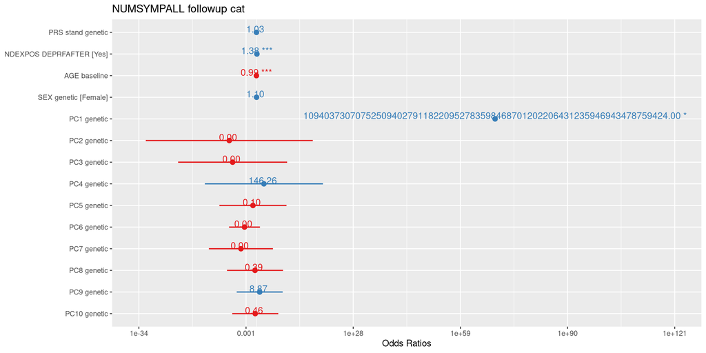

```r
plot_model(NDFirst_PO,
           type = 'est',
           show.values = T)
```

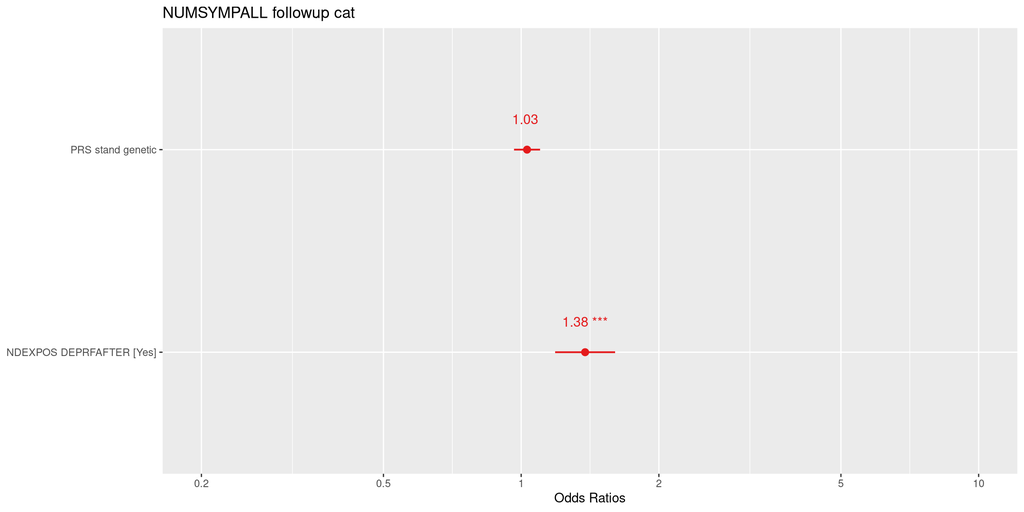

```r
plot_model(NDFirst_PO,
           type = 'est',
           show.values = T,
           terms = c('PRS_stand_genetic', 'NDEXPOS_DEPRFAFTERYes'))
```

#### Female

##### Results

```r
summary(NDFirst_female_PO)
```

```
##
## Call:
## VGAM::vglm(formula = NUMSYMPALL_followup_cat ~ PRS_stand_genetic +
##     NDEXPOS_DEPRFAFTER + AGE_baseline + PC1_genetic + PC2_genetic +
##     PC3_genetic + PC4_genetic + PC5_genetic + PC6_genetic + PC7_genetic +
##     PC8_genetic + PC9_genetic + PC10_genetic, family = VGAM::cumulative(logitlink,
##     parallel = T, reverse = T), data = df_ND_covid[df_ND_covid$SEX_genetic ==
##     "Female", ])
##
## Coefficients:
##                         Estimate Std. Error z value Pr(>|z|)
## (Intercept):1           1.949654   0.986479   1.976 0.048112 *
## (Intercept):2          -0.258497   0.984339  -0.263 0.792851
## PRS_stand_genetic       0.033556   0.039179   0.856 0.391732
## NDEXPOS_DEPRFAFTERYes   0.241955   0.089868   2.692 0.007095 **
## AGE_baseline           -0.009848   0.002621  -3.757 0.000172 ***
## PC1_genetic           165.099510  73.838667   2.236 0.025355 *
## PC2_genetic            -7.532170  31.167660  -0.242 0.809039
## PC3_genetic            -9.631971  20.838581  -0.462 0.643925
## PC4_genetic             3.201335  22.053595   0.145 0.884583
## PC5_genetic            -5.693489  13.273064  -0.429 0.667959
## PC6_genetic            -5.250484   6.009708  -0.874 0.382300
## PC7_genetic           -17.237027  12.446479  -1.385 0.166086
## PC8_genetic             3.329297  11.122996   0.299 0.764698
## PC9_genetic             0.671538   9.065917   0.074 0.940952
## PC10_genetic           -2.328893   9.079639  -0.256 0.797568
## ---
## Signif. codes:  0 '***' 0.001 '**' 0.01 '*' 0.05 '.' 0.1 ' ' 1
##
## Names of linear predictors: logitlink(P[Y>=2]), logitlink(P[Y>=3])
##
## Residual deviance: 4755.454 on 6473 degrees of freedom
##
## Log-likelihood: -2377.727 on 6473 degrees of freedom
##
## Number of Fisher scoring iterations: 4
##
##
## Exponentiated coefficients:
##     PRS_stand_genetic NDEXPOS_DEPRFAFTERYes          AGE_baseline
##          1.034126e+00          1.273737e+00          9.902003e-01
##           PC1_genetic           PC2_genetic           PC3_genetic
##          5.032760e+71          5.355750e-04          6.559761e-05
##           PC4_genetic           PC5_genetic           PC6_genetic
##          2.456530e+01          3.367823e-03          5.244982e-03
##           PC7_genetic           PC8_genetic           PC9_genetic
##          3.266287e-08          2.791872e+01          1.957246e+00
##          PC10_genetic
##          9.740347e-02
```

```r
# Create nice summary of results, including back transformation to give OR and calculating 95% CI
CI <- as.data.frame(confint(NDFirst_female_PO)) %>%
  rownames_to_column() %>%
  rename('lower_95_CI_of_beta' = "2.5 %",
         'upper_95_CI_of_beta' = "97.5 %") %>%
  mutate(lower_95_CI_of_OR = exp(lower_95_CI_of_beta),
         upper_95_CI_of_OR = exp(upper_95_CI_of_beta))

beta <- as.data.frame(coef(NDFirst_female_PO)) %>%
  rownames_to_column() %>%
  rename("beta" = "coef(NDFirst_female_PO)") %>%
  mutate(OR = exp(beta))

results <- beta %>%
  full_join(CI) %>%
  relocate(rowname, beta, lower_95_CI_of_beta, upper_95_CI_of_beta, OR, lower_95_CI_of_OR, upper_95_CI_of_OR)

results %>% kable()
```

| rowname | beta | lower_95_CI_of_beta | upper_95_CI_of_beta | OR | lower_95_CI_of_OR | upper_95_CI_of_OR |
| --- | --- | --- | --- | --- | --- | --- |
| (Intercept):1 | 1.9496539 | 0.0161910 | 3.8831169 | 7.026256e+00 | 1.016323e+00 | 4.857538e+01 |
| (Intercept):2 | -0.2584972 | -2.1877656 | 1.6707711 | 7.722112e-01 | 1.121671e-01 | 5.316266e+00 |
| PRS_stand_genetic | 0.0335562 | -0.0432336 | 0.1103460 | 1.034126e+00 | 9.576876e-01 | 1.116664e+00 |
| NDEXPOS_DEPRFAFTERYes | 0.2419555 | 0.0658167 | 0.4180942 | 1.273737e+00 | 1.068031e+00 | 1.519064e+00 |
| AGE_baseline | -0.0098481 | -0.0149858 | -0.0047103 | 9.902003e-01 | 9.851259e-01 | 9.953007e-01 |
| PC1_genetic | 165.0995102 | 20.3783824 | 309.8206381 | 5.032760e+71 | 7.083029e+08 | 3.575967e+134 |
| PC2_genetic | -7.5321697 | -68.6196612 | 53.5553218 | 5.356000e-04 | 0.000000e+00 | 1.814599e+23 |
| PC3_genetic | -9.6319712 | -50.4748390 | 31.2108965 | 6.560000e-05 | 0.000000e+00 | 3.586907e+13 |
| PC4_genetic | 3.2013347 | -40.0229165 | 46.4255859 | 2.456530e+01 | 0.000000e+00 | 1.453369e+20 |
| PC5_genetic | -5.6934886 | -31.7082170 | 20.3212397 | 3.367800e-03 | 0.000000e+00 | 6.689632e+08 |
| PC6_genetic | -5.2504836 | -17.0292942 | 6.5283271 | 5.245000e-03 | 0.000000e+00 | 6.842526e+02 |
| PC7_genetic | -17.2370269 | -41.6316784 | 7.1576246 | 0.000000e+00 | 0.000000e+00 | 1.283858e+03 |
| PC8_genetic | 3.3292973 | -18.4713736 | 25.1299682 | 2.791872e+01 | 0.000000e+00 | 8.199861e+10 |
| PC9_genetic | 0.6715383 | -17.0973330 | 18.4404095 | 1.957246e+00 | 0.000000e+00 | 1.019925e+08 |
| PC10_genetic | -2.3288935 | -20.1246584 | 15.4668715 | 9.740350e-02 | 0.000000e+00 | 5.214071e+06 |

##### Plots

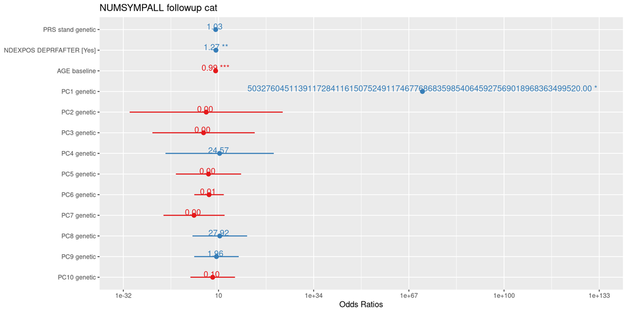

```r
plot_model(NDFirst_female_PO,
           type = 'est',
           show.values = T)
```

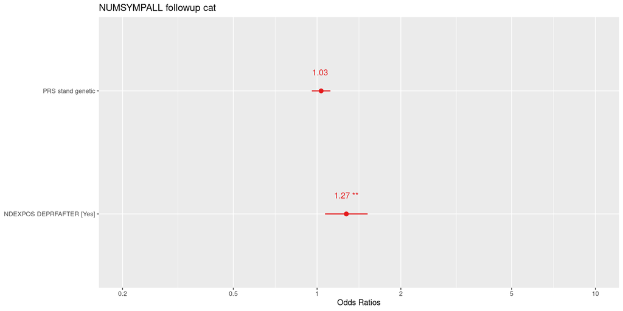

```r
plot_model(NDFirst_female_PO,
           type = 'est',
           show.values = T,
           terms = c('PRS_stand_genetic', 'NDEXPOS_DEPRFAFTERYes'))
```

#### Male

##### Results

```r
summary(NDFirst_male_PO)
```

```
##
## Call:
## VGAM::vglm(formula = NUMSYMPALL_followup_cat ~ PRS_stand_genetic +
##     NDEXPOS_DEPRFAFTER + AGE_baseline + PC1_genetic + PC2_genetic +
##     PC3_genetic + PC4_genetic + PC5_genetic + PC6_genetic + PC7_genetic +
##     PC8_genetic + PC9_genetic + PC10_genetic, family = VGAM::cumulative(logitlink,
##     parallel = T, reverse = T), data = df_ND_covid[df_ND_covid$SEX_genetic ==
##     "Male", ])
##
## Coefficients:
##                         Estimate Std. Error z value Pr(>|z|)
## (Intercept):1           4.028880   1.821731   2.212 0.026997 *
## (Intercept):2           1.864908   1.817264   1.026 0.304789
## PRS_stand_genetic       0.018017   0.064905   0.278 0.781330
## NDEXPOS_DEPRFAFTERYes   0.529858   0.150296   3.525 0.000423 ***
## AGE_baseline           -0.020333   0.004627  -4.394 1.11e-05 ***
## PC1_genetic           155.518706 126.299978   1.231 0.218194
## PC2_genetic           -74.174852  68.284498  -1.086 0.277363
## PC3_genetic           -51.015876  41.722145  -1.223 0.221423
## PC4_genetic            18.195636  45.178885   0.403 0.687135
## PC5_genetic             9.931171  22.471585   0.442 0.658530
## PC6_genetic           -17.797997  10.977467  -1.621 0.104949
## PC7_genetic            11.342744  22.670246   0.500 0.616838
## PC8_genetic            -9.058942  18.602396  -0.487 0.626275
## PC9_genetic             9.441376  15.767652   0.599 0.549319
## PC10_genetic            5.688725  15.550432   0.366 0.714496
## ---
## Signif. codes:  0 '***' 0.001 '**' 0.01 '*' 0.05 '.' 0.1 ' ' 1
##
## Names of linear predictors: logitlink(P[Y>=2]), logitlink(P[Y>=3])
##
## Residual deviance: 1635.232 on 2091 degrees of freedom
##
## Log-likelihood: -817.6159 on 2091 degrees of freedom
##
## Number of Fisher scoring iterations: 4
##
##
## Exponentiated coefficients:
##     PRS_stand_genetic NDEXPOS_DEPRFAFTERYes          AGE_baseline
##          1.018180e+00          1.698692e+00          9.798728e-01
##           PC1_genetic           PC2_genetic           PC3_genetic
##          3.474688e+67          6.113235e-33          6.983716e-23
##           PC4_genetic           PC5_genetic           PC6_genetic
##          7.984804e+07          2.056140e+04          1.863924e-08
##           PC7_genetic           PC8_genetic           PC9_genetic
##          8.435120e+04          1.163460e-04          1.259904e+04
##          PC10_genetic
##          2.955165e+02
```

```r
# Create nice summary of results, including back transformation to give OR and calculating 95% CI
CI <- as.data.frame(confint(NDFirst_male_PO)) %>%
  rownames_to_column() %>%
  rename('lower_95_CI_of_beta' = "2.5 %",
         'upper_95_CI_of_beta' = "97.5 %") %>%
  mutate(lower_95_CI_of_OR = exp(lower_95_CI_of_beta),
         upper_95_CI_of_OR = exp(upper_95_CI_of_beta))

beta <- as.data.frame(coef(NDFirst_male_PO)) %>%
  rownames_to_column() %>%
  rename("beta" = "coef(NDFirst_male_PO)") %>%
  mutate(OR = exp(beta))

results <- beta %>%
  full_join(CI) %>%
  relocate(rowname, beta, lower_95_CI_of_beta, upper_95_CI_of_beta, OR, lower_95_CI_of_OR, upper_95_CI_of_OR)

results %>% kable()
```

| rowname | beta | lower_95_CI_of_beta | upper_95_CI_of_beta | OR | lower_95_CI_of_OR | upper_95_CI_of_OR |
| --- | --- | --- | --- | --- | --- | --- |
| (Intercept):1 | 4.0288797 | 0.4583530 | 7.5994064 | 5.619792e+01 | 1.5814672 | 1.997010e+03 |
| (Intercept):2 | 1.8649081 | -1.6968647 | 5.4266809 | 6.455343e+00 | 0.1832572 | 2.273932e+02 |
| PRS_stand_genetic | 0.0180167 | -0.1091949 | 0.1452283 | 1.018180e+00 | 0.8965557 | 1.156303e+00 |
| NDEXPOS_DEPRFAFTERYes | 0.5298583 | 0.2352837 | 0.8244330 | 1.698692e+00 | 1.2652677 | 2.280587e+00 |
| AGE_baseline | -0.0203326 | -0.0294016 | -0.0112635 | 9.798728e-01 | 0.9710264 | 9.887997e-01 |
| PC1_genetic | 155.5187060 | -92.0247018 | 403.0621138 | 3.474688e+67 | 0.0000000 | 1.115968e+175 |
| PC2_genetic | -74.1748519 | -208.0100085 | 59.6603046 | 0.000000e+00 | 0.0000000 | 8.130946e+25 |
| PC3_genetic | -51.0158760 | -132.7897779 | 30.7580259 | 0.000000e+00 | 0.0000000 | 2.280557e+13 |
| PC4_genetic | 18.1956359 | -70.3533519 | 106.7446237 | 7.984804e+07 | 0.0000000 | 2.283500e+46 |
| PC5_genetic | 9.9311709 | -34.1123263 | 53.9746681 | 2.056140e+04 | 0.0000000 | 2.759946e+23 |
| PC6_genetic | -17.7979966 | -39.3134362 | 3.7174430 | 0.000000e+00 | 0.0000000 | 4.115901e+01 |
| PC7_genetic | 11.3427443 | -33.0901206 | 55.7756093 | 8.435120e+04 | 0.0000000 | 1.671242e+24 |
| PC8_genetic | -9.0589419 | -45.5189679 | 27.4010841 | 1.163000e-04 | 0.0000000 | 7.945837e+11 |
| PC9_genetic | 9.4413756 | -21.4626539 | 40.3454052 | 1.259904e+04 | 0.0000000 | 3.324963e+17 |
| PC10_genetic | 5.6887246 | -24.7895622 | 36.1670115 | 2.955165e+02 | 0.0000000 | 5.094875e+15 |

##### Plots

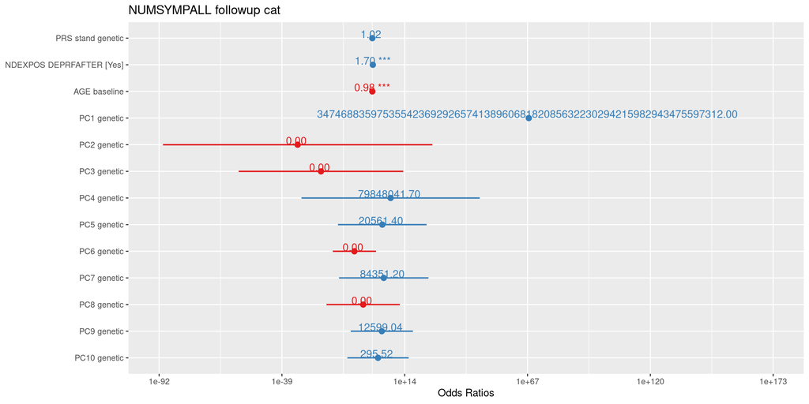

```r
plot_model(NDFirst_male_PO,
           type = 'est',
           show.values = T)
```

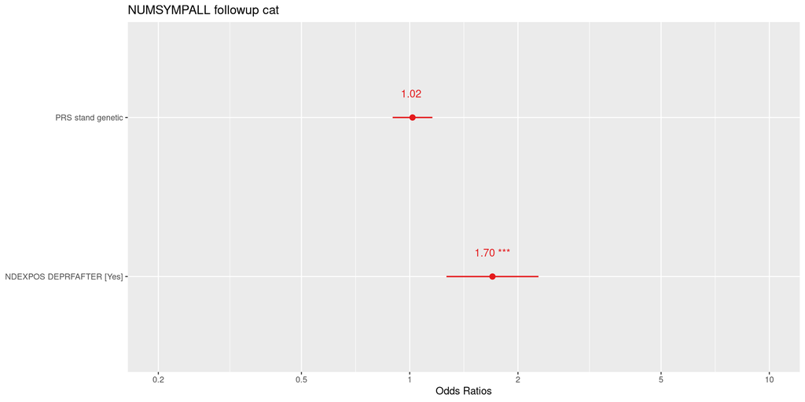

```r
plot_model(NDFirst_male_PO,
           type = 'est',
           show.values = T,
           terms = c('PRS_stand_genetic', 'NDEXPOS_DEPRFAFTERYes'))
```

#### Female vs Male

- ‘A sex-stratified analysis followed by a Zscore difference test (Eq. 1) is equivalent to a formal test for G×S interaction when there is no interaction between covariates and the strata, and the trait variance are equivalent in the two strata.’ (Blokland et al., 2022)
- Conduct a Z test for the difference between the coefficients of females and males

```r
female_beta <- coef(summary(NDFirst_female_PO))["NDEXPOS_DEPRFAFTERYes", "Estimate"]
female_SE <- coef(summary(NDFirst_female_PO))["NDEXPOS_DEPRFAFTERYes", "Std. Error"]
male_beta <- coef(summary(NDFirst_male_PO))["NDEXPOS_DEPRFAFTERYes", "Estimate"]
male_SE <- coef(summary(NDFirst_male_PO))["NDEXPOS_DEPRFAFTERYes", "Std. Error"]

Z <- (female_beta - male_beta) / sqrt((female_SE)^2 + (male_SE)^2)
p <- 2 * pnorm(abs(Z), mean = 0, sd = 1, lower.tail = FALSE)

message <- sprintf("Association of ND experience on no. symptoms during first depressive episode in females compared to males, Z = %.6f, p = %.6f", Z, p)
print(message)
```

```
## [1] "Association of ND experience on no. symptoms during first depressive episode in females compared to males, Z = -1.644081, p = 0.100160"
```

# 2019 Bushfires/Floods (current depression 1 yr after)

- Bushfire/flood q. from follow-up survey
- Current depression symptoms (approx. one year after) from covid wave 1 survey (because follow-up survey only asks about first depression symptoms and not current)

## Explore

### Sample size

```r
df_ND_covid %>%
  drop_na(NUMSYMPALL_covid1, SEX_genetic, AGE_followup, matches("^PC.*_genetic$"), BUSHFLOODHORR_followup, PRS_stand_genetic) %>%
  count(BUSHFLOODHORR_followup) %>%
  kable(caption = "No. participants experienced any frightening, horrible or traumatic experiences related to the bushfires and flooding over the past year")
```

No. participants experienced any frightening, horrible or traumatic experiences related to the bushfires and flooding over the past year

| BUSHFLOODHORR_followup | n |
| --- | --- |
| 0 | 1931 |
| 1 | 209 |

```r
df_ND_covid %>%
  drop_na(NUMSYMPALL_covid1, SEX_genetic, AGE_followup, matches("^PC.*_genetic$"), BUSHFLOODHORR_followup, PRS_stand_genetic) %>%
  filter(SEX_genetic == "Female") %>%
  count(BUSHFLOODHORR_followup) %>%
  kable(caption = "No. female participants experienced any frightening, horrible or traumatic experiences related to the bushfires and flooding over the past year")
```

No. female participants experienced any frightening, horrible or traumatic experiences related to the bushfires and flooding over the past year

| BUSHFLOODHORR_followup | n |
| --- | --- |
| 0 | 1430 |
| 1 | 164 |

```r
df_ND_covid %>%
  drop_na(NUMSYMPALL_covid1, SEX_genetic, AGE_followup, matches("^PC.*_genetic$"), BUSHFLOODHORR_followup, PRS_stand_genetic) %>%
  filter(SEX_genetic == "Male") %>%
  count(BUSHFLOODHORR_followup) %>%
  kable(caption = "No. male participants experienced any frightening, horrible or traumatic experiences related to the bushfires and flooding over the past year")
```

No. male participants experienced any frightening, horrible or traumatic experiences related to the bushfires and flooding over the past year

| BUSHFLOODHORR_followup | n |
| --- | --- |
| 0 | 501 |
| 1 | 45 |

### Distribution

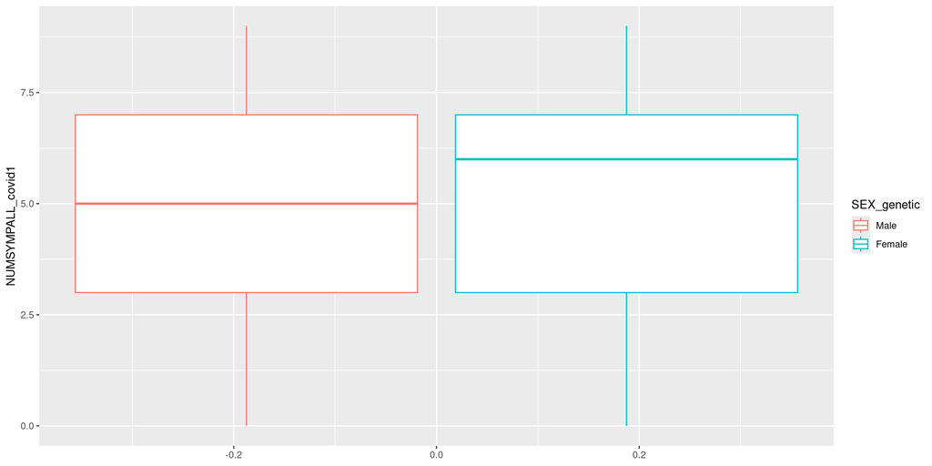

```r
ggplot(df_ND_covid[!is.na(df_ND_covid$NUMSYMPALL_covid1) & !is.na(df_ND_covid$SEX_genetic),],
             aes(y = NUMSYMPALL_covid1, colour = SEX_genetic)) +
  geom_boxplot()
```

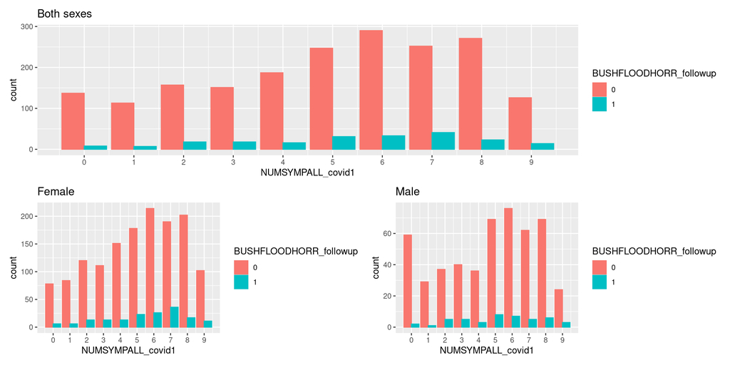

```r
p1 <- ggplot(df_ND_covid[!is.na(df_ND_covid$NUMSYMPALL_covid1) &
                           !is.na(df_ND_covid$SEX_genetic) &
                           !is.na(df_ND_covid$BUSHFLOODHORR_followup), ],
             aes (x = NUMSYMPALL_covid1, colour = BUSHFLOODHORR_followup, fill = BUSHFLOODHORR_followup)) +
  geom_bar(position = "dodge") +
  scale_x_continuous(breaks = c(0,1,2,3,4,5,6,7,8,9)) +
  ggtitle("Both sexes")

p2 <- ggplot(df_ND_covid[!is.na(df_ND_covid$NUMSYMPALL_covid1) &
                           !is.na(df_ND_covid$SEX_genetic) &
                           (df_ND_covid$SEX_genetic == "Female") &
                           !is.na(df_ND_covid$BUSHFLOODHORR_followup), ],
             aes (x = NUMSYMPALL_covid1, colour = BUSHFLOODHORR_followup, fill = BUSHFLOODHORR_followup)) +
  geom_bar(position = "dodge") +
  scale_x_continuous(breaks = c(0,1,2,3,4,5,6,7,8,9)) +
  ggtitle("Female")

p3 <- ggplot(df_ND_covid[!is.na(df_ND_covid$NUMSYMPALL_covid1) &
                           !is.na(df_ND_covid$SEX_genetic) &
                           (df_ND_covid$SEX_genetic == "Male") &
                           !is.na(df_ND_covid$BUSHFLOODHORR_followup), ],
             aes (x = NUMSYMPALL_covid1, colour = BUSHFLOODHORR_followup, fill = BUSHFLOODHORR_followup)) +
  geom_bar(position = "dodge") +
  scale_x_continuous(breaks = c(0,1,2,3,4,5,6,7,8,9)) +
  ggtitle("Male")

p1 / (p2 | p3)
```

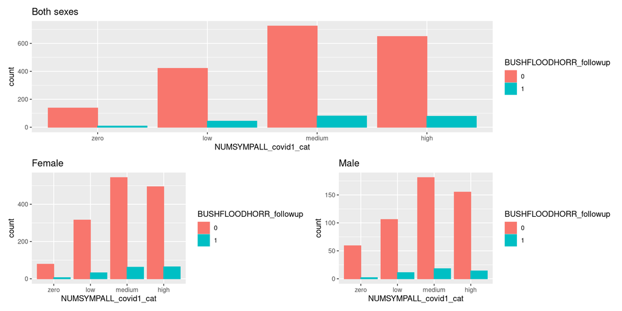

```r
p1 <- ggplot(df_ND_covid[!is.na(df_ND_covid$NUMSYMPALL_covid1_cat) &
                           !is.na(df_ND_covid$SEX_genetic) &
                           !is.na(df_ND_covid$BUSHFLOODHORR_followup), ],
             aes (x = NUMSYMPALL_covid1_cat, colour = BUSHFLOODHORR_followup, fill = BUSHFLOODHORR_followup)) +
  geom_bar(position = "dodge") +
  ggtitle("Both sexes")

p2 <- ggplot(df_ND_covid[!is.na(df_ND_covid$NUMSYMPALL_covid1_cat) &
                           !is.na(df_ND_covid$SEX_genetic) &
                           (df_ND_covid$SEX_genetic == "Female") &
                           !is.na(df_ND_covid$BUSHFLOODHORR_followup), ],
             aes (x = NUMSYMPALL_covid1_cat, colour = BUSHFLOODHORR_followup, fill = BUSHFLOODHORR_followup)) +
  geom_bar(position = "dodge") +
  ggtitle("Female")

p3 <- ggplot(df_ND_covid[!is.na(df_ND_covid$NUMSYMPALL_covid1_cat) &
                           !is.na(df_ND_covid$SEX_genetic) &
                           (df_ND_covid$SEX_genetic == "Male") &
                           !is.na(df_ND_covid$BUSHFLOODHORR_followup), ],
             aes (x = NUMSYMPALL_covid1_cat, colour = BUSHFLOODHORR_followup, fill = BUSHFLOODHORR_followup)) +
  geom_bar(position = "dodge") +
  ggtitle("Male")

p1 / (p2 | p3)
```

### Bushfires/Floods experience

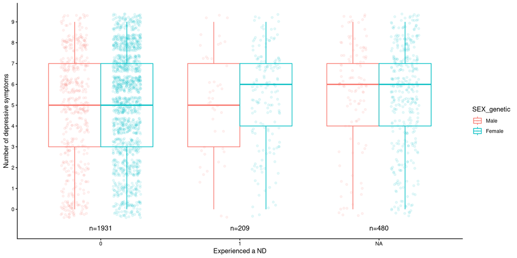

```r
ggplot(df_ND_covid[!is.na(df_ND_covid$SEX_genetic),], aes(x = as.factor(BUSHFLOODHORR_followup), y = NUMSYMPALL_covid1, colour = SEX_genetic)) +
  geom_boxplot(position = position_dodge(width = 0.75)) +
  geom_point(position = position_jitterdodge(dodge.width = 0.75, jitter.width = 0.4, jitter.height = 0.4), alpha = 0.1) +
  stat_n_text() +
  labs(x = "Experienced a ND",
       y = "Number of depressive symptoms") +
  theme(axis.text.x = element_text(angle = 45, vjust = 1, hjust=1)) +
  scale_y_continuous(breaks = c(0,1,2,3,4,5,6,7,8,9)) +
  theme_classic()
```

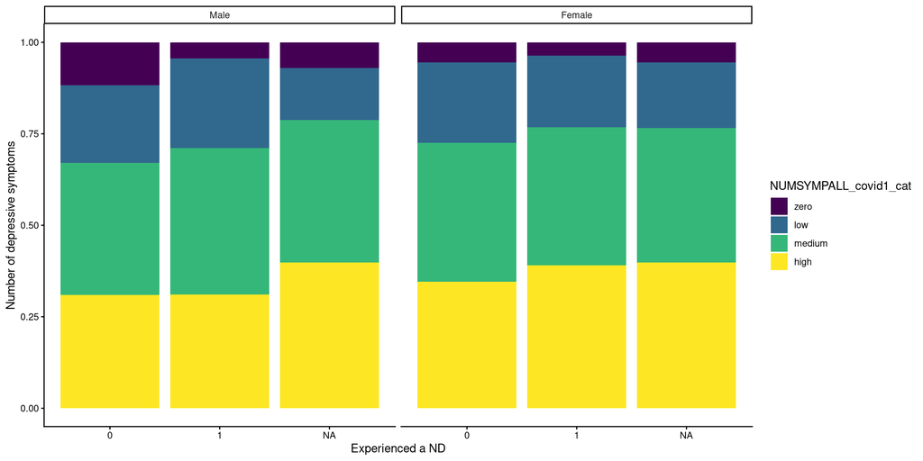

```r
ggplot(df_ND_covid[!is.na(df_ND_covid$SEX_genetic) & !is.na(df_ND_covid$NUMSYMPALL_covid1_cat),], aes(x = as.factor(BUSHFLOODHORR_followup), fill = NUMSYMPALL_covid1_cat)) +
  geom_bar(position = "fill") +
  # stat_n_text() +
  labs(x = "Experienced a ND",
       y = "Number of depressive symptoms") +
  facet_wrap(~ SEX_genetic) +
  theme(axis.text.x = element_text(angle = 45, vjust = 1, hjust=1)) +
  theme_classic()
```

## Fit Models

### Proportional Odds

```r
Twenty19BushFlood_PO <- VGAM::vglm(NUMSYMPALL_covid1_cat ~
                                            PRS_stand_genetic +
                                            BUSHFLOODHORR_followup +
                                            AGE_followup +
                                            SEX_genetic +
                                            PC1_genetic +
                                            PC2_genetic +
                                            PC3_genetic +
                                            PC4_genetic +
                                     PC5_genetic +
                                     PC6_genetic +
                                     PC7_genetic +
                                     PC8_genetic +
                                     PC9_genetic +
                                     PC10_genetic,
                                          family = VGAM::cumulative(logitlink, parallel = T, reverse = T), # with PO (package pammtools masks VGAM cumulative so specify from VGAM)
                                          data = df_ND_covid)

Twenty19BushFlood_female_PO <- VGAM::vglm(NUMSYMPALL_covid1_cat ~
                                  PRS_stand_genetic +
                                  BUSHFLOODHORR_followup +
                                  AGE_followup +
                                  PC1_genetic +
                                  PC2_genetic +
                                  PC3_genetic +
                                  PC4_genetic +
                                    PC5_genetic +
                                    PC6_genetic +
                                    PC7_genetic +
                                    PC8_genetic +
                                    PC9_genetic +
                                    PC10_genetic,
                                family = VGAM::cumulative(logitlink, parallel = T, reverse = T), # with PO (package pammtools masks VGAM cumulative so specify from VGAM)
                                data = df_ND_covid[df_ND_covid$SEX_genetic == "Female", ])

Twenty19BushFlood_male_PO <- VGAM::vglm(NUMSYMPALL_covid1_cat ~
                                PRS_stand_genetic +
                                BUSHFLOODHORR_followup +
                                AGE_followup +
                                PC1_genetic +
                                PC2_genetic +
                                PC3_genetic +
                                PC4_genetic +
                                  PC5_genetic +
                                  PC6_genetic +
                                  PC7_genetic +
                                  PC8_genetic +
                                  PC9_genetic +
                                  PC10_genetic,
                              family = VGAM::cumulative(logitlink, parallel = T, reverse = T), # with PO (package pammtools masks VGAM cumulative so specify from VGAM)
                              data = df_ND_covid[df_ND_covid$SEX_genetic == "Male", ])
```

### Partial Proportional Odds

```r
Twenty19BushFlood_PartPO_NDexpos <- VGAM::vglm(NUMSYMPALL_covid1_cat ~
                                                        PRS_stand_genetic +
                                                        BUSHFLOODHORR_followup +
                                                        AGE_followup +
                                                        SEX_genetic +
                                                        PC1_genetic +
                                                        PC2_genetic +
                                                        PC3_genetic +
                                                        PC4_genetic +
                                                 PC5_genetic +
                                                 PC6_genetic +
                                                 PC7_genetic +
                                                 PC8_genetic +
                                                 PC9_genetic +
                                                 PC10_genetic,
                                                      family = VGAM::cumulative(logitlink, parallel = F ~ BUSHFLOODHORR_followup, reverse = T), # with PO (package pammtools masks VGAM cumulative so specify from VGAM)
                                                      data = df_ND_covid)

Twenty19BushFlood_PartPO_PRS <- VGAM::vglm(NUMSYMPALL_covid1_cat ~
                                                    PRS_stand_genetic +
                                                    BUSHFLOODHORR_followup +
                                                    AGE_followup +
                                                    SEX_genetic +
                                                    PC1_genetic +
                                                    PC2_genetic +
                                                    PC3_genetic +
                                                    PC4_genetic +
                                             PC5_genetic +
                                             PC6_genetic +
                                             PC7_genetic +
                                             PC8_genetic +
                                             PC9_genetic +
                                             PC10_genetic,
                                                  family = VGAM::cumulative(logitlink, parallel = F ~ PRS_stand_genetic, reverse = T), # with PO (package pammtools masks VGAM cumulative so specify from VGAM)
                                                  data = df_ND_covid)

Twenty19BushFlood_PartPO_NDexpos_PRS <- VGAM::vglm(NUMSYMPALL_covid1_cat ~
                                                            PRS_stand_genetic +
                                                            BUSHFLOODHORR_followup +
                                                            AGE_followup +
                                                            SEX_genetic +
                                                            PC1_genetic +
                                                            PC2_genetic +
                                                            PC3_genetic +
                                                            PC4_genetic +
                                                     PC5_genetic +
                                                     PC6_genetic +
                                                     PC7_genetic +
                                                     PC8_genetic +
                                                     PC9_genetic +
                                                     PC10_genetic,
                                                          family = VGAM::cumulative(logitlink, parallel = F ~ BUSHFLOODHORR_followup + PRS_stand_genetic, reverse = T), # with PO (package pammtools masks VGAM cumulative so specify from VGAM)
                                                          data = df_ND_covid)

Twenty19BushFlood_female_PartPO_NDexpos <- VGAM::vglm(NUMSYMPALL_covid1_cat ~
                                              PRS_stand_genetic +
                                              BUSHFLOODHORR_followup +
                                              AGE_followup +
                                              PC1_genetic +
                                              PC2_genetic +
                                              PC3_genetic +
                                              PC4_genetic +
                                                PC5_genetic +
                                                PC6_genetic +
                                                PC7_genetic +
                                                PC8_genetic +
                                                PC9_genetic +
                                                PC10_genetic,
                                            family = VGAM::cumulative(logitlink, parallel = F ~ BUSHFLOODHORR_followup, reverse = T), # with PO (package pammtools masks VGAM cumulative so specify from VGAM)
                                            data = df_ND_covid[df_ND_covid$SEX_genetic == "Female", ])

Twenty19BushFlood_female_PartPO_PRS <- VGAM::vglm(NUMSYMPALL_covid1_cat ~
                                          PRS_stand_genetic +
                                          BUSHFLOODHORR_followup +
                                          AGE_followup +
                                          PC1_genetic +
                                          PC2_genetic +
                                          PC3_genetic +
                                          PC4_genetic +
                                            PC5_genetic +
                                            PC6_genetic +
                                            PC7_genetic +
                                            PC8_genetic +
                                            PC9_genetic +
                                            PC10_genetic,
                                        family = VGAM::cumulative(logitlink, parallel = F ~ PRS_stand_genetic, reverse = T), # with PO (package pammtools masks VGAM cumulative so specify from VGAM)
                                        data = df_ND_covid[df_ND_covid$SEX_genetic == "Female", ])

Twenty19BushFlood_female_PartPO_NDexpos_PRS <- VGAM::vglm(NUMSYMPALL_covid1_cat ~
                                                  PRS_stand_genetic +
                                                  BUSHFLOODHORR_followup +
                                                  AGE_followup +
                                                  PC1_genetic +
                                                  PC2_genetic +
                                                  PC3_genetic +
                                                  PC4_genetic +
                                                    PC5_genetic +
                                                    PC6_genetic +
                                                    PC7_genetic +
                                                    PC8_genetic +
                                                    PC9_genetic +
                                                    PC10_genetic,
                                                family = VGAM::cumulative(logitlink, parallel = F ~ BUSHFLOODHORR_followup + PRS_stand_genetic, reverse = T), # with PO (package pammtools masks VGAM cumulative so specify from VGAM)
                                                data = df_ND_covid[df_ND_covid$SEX_genetic == "Female", ])

Twenty19BushFlood_male_PartPO_NDexpos <- VGAM::vglm(NUMSYMPALL_covid1_cat ~
                                            PRS_stand_genetic +
                                            BUSHFLOODHORR_followup +
                                            AGE_followup +
                                            PC1_genetic +
                                            PC2_genetic +
                                            PC3_genetic +
                                            PC4_genetic +
                                              PC5_genetic +
                                              PC6_genetic +
                                              PC7_genetic +
                                              PC8_genetic +
                                              PC9_genetic +
                                              PC10_genetic,
                                          family = VGAM::cumulative(logitlink, parallel = F ~ BUSHFLOODHORR_followup, reverse = T), # with PO (package pammtools masks VGAM cumulative so specify from VGAM)
                                          data = df_ND_covid[df_ND_covid$SEX_genetic == "Male", ])

Twenty19BushFlood_male_PartPO_PRS <- VGAM::vglm(NUMSYMPALL_covid1_cat ~
                                        PRS_stand_genetic +
                                        BUSHFLOODHORR_followup +
                                        AGE_followup +
                                        PC1_genetic +
                                        PC2_genetic +
                                        PC3_genetic +
                                        PC4_genetic +
                                          PC5_genetic +
                                          PC6_genetic +
                                          PC7_genetic +
                                          PC8_genetic +
                                          PC9_genetic +
                                          PC10_genetic,
                                      family = VGAM::cumulative(logitlink, parallel = F ~ PRS_stand_genetic, reverse = T), # with PO (package pammtools masks VGAM cumulative so specify from VGAM)
                                      data = df_ND_covid[df_ND_covid$SEX_genetic == "Male", ])

Twenty19BushFlood_male_PartPO_NDexpos_PRS <- VGAM::vglm(NUMSYMPALL_covid1_cat ~
                                                PRS_stand_genetic +
                                                BUSHFLOODHORR_followup +
                                                AGE_followup +
                                                PC1_genetic +
                                                PC2_genetic +
                                                PC3_genetic +
                                                PC4_genetic +
                                                  PC5_genetic +
                                                  PC6_genetic +
                                                  PC7_genetic +
                                                  PC8_genetic +
                                                  PC9_genetic +
                                                  PC10_genetic,
                                              family = VGAM::cumulative(logitlink, parallel = F ~ BUSHFLOODHORR_followup + PRS_stand_genetic, reverse = T), # with PO (package pammtools masks VGAM cumulative so specify from VGAM)
                                              data = df_ND_covid[df_ND_covid$SEX_genetic == "Male", ])
```

## Check Models

### Proportional Odds

#### Both Sexes

```r
### Test goodness of fit ###

# lipsitz test
lipsitz(Twenty19BushFlood_PO)
```

```
##
## Lipsitz Test:
##
##                       LR   df   pr(>chi)
## ordinal(lipsitz)  6.6475    9     0.6738
##
## H0: No lack of fit dictated
```

```r
# pulkstenis-robinson test
# (requires the vector of categorical input variables as an argument)
pulkroben(Twenty19BushFlood_PO, test = c("chisq","deviance"), tables = FALSE)
```

```
##
## Pulkstenis-Robinson Chi-squared Test:
##
##                     chi-sq   df   pr(>chi)
## ordinal(pulkroben)  28.335   18    0.05713 .
## ---
## Signif. codes:  0 '***' 0.001 '**' 0.01 '*' 0.05 '.' 0.1 ' ' 1
##
## H0: No lack of fit dictated
##
## rho: 100%
```

```r
# Hosmer-Lemeshow test
hosmerlem(Twenty19BushFlood_PO)
```

```
##
## Hosmer-Lemeshow Test:
##
##                     Chi-sq  df  pr(>chi)
## ordinal(Hosmerlem)  37.441  26   0.06818 .
## ---
## Signif. codes:  0 '***' 0.001 '**' 0.01 '*' 0.05 '.' 0.1 ' ' 1
##
## H0: No lack of fit dictated
##
## rho: 100%
```

```r
### Test proportional odds assumption ###

# Brant Wald Test
# A generalized ordinal logistic regression model is approximated and compared to the calculated proportional odds model (a generalized ordinal logistic regression model is simply a relaxing of the proportional odds model to allow for different coefficients at each level of the ordinal outcome variable.)
# A Wald test is a hypothesis test of the significance of the difference in model coefficients, producing a chi-square statistic. A low p-value in a Brant-Wald test is an indicator that the coefficient does not satisfy the proportional odds assumption.
# A p-value of less than 0.05 on this test, particularly on the Omnibus plus at least one of the variables should be interpreted as a failure of the proportional odds assumption.

brant.test(Twenty19BushFlood_PO)
```

```
##
## Brant Test:
##                            chi-sq   df   pr(>chi)
## Omnibus                    30.727   28     0.3293
## PRS_stand_genetic           0.172    2     0.9176
## BUSHFLOODHORR_followup1     1.596    2     0.4503
## AGE_followup                3.353    2     0.1871
## SEX_geneticFemale          11.436    2     0.0033 **
## PC1_genetic                 0.572    2     0.7513
## PC2_genetic                 2.681    2     0.2617
## PC3_genetic                 1.146    2     0.5637
## PC4_genetic                 1.371    2     0.5039
## PC5_genetic                 1.056    2     0.5897
## PC6_genetic                 0.288    2     0.8659
## PC7_genetic                 1.151    2     0.5624
## PC8_genetic                 0.001    2     0.9997
## PC9_genetic                 2.085    2     0.3526
## PC10_genetic                1.918    2     0.3832
## ---
## Signif. codes:  0 '***' 0.001 '**' 0.01 '*' 0.05 '.' 0.1 ' ' 1
##
## H0: Proportional odds assumption holds
```

```r
# Sighting coefficients of stratified binomial models - want each to be similar
# create binary variables for every combo of the 3 categories
x <- df_ND_covid %>%
  mutate(SYMPzeroplus = case_when(
    NUMSYMPALL_covid1_cat == 'zero' ~ 0,
    NUMSYMPALL_covid1_cat == 'low' | NUMSYMPALL_covid1_cat == 'med' | NUMSYMPALL_covid1_cat == 'high' ~ 1
  ),
  SYMPlowplus = case_when(
    NUMSYMPALL_covid1_cat == 'zero' | NUMSYMPALL_covid1_cat == 'low' ~ 0,
    NUMSYMPALL_covid1_cat == 'medium' |  NUMSYMPALL_covid1_cat == 'high' ~ 1),
  SYMPmedplus = case_when(
    NUMSYMPALL_covid1_cat == 'zero' | NUMSYMPALL_covid1_cat == 'low' | NUMSYMPALL_covid1_cat == 'medium' ~ 0,
    NUMSYMPALL_covid1_cat == 'high' ~ 1)
  )


# Create logistic regression for each
zeroplus_model <- glm(SYMPzeroplus ~
                        PRS_stand_genetic +
                        BUSHFLOODHORR_followup +
                        AGE_followup +
                        SEX_genetic +
                        PC1_genetic +
                        PC2_genetic +
                        PC3_genetic +
                        PC4_genetic +
                        PC5_genetic +
                        PC6_genetic +
                        PC7_genetic +
                        PC8_genetic +
                        PC9_genetic +
                        PC10_genetic,
                      family = binomial(link = 'logit'),
                      data = x)

lowplus_model <- glm(SYMPlowplus ~
                       PRS_stand_genetic +
                       BUSHFLOODHORR_followup +
                       AGE_followup +
                       SEX_genetic +
                       PC1_genetic +
                       PC2_genetic +
                       PC3_genetic +
                       PC4_genetic +
                       PC5_genetic +
                       PC6_genetic +
                       PC7_genetic +
                       PC8_genetic +
                       PC9_genetic +
                       PC10_genetic,
                     family = binomial(link = 'logit'),
                     data = x)

medplus_model <- glm(SYMPmedplus ~
                       PRS_stand_genetic +
                       BUSHFLOODHORR_followup +
                       AGE_followup +
                       SEX_genetic +
                       PC1_genetic +
                       PC2_genetic +
                       PC3_genetic +
                       PC4_genetic +
                       PC5_genetic +
                       PC6_genetic +
                       PC7_genetic +
                       PC8_genetic +
                       PC9_genetic +
                       PC10_genetic,
                     family = binomial(link = 'logit'),
                     data = x)


# display the coefficients of all models and examine the difference between them.
# coefficients (i.e. the slopes) should be similar for all models to hold the proportional odds assumption

# table
coeffs <- data.frame(
  'ordinal' = coef(Twenty19BushFlood_PO)[-c(1,2,3)],
  'binary zero vs low and med and high' = lowplus_model$coefficients[-1],
  'binary zero and low vs med and high' = lowplus_model$coefficients[-1],
  'binary zero and low and med vs high' = medplus_model$coefficients[-1])

coeffs %>%
  kable()
```

|  | ordinal | binary.zero.vs.low.and.med.and.high | binary.zero.and.low.vs.med.and.high | binary.zero.and.low.and.med.vs.high |
| --- | --- | --- | --- | --- |
| PRS_stand_genetic | 0.2160071 | 0.2073422 | 0.2073422 | 0.2150324 |
| BUSHFLOODHORR_followup1 | 0.2248393 | 0.2573112 | 0.2573112 | 0.1696384 |
| AGE_followup | -0.0213715 | -0.0251572 | -0.0251572 | -0.0189441 |
| SEX_geneticFemale | 0.1366050 | 0.1186386 | 0.1186386 | 0.0574331 |
| PC1_genetic | 4.3972177 | -40.3407756 | -40.3407756 | 21.5839728 |
| PC2_genetic | -12.4709791 | 25.3771938 | 25.3771938 | -41.8644893 |
| PC3_genetic | -13.1424246 | -18.6445794 | -18.6445794 | -4.8899892 |
| PC4_genetic | 15.4154278 | 13.6678946 | 13.6678946 | 4.5255859 |
| PC5_genetic | 12.1363387 | 2.5842308 | 2.5842308 | 17.3755574 |
| PC6_genetic | -1.3328378 | 1.3259616 | 1.3259616 | -3.0942164 |
| PC7_genetic | 13.9987778 | 24.1781845 | 24.1781845 | 6.7908925 |
| PC8_genetic | -9.7677317 | -9.5947465 | -9.5947465 | -9.2399582 |
| PC9_genetic | -7.4099800 | 2.2978107 | 2.2978107 | -15.2036518 |
| PC10_genetic | -20.3400699 | -12.7155696 | -12.7155696 | -25.0303246 |

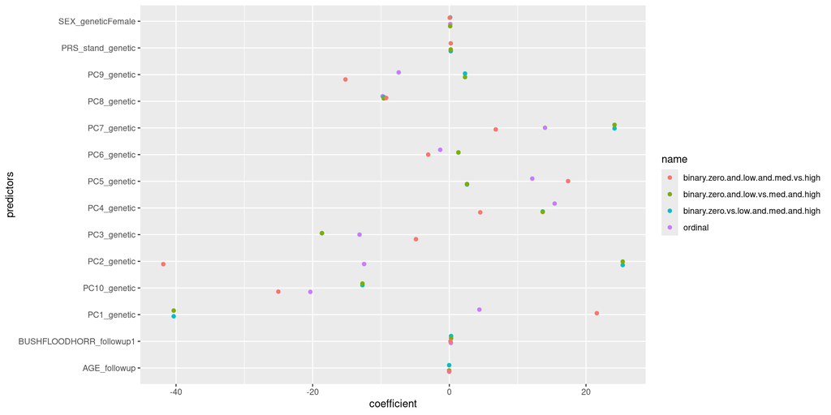

```r
coeffs2 <- coeffs %>%
  rownames_to_column() %>%
  pivot_longer(cols = 2:5)

ggplot(coeffs2, aes(x = value, y = rowname, group = name, colour = name)) +
  geom_jitter(height = 0.2) +
  labs(x = "coefficient", y = "predictors")
```

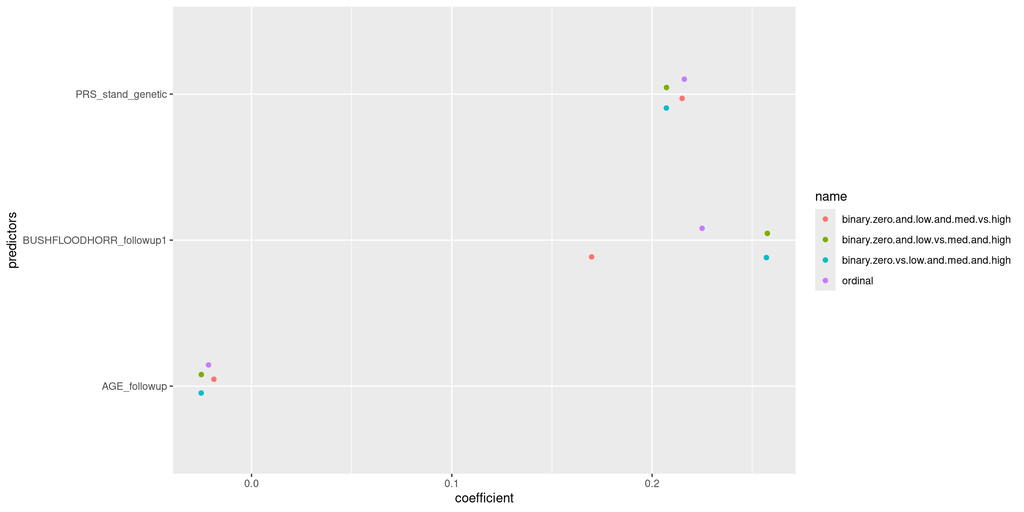

```r
coeffs3 <- coeffs2 %>%
  filter(rowname == 'PRS_stand_genetic' | rowname == 'BUSHFLOODHORR_followup1' | rowname == "AGE_followup")

ggplot(coeffs3, aes(x = value, y = rowname, group = name, colour = name)) +
  geom_jitter(height = 0.2) +
  labs(x = "coefficient", y = "predictors")
```

#### Female

```r
### Test goodness of fit ###

# lipsitz test
lipsitz(Twenty19BushFlood_female_PO)
```

```
##
## Lipsitz Test:
##
##                       LR   df   pr(>chi)
## ordinal(lipsitz)  13.467    9     0.1426
##
## H0: No lack of fit dictated
```

```r
# pulkstenis-robinson test
# (requires the vector of categorical input variables as an argument)
pulkroben(Twenty19BushFlood_female_PO, test = c("chisq","deviance"), tables = FALSE)
```

```
##
## Pulkstenis-Robinson Chi-squared Test:
##
##                     chi-sq   df   pr(>chi)
## ordinal(pulkroben)  5.8517    7     0.5572
##
## H0: No lack of fit dictated
##
## rho: 100%
```

```r
# Hosmer-Lemeshow test
hosmerlem(Twenty19BushFlood_female_PO)
```

```
##
## Hosmer-Lemeshow Test:
##
##                     Chi-sq  df  pr(>chi)
## ordinal(Hosmerlem)  25.054  26    0.5159
##
## H0: No lack of fit dictated
##
## rho: 100%
```

```r
### Test proportional odds assumption ###

# Brant Wald Test
# A generalized ordinal logistic regression model is approximated and compared to the calculated proportional odds model (a generalized ordinal logistic regression model is simply a relaxing of the proportional odds model to allow for different coefficients at each level of the ordinal outcome variable.)
# A Wald test is a hypothesis test of the significance of the difference in model coefficients, producing a chi-square statistic. A low p-value in a Brant-Wald test is an indicator that the coefficient does not satisfy the proportional odds assumption.
# A p-value of less than 0.05 on this test, particularly on the Omnibus plus at least one of the variables should be interpreted as a failure of the proportional odds assumption.

brant.test(Twenty19BushFlood_female_PO)
```

```
##
## Brant Test:
##                            chi-sq   df   pr(>chi)
## Omnibus                    11.183   26       0.99
## PRS_stand_genetic           0.054    2       0.97
## BUSHFLOODHORR_followup1     0.290    2       0.86
## AGE_followup                3.386    2       0.18
## PC1_genetic                 0.203    2       0.90
## PC2_genetic                 2.009    2       0.37
## PC3_genetic                 0.859    2       0.65
## PC4_genetic                 0.095    2       0.95
## PC5_genetic                 0.480    2       0.79
## PC6_genetic                 0.200    2       0.90
## PC7_genetic                 1.385    2       0.50
## PC8_genetic                 0.409    2       0.82
## PC9_genetic                 1.190    2       0.55
## PC10_genetic                0.665    2       0.72
##
## H0: Proportional odds assumption holds
```

```r
# Sighting coefficients of stratified binomial models - want each to be similar
# create binary variables for every combo of the 3 categories
x <- df_ND_covid %>%
  mutate(SYMPzeroplus = case_when(
    NUMSYMPALL_covid1_cat == 'zero' ~ 0,
    NUMSYMPALL_covid1_cat == 'low' | NUMSYMPALL_covid1_cat == 'med' | NUMSYMPALL_covid1_cat == 'high' ~ 1
  ),
    SYMPlowplus = case_when(
    NUMSYMPALL_covid1_cat == 'zero' | NUMSYMPALL_covid1_cat == 'low' ~ 0,
    NUMSYMPALL_covid1_cat == 'medium' |  NUMSYMPALL_covid1_cat == 'high' ~ 1),
    SYMPmedplus = case_when(
      NUMSYMPALL_covid1_cat == 'zero' | NUMSYMPALL_covid1_cat == 'low' | NUMSYMPALL_covid1_cat == 'medium' ~ 0,
      NUMSYMPALL_covid1_cat == 'high' ~ 1)
  )


# Create logistic regression for each
zeroplus_model <- glm(SYMPzeroplus ~
                       PRS_stand_genetic +
                       BUSHFLOODHORR_followup +
                       AGE_followup +
                       PC1_genetic +
                       PC2_genetic +
                       PC3_genetic +
                       PC4_genetic +
                        PC5_genetic +
                        PC6_genetic +
                        PC7_genetic +
                        PC8_genetic +
                        PC9_genetic +
                        PC10_genetic,
                     family = binomial(link = 'logit'),
                     data = x[x$SEX_genetic == "Female", ])

lowplus_model <- glm(SYMPlowplus ~
                       PRS_stand_genetic +
                       BUSHFLOODHORR_followup +
                       AGE_followup +
                       PC1_genetic +
                       PC2_genetic +
                       PC3_genetic +
                       PC4_genetic +
                       PC5_genetic +
                       PC6_genetic +
                       PC7_genetic +
                       PC8_genetic +
                       PC9_genetic +
                       PC10_genetic,
                     family = binomial(link = 'logit'),
                     data = x[x$SEX_genetic == "Female", ])

medplus_model <- glm(SYMPmedplus ~
                       PRS_stand_genetic +
                       BUSHFLOODHORR_followup +
                       AGE_followup +
                       PC1_genetic +
                       PC2_genetic +
                       PC3_genetic +
                       PC4_genetic +
                       PC5_genetic +
                       PC6_genetic +
                       PC7_genetic +
                       PC8_genetic +
                       PC9_genetic +
                       PC10_genetic,
                     family = binomial(link = 'logit'),
                     data = x[x$SEX_genetic == "Female", ])


# display the coefficients of all models and examine the difference between them.
# coefficients (i.e. the slopes) should be similar for all models to hold the proportional odds assumption

# table
coeffs <- data.frame(
  'ordinal' = coef(Twenty19BushFlood_female_PO)[-c(1,2,3)],
  'binary zero vs low and med and high' = lowplus_model$coefficients[-1],
  'binary zero and low vs med and high' = lowplus_model$coefficients[-1],
  'binary zero and low and med vs high' = medplus_model$coefficients[-1])

coeffs %>%
  kable()
```

|  | ordinal | binary.zero.vs.low.and.med.and.high | binary.zero.and.low.vs.med.and.high | binary.zero.and.low.and.med.vs.high |
| --- | --- | --- | --- | --- |
| PRS_stand_genetic | 0.2287568 | 0.2199193 | 0.2199193 | 0.2273771 |
| BUSHFLOODHORR_followup1 | 0.2248510 | 0.2337223 | 0.2337223 | 0.1943413 |
| AGE_followup | -0.0201568 | -0.0235639 | -0.0235639 | -0.0177066 |
| PC1_genetic | 11.1054717 | -7.4176537 | -7.4176537 | -2.1176812 |
| PC2_genetic | -24.7284873 | 17.6611655 | 17.6611655 | -44.4000357 |
| PC3_genetic | 9.5473307 | 21.6672749 | 21.6672749 | 1.2519817 |
| PC4_genetic | 33.5071914 | 22.6708636 | 22.6708636 | 33.2631105 |
| PC5_genetic | 21.3261879 | 29.4709736 | 29.4709736 | 15.8282543 |
| PC6_genetic | -4.1517186 | -3.6793976 | -3.6793976 | -4.3601471 |
| PC7_genetic | 3.2042548 | 16.0271750 | 16.0271750 | -6.6703213 |
| PC8_genetic | -6.3105696 | -9.7260878 | -9.7260878 | -3.3672497 |
| PC9_genetic | -5.9475696 | 3.1161594 | 3.1161594 | -10.2083828 |
| PC10_genetic | -25.5487953 | -22.1096989 | -22.1096989 | -27.4937275 |

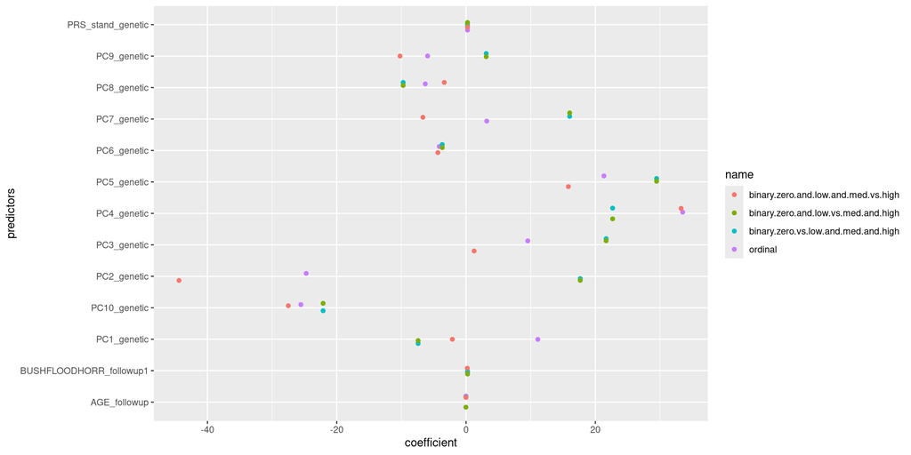

```r
coeffs2 <- coeffs %>%
  rownames_to_column() %>%
  pivot_longer(cols = 2:5)

ggplot(coeffs2, aes(x = value, y = rowname, group = name, colour = name)) +
  geom_jitter(height = 0.2) +
  labs(x = "coefficient", y = "predictors")
```

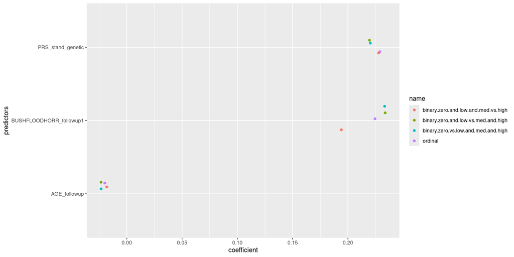

```r
coeffs3 <- coeffs2 %>%
  filter(rowname == 'PRS_stand_genetic' | rowname == 'BUSHFLOODHORR_followup1' | rowname == "AGE_followup")

ggplot(coeffs3, aes(x = value, y = rowname, group = name, colour = name)) +
  geom_jitter(height = 0.2) +
  labs(x = "coefficient", y = "predictors")
```

#### Male

```r
### Test goodness of fit ###

# lipsitz test
lipsitz(Twenty19BushFlood_male_PO)
```

```
##
## Lipsitz Test:
##
##                       LR   df   pr(>chi)
## ordinal(lipsitz)  6.2672    9     0.7129
##
## H0: No lack of fit dictated
```

```r
# pulkstenis-robinson test
# (requires the vector of categorical input variables as an argument)
pulkroben(Twenty19BushFlood_male_PO, test = c("chisq","deviance"), tables = FALSE)
```

```
##
## Pulkstenis-Robinson Chi-squared Test:
##
##                     chi-sq   df   pr(>chi)
## ordinal(pulkroben)  11.401    7      0.122
##
## H0: No lack of fit dictated
##
## rho: 100%
```

```r
# Hosmer-Lemeshow test
hosmerlem(Twenty19BushFlood_male_PO)
```

```
##
## Hosmer-Lemeshow Test:
##
##                     Chi-sq  df  pr(>chi)
## ordinal(Hosmerlem)  15.602  26    0.9453
##
## H0: No lack of fit dictated
##
## rho: 100%
```

```r
### Test proportional odds assumption ###

# Brant Wald Test
# A generalized ordinal logistic regression model is approximated and compared to the calculated proportional odds model (a generalized ordinal logistic regression model is simply a relaxing of the proportional odds model to allow for different coefficients at each level of the ordinal outcome variable.)
# A Wald test is a hypothesis test of the significance of the difference in model coefficients, producing a chi-square statistic. A low p-value in a Brant-Wald test is an indicator that the coefficient does not satisfy the proportional odds assumption.
# A p-value of less than 0.05 on this test, particularly on the Omnibus plus at least one of the variables should be interpreted as a failure of the proportional odds assumption.

brant.test(Twenty19BushFlood_male_PO)
```

```
##
## Brant Test:
##                            chi-sq   df   pr(>chi)
## Omnibus                    25.391   26      0.497
## PRS_stand_genetic           1.194    2      0.550
## BUSHFLOODHORR_followup1     2.161    2      0.339
## AGE_followup                1.965    2      0.374
## PC1_genetic                 0.451    2      0.798
## PC2_genetic                 1.065    2      0.587
## PC3_genetic                 1.613    2      0.446
## PC4_genetic                 5.528    2      0.063 .
## PC5_genetic                 7.374    2      0.025 *
## PC6_genetic                 1.093    2      0.579
## PC7_genetic                 0.003    2      0.999
## PC8_genetic                 0.593    2      0.743
## PC9_genetic                 1.999    2      0.368
## PC10_genetic                2.231    2      0.328
## ---
## Signif. codes:  0 '***' 0.001 '**' 0.01 '*' 0.05 '.' 0.1 ' ' 1
##
## H0: Proportional odds assumption holds
```

```r
# Sighting coefficients of stratified binomial models - want each to be similar
# create binary variables for every combo of the 3 categories
x <- df_ND_covid %>%
  mutate(SYMPzeroplus = case_when(
    NUMSYMPALL_covid1_cat == 'zero' ~ 0,
    NUMSYMPALL_covid1_cat == 'low' | NUMSYMPALL_covid1_cat == 'med' | NUMSYMPALL_covid1_cat == 'high' ~ 1
  ),
  SYMPlowplus = case_when(
    NUMSYMPALL_covid1_cat == 'zero' | NUMSYMPALL_covid1_cat == 'low' ~ 0,
    NUMSYMPALL_covid1_cat == 'medium' |  NUMSYMPALL_covid1_cat == 'high' ~ 1),
  SYMPmedplus = case_when(
    NUMSYMPALL_covid1_cat == 'zero' | NUMSYMPALL_covid1_cat == 'low' | NUMSYMPALL_covid1_cat == 'medium' ~ 0,
    NUMSYMPALL_covid1_cat == 'high' ~ 1)
  )


# Create logistic regression for each
zeroplus_model <- glm(SYMPzeroplus ~
                        PRS_stand_genetic +
                        BUSHFLOODHORR_followup +
                        AGE_followup +
                        PC1_genetic +
                        PC2_genetic +
                        PC3_genetic +
                        PC4_genetic +
                        PC5_genetic +
                        PC6_genetic +
                        PC7_genetic +
                        PC8_genetic +
                        PC9_genetic +
                        PC10_genetic,
                      family = binomial(link = 'logit'),
                      data = x[x$SEX_genetic == "Male", ])

lowplus_model <- glm(SYMPlowplus ~
                       PRS_stand_genetic +
                       BUSHFLOODHORR_followup +
                       AGE_followup +
                       PC1_genetic +
                       PC2_genetic +
                       PC3_genetic +
                       PC4_genetic +
                       PC5_genetic +
                       PC6_genetic +
                       PC7_genetic +
                       PC8_genetic +
                       PC9_genetic +
                       PC10_genetic,
                     family = binomial(link = 'logit'),
                     data = x[x$SEX_genetic == "Male", ])

medplus_model <- glm(SYMPmedplus ~
                       PRS_stand_genetic +
                       BUSHFLOODHORR_followup +
                       AGE_followup +
                       PC1_genetic +
                       PC2_genetic +
                       PC3_genetic +
                       PC4_genetic +
                       PC5_genetic +
                       PC6_genetic +
                       PC7_genetic +
                       PC8_genetic +
                       PC9_genetic +
                       PC10_genetic,
                     family = binomial(link = 'logit'),
                     data = x[x$SEX_genetic == "Male", ])


# display the coefficients of all models and examine the difference between them.
# coefficients (i.e. the slopes) should be similar for all models to hold the proportional odds assumption

# table
coeffs <- data.frame(
  'ordinal' = coef(Twenty19BushFlood_male_PO)[-c(1,2,3)],
  'binary zero vs low and med and high' = lowplus_model$coefficients[-1],
  'binary zero and low vs med and high' = lowplus_model$coefficients[-1],
  'binary zero and low and med vs high' = medplus_model$coefficients[-1])

coeffs %>%
  kable()
```

|  | ordinal | binary.zero.vs.low.and.med.and.high | binary.zero.and.low.vs.med.and.high | binary.zero.and.low.and.med.vs.high |
| --- | --- | --- | --- | --- |
| PRS_stand_genetic | 0.1811840 | 0.1866285 | 0.1866285 | 0.1716497 |
| BUSHFLOODHORR_followup1 | 0.2313954 | 0.3379807 | 0.3379807 | 0.0666139 |
| AGE_followup | -0.0248327 | -0.0306771 | -0.0306771 | -0.0224720 |
| PC1_genetic | -2.1550672 | -75.5527474 | -75.5527474 | 47.1306432 |
| PC2_genetic | 10.7069511 | 62.1463616 | 62.1463616 | -44.5386924 |
| PC3_genetic | -34.8436302 | -76.8438340 | -76.8438340 | -1.7496704 |
| PC4_genetic | -15.4299666 | 16.8662743 | 16.8662743 | -86.4681335 |
| PC5_genetic | -12.2607096 | -64.3612896 | -64.3612896 | 22.3147524 |
| PC6_genetic | 11.7157792 | 18.3540049 | 18.3540049 | 9.1272714 |
| PC7_genetic | 43.7759373 | 45.7052314 | 45.7052314 | 46.0045513 |
| PC8_genetic | -25.8485782 | -15.0275617 | -15.0275617 | -29.7101097 |
| PC9_genetic | -8.0383460 | 3.7800736 | 3.7800736 | -28.3886026 |
| PC10_genetic | -3.6531820 | 12.9366801 | 12.9366801 | -10.6377762 |

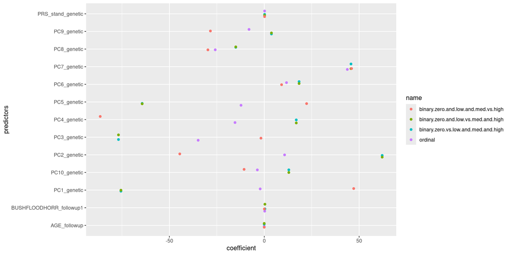

```r
coeffs2 <- coeffs %>%
  rownames_to_column() %>%
  pivot_longer(cols = 2:5)

ggplot(coeffs2, aes(x = value, y = rowname, group = name, colour = name)) +
  geom_jitter(height = 0.2) +
  labs(x = "coefficient", y = "predictors")
```

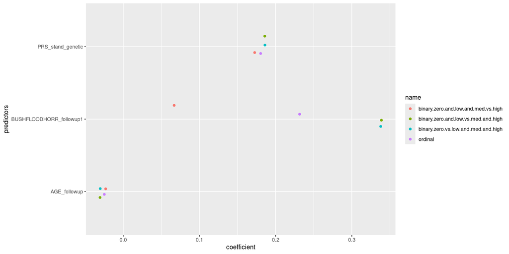

```r
coeffs3 <- coeffs2 %>%
  filter(rowname == 'PRS_stand_genetic' | rowname == 'BUSHFLOODHORR_followup1' | rowname == "AGE_followup")

ggplot(coeffs3, aes(x = value, y = rowname, group = name, colour = name)) +
  geom_jitter(height = 0.2) +
  labs(x = "coefficient", y = "predictors")
```

- Goodness of fit OK
- Brant test shows proportional odds assumption OK
- Visual inspection shows PO looks good, may not hold for exposure to bushfires/floods (and may not hold fr PC2 and 4 (not really an issue as covariates not interested in the coefficients))

### Partial Proportional Odds

#### Both Sexes

```r
# LRT to compare partial PO to PO models
lrtest(Twenty19BushFlood_PO, Twenty19BushFlood_PartPO_NDexpos)
```

```
## Likelihood ratio test
##
## Model 1: NUMSYMPALL_covid1_cat ~ PRS_stand_genetic + BUSHFLOODHORR_followup +
##     AGE_followup + SEX_genetic + PC1_genetic + PC2_genetic +
##     PC3_genetic + PC4_genetic + PC5_genetic + PC6_genetic + PC7_genetic +
##     PC8_genetic + PC9_genetic + PC10_genetic
## Model 2: NUMSYMPALL_covid1_cat ~ PRS_stand_genetic + BUSHFLOODHORR_followup +
##     AGE_followup + SEX_genetic + PC1_genetic + PC2_genetic +
##     PC3_genetic + PC4_genetic + PC5_genetic + PC6_genetic + PC7_genetic +
##     PC8_genetic + PC9_genetic + PC10_genetic
##    #Df  LogLik Df  Chisq Pr(>Chisq)
## 1 6403 -2619.5
## 2 6401 -2618.5 -2 1.8382     0.3989
```

```r
lrtest(Twenty19BushFlood_PO, Twenty19BushFlood_PartPO_PRS)
```

```
## Likelihood ratio test
##
## Model 1: NUMSYMPALL_covid1_cat ~ PRS_stand_genetic + BUSHFLOODHORR_followup +
##     AGE_followup + SEX_genetic + PC1_genetic + PC2_genetic +
##     PC3_genetic + PC4_genetic + PC5_genetic + PC6_genetic + PC7_genetic +
##     PC8_genetic + PC9_genetic + PC10_genetic
## Model 2: NUMSYMPALL_covid1_cat ~ PRS_stand_genetic + BUSHFLOODHORR_followup +
##     AGE_followup + SEX_genetic + PC1_genetic + PC2_genetic +
##     PC3_genetic + PC4_genetic + PC5_genetic + PC6_genetic + PC7_genetic +
##     PC8_genetic + PC9_genetic + PC10_genetic
##    #Df  LogLik Df  Chisq Pr(>Chisq)
## 1 6403 -2619.5
## 2 6401 -2619.4 -2 0.1977     0.9059
```

```r
lrtest(Twenty19BushFlood_PO, Twenty19BushFlood_PartPO_NDexpos_PRS)
```

```
## Likelihood ratio test
##
## Model 1: NUMSYMPALL_covid1_cat ~ PRS_stand_genetic + BUSHFLOODHORR_followup +
##     AGE_followup + SEX_genetic + PC1_genetic + PC2_genetic +
##     PC3_genetic + PC4_genetic + PC5_genetic + PC6_genetic + PC7_genetic +
##     PC8_genetic + PC9_genetic + PC10_genetic
## Model 2: NUMSYMPALL_covid1_cat ~ PRS_stand_genetic + BUSHFLOODHORR_followup +
##     AGE_followup + SEX_genetic + PC1_genetic + PC2_genetic +
##     PC3_genetic + PC4_genetic + PC5_genetic + PC6_genetic + PC7_genetic +
##     PC8_genetic + PC9_genetic + PC10_genetic
##    #Df  LogLik Df  Chisq Pr(>Chisq)
## 1 6403 -2619.5
## 2 6399 -2618.4 -4 2.0341     0.7295
```

```r
### Test goodness of fit ###

# lipsitz test
lipsitz(Twenty19BushFlood_PartPO_NDexpos)
```

```
##
## Lipsitz Test:
##
##                       LR   df   pr(>chi)
## ordinal(lipsitz)   7.228    9     0.6134
##
## H0: No lack of fit dictated
```

```r
lipsitz(Twenty19BushFlood_PartPO_PRS)
```

```
##
## Lipsitz Test:
##
##                       LR   df   pr(>chi)
## ordinal(lipsitz)  6.4978    9     0.6893
##
## H0: No lack of fit dictated
```

```r
lipsitz(Twenty19BushFlood_PartPO_NDexpos_PRS)
```

```
##
## Lipsitz Test:
##
##                       LR   df   pr(>chi)
## ordinal(lipsitz)  7.4052    9      0.595
##
## H0: No lack of fit dictated
```

```r
# pulkstenis-robinson test
# (requires the vector of categorical input variables as an argument)
pulkroben(Twenty19BushFlood_PartPO_NDexpos, test = c("chisq","deviance"), tables = FALSE)
```

```
##
## Pulkstenis-Robinson Chi-squared Test:
##
##                     chi-sq   df   pr(>chi)
## ordinal(pulkroben)  26.235   18    0.09451 .
## ---
## Signif. codes:  0 '***' 0.001 '**' 0.01 '*' 0.05 '.' 0.1 ' ' 1
##
## H0: No lack of fit dictated
##
## rho: 96.88%
```

```r
pulkroben(Twenty19BushFlood_PartPO_PRS, test = c("chisq","deviance"), tables = FALSE)
```

```
##
## Pulkstenis-Robinson Chi-squared Test:
##
##                     chi-sq   df   pr(>chi)
## ordinal(pulkroben)  28.503   18     0.0548 .
## ---
## Signif. codes:  0 '***' 0.001 '**' 0.01 '*' 0.05 '.' 0.1 ' ' 1
##
## H0: No lack of fit dictated
##
## rho: 100%
```

```r
pulkroben(Twenty19BushFlood_PartPO_NDexpos_PRS, test = c("chisq","deviance"), tables = FALSE)
```

```
##
## Pulkstenis-Robinson Chi-squared Test:
##
##                     chi-sq   df   pr(>chi)
## ordinal(pulkroben)   26.74   18    0.08401 .
## ---
## Signif. codes:  0 '***' 0.001 '**' 0.01 '*' 0.05 '.' 0.1 ' ' 1
##
## H0: No lack of fit dictated
##
## rho: 96.88%
```

```r
# Hosmer-Lemeshow test
hosmerlem(Twenty19BushFlood_PartPO_NDexpos)
```

```
##
## Hosmer-Lemeshow Test:
##
##                     Chi-sq  df  pr(>chi)
## ordinal(Hosmerlem)  38.275  26    0.0571 .
## ---
## Signif. codes:  0 '***' 0.001 '**' 0.01 '*' 0.05 '.' 0.1 ' ' 1
##
## H0: No lack of fit dictated
##
## rho: 100%
```

```r
hosmerlem(Twenty19BushFlood_PartPO_PRS)
```

```
##
## Hosmer-Lemeshow Test:
##
##                     Chi-sq  df  pr(>chi)
## ordinal(Hosmerlem)  41.198  26   0.02964 *
## ---
## Signif. codes:  0 '***' 0.001 '**' 0.01 '*' 0.05 '.' 0.1 ' ' 1
##
## H0: No lack of fit dictated
##
## rho: 100%
```

```r
hosmerlem(Twenty19BushFlood_PartPO_PRS)
```

```
##
## Hosmer-Lemeshow Test:
##
##                     Chi-sq  df  pr(>chi)
## ordinal(Hosmerlem)  41.198  26   0.02964 *
## ---
## Signif. codes:  0 '***' 0.001 '**' 0.01 '*' 0.05 '.' 0.1 ' ' 1
##
## H0: No lack of fit dictated
##
## rho: 100%
```

- Relaxing PO assumption for ND exposure and/or PRS does not significantly improve model
- So best to use PO model

#### Female

```r
# LRT to compare partial PO to PO models
lrtest(Twenty19BushFlood_female_PO, Twenty19BushFlood_female_PartPO_NDexpos)
```

```
## Likelihood ratio test
##
## Model 1: NUMSYMPALL_covid1_cat ~ PRS_stand_genetic + BUSHFLOODHORR_followup +
##     AGE_followup + PC1_genetic + PC2_genetic + PC3_genetic +
##     PC4_genetic + PC5_genetic + PC6_genetic + PC7_genetic + PC8_genetic +
##     PC9_genetic + PC10_genetic
## Model 2: NUMSYMPALL_covid1_cat ~ PRS_stand_genetic + BUSHFLOODHORR_followup +
##     AGE_followup + PC1_genetic + PC2_genetic + PC3_genetic +
##     PC4_genetic + PC5_genetic + PC6_genetic + PC7_genetic + PC8_genetic +
##     PC9_genetic + PC10_genetic
##    #Df  LogLik Df  Chisq Pr(>Chisq)
## 1 4766 -1909.9
## 2 4764 -1909.8 -2 0.2482     0.8833
```

```r
lrtest(Twenty19BushFlood_female_PO, Twenty19BushFlood_female_PartPO_PRS)
```

```
## Likelihood ratio test
##
## Model 1: NUMSYMPALL_covid1_cat ~ PRS_stand_genetic + BUSHFLOODHORR_followup +
##     AGE_followup + PC1_genetic + PC2_genetic + PC3_genetic +
##     PC4_genetic + PC5_genetic + PC6_genetic + PC7_genetic + PC8_genetic +
##     PC9_genetic + PC10_genetic
## Model 2: NUMSYMPALL_covid1_cat ~ PRS_stand_genetic + BUSHFLOODHORR_followup +
##     AGE_followup + PC1_genetic + PC2_genetic + PC3_genetic +
##     PC4_genetic + PC5_genetic + PC6_genetic + PC7_genetic + PC8_genetic +
##     PC9_genetic + PC10_genetic
##    #Df  LogLik Df  Chisq Pr(>Chisq)
## 1 4766 -1909.9
## 2 4764 -1909.8 -2 0.2439     0.8852
```

```r
lrtest(Twenty19BushFlood_female_PO, Twenty19BushFlood_female_PartPO_NDexpos_PRS)
```

```
## Likelihood ratio test
##
## Model 1: NUMSYMPALL_covid1_cat ~ PRS_stand_genetic + BUSHFLOODHORR_followup +
##     AGE_followup + PC1_genetic + PC2_genetic + PC3_genetic +
##     PC4_genetic + PC5_genetic + PC6_genetic + PC7_genetic + PC8_genetic +
##     PC9_genetic + PC10_genetic
## Model 2: NUMSYMPALL_covid1_cat ~ PRS_stand_genetic + BUSHFLOODHORR_followup +
##     AGE_followup + PC1_genetic + PC2_genetic + PC3_genetic +
##     PC4_genetic + PC5_genetic + PC6_genetic + PC7_genetic + PC8_genetic +
##     PC9_genetic + PC10_genetic
##    #Df  LogLik Df  Chisq Pr(>Chisq)
## 1 4766 -1909.9
## 2 4762 -1909.7 -4 0.4941     0.9741
```

```r
### Test goodness of fit ###

# lipsitz test
lipsitz(Twenty19BushFlood_female_PartPO_NDexpos)
```

```
##
## Lipsitz Test:
##
##                       LR   df   pr(>chi)
## ordinal(lipsitz)  17.432    9    0.04236 *
## ---
## Signif. codes:  0 '***' 0.001 '**' 0.01 '*' 0.05 '.' 0.1 ' ' 1
##
## H0: No lack of fit dictated
```

```r
lipsitz(Twenty19BushFlood_female_PartPO_PRS)
```

```
##
## Lipsitz Test:
##
##                       LR   df   pr(>chi)
## ordinal(lipsitz)  13.673    9     0.1344
##
## H0: No lack of fit dictated
```

```r
lipsitz(Twenty19BushFlood_female_PartPO_NDexpos_PRS)
```

```
##
## Lipsitz Test:
##
##                       LR   df   pr(>chi)
## ordinal(lipsitz)  15.972    9    0.06747 .
## ---
## Signif. codes:  0 '***' 0.001 '**' 0.01 '*' 0.05 '.' 0.1 ' ' 1
##
## H0: No lack of fit dictated
```

```r
# pulkstenis-robinson test
# (requires the vector of categorical input variables as an argument)
pulkroben(Twenty19BushFlood_female_PartPO_NDexpos, test = c("chisq","deviance"), tables = FALSE)
```

```
##
## Pulkstenis-Robinson Chi-squared Test:
##
##                     chi-sq   df   pr(>chi)
## ordinal(pulkroben)  5.7306    7     0.5715
##
## H0: No lack of fit dictated
##
## rho: 100%
```

```r
pulkroben(Twenty19BushFlood_female_PartPO_PRS, test = c("chisq","deviance"), tables = FALSE)
```

```
##
## Pulkstenis-Robinson Chi-squared Test:
##
##                     chi-sq   df   pr(>chi)
## ordinal(pulkroben)  6.1017    7     0.5279
##
## H0: No lack of fit dictated
##
## rho: 100%
```

```r
pulkroben(Twenty19BushFlood_female_PartPO_NDexpos_PRS, test = c("chisq","deviance"), tables = FALSE)
```

```
##
## Pulkstenis-Robinson Chi-squared Test:
##
##                     chi-sq   df   pr(>chi)
## ordinal(pulkroben)  6.2259    7     0.5136
##
## H0: No lack of fit dictated
##
## rho: 100%
```

```r
# Hosmer-Lemeshow test
hosmerlem(Twenty19BushFlood_female_PartPO_NDexpos)
```

```
##
## Hosmer-Lemeshow Test:
##
##                     Chi-sq  df  pr(>chi)
## ordinal(Hosmerlem)  25.402  26    0.4963
##
## H0: No lack of fit dictated
##
## rho: 100%
```

```r
hosmerlem(Twenty19BushFlood_female_PartPO_PRS)
```

```
##
## Hosmer-Lemeshow Test:
##
##                     Chi-sq  df  pr(>chi)
## ordinal(Hosmerlem)  25.077  26    0.5146
##
## H0: No lack of fit dictated
##
## rho: 100%
```

```r
hosmerlem(Twenty19BushFlood_female_PartPO_PRS)
```

```
##
## Hosmer-Lemeshow Test:
##
##                     Chi-sq  df  pr(>chi)
## ordinal(Hosmerlem)  25.077  26    0.5146
##
## H0: No lack of fit dictated
##
## rho: 100%
```

- Relaxing PO assumption for ND exposure and/or PRS does not significantly improve model
- So best to use PO model

#### Male

```r
# LRT to compare partial PO to PO models
lrtest(Twenty19BushFlood_male_PO, Twenty19BushFlood_male_PartPO_NDexpos)
```

```
## Likelihood ratio test
##
## Model 1: NUMSYMPALL_covid1_cat ~ PRS_stand_genetic + BUSHFLOODHORR_followup +
##     AGE_followup + PC1_genetic + PC2_genetic + PC3_genetic +
##     PC4_genetic + PC5_genetic + PC6_genetic + PC7_genetic + PC8_genetic +
##     PC9_genetic + PC10_genetic
## Model 2: NUMSYMPALL_covid1_cat ~ PRS_stand_genetic + BUSHFLOODHORR_followup +
##     AGE_followup + PC1_genetic + PC2_genetic + PC3_genetic +
##     PC4_genetic + PC5_genetic + PC6_genetic + PC7_genetic + PC8_genetic +
##     PC9_genetic + PC10_genetic
##    #Df LogLik Df  Chisq Pr(>Chisq)
## 1 1622 -696.9
## 2 1620 -695.5 -2 2.7976     0.2469
```

```r
lrtest(Twenty19BushFlood_male_PO, Twenty19BushFlood_male_PartPO_PRS)
```

```
## Likelihood ratio test
##
## Model 1: NUMSYMPALL_covid1_cat ~ PRS_stand_genetic + BUSHFLOODHORR_followup +
##     AGE_followup + PC1_genetic + PC2_genetic + PC3_genetic +
##     PC4_genetic + PC5_genetic + PC6_genetic + PC7_genetic + PC8_genetic +
##     PC9_genetic + PC10_genetic
## Model 2: NUMSYMPALL_covid1_cat ~ PRS_stand_genetic + BUSHFLOODHORR_followup +
##     AGE_followup + PC1_genetic + PC2_genetic + PC3_genetic +
##     PC4_genetic + PC5_genetic + PC6_genetic + PC7_genetic + PC8_genetic +
##     PC9_genetic + PC10_genetic
##    #Df  LogLik Df  Chisq Pr(>Chisq)
## 1 1622 -696.90
## 2 1620 -696.37 -2 1.0527     0.5907
```

```r
lrtest(Twenty19BushFlood_male_PO, Twenty19BushFlood_male_PartPO_NDexpos_PRS)
```

```
## Likelihood ratio test
##
## Model 1: NUMSYMPALL_covid1_cat ~ PRS_stand_genetic + BUSHFLOODHORR_followup +
##     AGE_followup + PC1_genetic + PC2_genetic + PC3_genetic +
##     PC4_genetic + PC5_genetic + PC6_genetic + PC7_genetic + PC8_genetic +
##     PC9_genetic + PC10_genetic
## Model 2: NUMSYMPALL_covid1_cat ~ PRS_stand_genetic + BUSHFLOODHORR_followup +
##     AGE_followup + PC1_genetic + PC2_genetic + PC3_genetic +
##     PC4_genetic + PC5_genetic + PC6_genetic + PC7_genetic + PC8_genetic +
##     PC9_genetic + PC10_genetic
##    #Df  LogLik Df  Chisq Pr(>Chisq)
## 1 1622 -696.90
## 2 1618 -694.99 -4 3.8159     0.4315
```

```r
### Test goodness of fit ###

# lipsitz test
lipsitz(Twenty19BushFlood_male_PartPO_NDexpos)
```

```
##
## Lipsitz Test:
##
##                       LR   df   pr(>chi)
## ordinal(lipsitz)   5.493    9     0.7894
##
## H0: No lack of fit dictated
```

```r
lipsitz(Twenty19BushFlood_male_PartPO_PRS)
```

```
##
## Lipsitz Test:
##
##                       LR   df   pr(>chi)
## ordinal(lipsitz)  8.6854    9     0.4668
##
## H0: No lack of fit dictated
```

```r
lipsitz(Twenty19BushFlood_male_PartPO_NDexpos_PRS)
```

```
##
## Lipsitz Test:
##
##                       LR   df   pr(>chi)
## ordinal(lipsitz)  7.8022    9     0.5542
##
## H0: No lack of fit dictated
```

```r
# pulkstenis-robinson test
# (requires the vector of categorical input variables as an argument)
pulkroben(Twenty19BushFlood_male_PartPO_NDexpos, test = c("chisq","deviance"), tables = FALSE)
```

```
##
## Pulkstenis-Robinson Chi-squared Test:
##
##                     chi-sq   df   pr(>chi)
## ordinal(pulkroben)  11.789    7     0.1077
##
## H0: No lack of fit dictated
##
## rho: 93.75%
```

```r
pulkroben(Twenty19BushFlood_male_PartPO_PRS, test = c("chisq","deviance"), tables = FALSE)
```

```
##
## Pulkstenis-Robinson Chi-squared Test:
##
##                     chi-sq   df   pr(>chi)
## ordinal(pulkroben)  15.767    7    0.02733 *
## ---
## Signif. codes:  0 '***' 0.001 '**' 0.01 '*' 0.05 '.' 0.1 ' ' 1
##
## H0: No lack of fit dictated
##
## rho: 100%
```

```r
pulkroben(Twenty19BushFlood_male_PartPO_NDexpos_PRS, test = c("chisq","deviance"), tables = FALSE)
```

```
##
## Pulkstenis-Robinson Chi-squared Test:
##
##                     chi-sq   df   pr(>chi)
## ordinal(pulkroben)  12.258    7    0.09237 .
## ---
## Signif. codes:  0 '***' 0.001 '**' 0.01 '*' 0.05 '.' 0.1 ' ' 1
##
## H0: No lack of fit dictated
##
## rho: 93.75%
```

```r
# Hosmer-Lemeshow test
hosmerlem(Twenty19BushFlood_male_PartPO_NDexpos)
```

```
##
## Hosmer-Lemeshow Test:
##
##                     Chi-sq  df  pr(>chi)
## ordinal(Hosmerlem)  13.476  26    0.9793
##
## H0: No lack of fit dictated
##
## rho: 100%
```

```r
hosmerlem(Twenty19BushFlood_male_PartPO_PRS)
```

```
##
## Hosmer-Lemeshow Test:
##
##                     Chi-sq  df  pr(>chi)
## ordinal(Hosmerlem)  17.728  26    0.8854
##
## H0: No lack of fit dictated
##
## rho: 100%
```

```r
hosmerlem(Twenty19BushFlood_male_PartPO_PRS)
```

```
##
## Hosmer-Lemeshow Test:
##
##                     Chi-sq  df  pr(>chi)
## ordinal(Hosmerlem)  17.728  26    0.8854
##
## H0: No lack of fit dictated
##
## rho: 100%
```

- Relaxing PO assumption for ND exposure and/or PRS does not significantly improve model
- So best to use PO model

## Model Investigation

### Proportional Odds

#### Both Sexes

##### Results

```r
summary(Twenty19BushFlood_PO)
```

```
##
## Call:
## VGAM::vglm(formula = NUMSYMPALL_covid1_cat ~ PRS_stand_genetic +
##     BUSHFLOODHORR_followup + AGE_followup + SEX_genetic + PC1_genetic +
##     PC2_genetic + PC3_genetic + PC4_genetic + PC5_genetic + PC6_genetic +
##     PC7_genetic + PC8_genetic + PC9_genetic + PC10_genetic, family = VGAM::cumulative(logitlink,
##     parallel = T, reverse = T), data = df_ND_covid)
##
## Coefficients:
##                           Estimate Std. Error z value Pr(>|z|)
## (Intercept):1             4.117344   1.092327   3.769 0.000164 ***
## (Intercept):2             2.376866   1.089448   2.182 0.029130 *
## (Intercept):3             0.731814   1.088259   0.672 0.501289
## PRS_stand_genetic         0.216007   0.040189   5.375 7.67e-08 ***
## BUSHFLOODHORR_followup1   0.224839   0.135362   1.661 0.096708 .
## AGE_followup             -0.021371   0.002767  -7.723 1.14e-14 ***
## SEX_geneticFemale         0.136605   0.093241   1.465 0.142902
## PC1_genetic               4.397218  76.258588   0.058 0.954018
## PC2_genetic             -12.470979  35.296372  -0.353 0.723847
## PC3_genetic             -13.142425  25.208327  -0.521 0.602121
## PC4_genetic              15.415428  26.477371   0.582 0.560424
## PC5_genetic              12.136339  14.443683   0.840 0.400767
## PC6_genetic              -1.332838   6.546795  -0.204 0.838677
## PC7_genetic              13.998778  13.118355   1.067 0.285920
## PC8_genetic              -9.767732  11.376760  -0.859 0.390578
## PC9_genetic              -7.409980   9.673301  -0.766 0.443662
## PC10_genetic            -20.340070   9.639533  -2.110 0.034853 *
## ---
## Signif. codes:  0 '***' 0.001 '**' 0.01 '*' 0.05 '.' 0.1 ' ' 1
##
## Names of linear predictors: logitlink(P[Y>=2]), logitlink(P[Y>=3]),
## logitlink(P[Y>=4])
##
## Residual deviance: 5238.91 on 6403 degrees of freedom
##
## Log-likelihood: -2619.455 on 6403 degrees of freedom
##
## Number of Fisher scoring iterations: 4
##
##
## Exponentiated coefficients:
##       PRS_stand_genetic BUSHFLOODHORR_followup1            AGE_followup
##            1.241111e+00            1.252121e+00            9.788553e-01
##       SEX_geneticFemale             PC1_genetic             PC2_genetic
##            1.146375e+00            8.122456e+01            3.836389e-06
##             PC3_genetic             PC4_genetic             PC5_genetic
##            1.960277e-06            4.952623e+06            1.865284e+05
##             PC6_genetic             PC7_genetic             PC8_genetic
##            2.637278e-01            1.201135e+06            5.727011e-05
##             PC9_genetic            PC10_genetic
##            6.051828e-04            1.466965e-09
```

```r
# Create nice summary of results, including back transformation to give OR and calculating 95% CI
CI <- as.data.frame(confint(Twenty19BushFlood_PO)) %>%
  rownames_to_column() %>%
  rename('lower_95_CI_of_beta' = "2.5 %",
         'upper_95_CI_of_beta' = "97.5 %") %>%
  mutate(lower_95_CI_of_OR = exp(lower_95_CI_of_beta),
         upper_95_CI_of_OR = exp(upper_95_CI_of_beta))

beta <- as.data.frame(coef(Twenty19BushFlood_PO)) %>%
  rownames_to_column() %>%
  rename("beta" = "coef(Twenty19BushFlood_PO)") %>%
  mutate(OR = exp(beta))

results <- beta %>%
  full_join(CI) %>%
  relocate(rowname, beta, lower_95_CI_of_beta, upper_95_CI_of_beta, OR, lower_95_CI_of_OR, upper_95_CI_of_OR)

results %>% kable()
```

| rowname | beta | lower_95_CI_of_beta | upper_95_CI_of_beta | OR | lower_95_CI_of_OR | upper_95_CI_of_OR |
| --- | --- | --- | --- | --- | --- | --- |
| (Intercept):1 | 4.1173445 | 1.9764236 | 6.2582653 | 6.139599e+01 | 7.2168866 | 5.223121e+02 |
| (Intercept):2 | 2.3768660 | 0.2415874 | 4.5121446 | 1.077109e+01 | 1.2732687 | 9.111702e+01 |
| (Intercept):3 | 0.7318144 | -1.4011345 | 2.8647633 | 2.078849e+00 | 0.2463174 | 1.754490e+01 |
| PRS_stand_genetic | 0.2160071 | 0.1372377 | 0.2947766 | 1.241111e+00 | 1.1471008 | 1.342826e+00 |
| BUSHFLOODHORR_followup1 | 0.2248393 | -0.0404648 | 0.4901434 | 1.252122e+00 | 0.9603430 | 1.632550e+00 |
| AGE_followup | -0.0213715 | -0.0267953 | -0.0159476 | 9.788553e-01 | 0.9735605 | 9.841789e-01 |
| SEX_geneticFemale | 0.1366050 | -0.0461449 | 0.3193548 | 1.146375e+00 | 0.9549036 | 1.376240e+00 |
| PC1_genetic | 4.3972177 | -145.0668692 | 153.8613045 | 8.122456e+01 | 0.0000000 | 6.623927e+66 |
| PC2_genetic | -12.4709791 | -81.6505972 | 56.7086391 | 3.800000e-06 | 0.0000000 | 4.248631e+24 |
| PC3_genetic | -13.1424246 | -62.5498375 | 36.2649883 | 2.000000e-06 | 0.0000000 | 5.619327e+15 |
| PC4_genetic | 15.4154278 | -36.4792654 | 67.3101210 | 4.952623e+06 | 0.0000000 | 1.707710e+29 |
| PC5_genetic | 12.1363387 | -16.1727597 | 40.4454371 | 1.865284e+05 | 0.0000001 | 3.674770e+17 |
| PC6_genetic | -1.3328378 | -14.1643199 | 11.4986444 | 2.637278e-01 | 0.0000007 | 9.858205e+04 |
| PC7_genetic | 13.9987778 | -11.7127251 | 39.7102807 | 1.201135e+06 | 0.0000082 | 1.761797e+17 |
| PC8_genetic | -9.7677317 | -32.0657720 | 12.5303087 | 5.730000e-05 | 0.0000000 | 2.765947e+05 |
| PC9_genetic | -7.4099800 | -26.3693009 | 11.5493409 | 6.052000e-04 | 0.0000000 | 1.037087e+05 |
| PC10_genetic | -20.3400699 | -39.2332083 | -1.4469315 | 0.000000e+00 | 0.0000000 | 2.352912e-01 |

##### Plots

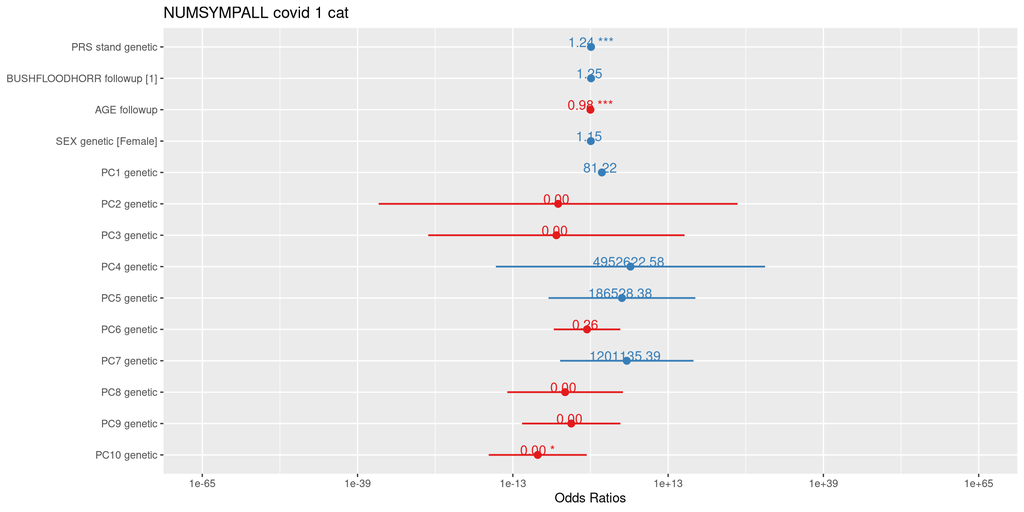

```r
plot_model(Twenty19BushFlood_PO,
           type = 'est',
           show.values = T)
```

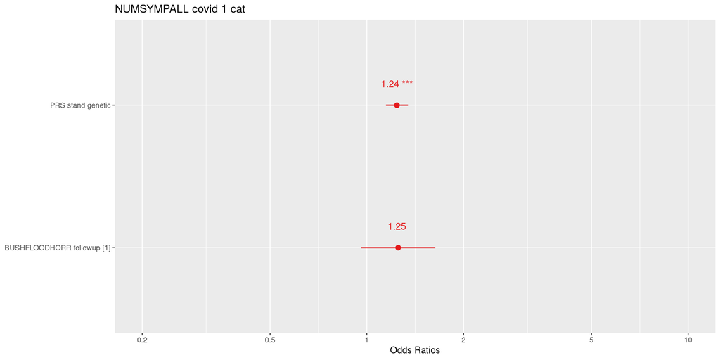

```r
plot_model(Twenty19BushFlood_PO,
           type = 'est',
           show.values = T,
           terms = c('PRS_stand_genetic', 'BUSHFLOODHORR_followup1'))
```

#### Female

##### Results

```r
summary(Twenty19BushFlood_female_PO)
```

```
##
## Call:
## VGAM::vglm(formula = NUMSYMPALL_covid1_cat ~ PRS_stand_genetic +
##     BUSHFLOODHORR_followup + AGE_followup + PC1_genetic + PC2_genetic +
##     PC3_genetic + PC4_genetic + PC5_genetic + PC6_genetic + PC7_genetic +
##     PC8_genetic + PC9_genetic + PC10_genetic, family = VGAM::cumulative(logitlink,
##     parallel = T, reverse = T), data = df_ND_covid[df_ND_covid$SEX_genetic ==
##     "Female", ])
##
## Coefficients:
##                           Estimate Std. Error z value Pr(>|z|)
## (Intercept):1             5.229935   1.288402   4.059 4.92e-05 ***
## (Intercept):2             3.294027   1.283763   2.566   0.0103 *
## (Intercept):3             1.622612   1.281662   1.266   0.2055
## PRS_stand_genetic         0.228757   0.046992   4.868 1.13e-06 ***
## BUSHFLOODHORR_followup1   0.224851   0.153922   1.461   0.1441
## AGE_followup             -0.020157   0.003166  -6.367 1.92e-10 ***
## PC1_genetic              11.105472  90.901315   0.122   0.9028
## PC2_genetic             -24.728487  39.145011  -0.632   0.5276
## PC3_genetic               9.547331  30.604133   0.312   0.7551
## PC4_genetic              33.507191  30.734896   1.090   0.2756
## PC5_genetic              21.326188  16.827111   1.267   0.2050
## PC6_genetic              -4.151719   7.477933  -0.555   0.5788
## PC7_genetic               3.204255  15.107843   0.212   0.8320
## PC8_genetic              -6.310570  13.204741  -0.478   0.6327
## PC9_genetic              -5.947570  11.176653  -0.532   0.5946
## PC10_genetic            -25.548795  11.206394  -2.280   0.0226 *
## ---
## Signif. codes:  0 '***' 0.001 '**' 0.01 '*' 0.05 '.' 0.1 ' ' 1
##
## Names of linear predictors: logitlink(P[Y>=2]), logitlink(P[Y>=3]),
## logitlink(P[Y>=4])
##
## Residual deviance: 3819.854 on 4766 degrees of freedom
##
## Log-likelihood: -1909.927 on 4766 degrees of freedom
##
## Number of Fisher scoring iterations: 5
##
##
## Exponentiated coefficients:
##       PRS_stand_genetic BUSHFLOODHORR_followup1            AGE_followup
##            1.257036e+00            1.252136e+00            9.800450e-01
##             PC1_genetic             PC2_genetic             PC3_genetic
##            6.653422e+04            1.822025e-11            1.400725e+04
##             PC4_genetic             PC5_genetic             PC6_genetic
##            3.564416e+14            1.827451e+09            1.573735e-02
##             PC7_genetic             PC8_genetic             PC9_genetic
##            2.463713e+01            1.816998e-03            2.612181e-03
##            PC10_genetic
##            8.022305e-12
```

```r
# Create nice summary of results, including back transformation to give OR and calculating 95% CI
CI <- as.data.frame(confint(Twenty19BushFlood_female_PO)) %>%
  rownames_to_column() %>%
  rename('lower_95_CI_of_beta' = "2.5 %",
         'upper_95_CI_of_beta' = "97.5 %") %>%
  mutate(lower_95_CI_of_OR = exp(lower_95_CI_of_beta),
         upper_95_CI_of_OR = exp(upper_95_CI_of_beta))

beta <- as.data.frame(coef(Twenty19BushFlood_female_PO)) %>%
  rownames_to_column() %>%
  rename("beta" = "coef(Twenty19BushFlood_female_PO)") %>%
  mutate(OR = exp(beta))

results <- beta %>%
  full_join(CI) %>%
  relocate(rowname, beta, lower_95_CI_of_beta, upper_95_CI_of_beta, OR, lower_95_CI_of_OR, upper_95_CI_of_OR)

results %>% kable()
```

| rowname | beta | lower_95_CI_of_beta | upper_95_CI_of_beta | OR | lower_95_CI_of_OR | upper_95_CI_of_OR |
| --- | --- | --- | --- | --- | --- | --- |
| (Intercept):1 | 5.2299353 | 2.7047146 | 7.7551559 | 1.867807e+02 | 14.9500497 | 2.333573e+03 |
| (Intercept):2 | 3.2940266 | 0.7778980 | 5.8101551 | 2.695117e+01 | 2.1768917 | 3.336709e+02 |
| (Intercept):3 | 1.6226120 | -0.8893995 | 4.1346236 | 5.066306e+00 | 0.4109024 | 6.246608e+01 |
| PRS_stand_genetic | 0.2287568 | 0.1366548 | 0.3208589 | 1.257036e+00 | 1.1464323 | 1.378311e+00 |
| BUSHFLOODHORR_followup1 | 0.2248510 | -0.0768305 | 0.5265326 | 1.252136e+00 | 0.9260468 | 1.693052e+00 |
| AGE_followup | -0.0201568 | -0.0263612 | -0.0139523 | 9.800450e-01 | 0.9739832 | 9.861445e-01 |
| PC1_genetic | 11.1054717 | -167.0578311 | 189.2687744 | 6.653422e+04 | 0.0000000 | 1.579008e+82 |
| PC2_genetic | -24.7284873 | -101.4512997 | 51.9943250 | 0.000000e+00 | 0.0000000 | 3.809329e+22 |
| PC3_genetic | 9.5473307 | -50.4356671 | 69.5303285 | 1.400725e+04 | 0.0000000 | 1.572671e+30 |
| PC4_genetic | 33.5071914 | -26.7320972 | 93.7464800 | 3.564416e+14 | 0.0000000 | 5.171053e+40 |
| PC5_genetic | 21.3261879 | -11.6543430 | 54.3067189 | 1.827451e+09 | 0.0000087 | 3.846877e+23 |
| PC6_genetic | -4.1517186 | -18.8081978 | 10.5047606 | 1.573730e-02 | 0.0000000 | 3.648880e+04 |
| PC7_genetic | 3.2042548 | -26.4065733 | 32.8150828 | 2.463713e+01 | 0.0000000 | 1.784060e+14 |
| PC8_genetic | -6.3105696 | -32.1913856 | 19.5702463 | 1.817000e-03 | 0.0000000 | 3.156821e+08 |
| PC9_genetic | -5.9475696 | -27.8534061 | 15.9582668 | 2.612200e-03 | 0.0000000 | 8.522897e+06 |
| PC10_genetic | -25.5487953 | -47.5129247 | -3.5846659 | 0.000000e+00 | 0.0000000 | 2.774590e-02 |

##### Plots

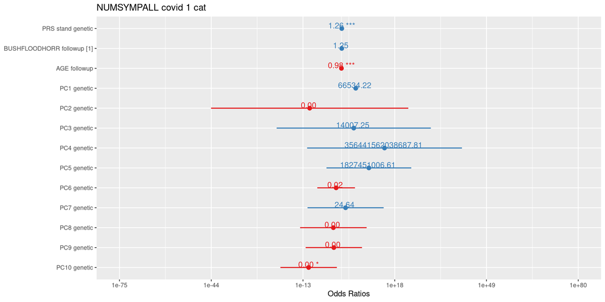

```r
plot_model(Twenty19BushFlood_female_PO,
           type = 'est',
           show.values = T)
```

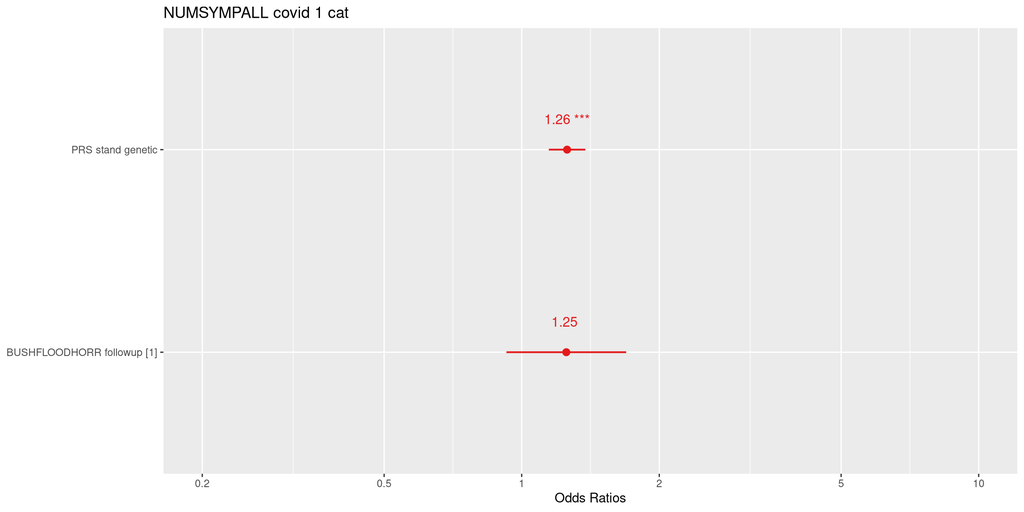

```r
plot_model(Twenty19BushFlood_female_PO,
           type = 'est',
           show.values = T,
           terms = c('PRS_stand_genetic', 'BUSHFLOODHORR_followup1'))
```

#### Male

##### Results

```r
summary(Twenty19BushFlood_male_PO)
```

```
##
## Call:
## VGAM::vglm(formula = NUMSYMPALL_covid1_cat ~ PRS_stand_genetic +
##     BUSHFLOODHORR_followup + AGE_followup + PC1_genetic + PC2_genetic +
##     PC3_genetic + PC4_genetic + PC5_genetic + PC6_genetic + PC7_genetic +
##     PC8_genetic + PC9_genetic + PC10_genetic, family = VGAM::cumulative(logitlink,
##     parallel = T, reverse = T), data = df_ND_covid[df_ND_covid$SEX_genetic ==
##     "Male", ])
##
## Coefficients:
##                           Estimate Std. Error z value Pr(>|z|)
## (Intercept):1             2.516977   2.176107   1.157   0.2474
## (Intercept):2             1.122103   2.173985   0.516   0.6057
## (Intercept):3            -0.479244   2.173301  -0.221   0.8255
## PRS_stand_genetic         0.181184   0.078266   2.315   0.0206 *
## BUSHFLOODHORR_followup1   0.231395   0.287154   0.806   0.4203
## AGE_followup             -0.024833   0.005758  -4.313 1.61e-05 ***
## PC1_genetic              -2.155067 145.325730  -0.015   0.9882
## PC2_genetic              10.706951  87.002013   0.123   0.9021
## PC3_genetic             -34.843630  49.207173  -0.708   0.4789
## PC4_genetic             -15.429967  55.060164  -0.280   0.7793
## PC5_genetic             -12.260710  28.422664  -0.431   0.6662
## PC6_genetic              11.715779  13.947047   0.840   0.4009
## PC7_genetic              43.775937  26.917686   1.626   0.1039
## PC8_genetic             -25.848578  22.715673  -1.138   0.2552
## PC9_genetic              -8.038346  19.693412  -0.408   0.6831
## PC10_genetic             -3.653182  19.198948  -0.190   0.8491
## ---
## Signif. codes:  0 '***' 0.001 '**' 0.01 '*' 0.05 '.' 0.1 ' ' 1
##
## Names of linear predictors: logitlink(P[Y>=2]), logitlink(P[Y>=3]),
## logitlink(P[Y>=4])
##
## Residual deviance: 1393.791 on 1622 degrees of freedom
##
## Log-likelihood: -696.8957 on 1622 degrees of freedom
##
## Number of Fisher scoring iterations: 6
##
##
## Exponentiated coefficients:
##       PRS_stand_genetic BUSHFLOODHORR_followup1            AGE_followup
##            1.198636e+00            1.260357e+00            9.754731e-01
##             PC1_genetic             PC2_genetic             PC3_genetic
##            1.158954e-01            4.466525e+04            7.372312e-16
##             PC4_genetic             PC5_genetic             PC6_genetic
##            1.989989e-07            4.734144e-06            1.224893e+05
##             PC7_genetic             PC8_genetic             PC9_genetic
##            1.027183e+19            5.944360e-12            3.228425e-04
##            PC10_genetic
##            2.590856e-02
```

```r
# Create nice summary of results, including back transformation to give OR and calculating 95% CI
CI <- as.data.frame(confint(Twenty19BushFlood_male_PO)) %>%
  rownames_to_column() %>%
  rename('lower_95_CI_of_beta' = "2.5 %",
         'upper_95_CI_of_beta' = "97.5 %") %>%
  mutate(lower_95_CI_of_OR = exp(lower_95_CI_of_beta),
         upper_95_CI_of_OR = exp(upper_95_CI_of_beta))

beta <- as.data.frame(coef(Twenty19BushFlood_male_PO)) %>%
  rownames_to_column() %>%
  rename("beta" = "coef(Twenty19BushFlood_male_PO)") %>%
  mutate(OR = exp(beta))

results <- beta %>%
  full_join(CI) %>%
  relocate(rowname, beta, lower_95_CI_of_beta, upper_95_CI_of_beta, OR, lower_95_CI_of_OR, upper_95_CI_of_OR)

results %>% kable()
```

| rowname | beta | lower_95_CI_of_beta | upper_95_CI_of_beta | OR | lower_95_CI_of_OR | upper_95_CI_of_OR |
| --- | --- | --- | --- | --- | --- | --- |
| (Intercept):1 | 2.5169772 | -1.7481145 | 6.7820689 | 1.239108e+01 | 0.1741019 | 8.818914e+02 |
| (Intercept):2 | 1.1221034 | -3.1388295 | 5.3830364 | 3.071308e+00 | 0.0433335 | 2.176822e+02 |
| (Intercept):3 | -0.4792437 | -4.7388350 | 3.7803475 | 6.192515e-01 | 0.0087488 | 4.383127e+01 |
| PRS_stand_genetic | 0.1811840 | 0.0277863 | 0.3345818 | 1.198636e+00 | 1.0281759 | 1.397356e+00 |
| BUSHFLOODHORR_followup1 | 0.2313954 | -0.3314153 | 0.7942061 | 1.260358e+00 | 0.7179069 | 2.212684e+00 |
| AGE_followup | -0.0248327 | -0.0361188 | -0.0135467 | 9.754731e-01 | 0.9645257 | 9.865446e-01 |
| PC1_genetic | -2.1550672 | -286.9882642 | 282.6781297 | 1.158954e-01 | 0.0000000 | 5.828434e+122 |
| PC2_genetic | 10.7069511 | -159.8138619 | 181.2277640 | 4.466525e+04 | 0.0000000 | 5.084144e+78 |
| PC3_genetic | -34.8436302 | -131.2879175 | 61.6006572 | 0.000000e+00 | 0.0000000 | 5.660118e+26 |
| PC4_genetic | -15.4299666 | -123.3459042 | 92.4859709 | 2.000000e-07 | 0.0000000 | 1.466043e+40 |
| PC5_genetic | -12.2607096 | -67.9681079 | 43.4466888 | 4.700000e-06 | 0.0000000 | 7.390217e+18 |
| PC6_genetic | 11.7157792 | -15.6199297 | 39.0514880 | 1.224893e+05 | 0.0000002 | 9.116870e+16 |
| PC7_genetic | 43.7759373 | -8.9817578 | 96.5336323 | 1.027183e+19 | 0.0001257 | 8.395061e+41 |
| PC8_genetic | -25.8485782 | -70.3704790 | 18.6733226 | 0.000000e+00 | 0.0000000 | 1.287422e+08 |
| PC9_genetic | -8.0383460 | -46.6367247 | 30.5600326 | 3.228000e-04 | 0.0000000 | 1.870913e+13 |
| PC10_genetic | -3.6531820 | -41.2824285 | 33.9760645 | 2.590860e-02 | 0.0000000 | 5.696621e+14 |

##### Plots

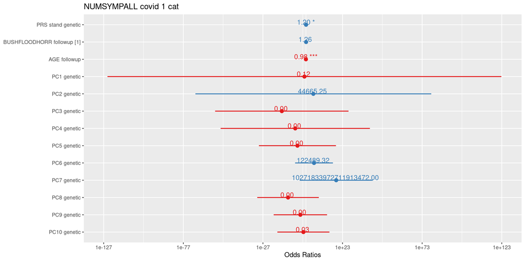

```r
plot_model(Twenty19BushFlood_male_PO,
           type = 'est',
           show.values = T)
```

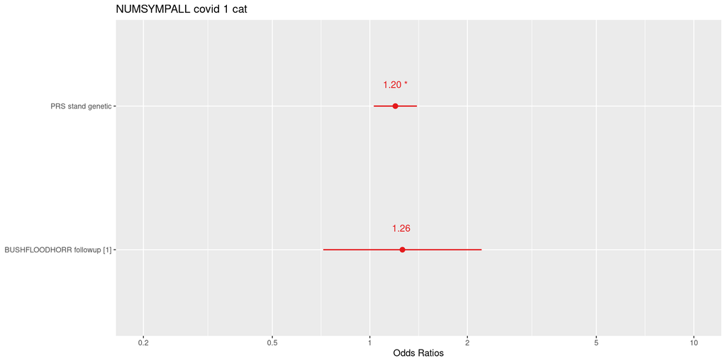

```r
plot_model(Twenty19BushFlood_male_PO,
           type = 'est',
           show.values = T,
           terms = c('PRS_stand_genetic', 'BUSHFLOODHORR_followup1'))
```

#### Female vs Male

- ‘A sex-stratified analysis followed by a Zscore difference test (Eq. 1) is equivalent to a formal test for G×S interaction when there is no interaction between covariates and the strata, and the trait variance are equivalent in the two strata.’ (Blokland et al., 2022)
- Conduct a Z test for the difference between the coefficients of females and males

```r
female_beta <- coef(summary(Twenty19BushFlood_female_PO))["BUSHFLOODHORR_followup1", "Estimate"]
female_SE <- coef(summary(Twenty19BushFlood_female_PO))["BUSHFLOODHORR_followup1", "Std. Error"]
male_beta <- coef(summary(Twenty19BushFlood_male_PO))["BUSHFLOODHORR_followup1", "Estimate"]
male_SE <- coef(summary(Twenty19BushFlood_male_PO))["BUSHFLOODHORR_followup1", "Std. Error"]

Z <- (female_beta - male_beta) / sqrt((female_SE)^2 + (male_SE)^2)
p <- 2 * pnorm(abs(Z), mean = 0, sd = 1, lower.tail = FALSE)

message <- sprintf("Association of horrible 2019 bushfires/floods experience on no. symptoms currenlty (1 year later) in females compared to males, Z = %.6f, p = %.6f", Z, p)
print(message)
```

```
## [1] "Association of horrible 2019 bushfires/floods experience on no. symptoms currenlty (1 year later) in females compared to males, Z = -0.020087, p = 0.983974"
```

# COVID (current depression)

- COVID (wave 1 and 2 combined):
  - yes = if yes to covid wave 1 and/or 2
  - no = if no to both covid wave 1 and 2
- NUMSYMPALL from covid wave 2 survey

## Explore

### Sample size

```r
df_ND_covid %>%
  drop_na(NUMSYMPALL_covid2, SEX_genetic, AGE_covid2, matches("^PC.*_genetic$"), COVIDALLBIN_C1C2, PRS_stand_genetic) %>%
  count(COVIDALLBIN_C1C2) %>%
  kable(caption = "No. participants that experienced any frightening, horrible or traumatic experiences related to COVID \n Yes = yes to covid wave 1 and/or wave 2, No = No in wave 1 and wave 2")
```

No. participants that experienced any frightening, horrible or traumatic experiences related to COVID Yes = yes to covid wave 1 and/or wave 2, No = No in wave 1 and wave 2

| COVIDALLBIN_C1C2 | n |
| --- | --- |
| 0 | 2407 |
| 1 | 1076 |

```r
df_ND_covid %>%
  drop_na(NUMSYMPALL_covid2, SEX_genetic, AGE_covid2, matches("^PC.*_genetic$"), COVIDALLBIN_C1C2, PRS_stand_genetic) %>%
  filter(SEX_genetic == "Female") %>%
  count(COVIDALLBIN_C1C2) %>%
  kable(caption = "No. female participants that experienced any frightening, horrible or traumatic experiences related to COVID \n Yes = yes to covid wave 1 and/or wave 2, No = No in wave 1 and wave 2")
```

No. female participants that experienced any frightening, horrible or traumatic experiences related to COVID Yes = yes to covid wave 1 and/or wave 2, No = No in wave 1 and wave 2

| COVIDALLBIN_C1C2 | n |
| --- | --- |
| 0 | 1767 |
| 1 | 876 |

```r
df_ND_covid %>%
  drop_na(NUMSYMPALL_covid2, SEX_genetic, AGE_covid2, matches("^PC.*_genetic$"), COVIDALLBIN_C1C2, PRS_stand_genetic) %>%
  filter(SEX_genetic == "Male") %>%
  count(COVIDALLBIN_C1C2) %>%
  kable(caption = "No. male participants that experienced any frightening, horrible or traumatic experiences related to COVID \n Yes = yes to covid wave 1 and/or wave 2, No = No in wave 1 and wave 2")
```

No. male participants that experienced any frightening, horrible or traumatic experiences related to COVID Yes = yes to covid wave 1 and/or wave 2, No = No in wave 1 and wave 2

| COVIDALLBIN_C1C2 | n |
| --- | --- |
| 0 | 640 |
| 1 | 200 |

### Distribution

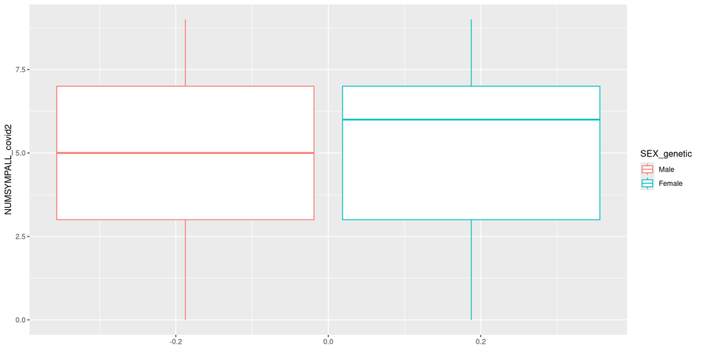

```r
ggplot(df_ND_covid[!is.na(df_ND_covid$NUMSYMPALL_covid2) & !is.na(df_ND_covid$SEX_genetic),],
             aes(y = NUMSYMPALL_covid2, colour = SEX_genetic)) +
  geom_boxplot()
```

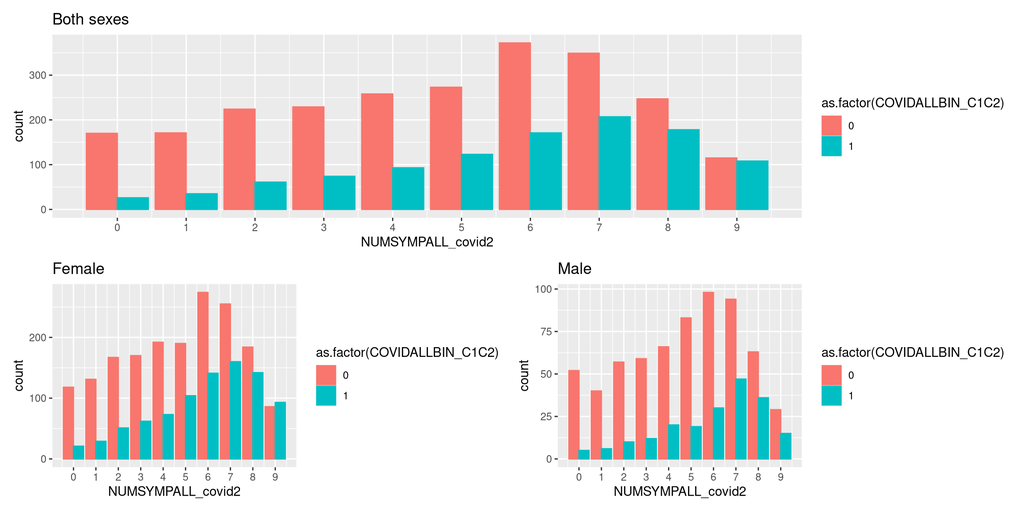

```r
p1 <- ggplot(df_ND_covid[!is.na(df_ND_covid$NUMSYMPALL_covid2) &
                           !is.na(df_ND_covid$SEX_genetic) &
                           !is.na(df_ND_covid$COVIDALLBIN_C1C2), ],
             aes (x = NUMSYMPALL_covid2, colour = as.factor(COVIDALLBIN_C1C2), fill = as.factor(COVIDALLBIN_C1C2))) +
  geom_bar(position = "dodge") +
  scale_x_continuous(breaks = c(0,1,2,3,4,5,6,7,8,9)) +
  ggtitle("Both sexes")

p2 <- ggplot(df_ND_covid[!is.na(df_ND_covid$NUMSYMPALL_covid2) &
                           !is.na(df_ND_covid$SEX_genetic) &
                           (df_ND_covid$SEX_genetic == "Female") &
                           !is.na(df_ND_covid$COVIDALLBIN_C1C2), ],
             aes (x = NUMSYMPALL_covid2, colour = as.factor(COVIDALLBIN_C1C2), fill = as.factor(COVIDALLBIN_C1C2))) +
  geom_bar(position = "dodge") +
  scale_x_continuous(breaks = c(0,1,2,3,4,5,6,7,8,9)) +
  ggtitle("Female")

p3 <- ggplot(df_ND_covid[!is.na(df_ND_covid$NUMSYMPALL_covid2) &
                           !is.na(df_ND_covid$SEX_genetic) &
                           (df_ND_covid$SEX_genetic == "Male") &
                           !is.na(df_ND_covid$COVIDALLBIN_C1C2), ],
             aes (x = NUMSYMPALL_covid2, colour = as.factor(COVIDALLBIN_C1C2), fill = as.factor(COVIDALLBIN_C1C2))) +
  geom_bar(position = "dodge") +
  scale_x_continuous(breaks = c(0,1,2,3,4,5,6,7,8,9)) +
  ggtitle("Male")

p1 / (p2 | p3)
```

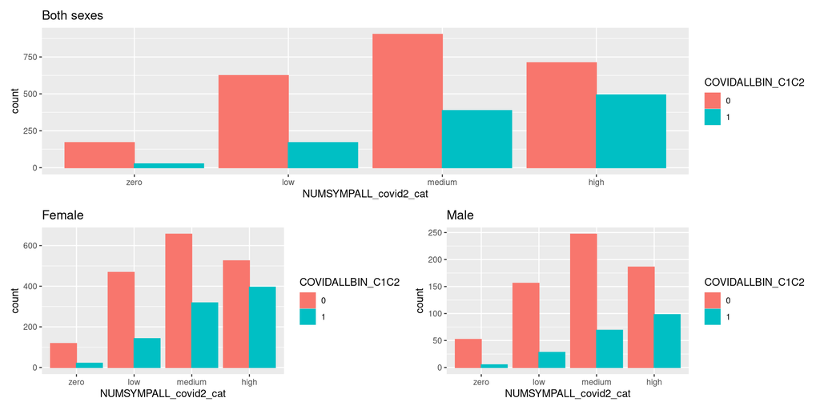

```r
p1 <- ggplot(df_ND_covid[!is.na(df_ND_covid$NUMSYMPALL_covid2_cat) &
                           !is.na(df_ND_covid$SEX_genetic) &
                           !is.na(df_ND_covid$COVIDALLBIN_C1C2), ],
             aes (x = NUMSYMPALL_covid2_cat, colour = COVIDALLBIN_C1C2, fill = COVIDALLBIN_C1C2)) +
  geom_bar(position = "dodge") +
  ggtitle("Both sexes")

p2 <- ggplot(df_ND_covid[!is.na(df_ND_covid$NUMSYMPALL_covid2_cat) &
                           !is.na(df_ND_covid$SEX_genetic) &
                           (df_ND_covid$SEX_genetic == "Female") &
                           !is.na(df_ND_covid$COVIDALLBIN_C1C2), ],
             aes (x = NUMSYMPALL_covid2_cat, colour = COVIDALLBIN_C1C2, fill = COVIDALLBIN_C1C2)) +
  geom_bar(position = "dodge") +
  ggtitle("Female")

p3 <- ggplot(df_ND_covid[!is.na(df_ND_covid$NUMSYMPALL_covid2_cat) &
                           !is.na(df_ND_covid$SEX_genetic) &
                           (df_ND_covid$SEX_genetic == "Male") &
                           !is.na(df_ND_covid$COVIDALLBIN_C1C2), ],
             aes (x = NUMSYMPALL_covid2_cat, colour = COVIDALLBIN_C1C2, fill = COVIDALLBIN_C1C2)) +
  geom_bar(position = "dodge") +
  ggtitle("Male")

p1 / (p2 | p3)
```

### Covid exposure

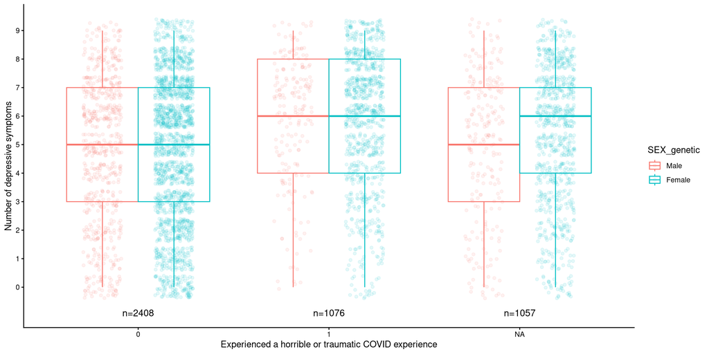

```r
ggplot(df_ND_covid[!is.na(df_ND_covid$SEX_genetic),], aes(x = as.factor(COVIDALLBIN_C1C2), y = NUMSYMPALL_covid2, colour = SEX_genetic)) +
  geom_boxplot(position = position_dodge(width = 0.75)) +
  geom_point(position = position_jitterdodge(dodge.width = 0.75, jitter.width = 0.4, jitter.height = 0.4), alpha = 0.1) +
  stat_n_text() +
  labs(x = "Experienced a horrible or traumatic COVID experience",
       y = "Number of depressive symptoms") +
  theme(axis.text.x = element_text(angle = 45, vjust = 1, hjust=1)) +
  scale_y_continuous(breaks = c(0,1,2,3,4,5,6,7,8,9)) +
  theme_classic()
```

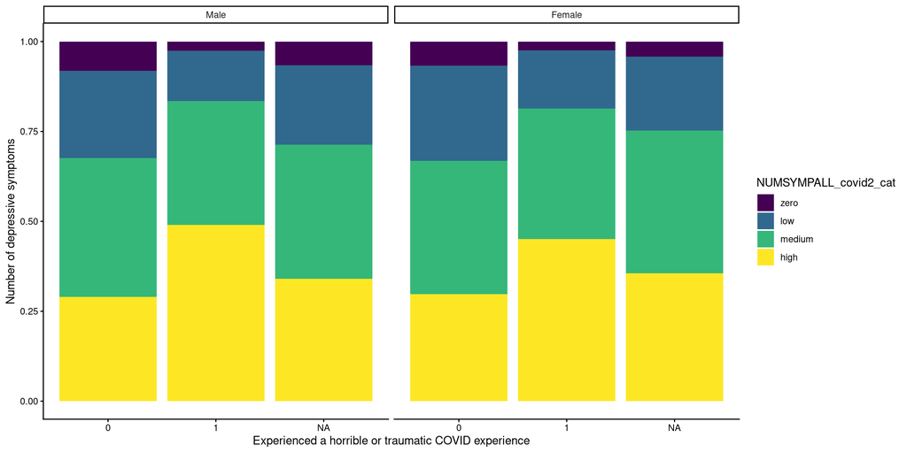

```r
ggplot(df_ND_covid[!is.na(df_ND_covid$SEX_genetic) & !is.na(df_ND_covid$NUMSYMPALL_covid2_cat),], aes(x = as.factor(COVIDALLBIN_C1C2), fill = NUMSYMPALL_covid2_cat)) +
  geom_bar(position = "fill") +
  # stat_n_text() +
  labs(x = "Experienced a horrible or traumatic COVID experience",
       y = "Number of depressive symptoms") +
  facet_wrap(~ SEX_genetic) +
  theme(axis.text.x = element_text(angle = 45, vjust = 1, hjust=1)) +
  theme_classic()
```

## Fit Models

### Proportional Odds

```r
Covid_PO <- VGAM::vglm(NUMSYMPALL_covid2_cat ~
                                PRS_stand_genetic +
                                COVIDALLBIN_C1C2 +
                                AGE_covid2 +
                                SEX_genetic +
                                PC1_genetic +
                                PC2_genetic +
                                PC3_genetic +
                                PC4_genetic +
                         PC5_genetic +
                         PC6_genetic +
                         PC7_genetic +
                         PC8_genetic +
                         PC9_genetic +
                         PC10_genetic,
                              family = VGAM::cumulative(logitlink, parallel = T, reverse = T), # with PO (package pammtools masks VGAM cumulative so specify from VGAM)
                              data = df_ND_covid)


Covid_female_PO <- VGAM::vglm(NUMSYMPALL_covid2_cat ~
                                            PRS_stand_genetic +
                                            COVIDALLBIN_C1C2 +
                                            AGE_covid2 +
                                            PC1_genetic +
                                            PC2_genetic +
                                            PC3_genetic +
                                            PC4_genetic +
                                PC5_genetic +
                                PC6_genetic +
                                PC7_genetic +
                                PC8_genetic +
                                PC9_genetic +
                                PC10_genetic,
                                          family = VGAM::cumulative(logitlink, parallel = T, reverse = T), # with PO (package pammtools masks VGAM cumulative so specify from VGAM)
                                          data = df_ND_covid[df_ND_covid$SEX_genetic == "Female", ])

Covid_male_PO <- VGAM::vglm(NUMSYMPALL_covid2_cat ~
                                          PRS_stand_genetic +
                                          COVIDALLBIN_C1C2 +
                                          AGE_covid2 +
                                          PC1_genetic +
                                          PC2_genetic +
                                          PC3_genetic +
                                          PC4_genetic +
                              PC5_genetic +
                              PC6_genetic +
                              PC7_genetic +
                              PC8_genetic +
                              PC9_genetic +
                              PC10_genetic,
                                        family = VGAM::cumulative(logitlink, parallel = T, reverse = T), # with PO (package pammtools masks VGAM cumulative so specify from VGAM)
                                        data = df_ND_covid[df_ND_covid$SEX_genetic == "Male", ])
```

### Partial Proportional Odds

```r
Covid_PartPO_NDexpos <- VGAM::vglm(NUMSYMPALL_covid2_cat ~
                                            PRS_stand_genetic +
                                            COVIDALLBIN_C1C2 +
                                            AGE_covid2 +
                                            SEX_genetic +
                                            PC1_genetic +
                                            PC2_genetic +
                                            PC3_genetic +
                                            PC4_genetic +
                                     PC5_genetic +
                                     PC6_genetic +
                                     PC7_genetic +
                                     PC8_genetic +
                                     PC9_genetic +
                                     PC10_genetic,
                                          family = VGAM::cumulative(logitlink, parallel = F ~ COVIDALLBIN_C1C2, reverse = T), # with PO (package pammtools masks VGAM cumulative so specify from VGAM)
                                          data = df_ND_covid)

Covid_PartPO_PRS <- VGAM::vglm(NUMSYMPALL_covid2_cat ~
                                        PRS_stand_genetic +
                                        COVIDALLBIN_C1C2 +
                                        AGE_covid2 +
                                        SEX_genetic +
                                        PC1_genetic +
                                        PC2_genetic +
                                        PC3_genetic +
                                        PC4_genetic +
                                 PC5_genetic +
                                 PC6_genetic +
                                 PC7_genetic +
                                 PC8_genetic +
                                 PC9_genetic +
                                 PC10_genetic,
                                      family = VGAM::cumulative(logitlink, parallel = F ~ PRS_stand_genetic, reverse = T), # with PO (package pammtools masks VGAM cumulative so specify from VGAM)
                                      data = df_ND_covid)

Covid_PartPO_NDexpos_PRS <- VGAM::vglm(NUMSYMPALL_covid2_cat ~
                                                PRS_stand_genetic +
                                                COVIDALLBIN_C1C2 +
                                                AGE_covid2 +
                                                SEX_genetic +
                                                PC1_genetic +
                                                PC2_genetic +
                                                PC3_genetic +
                                                PC4_genetic +
                                         PC5_genetic +
                                         PC6_genetic +
                                         PC7_genetic +
                                         PC8_genetic +
                                         PC9_genetic +
                                         PC10_genetic,
                                              family = VGAM::cumulative(logitlink, parallel = F ~ COVIDALLBIN_C1C2 + PRS_stand_genetic, reverse = T), # with PO (package pammtools masks VGAM cumulative so specify from VGAM)
                                              data = df_ND_covid)


Covid_female_PartPO_NDexpos <- VGAM::vglm(NUMSYMPALL_covid2_cat ~
                                                        PRS_stand_genetic +
                                                        COVIDALLBIN_C1C2 +
                                                        AGE_covid2 +
                                                        PC1_genetic +
                                                        PC2_genetic +
                                                        PC3_genetic +
                                                        PC4_genetic +
                                            PC5_genetic +
                                            PC6_genetic +
                                            PC7_genetic +
                                            PC8_genetic +
                                            PC9_genetic +
                                            PC10_genetic,
                                                      family = VGAM::cumulative(logitlink, parallel = F ~ COVIDALLBIN_C1C2, reverse = T), # with PO (package pammtools masks VGAM cumulative so specify from VGAM)
                                                      data = df_ND_covid[df_ND_covid$SEX_genetic == "Female", ])

Covid_female_PartPO_PRS <- VGAM::vglm(NUMSYMPALL_covid2_cat ~
                                                    PRS_stand_genetic +
                                                    COVIDALLBIN_C1C2 +
                                                    AGE_covid2 +
                                                    PC1_genetic +
                                                    PC2_genetic +
                                                    PC3_genetic +
                                                    PC4_genetic +
                                        PC5_genetic +
                                        PC6_genetic +
                                        PC7_genetic +
                                        PC8_genetic +
                                        PC9_genetic +
                                        PC10_genetic,
                                                  family = VGAM::cumulative(logitlink, parallel = F ~ PRS_stand_genetic, reverse = T), # with PO (package pammtools masks VGAM cumulative so specify from VGAM)
                                                  data = df_ND_covid[df_ND_covid$SEX_genetic == "Female", ])

Covid_female_PartPO_NDexpos_PRS <- VGAM::vglm(NUMSYMPALL_covid2_cat ~
                                                            PRS_stand_genetic +
                                                            COVIDALLBIN_C1C2 +
                                                            AGE_covid2 +
                                                            PC1_genetic +
                                                            PC2_genetic +
                                                            PC3_genetic +
                                                            PC4_genetic +
                                                PC5_genetic +
                                                PC6_genetic +
                                                PC7_genetic +
                                                PC8_genetic +
                                                PC9_genetic +
                                                PC10_genetic,
                                                          family = VGAM::cumulative(logitlink, parallel = F ~ COVIDALLBIN_C1C2 + PRS_stand_genetic, reverse = T), # with PO (package pammtools masks VGAM cumulative so specify from VGAM)
                                                          data = df_ND_covid[df_ND_covid$SEX_genetic == "Female", ])

Covid_male_PartPO_NDexpos <- VGAM::vglm(NUMSYMPALL_covid2_cat ~
                                                      PRS_stand_genetic +
                                                      COVIDALLBIN_C1C2 +
                                                      AGE_covid2 +
                                                      PC1_genetic +
                                                      PC2_genetic +
                                                      PC3_genetic +
                                                      PC4_genetic +
                                          PC5_genetic +
                                          PC6_genetic +
                                          PC7_genetic +
                                          PC8_genetic +
                                          PC9_genetic +
                                          PC10_genetic,
                                                    family = VGAM::cumulative(logitlink, parallel = F ~ COVIDALLBIN_C1C2, reverse = T), # with PO (package pammtools masks VGAM cumulative so specify from VGAM)
                                                    data = df_ND_covid[df_ND_covid$SEX_genetic == "Male", ])

Covid_male_PartPO_PRS <- VGAM::vglm(NUMSYMPALL_covid2_cat ~
                                                  PRS_stand_genetic +
                                                  COVIDALLBIN_C1C2 +
                                                  AGE_covid2 +
                                                  PC1_genetic +
                                                  PC2_genetic +
                                                  PC3_genetic +
                                                  PC4_genetic +
                                      PC5_genetic +
                                      PC6_genetic +
                                      PC7_genetic +
                                      PC8_genetic +
                                      PC9_genetic +
                                      PC10_genetic,
                                                family = VGAM::cumulative(logitlink, parallel = F ~ PRS_stand_genetic, reverse = T), # with PO (package pammtools masks VGAM cumulative so specify from VGAM)
                                                data = df_ND_covid[df_ND_covid$SEX_genetic == "Male", ])

Covid_male_PartPO_NDexpos_PRS <- VGAM::vglm(NUMSYMPALL_covid2_cat ~
                                                          PRS_stand_genetic +
                                                          COVIDALLBIN_C1C2 +
                                                          AGE_covid2 +
                                                          PC1_genetic +
                                                          PC2_genetic +
                                                          PC3_genetic +
                                                          PC4_genetic +
                                              PC5_genetic +
                                              PC6_genetic +
                                              PC7_genetic +
                                              PC8_genetic +
                                              PC9_genetic +
                                              PC10_genetic,
                                                        family = VGAM::cumulative(logitlink, parallel = F ~ COVIDALLBIN_C1C2 + PRS_stand_genetic, reverse = T), # with PO (package pammtools masks VGAM cumulative so specify from VGAM)
                                                        data = df_ND_covid[df_ND_covid$SEX_genetic == "Male", ])
```

## Check Models

### Proportional Odds

#### Both Sexes

```r
### Test goodness of fit ###

# lipsitz test
lipsitz(Covid_PO)
```

```
##
## Lipsitz Test:
##
##                       LR   df   pr(>chi)
## ordinal(lipsitz)  9.4414    9     0.3976
##
## H0: No lack of fit dictated
```

```r
# pulkstenis-robinson test
# (requires the vector of categorical input variables as an argument)
pulkroben(Covid_PO, test = c("chisq","deviance"), tables = FALSE)
```

```
##
## Pulkstenis-Robinson Chi-squared Test:
##
##                     chi-sq   df   pr(>chi)
## ordinal(pulkroben)  28.464   18    0.05533 .
## ---
## Signif. codes:  0 '***' 0.001 '**' 0.01 '*' 0.05 '.' 0.1 ' ' 1
##
## H0: No lack of fit dictated
##
## rho: 100%
```

```r
# Hosmer-Lemeshow test
hosmerlem(Covid_PO)
```

```
##
## Hosmer-Lemeshow Test:
##
##                     Chi-sq  df  pr(>chi)
## ordinal(Hosmerlem)  34.234  26    0.1292
##
## H0: No lack of fit dictated
##
## rho: 100%
```

```r
### Test proportional odds assumption ###

# Brant Wald Test
# A generalized ordinal logistic regression model is approximated and compared to the calculated proportional odds model (a generalized ordinal logistic regression model is simply a relaxing of the proportional odds model to allow for different coefficients at each level of the ordinal outcome variable.)
# A Wald test is a hypothesis test of the significance of the difference in model coefficients, producing a chi-square statistic. A low p-value in a Brant-Wald test is an indicator that the coefficient does not satisfy the proportional odds assumption.
# A p-value of less than 0.05 on this test, particularly on the Omnibus plus at least one of the variables should be interpreted as a failure of the proportional odds assumption.

brant.test(Covid_PO)
```

```
##
## Brant Test:
##                      chi-sq   df   pr(>chi)
## Omnibus              49.459   28     0.0074 **
## PRS_stand_genetic     2.294    2     0.3176
## COVIDALLBIN_C1C21     2.036    2     0.3614
## AGE_covid2           11.157    2     0.0038 **
## SEX_geneticFemale     1.074    2     0.5846
## PC1_genetic           1.126    2     0.5696
## PC2_genetic           0.071    2     0.9652
## PC3_genetic           4.507    2     0.1050
## PC4_genetic           1.354    2     0.5081
## PC5_genetic           0.089    2     0.9563
## PC6_genetic           2.043    2     0.3601
## PC7_genetic           2.969    2     0.2266
## PC8_genetic           6.713    2     0.0349 *
## PC9_genetic           1.473    2     0.4788
## PC10_genetic          0.789    2     0.6741
## ---
## Signif. codes:  0 '***' 0.001 '**' 0.01 '*' 0.05 '.' 0.1 ' ' 1
##
## H0: Proportional odds assumption holds
```

```r
# Sighting coefficients of stratified binomial models - want each to be similar
# create binary variables for every combo of the 3 categories
x <- df_ND_covid %>%
  mutate(SYMPzeroplus = case_when(
    NUMSYMPALL_covid2_cat == 'zero' ~ 0,
    NUMSYMPALL_covid2_cat == 'low' | NUMSYMPALL_covid2_cat == 'med' | NUMSYMPALL_covid2_cat == 'high' ~ 1
  ),
  SYMPlowplus = case_when(
    NUMSYMPALL_covid2_cat == 'zero' | NUMSYMPALL_covid2_cat == 'low' ~ 0,
    NUMSYMPALL_covid2_cat == 'medium' |  NUMSYMPALL_covid2_cat == 'high' ~ 1),
  SYMPmedplus = case_when(
    NUMSYMPALL_covid2_cat == 'zero' | NUMSYMPALL_covid2_cat == 'low' | NUMSYMPALL_covid2_cat == 'medium' ~ 0,
    NUMSYMPALL_covid2_cat == 'high' ~ 1)
  )


# Create logistic regression for each
zeroplus_model <- glm(SYMPzeroplus ~
                        PRS_stand_genetic +
                        COVIDALLBIN_C1C2 +
                        AGE_covid2 +
                        SEX_genetic +
                        PC1_genetic +
                        PC2_genetic +
                        PC3_genetic +
                        PC4_genetic +
                        PC5_genetic +
                        PC6_genetic +
                        PC7_genetic +
                        PC8_genetic +
                        PC9_genetic +
                        PC10_genetic,
                      family = binomial(link = 'logit'),
                      data = x)

lowplus_model <- glm(SYMPlowplus ~
                       PRS_stand_genetic +
                       COVIDALLBIN_C1C2 +
                       AGE_covid2 +
                       SEX_genetic +
                       PC1_genetic +
                       PC2_genetic +
                       PC3_genetic +
                       PC4_genetic +
                       PC5_genetic +
                       PC6_genetic +
                       PC7_genetic +
                       PC8_genetic +
                       PC9_genetic +
                       PC10_genetic,
                     family = binomial(link = 'logit'),
                     data = x)

medplus_model <- glm(SYMPmedplus ~
                       PRS_stand_genetic +
                       COVIDALLBIN_C1C2 +
                       AGE_covid2 +
                       SEX_genetic +
                       PC1_genetic +
                       PC2_genetic +
                       PC3_genetic +
                       PC4_genetic +
                       PC5_genetic +
                       PC6_genetic +
                       PC7_genetic +
                       PC8_genetic +
                       PC9_genetic +
                       PC10_genetic,
                     family = binomial(link = 'logit'),
                     data = x)


# display the coefficients of all models and examine the difference between them.
# coefficients (i.e. the slopes) should be similar for all models to hold the proportional odds assumption

# table
coeffs <- data.frame(
  'ordinal' = coef(Covid_PO)[-c(1,2,3)],
  'binary zero vs low and med and high' = lowplus_model$coefficients[-1],
  'binary zero and low vs med and high' = lowplus_model$coefficients[-1],
  'binary zero and low and med vs high' = medplus_model$coefficients[-1])

coeffs %>%
  kable()
```

|  | ordinal | binary.zero.vs.low.and.med.and.high | binary.zero.and.low.vs.med.and.high | binary.zero.and.low.and.med.vs.high |
| --- | --- | --- | --- | --- |
| PRS_stand_genetic | 0.1980961 | 0.1783914 | 0.1783914 | 0.1987493 |
| COVIDALLBIN_C1C21 | 0.6806741 | 0.7239185 | 0.7239185 | 0.6453094 |
| AGE_covid2 | -0.0220528 | -0.0228130 | -0.0228130 | -0.0200147 |
| SEX_geneticFemale | -0.1558834 | -0.1914667 | -0.1914667 | -0.1397039 |
| PC1_genetic | 137.5735695 | 185.6178313 | 185.6178313 | 122.2444603 |
| PC2_genetic | 29.8097088 | 30.3750833 | 30.3750833 | 26.5023753 |
| PC3_genetic | -1.9038752 | 12.5008339 | 12.5008339 | -6.5563472 |
| PC4_genetic | 22.3703447 | 35.3856231 | 35.3856231 | 12.4377088 |
| PC5_genetic | -4.8797785 | -4.0154901 | -4.0154901 | -0.5327783 |
| PC6_genetic | 3.3003348 | -1.3032056 | -1.3032056 | 7.4306279 |
| PC7_genetic | -5.7590441 | -2.7361764 | -2.7361764 | -4.5795985 |
| PC8_genetic | -7.1525319 | 4.3106491 | 4.3106491 | -19.5138267 |
| PC9_genetic | 12.4638050 | 13.3843797 | 13.3843797 | 8.7247377 |
| PC10_genetic | -1.0261019 | 4.0157093 | 4.0157093 | -3.1448016 |

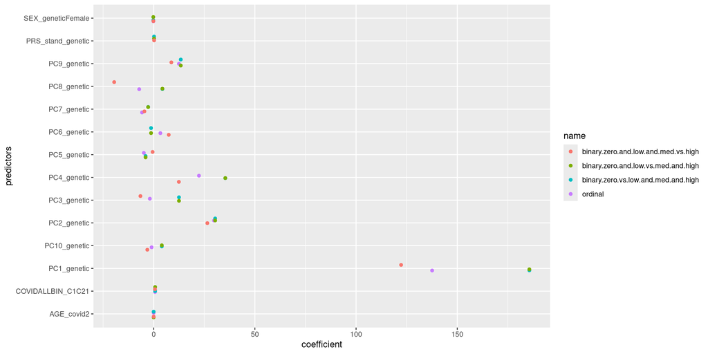

```r
coeffs2 <- coeffs %>%
  rownames_to_column() %>%
  pivot_longer(cols = 2:5)

ggplot(coeffs2, aes(x = value, y = rowname, group = name, colour = name)) +
  geom_jitter(height = 0.2) +
  labs(x = "coefficient", y = "predictors")
```

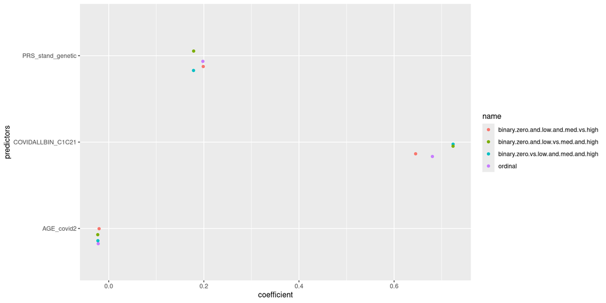

```r
coeffs3 <- coeffs2 %>%
  filter(rowname == 'PRS_stand_genetic' | rowname == 'COVIDALLBIN_C1C21' | rowname == "AGE_covid2")

ggplot(coeffs3, aes(x = value, y = rowname, group = name, colour = name)) +
  geom_jitter(height = 0.2) +
  labs(x = "coefficient", y = "predictors")
```

- Goodness of fit bad in one of the tests
- Brant test shows proportional odds assumption violated for age
- But visual inspection shows PO looks good

#### Female

```r
### Test goodness of fit ###

# lipsitz test
lipsitz(Covid_female_PO)
```

```
##
## Lipsitz Test:
##
##                       LR   df   pr(>chi)
## ordinal(lipsitz)  8.2961    9     0.5046
##
## H0: No lack of fit dictated
```

```r
# pulkstenis-robinson test
# (requires the vector of categorical input variables as an argument)
pulkroben(Covid_female_PO, test = c("chisq","deviance"), tables = FALSE)
```

```
##
## Pulkstenis-Robinson Chi-squared Test:
##
##                     chi-sq   df   pr(>chi)
## ordinal(pulkroben)  18.744    7   0.009029 **
## ---
## Signif. codes:  0 '***' 0.001 '**' 0.01 '*' 0.05 '.' 0.1 ' ' 1
##
## H0: No lack of fit dictated
##
## rho: 100%
```

```r
# Hosmer-Lemeshow test
hosmerlem(Covid_female_PO)
```

```
##
## Hosmer-Lemeshow Test:
##
##                     Chi-sq  df  pr(>chi)
## ordinal(Hosmerlem)  28.293  26    0.3442
##
## H0: No lack of fit dictated
##
## rho: 100%
```

```r
### Test proportional odds assumption ###

# Brant Wald Test
# A generalized ordinal logistic regression model is approximated and compared to the calculated proportional odds model (a generalized ordinal logistic regression model is simply a relaxing of the proportional odds model to allow for different coefficients at each level of the ordinal outcome variable.)
# A Wald test is a hypothesis test of the significance of the difference in model coefficients, producing a chi-square statistic. A low p-value in a Brant-Wald test is an indicator that the coefficient does not satisfy the proportional odds assumption.
# A p-value of less than 0.05 on this test, particularly on the Omnibus plus at least one of the variables should be interpreted as a failure of the proportional odds assumption.

brant.test(Covid_female_PO)
```

```
##
## Brant Test:
##                      chi-sq   df   pr(>chi)
## Omnibus              42.243   26     0.0232 *
## PRS_stand_genetic     0.343    2     0.8425
## COVIDALLBIN_C1C21     1.816    2     0.4033
## AGE_covid2           13.489    2     0.0012 **
## PC1_genetic           1.109    2     0.5742
## PC2_genetic           0.232    2     0.8905
## PC3_genetic           5.762    2     0.0561 .
## PC4_genetic           0.661    2     0.7187
## PC5_genetic           0.606    2     0.7386
## PC6_genetic           1.452    2     0.4839
## PC7_genetic           1.426    2     0.4902
## PC8_genetic           3.568    2     0.1680
## PC9_genetic           1.582    2     0.4533
## PC10_genetic          0.745    2     0.6890
## ---
## Signif. codes:  0 '***' 0.001 '**' 0.01 '*' 0.05 '.' 0.1 ' ' 1
##
## H0: Proportional odds assumption holds
```

```r
# Sighting coefficients of stratified binomial models - want each to be similar
# create binary variables for every combo of the 3 categories
x <- df_ND_covid %>%
  mutate(SYMPzeroplus = case_when(
    NUMSYMPALL_covid2_cat == 'zero' ~ 0,
    NUMSYMPALL_covid2_cat == 'low' | NUMSYMPALL_covid2_cat == 'med' | NUMSYMPALL_covid2_cat == 'high' ~ 1
  ),
  SYMPlowplus = case_when(
    NUMSYMPALL_covid2_cat == 'zero' | NUMSYMPALL_covid2_cat == 'low' ~ 0,
    NUMSYMPALL_covid2_cat == 'medium' |  NUMSYMPALL_covid2_cat == 'high' ~ 1),
  SYMPmedplus = case_when(
    NUMSYMPALL_covid2_cat == 'zero' | NUMSYMPALL_covid2_cat == 'low' | NUMSYMPALL_covid2_cat == 'medium' ~ 0,
    NUMSYMPALL_covid2_cat == 'high' ~ 1)
  )


# Create logistic regression for each
zeroplus_model <- glm(SYMPzeroplus ~
                        PRS_stand_genetic +
                        COVIDALLBIN_C1C2 +
                        AGE_covid2 +
                        PC1_genetic +
                        PC2_genetic +
                        PC3_genetic +
                        PC4_genetic +
                        PC5_genetic +
                        PC6_genetic +
                        PC7_genetic +
                        PC8_genetic +
                        PC9_genetic +
                        PC10_genetic,
                      family = binomial(link = 'logit'),
                      data = x[x$SEX_genetic == "Female", ])

lowplus_model <- glm(SYMPlowplus ~
                       PRS_stand_genetic +
                       COVIDALLBIN_C1C2 +
                       AGE_covid2 +
                       PC1_genetic +
                       PC2_genetic +
                       PC3_genetic +
                       PC4_genetic +
                       PC5_genetic +
                       PC6_genetic +
                       PC7_genetic +
                       PC8_genetic +
                       PC9_genetic +
                       PC10_genetic,
                     family = binomial(link = 'logit'),
                     data = x[x$SEX_genetic == "Female", ])

medplus_model <- glm(SYMPmedplus ~
                       PRS_stand_genetic +
                       COVIDALLBIN_C1C2 +
                       AGE_covid2 +
                       PC1_genetic +
                       PC2_genetic +
                       PC3_genetic +
                       PC4_genetic +
                       PC5_genetic +
                       PC6_genetic +
                       PC7_genetic +
                       PC8_genetic +
                       PC9_genetic +
                       PC10_genetic,
                     family = binomial(link = 'logit'),
                     data = x[x$SEX_genetic == "Female", ])


# display the coefficients of all models and examine the difference between them.
# coefficients (i.e. the slopes) should be similar for all models to hold the proportional odds assumption

# table
coeffs <- data.frame(
  'ordinal' = coef(Covid_female_PO)[-c(1,2,3)],
  'binary zero vs low and med and high' = lowplus_model$coefficients[-1],
  'binary zero and low vs med and high' = lowplus_model$coefficients[-1],
  'binary zero and low and med vs high' = medplus_model$coefficients[-1])

coeffs %>%
  kable()
```

|  | ordinal | binary.zero.vs.low.and.med.and.high | binary.zero.and.low.vs.med.and.high | binary.zero.and.low.and.med.vs.high |
| --- | --- | --- | --- | --- |
| PRS_stand_genetic | 0.1710570 | 0.1727157 | 0.1727157 | 0.1614619 |
| COVIDALLBIN_C1C21 | 0.6520330 | 0.7041221 | 0.7041221 | 0.6077503 |
| AGE_covid2 | -0.0224284 | -0.0223672 | -0.0223672 | -0.0204753 |
| PC1_genetic | 96.9733438 | 121.8007545 | 121.8007545 | 119.4654619 |
| PC2_genetic | 41.4167754 | 42.8975282 | 42.8975282 | 43.5169484 |
| PC3_genetic | 9.3336966 | 29.4704009 | 29.4704009 | 9.5649297 |
| PC4_genetic | 20.1074259 | 35.1415655 | 35.1415655 | 13.3543254 |
| PC5_genetic | -6.6345923 | -2.2563200 | -2.2563200 | -7.3305364 |
| PC6_genetic | 5.8359428 | 3.2971603 | 3.2971603 | 8.7903894 |
| PC7_genetic | -1.0731135 | -3.5194298 | -3.5194298 | 4.2177078 |
| PC8_genetic | -8.0791958 | 2.1698362 | 2.1698362 | -18.7118040 |
| PC9_genetic | 7.9718326 | 11.7189773 | 11.7189773 | 1.8147366 |
| PC10_genetic | 0.7040995 | 6.0019203 | 6.0019203 | -1.9588915 |

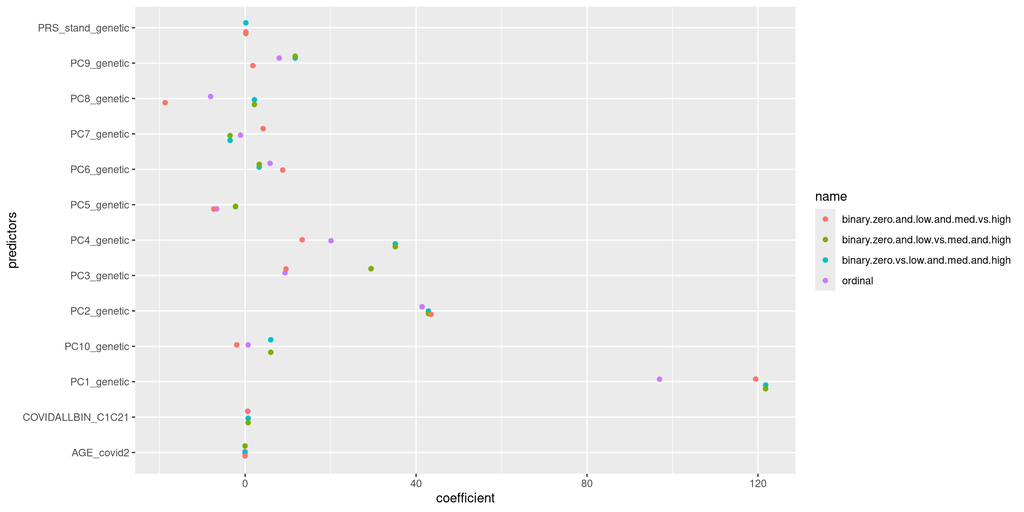

```r
coeffs2 <- coeffs %>%
  rownames_to_column() %>%
  pivot_longer(cols = 2:5)

ggplot(coeffs2, aes(x = value, y = rowname, group = name, colour = name)) +
  geom_jitter(height = 0.2) +
  labs(x = "coefficient", y = "predictors")
```

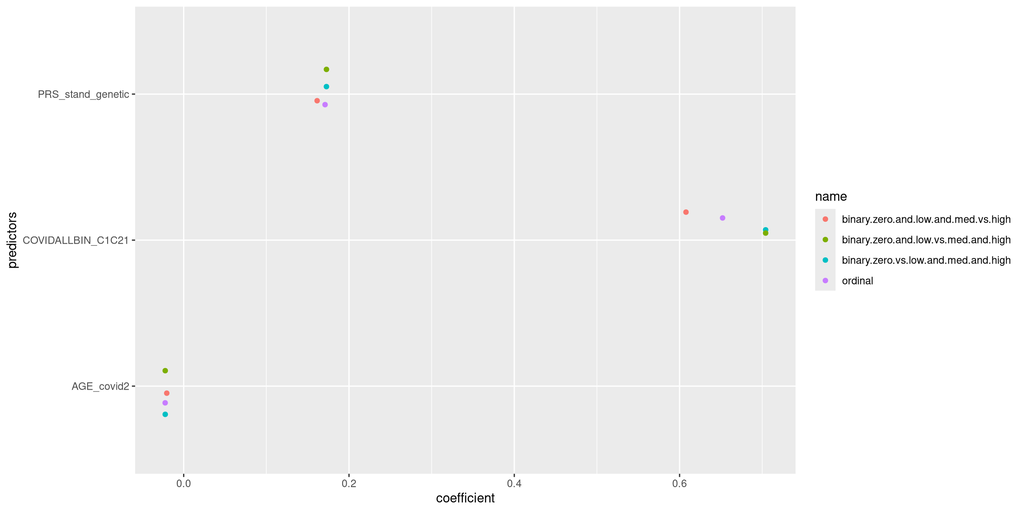

```r
coeffs3 <- coeffs2 %>%
  filter(rowname == 'PRS_stand_genetic' | rowname == 'COVIDALLBIN_C1C21' | rowname == "AGE_covid2")

ggplot(coeffs3, aes(x = value, y = rowname, group = name, colour = name)) +
  geom_jitter(height = 0.2) +
  labs(x = "coefficient", y = "predictors")
```

- Goodness of fit bad in one of the tests
- Brant test shows proportional odds assumption violated for age
- But visual inspection shows PO looks good

#### Male

```r
### Test goodness of fit ###

# lipsitz test
lipsitz(Covid_male_PO)
```

```
##
## Lipsitz Test:
##
##                       LR   df   pr(>chi)
## ordinal(lipsitz)  8.3293    9     0.5013
##
## H0: No lack of fit dictated
```

```r
# pulkstenis-robinson test
# (requires the vector of categorical input variables as an argument)
pulkroben(Covid_male_PO, test = c("chisq","deviance"), tables = FALSE)
```

```
##
## Pulkstenis-Robinson Chi-squared Test:
##
##                     chi-sq   df   pr(>chi)
## ordinal(pulkroben)  3.7813    7     0.8046
##
## H0: No lack of fit dictated
##
## rho: 100%
```

```r
# Hosmer-Lemeshow test
hosmerlem(Covid_male_PO)
```

```
##
## Hosmer-Lemeshow Test:
##
##                     Chi-sq  df  pr(>chi)
## ordinal(Hosmerlem)  33.842  26    0.1391
##
## H0: No lack of fit dictated
##
## rho: 100%
```

```r
### Test proportional odds assumption ###

# Brant Wald Test
# A generalized ordinal logistic regression model is approximated and compared to the calculated proportional odds model (a generalized ordinal logistic regression model is simply a relaxing of the proportional odds model to allow for different coefficients at each level of the ordinal outcome variable.)
# A Wald test is a hypothesis test of the significance of the difference in model coefficients, producing a chi-square statistic. A low p-value in a Brant-Wald test is an indicator that the coefficient does not satisfy the proportional odds assumption.
# A p-value of less than 0.05 on this test, particularly on the Omnibus plus at least one of the variables should be interpreted as a failure of the proportional odds assumption.

brant.test(Covid_male_PO)
```

```
##
## Brant Test:
##                      chi-sq   df   pr(>chi)
## Omnibus              26.675   26      0.427
## PRS_stand_genetic     6.125    2      0.047 *
## COVIDALLBIN_C1C21     0.229    2      0.892
## AGE_covid2            1.029    2      0.598
## PC1_genetic           3.175    2      0.204
## PC2_genetic           0.096    2      0.953
## PC3_genetic           0.307    2      0.858
## PC4_genetic           0.336    2      0.845
## PC5_genetic           4.012    2      0.134
## PC6_genetic           2.600    2      0.272
## PC7_genetic           4.839    2      0.089 .
## PC8_genetic           4.257    2      0.119
## PC9_genetic           1.191    2      0.551
## PC10_genetic          0.165    2      0.921
## ---
## Signif. codes:  0 '***' 0.001 '**' 0.01 '*' 0.05 '.' 0.1 ' ' 1
##
## H0: Proportional odds assumption holds
```

```r
# Sighting coefficients of stratified binomial models - want each to be similar
# create binary variables for every combo of the 3 categories
x <- df_ND_covid %>%
  mutate(SYMPzeroplus = case_when(
    NUMSYMPALL_covid2_cat == 'zero' ~ 0,
    NUMSYMPALL_covid2_cat == 'low' | NUMSYMPALL_covid2_cat == 'med' | NUMSYMPALL_covid2_cat == 'high' ~ 1
  ),
  SYMPlowplus = case_when(
    NUMSYMPALL_covid2_cat == 'zero' | NUMSYMPALL_covid2_cat == 'low' ~ 0,
    NUMSYMPALL_covid2_cat == 'medium' |  NUMSYMPALL_covid2_cat == 'high' ~ 1),
  SYMPmedplus = case_when(
    NUMSYMPALL_covid2_cat == 'zero' | NUMSYMPALL_covid2_cat == 'low' | NUMSYMPALL_covid2_cat == 'medium' ~ 0,
    NUMSYMPALL_covid2_cat == 'high' ~ 1)
  )


# Create logistic regression for each
zeroplus_model <- glm(SYMPzeroplus ~
                        PRS_stand_genetic +
                        COVIDALLBIN_C1C2 +
                        AGE_covid2 +
                        PC1_genetic +
                        PC2_genetic +
                        PC3_genetic +
                        PC4_genetic +
                        PC5_genetic +
                        PC6_genetic +
                        PC7_genetic +
                        PC8_genetic +
                        PC9_genetic +
                        PC10_genetic,
                      family = binomial(link = 'logit'),
                      data = x[x$SEX_genetic == "Male", ])

lowplus_model <- glm(SYMPlowplus ~
                       PRS_stand_genetic +
                       COVIDALLBIN_C1C2 +
                       AGE_covid2 +
                       PC1_genetic +
                       PC2_genetic +
                       PC3_genetic +
                       PC4_genetic +
                       PC5_genetic +
                       PC6_genetic +
                       PC7_genetic +
                       PC8_genetic +
                       PC9_genetic +
                       PC10_genetic,
                     family = binomial(link = 'logit'),
                     data = x[x$SEX_genetic == "Male", ])

medplus_model <- glm(SYMPmedplus ~
                       PRS_stand_genetic +
                       COVIDALLBIN_C1C2 +
                       AGE_covid2 +
                       PC1_genetic +
                       PC2_genetic +
                       PC3_genetic +
                       PC4_genetic +
                       PC5_genetic +
                       PC6_genetic +
                       PC7_genetic +
                       PC8_genetic +
                       PC9_genetic +
                       PC10_genetic,
                     family = binomial(link = 'logit'),
                     data = x[x$SEX_genetic == "Male", ])


# display the coefficients of all models and examine the difference between them.
# coefficients (i.e. the slopes) should be similar for all models to hold the proportional odds assumption

# table
coeffs <- data.frame(
  'ordinal' = coef(Covid_male_PO)[-c(1,2,3)],
  'binary zero vs low and med and high' = lowplus_model$coefficients[-1],
  'binary zero and low vs med and high' = lowplus_model$coefficients[-1],
  'binary zero and low and med vs high' = medplus_model$coefficients[-1])

coeffs %>%
  kable()
```

|  | ordinal | binary.zero.vs.low.and.med.and.high | binary.zero.and.low.vs.med.and.high | binary.zero.and.low.and.med.vs.high |
| --- | --- | --- | --- | --- |
| PRS_stand_genetic | 0.2943244 | 0.1984227 | 0.1984227 | 0.3361551 |
| COVIDALLBIN_C1C21 | 0.7846469 | 0.7841394 | 0.7841394 | 0.7958113 |
| AGE_covid2 | -0.0203310 | -0.0239745 | -0.0239745 | -0.0177530 |
| PC1_genetic | 270.8461652 | 418.3504335 | 418.3504335 | 131.6709309 |
| PC2_genetic | -44.0299298 | -59.5583346 | -59.5583346 | -57.9281466 |
| PC3_genetic | -79.0773323 | -65.9292477 | -65.9292477 | -96.9855678 |
| PC4_genetic | 70.9786188 | 68.1902043 | 68.1902043 | 49.1899476 |
| PC5_genetic | -1.0387710 | -8.3646632 | -8.3646632 | 23.0315785 |
| PC6_genetic | -7.5756149 | -19.1621473 | -19.1621473 | 0.5015902 |
| PC7_genetic | -19.8050286 | 3.8820471 | 3.8820471 | -35.0902223 |
| PC8_genetic | -5.5310788 | 10.2804402 | 10.2804402 | -27.1970152 |
| PC9_genetic | 28.6135960 | 17.8976504 | 17.8976504 | 35.0974901 |
| PC10_genetic | -5.3277964 | -0.5556709 | -0.5556709 | -7.7058493 |

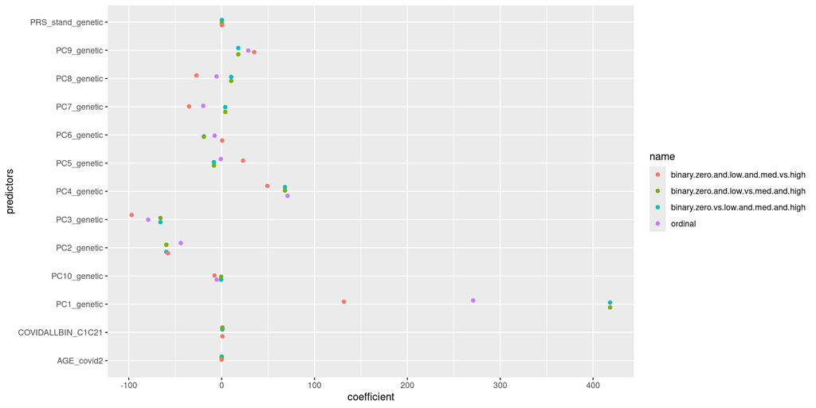

```r
coeffs2 <- coeffs %>%
  rownames_to_column() %>%
  pivot_longer(cols = 2:5)

ggplot(coeffs2, aes(x = value, y = rowname, group = name, colour = name)) +
  geom_jitter(height = 0.2) +
  labs(x = "coefficient", y = "predictors")
```

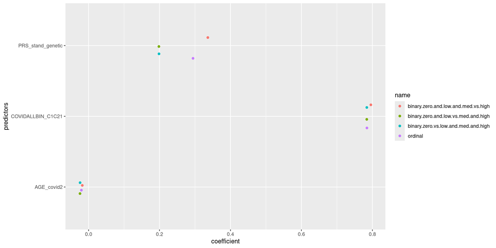

```r
coeffs3 <- coeffs2 %>%
  filter(rowname == 'PRS_stand_genetic' | rowname == 'COVIDALLBIN_C1C21' | rowname == "AGE_covid2")

ggplot(coeffs3, aes(x = value, y = rowname, group = name, colour = name)) +
  geom_jitter(height = 0.2) +
  labs(x = "coefficient", y = "predictors")
```

- Goodness of fit OK
- Brant test shows proportional odds assumption OK
- Visual inspection shows PO looks good

### Partial Proportional Odds

#### Both Sexes

```r
# LRT to compare partial PO to PO models
lrtest(Covid_PO, Covid_PartPO_NDexpos)
```

```
## Likelihood ratio test
##
## Model 1: NUMSYMPALL_covid2_cat ~ PRS_stand_genetic + COVIDALLBIN_C1C2 +
##     AGE_covid2 + SEX_genetic + PC1_genetic + PC2_genetic + PC3_genetic +
##     PC4_genetic + PC5_genetic + PC6_genetic + PC7_genetic + PC8_genetic +
##     PC9_genetic + PC10_genetic
## Model 2: NUMSYMPALL_covid2_cat ~ PRS_stand_genetic + COVIDALLBIN_C1C2 +
##     AGE_covid2 + SEX_genetic + PC1_genetic + PC2_genetic + PC3_genetic +
##     PC4_genetic + PC5_genetic + PC6_genetic + PC7_genetic + PC8_genetic +
##     PC9_genetic + PC10_genetic
##     #Df  LogLik Df Chisq Pr(>Chisq)
## 1 10432 -4163.7
## 2 10430 -4161.9 -2 3.463      0.177
```

```r
lrtest(Covid_PO, Covid_PartPO_PRS)
```

```
## Likelihood ratio test
##
## Model 1: NUMSYMPALL_covid2_cat ~ PRS_stand_genetic + COVIDALLBIN_C1C2 +
##     AGE_covid2 + SEX_genetic + PC1_genetic + PC2_genetic + PC3_genetic +
##     PC4_genetic + PC5_genetic + PC6_genetic + PC7_genetic + PC8_genetic +
##     PC9_genetic + PC10_genetic
## Model 2: NUMSYMPALL_covid2_cat ~ PRS_stand_genetic + COVIDALLBIN_C1C2 +
##     AGE_covid2 + SEX_genetic + PC1_genetic + PC2_genetic + PC3_genetic +
##     PC4_genetic + PC5_genetic + PC6_genetic + PC7_genetic + PC8_genetic +
##     PC9_genetic + PC10_genetic
##     #Df  LogLik Df  Chisq Pr(>Chisq)
## 1 10432 -4163.7
## 2 10430 -4162.6 -2 2.1594     0.3397
```

```r
lrtest(Covid_PO, Covid_PartPO_NDexpos_PRS)
```

```
## Likelihood ratio test
##
## Model 1: NUMSYMPALL_covid2_cat ~ PRS_stand_genetic + COVIDALLBIN_C1C2 +
##     AGE_covid2 + SEX_genetic + PC1_genetic + PC2_genetic + PC3_genetic +
##     PC4_genetic + PC5_genetic + PC6_genetic + PC7_genetic + PC8_genetic +
##     PC9_genetic + PC10_genetic
## Model 2: NUMSYMPALL_covid2_cat ~ PRS_stand_genetic + COVIDALLBIN_C1C2 +
##     AGE_covid2 + SEX_genetic + PC1_genetic + PC2_genetic + PC3_genetic +
##     PC4_genetic + PC5_genetic + PC6_genetic + PC7_genetic + PC8_genetic +
##     PC9_genetic + PC10_genetic
##     #Df  LogLik Df  Chisq Pr(>Chisq)
## 1 10432 -4163.7
## 2 10428 -4160.9 -4 5.5964     0.2314
```

```r
### Test goodness of fit ###

# lipsitz test
lipsitz(Covid_PartPO_NDexpos)
```

```
##
## Lipsitz Test:
##
##                       LR   df   pr(>chi)
## ordinal(lipsitz)  12.933    9     0.1657
##
## H0: No lack of fit dictated
```

```r
lipsitz(Covid_PartPO_PRS)
```

```
##
## Lipsitz Test:
##
##                       LR   df   pr(>chi)
## ordinal(lipsitz)  9.2177    9     0.4174
##
## H0: No lack of fit dictated
```

```r
lipsitz(Covid_PartPO_NDexpos_PRS)
```

```
##
## Lipsitz Test:
##
##                       LR   df   pr(>chi)
## ordinal(lipsitz)  12.761    9     0.1737
##
## H0: No lack of fit dictated
```

```r
# pulkstenis-robinson test
# (requires the vector of categorical input variables as an argument)
pulkroben(Covid_PartPO_NDexpos, test = c("chisq","deviance"), tables = FALSE)
```

```
##
## Pulkstenis-Robinson Chi-squared Test:
##
##                     chi-sq   df   pr(>chi)
## ordinal(pulkroben)  25.685   18     0.1072
##
## H0: No lack of fit dictated
##
## rho: 100%
```

```r
pulkroben(Covid_PartPO_PRS, test = c("chisq","deviance"), tables = FALSE)
```

```
##
## Pulkstenis-Robinson Chi-squared Test:
##
##                     chi-sq   df   pr(>chi)
## ordinal(pulkroben)  24.632   18     0.1354
##
## H0: No lack of fit dictated
##
## rho: 100%
```

```r
pulkroben(Covid_PartPO_NDexpos_PRS, test = c("chisq","deviance"), tables = FALSE)
```

```
##
## Pulkstenis-Robinson Chi-squared Test:
##
##                     chi-sq   df   pr(>chi)
## ordinal(pulkroben)  22.504   18     0.2104
##
## H0: No lack of fit dictated
##
## rho: 100%
```

```r
# Hosmer-Lemeshow test
hosmerlem(Covid_PartPO_NDexpos)
```

```
##
## Hosmer-Lemeshow Test:
##
##                     Chi-sq  df  pr(>chi)
## ordinal(Hosmerlem)  31.672  26    0.2042
##
## H0: No lack of fit dictated
##
## rho: 100%
```

```r
hosmerlem(Covid_PartPO_PRS)
```

```
##
## Hosmer-Lemeshow Test:
##
##                     Chi-sq  df  pr(>chi)
## ordinal(Hosmerlem)  32.105  26    0.1897
##
## H0: No lack of fit dictated
##
## rho: 100%
```

```r
hosmerlem(Covid_PartPO_PRS)
```

```
##
## Hosmer-Lemeshow Test:
##
##                     Chi-sq  df  pr(>chi)
## ordinal(Hosmerlem)  32.105  26    0.1897
##
## H0: No lack of fit dictated
##
## rho: 100%
```

- Relaxing PO assumption for ND exposure and/or PRS does not significantly improve model
- So best to use PO model

#### Female

```r
# LRT to compare partial PO to PO models
lrtest(Covid_female_PO, Covid_female_PartPO_NDexpos)
```

```
## Likelihood ratio test
##
## Model 1: NUMSYMPALL_covid2_cat ~ PRS_stand_genetic + COVIDALLBIN_C1C2 +
##     AGE_covid2 + PC1_genetic + PC2_genetic + PC3_genetic + PC4_genetic +
##     PC5_genetic + PC6_genetic + PC7_genetic + PC8_genetic + PC9_genetic +
##     PC10_genetic
## Model 2: NUMSYMPALL_covid2_cat ~ PRS_stand_genetic + COVIDALLBIN_C1C2 +
##     AGE_covid2 + PC1_genetic + PC2_genetic + PC3_genetic + PC4_genetic +
##     PC5_genetic + PC6_genetic + PC7_genetic + PC8_genetic + PC9_genetic +
##     PC10_genetic
##    #Df  LogLik Df Chisq Pr(>Chisq)
## 1 7913 -3149.7
## 2 7911 -3148.5 -2 2.554     0.2789
```

```r
lrtest(Covid_female_PO, Covid_female_PartPO_PRS)
```

```
## Likelihood ratio test
##
## Model 1: NUMSYMPALL_covid2_cat ~ PRS_stand_genetic + COVIDALLBIN_C1C2 +
##     AGE_covid2 + PC1_genetic + PC2_genetic + PC3_genetic + PC4_genetic +
##     PC5_genetic + PC6_genetic + PC7_genetic + PC8_genetic + PC9_genetic +
##     PC10_genetic
## Model 2: NUMSYMPALL_covid2_cat ~ PRS_stand_genetic + COVIDALLBIN_C1C2 +
##     AGE_covid2 + PC1_genetic + PC2_genetic + PC3_genetic + PC4_genetic +
##     PC5_genetic + PC6_genetic + PC7_genetic + PC8_genetic + PC9_genetic +
##     PC10_genetic
##    #Df  LogLik Df  Chisq Pr(>Chisq)
## 1 7913 -3149.7
## 2 7911 -3149.5 -2 0.5566     0.7571
```

```r
lrtest(Covid_female_PO, Covid_female_PartPO_NDexpos_PRS)
```

```
## Likelihood ratio test
##
## Model 1: NUMSYMPALL_covid2_cat ~ PRS_stand_genetic + COVIDALLBIN_C1C2 +
##     AGE_covid2 + PC1_genetic + PC2_genetic + PC3_genetic + PC4_genetic +
##     PC5_genetic + PC6_genetic + PC7_genetic + PC8_genetic + PC9_genetic +
##     PC10_genetic
## Model 2: NUMSYMPALL_covid2_cat ~ PRS_stand_genetic + COVIDALLBIN_C1C2 +
##     AGE_covid2 + PC1_genetic + PC2_genetic + PC3_genetic + PC4_genetic +
##     PC5_genetic + PC6_genetic + PC7_genetic + PC8_genetic + PC9_genetic +
##     PC10_genetic
##    #Df  LogLik Df  Chisq Pr(>Chisq)
## 1 7913 -3149.7
## 2 7909 -3148.2 -4 3.0854     0.5436
```

```r
### Test goodness of fit ###

# lipsitz test
lipsitz(Covid_female_PartPO_NDexpos)
```

```
##
## Lipsitz Test:
##
##                       LR   df   pr(>chi)
## ordinal(lipsitz)  8.2113    9      0.513
##
## H0: No lack of fit dictated
```

```r
lipsitz(Covid_female_PartPO_PRS)
```

```
##
## Lipsitz Test:
##
##                       LR   df   pr(>chi)
## ordinal(lipsitz)   8.647    9     0.4705
##
## H0: No lack of fit dictated
```

```r
lipsitz(Covid_female_PartPO_NDexpos_PRS)
```

```
##
## Lipsitz Test:
##
##                       LR   df   pr(>chi)
## ordinal(lipsitz)  9.4198    9     0.3995
##
## H0: No lack of fit dictated
```

```r
# pulkstenis-robinson test
# (requires the vector of categorical input variables as an argument)
pulkroben(Covid_female_PartPO_NDexpos, test = c("chisq","deviance"), tables = FALSE)
```

```
##
## Pulkstenis-Robinson Chi-squared Test:
##
##                     chi-sq   df   pr(>chi)
## ordinal(pulkroben)  17.082    7    0.01687 *
## ---
## Signif. codes:  0 '***' 0.001 '**' 0.01 '*' 0.05 '.' 0.1 ' ' 1
##
## H0: No lack of fit dictated
##
## rho: 100%
```

```r
pulkroben(Covid_female_PartPO_PRS, test = c("chisq","deviance"), tables = FALSE)
```

```
##
## Pulkstenis-Robinson Chi-squared Test:
##
##                     chi-sq   df   pr(>chi)
## ordinal(pulkroben)  17.357    7    0.01523 *
## ---
## Signif. codes:  0 '***' 0.001 '**' 0.01 '*' 0.05 '.' 0.1 ' ' 1
##
## H0: No lack of fit dictated
##
## rho: 100%
```

```r
pulkroben(Covid_female_PartPO_NDexpos_PRS, test = c("chisq","deviance"), tables = FALSE)
```

```
##
## Pulkstenis-Robinson Chi-squared Test:
##
##                     chi-sq   df   pr(>chi)
## ordinal(pulkroben)  16.079    7     0.0244 *
## ---
## Signif. codes:  0 '***' 0.001 '**' 0.01 '*' 0.05 '.' 0.1 ' ' 1
##
## H0: No lack of fit dictated
##
## rho: 100%
```

```r
# Hosmer-Lemeshow test
hosmerlem(Covid_female_PartPO_NDexpos)
```

```
##
## Hosmer-Lemeshow Test:
##
##                     Chi-sq  df  pr(>chi)
## ordinal(Hosmerlem)  23.912  26     0.581
##
## H0: No lack of fit dictated
##
## rho: 100%
```

```r
hosmerlem(Covid_female_PartPO_PRS)
```

```
##
## Hosmer-Lemeshow Test:
##
##                     Chi-sq  df  pr(>chi)
## ordinal(Hosmerlem)  26.829  26    0.4184
##
## H0: No lack of fit dictated
##
## rho: 100%
```

```r
hosmerlem(Covid_female_PartPO_PRS)
```

```
##
## Hosmer-Lemeshow Test:
##
##                     Chi-sq  df  pr(>chi)
## ordinal(Hosmerlem)  26.829  26    0.4184
##
## H0: No lack of fit dictated
##
## rho: 100%
```

- Relaxing PO assumption for ND exposure and/or PRS does not significantly improve model
- So best to use PO model

#### Male

```r
# LRT to compare partial PO to PO models
lrtest(Covid_male_PO, Covid_male_PartPO_NDexpos)
```

```
## Likelihood ratio test
##
## Model 1: NUMSYMPALL_covid2_cat ~ PRS_stand_genetic + COVIDALLBIN_C1C2 +
##     AGE_covid2 + PC1_genetic + PC2_genetic + PC3_genetic + PC4_genetic +
##     PC5_genetic + PC6_genetic + PC7_genetic + PC8_genetic + PC9_genetic +
##     PC10_genetic
## Model 2: NUMSYMPALL_covid2_cat ~ PRS_stand_genetic + COVIDALLBIN_C1C2 +
##     AGE_covid2 + PC1_genetic + PC2_genetic + PC3_genetic + PC4_genetic +
##     PC5_genetic + PC6_genetic + PC7_genetic + PC8_genetic + PC9_genetic +
##     PC10_genetic
##    #Df  LogLik Df  Chisq Pr(>Chisq)
## 1 2504 -1006.8
## 2 2502 -1006.4 -2 0.6474     0.7235
```

```r
lrtest(Covid_male_PO, Covid_male_PartPO_PRS)
```

```
## Likelihood ratio test
##
## Model 1: NUMSYMPALL_covid2_cat ~ PRS_stand_genetic + COVIDALLBIN_C1C2 +
##     AGE_covid2 + PC1_genetic + PC2_genetic + PC3_genetic + PC4_genetic +
##     PC5_genetic + PC6_genetic + PC7_genetic + PC8_genetic + PC9_genetic +
##     PC10_genetic
## Model 2: NUMSYMPALL_covid2_cat ~ PRS_stand_genetic + COVIDALLBIN_C1C2 +
##     AGE_covid2 + PC1_genetic + PC2_genetic + PC3_genetic + PC4_genetic +
##     PC5_genetic + PC6_genetic + PC7_genetic + PC8_genetic + PC9_genetic +
##     PC10_genetic
##    #Df  LogLik Df Chisq Pr(>Chisq)
## 1 2504 -1006.8
## 2 2502 -1004.4 -2 4.777    0.09177 .
## ---
## Signif. codes:  0 '***' 0.001 '**' 0.01 '*' 0.05 '.' 0.1 ' ' 1
```

```r
lrtest(Covid_male_PO, Covid_male_PartPO_NDexpos_PRS)
```

```
## Likelihood ratio test
##
## Model 1: NUMSYMPALL_covid2_cat ~ PRS_stand_genetic + COVIDALLBIN_C1C2 +
##     AGE_covid2 + PC1_genetic + PC2_genetic + PC3_genetic + PC4_genetic +
##     PC5_genetic + PC6_genetic + PC7_genetic + PC8_genetic + PC9_genetic +
##     PC10_genetic
## Model 2: NUMSYMPALL_covid2_cat ~ PRS_stand_genetic + COVIDALLBIN_C1C2 +
##     AGE_covid2 + PC1_genetic + PC2_genetic + PC3_genetic + PC4_genetic +
##     PC5_genetic + PC6_genetic + PC7_genetic + PC8_genetic + PC9_genetic +
##     PC10_genetic
##    #Df  LogLik Df  Chisq Pr(>Chisq)
## 1 2504 -1006.8
## 2 2500 -1004.1 -4 5.3445     0.2537
```

```r
### Test goodness of fit ###

# lipsitz test
lipsitz(Covid_male_PartPO_NDexpos)
```

```
##
## Lipsitz Test:
##
##                       LR   df   pr(>chi)
## ordinal(lipsitz)  7.4564    9     0.5897
##
## H0: No lack of fit dictated
```

```r
lipsitz(Covid_male_PartPO_PRS)
```

```
##
## Lipsitz Test:
##
##                       LR   df   pr(>chi)
## ordinal(lipsitz)  8.6955    9     0.4658
##
## H0: No lack of fit dictated
```

```r
lipsitz(Covid_male_PartPO_NDexpos_PRS)
```

```
##
## Lipsitz Test:
##
##                       LR   df   pr(>chi)
## ordinal(lipsitz)  7.1681    9     0.6196
##
## H0: No lack of fit dictated
```

```r
# pulkstenis-robinson test
# (requires the vector of categorical input variables as an argument)
pulkroben(Covid_male_PartPO_NDexpos, test = c("chisq","deviance"), tables = FALSE)
```

```
##
## Pulkstenis-Robinson Chi-squared Test:
##
##                     chi-sq   df   pr(>chi)
## ordinal(pulkroben)   3.256    7     0.8603
##
## H0: No lack of fit dictated
##
## rho: 100%
```

```r
pulkroben(Covid_male_PartPO_PRS, test = c("chisq","deviance"), tables = FALSE)
```

```
##
## Pulkstenis-Robinson Chi-squared Test:
##
##                     chi-sq   df   pr(>chi)
## ordinal(pulkroben)  2.2026    7     0.9478
##
## H0: No lack of fit dictated
##
## rho: 100%
```

```r
pulkroben(Covid_male_PartPO_NDexpos_PRS, test = c("chisq","deviance"), tables = FALSE)
```

```
##
## Pulkstenis-Robinson Chi-squared Test:
##
##                     chi-sq   df   pr(>chi)
## ordinal(pulkroben)  1.7133    7      0.974
##
## H0: No lack of fit dictated
##
## rho: 100%
```

```r
# Hosmer-Lemeshow test
hosmerlem(Covid_male_PartPO_NDexpos)
```

```
##
## Hosmer-Lemeshow Test:
##
##                     Chi-sq  df  pr(>chi)
## ordinal(Hosmerlem)  32.964  26    0.1631
##
## H0: No lack of fit dictated
##
## rho: 100%
```

```r
hosmerlem(Covid_male_PartPO_PRS)
```

```
##
## Hosmer-Lemeshow Test:
##
##                     Chi-sq  df  pr(>chi)
## ordinal(Hosmerlem)  30.147  26    0.2616
##
## H0: No lack of fit dictated
##
## rho: 100%
```

```r
hosmerlem(Covid_male_PartPO_PRS)
```

```
##
## Hosmer-Lemeshow Test:
##
##                     Chi-sq  df  pr(>chi)
## ordinal(Hosmerlem)  30.147  26    0.2616
##
## H0: No lack of fit dictated
##
## rho: 100%
```

- Relaxing PO assumption for ND exposure and/or PRS does not significantly improve model
- So best to use PO model

## Model Investigation

### Proportional Odds

#### Both Sexes

##### Results

```r
summary(Covid_PO)
```

```
##
## Call:
## VGAM::vglm(formula = NUMSYMPALL_covid2_cat ~ PRS_stand_genetic +
##     COVIDALLBIN_C1C2 + AGE_covid2 + SEX_genetic + PC1_genetic +
##     PC2_genetic + PC3_genetic + PC4_genetic + PC5_genetic + PC6_genetic +
##     PC7_genetic + PC8_genetic + PC9_genetic + PC10_genetic, family = VGAM::cumulative(logitlink,
##     parallel = T, reverse = T), data = df_ND_covid)
##
## Coefficients:
##                     Estimate Std. Error z value Pr(>|z|)
## (Intercept):1       2.146655   0.845579   2.539   0.0111 *
## (Intercept):2       0.187144   0.843650   0.222   0.8244
## (Intercept):3      -1.468065   0.844024  -1.739   0.0820 .
## PRS_stand_genetic   0.198096   0.032099   6.171 6.77e-10 ***
## COVIDALLBIN_C1C21   0.680674   0.069853   9.744  < 2e-16 ***
## AGE_covid2         -0.022053   0.002219  -9.936  < 2e-16 ***
## SEX_geneticFemale  -0.155883   0.075010  -2.078   0.0377 *
## PC1_genetic       137.573569  61.304749   2.244   0.0248 *
## PC2_genetic        29.809709  29.139258   1.023   0.3063
## PC3_genetic        -1.903875  17.458715  -0.109   0.9132
## PC4_genetic        22.370345  18.251021   1.226   0.2203
## PC5_genetic        -4.879779  11.305127  -0.432   0.6660
## PC6_genetic         3.300335   5.004051   0.660   0.5096
## PC7_genetic        -5.759044  10.250851  -0.562   0.5742
## PC8_genetic        -7.152532   8.948406  -0.799   0.4241
## PC9_genetic        12.463805   7.580410   1.644   0.1001
## PC10_genetic       -1.026102   7.555050  -0.136   0.8920
## ---
## Signif. codes:  0 '***' 0.001 '**' 0.01 '*' 0.05 '.' 0.1 ' ' 1
##
## Names of linear predictors: logitlink(P[Y>=2]), logitlink(P[Y>=3]),
## logitlink(P[Y>=4])
##
## Residual deviance: 8327.361 on 10432 degrees of freedom
##
## Log-likelihood: -4163.681 on 10432 degrees of freedom
##
## Number of Fisher scoring iterations: 4
##
##
## Exponentiated coefficients:
## PRS_stand_genetic COVIDALLBIN_C1C21        AGE_covid2 SEX_geneticFemale
##      1.219080e+00      1.975209e+00      9.781886e-01      8.556589e-01
##       PC1_genetic       PC2_genetic       PC3_genetic       PC4_genetic
##      5.590390e+59      8.834705e+12      1.489901e-01      5.191792e+09
##       PC5_genetic       PC6_genetic       PC7_genetic       PC8_genetic
##      7.598697e-03      2.712172e+01      3.154125e-03      7.828794e-04
##       PC9_genetic      PC10_genetic
##      2.587985e+05      3.584013e-01
```

```r
# Create nice summary of results, including back transformation to give OR and calculating 95% CI
CI <- as.data.frame(confint(Covid_PO)) %>%
  rownames_to_column() %>%
  rename('lower_95_CI_of_beta' = "2.5 %",
         'upper_95_CI_of_beta' = "97.5 %") %>%
  mutate(lower_95_CI_of_OR = exp(lower_95_CI_of_beta),
         upper_95_CI_of_OR = exp(upper_95_CI_of_beta))

beta <- as.data.frame(coef(Covid_PO)) %>%
  rownames_to_column() %>%
  rename("beta" = "coef(Covid_PO)") %>%
  mutate(OR = exp(beta))

results <- beta %>%
  full_join(CI) %>%
  relocate(rowname, beta, lower_95_CI_of_beta, upper_95_CI_of_beta, OR, lower_95_CI_of_OR, upper_95_CI_of_OR)

results %>% kable()
```

| rowname | beta | lower_95_CI_of_beta | upper_95_CI_of_beta | OR | lower_95_CI_of_OR | upper_95_CI_of_OR |
| --- | --- | --- | --- | --- | --- | --- |
| (Intercept):1 | 2.1466552 | 0.4893511 | 3.8039593 | 8.556192e+00 | 1.631257e+00 | 4.487852e+01 |
| (Intercept):2 | 0.1871437 | -1.4663796 | 1.8406671 | 1.205801e+00 | 2.307594e-01 | 6.300740e+00 |
| (Intercept):3 | -1.4680651 | -3.1223212 | 0.1861909 | 2.303708e-01 | 4.405480e-02 | 1.204652e+00 |
| PRS_stand_genetic | 0.1980961 | 0.1351829 | 0.2610093 | 1.219080e+00 | 1.144746e+00 | 1.298240e+00 |
| COVIDALLBIN_C1C21 | 0.6806741 | 0.5437647 | 0.8175834 | 1.975209e+00 | 1.722479e+00 | 2.265020e+00 |
| AGE_covid2 | -0.0220528 | -0.0264029 | -0.0177028 | 9.781886e-01 | 9.739426e-01 | 9.824530e-01 |
| SEX_geneticFemale | -0.1558834 | -0.3028995 | -0.0088673 | 8.556589e-01 | 7.386733e-01 | 9.911719e-01 |
| PC1_genetic | 137.5735695 | 17.4184686 | 257.7286704 | 5.590390e+59 | 3.670665e+07 | 8.514112e+111 |
| PC2_genetic | 29.8097088 | -27.3021871 | 86.9216047 | 8.834705e+12 | 0.000000e+00 | 5.617890e+37 |
| PC3_genetic | -1.9038752 | -36.1223277 | 32.3145772 | 1.489901e-01 | 0.000000e+00 | 1.081540e+14 |
| PC4_genetic | 22.3703447 | -13.4009985 | 58.1416879 | 5.191792e+09 | 1.500000e-06 | 1.780796e+25 |
| PC5_genetic | -4.8797785 | -27.0374196 | 17.2778626 | 7.598700e-03 | 0.000000e+00 | 3.189190e+07 |
| PC6_genetic | 3.3003348 | -6.5074244 | 13.1080939 | 2.712172e+01 | 1.492300e-03 | 4.929159e+05 |
| PC7_genetic | -5.7590441 | -25.8503431 | 14.3322550 | 3.154100e-03 | 0.000000e+00 | 1.676561e+06 |
| PC8_genetic | -7.1525319 | -24.6910854 | 10.3860215 | 7.829000e-04 | 0.000000e+00 | 3.240349e+04 |
| PC9_genetic | 12.4638050 | -2.3935246 | 27.3211346 | 2.587985e+05 | 9.130730e-02 | 7.335302e+11 |
| PC10_genetic | -1.0261019 | -15.8337275 | 13.7815237 | 3.584013e-01 | 1.000000e-07 | 9.665842e+05 |

##### Plots

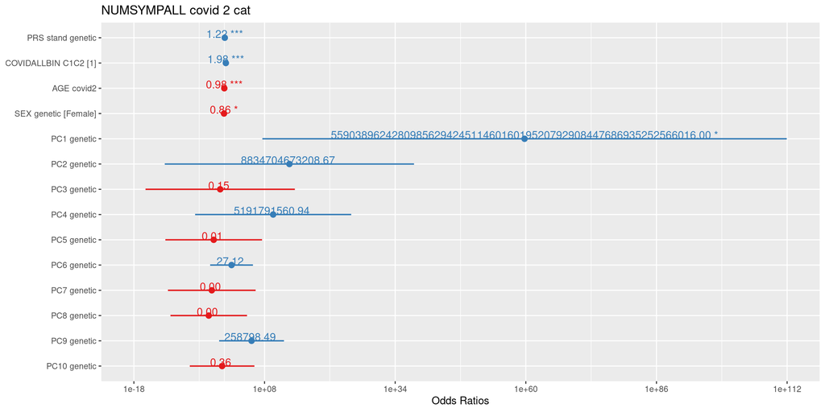

```r
plot_model(Covid_PO,
           type = 'est',
           show.values = T)
```

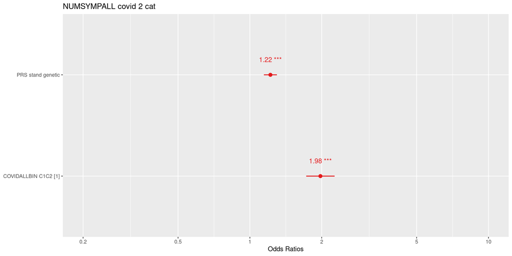

```r
plot_model(Covid_PO,
           type = 'est',
           show.values = T,
           terms = c('PRS_stand_genetic', 'COVIDALLBIN_C1C21'))
```

#### Female

##### Results

```r
summary(Covid_female_PO)
```

```
##
## Call:
## VGAM::vglm(formula = NUMSYMPALL_covid2_cat ~ PRS_stand_genetic +
##     COVIDALLBIN_C1C2 + AGE_covid2 + PC1_genetic + PC2_genetic +
##     PC3_genetic + PC4_genetic + PC5_genetic + PC6_genetic + PC7_genetic +
##     PC8_genetic + PC9_genetic + PC10_genetic, family = VGAM::cumulative(logitlink,
##     parallel = T, reverse = T), data = df_ND_covid[df_ND_covid$SEX_genetic ==
##     "Female", ])
##
## Coefficients:
##                    Estimate Std. Error z value Pr(>|z|)
## (Intercept):1      2.223205   0.970028   2.292   0.0219 *
## (Intercept):2      0.196511   0.967431   0.203   0.8390
## (Intercept):3     -1.446443   0.967846  -1.494   0.1350
## PRS_stand_genetic  0.171057   0.036767   4.652 3.28e-06 ***
## COVIDALLBIN_C1C21  0.652033   0.078209   8.337  < 2e-16 ***
## AGE_covid2        -0.022428   0.002519  -8.905  < 2e-16 ***
## PC1_genetic       96.973344  71.625229   1.354   0.1758
## PC2_genetic       41.416775  32.652951   1.268   0.2047
## PC3_genetic        9.333697  20.041681   0.466   0.6414
## PC4_genetic       20.107426  20.178759   0.996   0.3190
## PC5_genetic       -6.634592  13.062600  -0.508   0.6115
## PC6_genetic        5.835943   5.642143   1.034   0.3010
## PC7_genetic       -1.073114  11.621901  -0.092   0.9264
## PC8_genetic       -8.079196  10.278815  -0.786   0.4319
## PC9_genetic        7.971833   8.628468   0.924   0.3555
## PC10_genetic       0.704100   8.697170   0.081   0.9355
## ---
## Signif. codes:  0 '***' 0.001 '**' 0.01 '*' 0.05 '.' 0.1 ' ' 1
##
## Names of linear predictors: logitlink(P[Y>=2]), logitlink(P[Y>=3]),
## logitlink(P[Y>=4])
##
## Residual deviance: 6299.487 on 7913 degrees of freedom
##
## Log-likelihood: -3149.744 on 7913 degrees of freedom
##
## Number of Fisher scoring iterations: 4
##
##
## Exponentiated coefficients:
## PRS_stand_genetic COVIDALLBIN_C1C21        AGE_covid2       PC1_genetic
##      1.186558e+00      1.919439e+00      9.778212e-01      1.303131e+42
##       PC2_genetic       PC3_genetic       PC4_genetic       PC5_genetic
##      9.706821e+17      1.131287e+04      5.401870e+08      1.314114e-03
##       PC6_genetic       PC7_genetic       PC8_genetic       PC9_genetic
##      3.423874e+02      3.419422e-01      3.099202e-04      2.898164e+03
##      PC10_genetic
##      2.022025e+00
```

```r
# Create nice summary of results, including back transformation to give OR and calculating 95% CI
CI <- as.data.frame(confint(Covid_female_PO)) %>%
  rownames_to_column() %>%
  rename('lower_95_CI_of_beta' = "2.5 %",
         'upper_95_CI_of_beta' = "97.5 %") %>%
  mutate(lower_95_CI_of_OR = exp(lower_95_CI_of_beta),
         upper_95_CI_of_OR = exp(upper_95_CI_of_beta))

beta <- as.data.frame(coef(Covid_female_PO)) %>%
  rownames_to_column() %>%
  rename("beta" = "coef(Covid_female_PO)") %>%
  mutate(OR = exp(beta))

results <- beta %>%
  full_join(CI) %>%
  relocate(rowname, beta, lower_95_CI_of_beta, upper_95_CI_of_beta, OR, lower_95_CI_of_OR, upper_95_CI_of_OR)

results %>% kable()
```

| rowname | beta | lower_95_CI_of_beta | upper_95_CI_of_beta | OR | lower_95_CI_of_OR | upper_95_CI_of_OR |
| --- | --- | --- | --- | --- | --- | --- |
| (Intercept):1 | 2.2232048 | 0.3219845 | 4.1244250 | 9.236885e+00 | 1.3798634 | 6.183225e+01 |
| (Intercept):2 | 0.1965106 | -1.6996192 | 2.0926403 | 1.217148e+00 | 0.1827531 | 8.106290e+00 |
| (Intercept):3 | -1.4464434 | -3.3433865 | 0.4504997 | 2.354060e-01 | 0.0353172 | 1.569096e+00 |
| PRS_stand_genetic | 0.1710570 | 0.0989941 | 0.2431198 | 1.186558e+00 | 1.1040598 | 1.275221e+00 |
| COVIDALLBIN_C1C21 | 0.6520330 | 0.4987457 | 0.8053203 | 1.919439e+00 | 1.6466545 | 2.237413e+00 |
| AGE_covid2 | -0.0224284 | -0.0273647 | -0.0174922 | 9.778212e-01 | 0.9730064 | 9.826599e-01 |
| PC1_genetic | 96.9733438 | -43.4095249 | 237.3562124 | 1.303131e+42 | 0.0000000 | 1.209187e+103 |
| PC2_genetic | 41.4167754 | -22.5818321 | 105.4153829 | 9.706821e+17 | 0.0000000 | 6.043925e+45 |
| PC3_genetic | 9.3336966 | -29.9472759 | 48.6146691 | 1.131287e+04 | 0.0000000 | 1.297426e+21 |
| PC4_genetic | 20.1074259 | -19.4422155 | 59.6570673 | 5.401870e+08 | 0.0000000 | 8.104666e+25 |
| PC5_genetic | -6.6345923 | -32.2368184 | 18.9676338 | 1.314100e-03 | 0.0000000 | 1.727980e+08 |
| PC6_genetic | 5.8359428 | -5.2224551 | 16.8943407 | 3.423874e+02 | 0.0053941 | 2.173296e+07 |
| PC7_genetic | -1.0731135 | -23.8516202 | 21.7053932 | 3.419422e-01 | 0.0000000 | 2.670131e+09 |
| PC8_genetic | -8.0791958 | -28.2253023 | 12.0669107 | 3.099000e-04 | 0.0000000 | 1.740174e+05 |
| PC9_genetic | 7.9718326 | -8.9396529 | 24.8833182 | 2.898164e+03 | 0.0001311 | 6.407488e+10 |
| PC10_genetic | 0.7040995 | -16.3420408 | 17.7502399 | 2.022025e+00 | 0.0000001 | 5.114830e+07 |

##### Plots

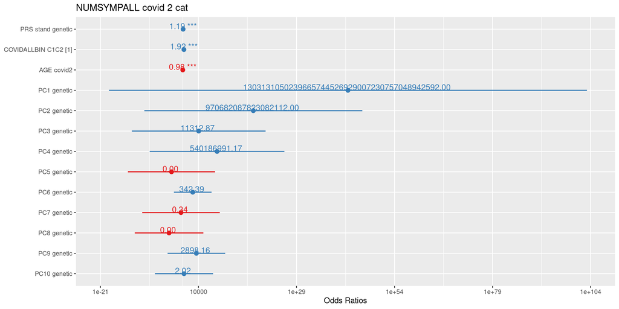

```r
plot_model(Covid_female_PO,
           type = 'est',
           show.values = T)
```

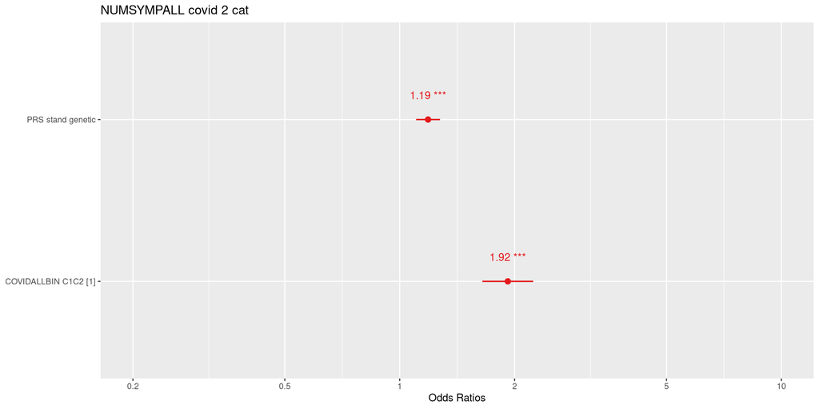

```r
plot_model(Covid_female_PO,
           type = 'est',
           show.values = T,
           terms = c('PRS_stand_genetic', 'COVIDALLBIN_C1C21'))
```

#### Male

##### Results

```r
summary(Covid_male_PO)
```

```
##
## Call:
## VGAM::vglm(formula = NUMSYMPALL_covid2_cat ~ PRS_stand_genetic +
##     COVIDALLBIN_C1C2 + AGE_covid2 + PC1_genetic + PC2_genetic +
##     PC3_genetic + PC4_genetic + PC5_genetic + PC6_genetic + PC7_genetic +
##     PC8_genetic + PC9_genetic + PC10_genetic, family = VGAM::cumulative(logitlink,
##     parallel = T, reverse = T), data = df_ND_covid[df_ND_covid$SEX_genetic ==
##     "Male", ])
##
## Coefficients:
##                     Estimate Std. Error z value Pr(>|z|)
## (Intercept):1       2.723227   1.808513   1.506   0.1321
## (Intercept):2       0.941082   1.806582   0.521   0.6024
## (Intercept):3      -0.768040   1.806494  -0.425   0.6707
## PRS_stand_genetic   0.294324   0.066729   4.411 1.03e-05 ***
## COVIDALLBIN_C1C21   0.784647   0.157100   4.995 5.90e-07 ***
## AGE_covid2         -0.020331   0.004742  -4.287 1.81e-05 ***
## PC1_genetic       270.846165 122.798519   2.206   0.0274 *
## PC2_genetic       -44.029930  69.736992  -0.631   0.5278
## PC3_genetic       -79.077332  41.368427  -1.912   0.0559 .
## PC4_genetic        70.978619  44.130703   1.608   0.1078
## PC5_genetic        -1.038771  22.794829  -0.046   0.9637
## PC6_genetic        -7.575615  11.099657  -0.683   0.4949
## PC7_genetic       -19.805029  21.901372  -0.904   0.3658
## PC8_genetic        -5.531079  18.342543  -0.302   0.7630
## PC9_genetic        28.613596  16.158945   1.771   0.0766 .
## PC10_genetic       -5.327796  15.409797  -0.346   0.7295
## ---
## Signif. codes:  0 '***' 0.001 '**' 0.01 '*' 0.05 '.' 0.1 ' ' 1
##
## Names of linear predictors: logitlink(P[Y>=2]), logitlink(P[Y>=3]),
## logitlink(P[Y>=4])
##
## Residual deviance: 2013.523 on 2504 degrees of freedom
##
## Log-likelihood: -1006.761 on 2504 degrees of freedom
##
## Number of Fisher scoring iterations: 4
##
##
## Exponentiated coefficients:
## PRS_stand_genetic COVIDALLBIN_C1C21        AGE_covid2       PC1_genetic
##      1.342219e+00      2.191633e+00      9.798743e-01     4.236381e+117
##       PC2_genetic       PC3_genetic       PC4_genetic       PC5_genetic
##      7.551695e-20      4.540994e-35      6.693026e+30      3.538894e-01
##       PC6_genetic       PC7_genetic       PC8_genetic       PC9_genetic
##      5.128050e-04      2.504871e-09      3.961713e-03      2.671326e+12
##      PC10_genetic
##      4.854756e-03
```

```r
# Create nice summary of results, including back transformation to give OR and calculating 95% CI
CI <- as.data.frame(confint(Covid_male_PO)) %>%
  rownames_to_column() %>%
  rename('lower_95_CI_of_beta' = "2.5 %",
         'upper_95_CI_of_beta' = "97.5 %") %>%
  mutate(lower_95_CI_of_OR = exp(lower_95_CI_of_beta),
         upper_95_CI_of_OR = exp(upper_95_CI_of_beta))

beta <- as.data.frame(coef(Covid_male_PO)) %>%
  rownames_to_column() %>%
  rename("beta" = "coef(Covid_male_PO)") %>%
  mutate(OR = exp(beta))

results <- beta %>%
  full_join(CI) %>%
  relocate(rowname, beta, lower_95_CI_of_beta, upper_95_CI_of_beta, OR, lower_95_CI_of_OR, upper_95_CI_of_OR)

results %>% kable()
```

| rowname | beta | lower_95_CI_of_beta | upper_95_CI_of_beta | OR | lower_95_CI_of_OR | upper_95_CI_of_OR |
| --- | --- | --- | --- | --- | --- | --- |
| (Intercept):1 | 2.7232265 | -0.8213947 | 6.2678478 | 1.522938e+01 | 4.398178e-01 | 5.273412e+02 |
| (Intercept):2 | 0.9410818 | -2.5997538 | 4.4819173 | 2.562752e+00 | 7.429190e-02 | 8.840400e+01 |
| (Intercept):3 | -0.7680400 | -4.3087027 | 2.7726226 | 4.639214e-01 | 1.345100e-02 | 1.600054e+01 |
| PRS_stand_genetic | 0.2943244 | 0.1635370 | 0.4251118 | 1.342219e+00 | 1.177669e+00 | 1.529761e+00 |
| COVIDALLBIN_C1C21 | 0.7846469 | 0.4767374 | 1.0925563 | 2.191633e+00 | 1.610810e+00 | 2.981887e+00 |
| AGE_covid2 | -0.0203310 | -0.0296253 | -0.0110367 | 9.798743e-01 | 9.708093e-01 | 9.890240e-01 |
| PC1_genetic | 270.8461652 | 30.1654908 | 511.5268396 | 4.236381e+117 | 1.260974e+13 | 1.423259e+222 |
| PC2_genetic | -44.0299298 | -180.7119228 | 92.6520632 | 0.000000e+00 | 0.000000e+00 | 1.730931e+40 |
| PC3_genetic | -79.0773323 | -160.1579584 | 2.0032939 | 0.000000e+00 | 0.000000e+00 | 7.413435e+00 |
| PC4_genetic | 70.9786188 | -15.5159697 | 157.4732074 | 6.693026e+30 | 2.000000e-07 | 2.453268e+68 |
| PC5_genetic | -1.0387710 | -45.7158158 | 43.6382738 | 3.538894e-01 | 0.000000e+00 | 8.950793e+18 |
| PC6_genetic | -7.5756149 | -29.3305430 | 14.1793133 | 5.128000e-04 | 0.000000e+00 | 1.438790e+06 |
| PC7_genetic | -19.8050286 | -62.7309288 | 23.1208716 | 0.000000e+00 | 0.000000e+00 | 1.099682e+10 |
| PC8_genetic | -5.5310788 | -41.4818016 | 30.4196439 | 3.961700e-03 | 0.000000e+00 | 1.625861e+13 |
| PC9_genetic | 28.6135960 | -3.0573534 | 60.2845455 | 2.671326e+12 | 4.701200e-02 | 1.517908e+26 |
| PC10_genetic | -5.3277964 | -35.5304429 | 24.8748502 | 4.854800e-03 | 0.000000e+00 | 6.353458e+10 |

##### Plots

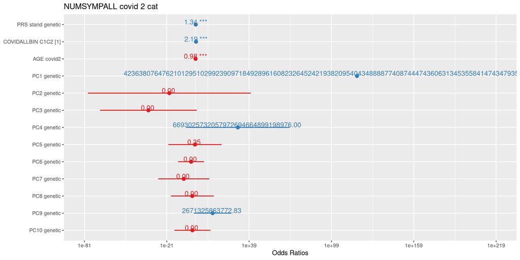

```r
plot_model(Covid_male_PO,
           type = 'est',
           show.values = T)
```

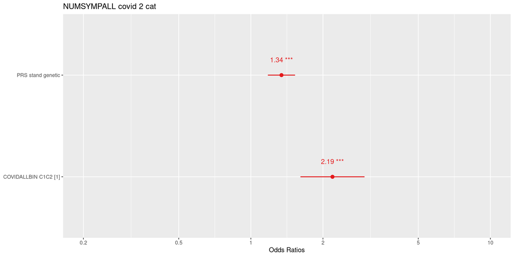

```r
plot_model(Covid_male_PO,
           type = 'est',
           show.values = T,
           terms = c('PRS_stand_genetic', 'COVIDALLBIN_C1C21'))
```

#### Female vs Male

- ‘A sex-stratified analysis followed by a Zscore difference test (Eq. 1) is equivalent to a formal test for G×S interaction when there is no interaction between covariates and the strata, and the trait variance are equivalent in the two strata.’ (Blokland et al., 2022)
- Conduct a Z test for the difference between the coefficients of females and males

```r
female_beta <- coef(summary(Covid_female_PO))["COVIDALLBIN_C1C21", "Estimate"]
female_SE <- coef(summary(Covid_female_PO))["COVIDALLBIN_C1C21", "Std. Error"]
male_beta <- coef(summary(Covid_male_PO))["COVIDALLBIN_C1C21", "Estimate"]
male_SE <- coef(summary(Covid_male_PO))["COVIDALLBIN_C1C21", "Std. Error"]

Z <- (female_beta - male_beta) / sqrt((female_SE)^2 + (male_SE)^2)
p <- 2 * pnorm(abs(Z), mean = 0, sd = 1, lower.tail = FALSE)

message <- sprintf("Association of horrible covid experience on no. symptoms currenlty in females compared to males, Z = %.6f, p = %.6f", Z, p)
print(message)
```

```
## [1] "Association of horrible covid experience on no. symptoms currenlty in females compared to males, Z = -0.755675, p = 0.449844"
```

# 2019 Bushfires/Floods + COVID (no vs both) (current depression)

- Bushfires/floods AND COVID being traumatic
  - Yes = if yes to bushfires/floods AND COVID (covid 1 and or covid 2)
  - No = No to bushfires/floods and covid 1 and covid 2
- NUMSYMPALL from covid wave 2 survey

## Explore

### Sample size

```r
df_ND_covid %>%
  drop_na(NUMSYMPALL_covid2, SEX_genetic, AGE_covid2, matches("^PC.*_genetic$"), COVIDALL_BUSHFLOOD_both, PRS_stand_genetic) %>%
  count(COVIDALL_BUSHFLOOD_both) %>%
  kable(caption = "No. participants that experienced any frightening, horrible or traumatic experiences related to COVID (wave 1 and/or 2) and the bushfires and flooding over the past year \n (Yes = yes to covid wave 1 and/or 2 AND yes to bushfires/floods, No = no to covid wave 1 and 2 and bushfires/floods")
```

No. participants that experienced any frightening, horrible or traumatic experiences related to COVID (wave 1 and/or 2) and the bushfires and flooding over the past year (Yes = yes to covid wave 1 and/or 2 AND yes to bushfires/floods, No = no to covid wave 1 and 2 and bushfires/floods

| COVIDALL_BUSHFLOOD_both | n |
| --- | --- |
| No | 1962 |
| Yes | 128 |

```r
df_ND_covid %>%
  drop_na(NUMSYMPALL_covid2, SEX_genetic, AGE_covid2, matches("^PC.*_genetic$"), COVIDALL_BUSHFLOOD_both, PRS_stand_genetic) %>%
  filter(SEX_genetic == "Female") %>%
  count(COVIDALL_BUSHFLOOD_both) %>%
  kable(caption = "No. female participants that experienced any frightening, horrible or traumatic experiences related to COVID (wave 1 and/or 2) and the bushfires and flooding over the past year \n (Yes = yes to covid wave 1 and/or 2 AND yes to bushfires/floods, No = no to covid wave 1 and 2 and bushfires/floods")
```

No. female participants that experienced any frightening, horrible or traumatic experiences related to COVID (wave 1 and/or 2) and the bushfires and flooding over the past year (Yes = yes to covid wave 1 and/or 2 AND yes to bushfires/floods, No = no to covid wave 1 and 2 and bushfires/floods

| COVIDALL_BUSHFLOOD_both | n |
| --- | --- |
| No | 1440 |
| Yes | 102 |

```r
df_ND_covid %>%
  drop_na(NUMSYMPALL_covid2, SEX_genetic, AGE_covid2, matches("^PC.*_genetic$"), COVIDALL_BUSHFLOOD_both, PRS_stand_genetic) %>%
  filter(SEX_genetic == "Male") %>%
  count(COVIDALL_BUSHFLOOD_both) %>%
  kable(caption = "No. male participants that experienced any frightening, horrible or traumatic experiences related to COVID (wave 1 and/or 2) and the bushfires and flooding over the past year \n (Yes = yes to covid wave 1 and/or 2 AND yes to bushfires/floods, No = no to covid wave 1 and 2 and bushfires/floods")
```

No. male participants that experienced any frightening, horrible or traumatic experiences related to COVID (wave 1 and/or 2) and the bushfires and flooding over the past year (Yes = yes to covid wave 1 and/or 2 AND yes to bushfires/floods, No = no to covid wave 1 and 2 and bushfires/floods

| COVIDALL_BUSHFLOOD_both | n |
| --- | --- |
| No | 522 |
| Yes | 26 |

### Distribution

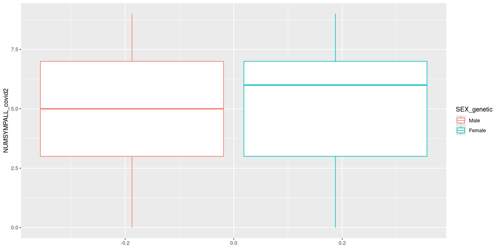

```r
ggplot(df_ND_covid[!is.na(df_ND_covid$NUMSYMPALL_covid2) & !is.na(df_ND_covid$SEX_genetic),],
             aes(y = NUMSYMPALL_covid2, colour = SEX_genetic)) +
  geom_boxplot()
```

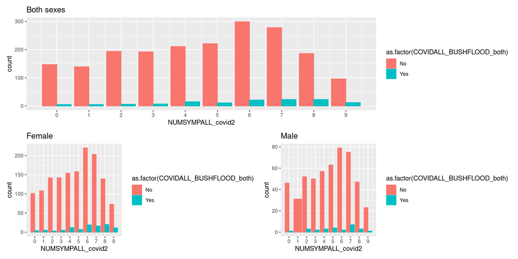

```r
p1 <- ggplot(df_ND_covid[!is.na(df_ND_covid$NUMSYMPALL_covid2) &
                           !is.na(df_ND_covid$SEX_genetic) &
                           !is.na(df_ND_covid$COVIDALL_BUSHFLOOD_both), ],
             aes (x = NUMSYMPALL_covid2, colour = as.factor(COVIDALL_BUSHFLOOD_both), fill = as.factor(COVIDALL_BUSHFLOOD_both))) +
  geom_bar(position = "dodge") +
  scale_x_continuous(breaks = c(0,1,2,3,4,5,6,7,8,9)) +
  ggtitle("Both sexes")


p2 <- ggplot(df_ND_covid[!is.na(df_ND_covid$NUMSYMPALL_covid2) &
                           !is.na(df_ND_covid$SEX_genetic) &
                           (df_ND_covid$SEX_genetic == "Female") &
                           !is.na(df_ND_covid$COVIDALL_BUSHFLOOD_both), ],
             aes (x = NUMSYMPALL_covid2, colour = as.factor(COVIDALL_BUSHFLOOD_both), fill = as.factor(COVIDALL_BUSHFLOOD_both))) +
  geom_bar(position = "dodge") +
  scale_x_continuous(breaks = c(0,1,2,3,4,5,6,7,8,9)) +
  ggtitle("Female")

p3 <- ggplot(df_ND_covid[!is.na(df_ND_covid$NUMSYMPALL_covid2) &
                           !is.na(df_ND_covid$SEX_genetic) &
                           (df_ND_covid$SEX_genetic == "Male") &
                           !is.na(df_ND_covid$COVIDALL_BUSHFLOOD_both), ],
             aes (x = NUMSYMPALL_covid2, colour = as.factor(COVIDALL_BUSHFLOOD_both), fill = as.factor(COVIDALL_BUSHFLOOD_both))) +
  geom_bar(position = "dodge") +
  scale_x_continuous(breaks = c(0,1,2,3,4,5,6,7,8,9)) +
  ggtitle("Male")

p1 / (p2 | p3)
```

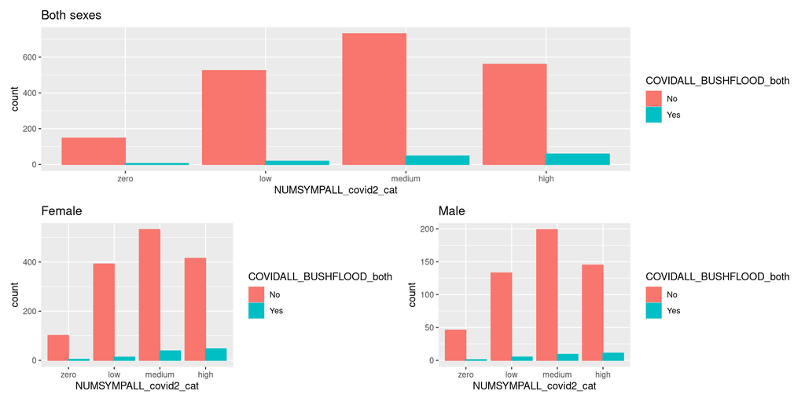

```r
p1 <- ggplot(df_ND_covid[!is.na(df_ND_covid$NUMSYMPALL_covid2_cat) &
                           !is.na(df_ND_covid$SEX_genetic) &
                           !is.na(df_ND_covid$COVIDALL_BUSHFLOOD_both), ],
             aes (x = NUMSYMPALL_covid2_cat, colour = COVIDALL_BUSHFLOOD_both, fill = COVIDALL_BUSHFLOOD_both)) +
  geom_bar(position = "dodge") +
  ggtitle("Both sexes")

p2 <- ggplot(df_ND_covid[!is.na(df_ND_covid$NUMSYMPALL_covid2_cat) &
                           !is.na(df_ND_covid$SEX_genetic) &
                           (df_ND_covid$SEX_genetic == "Female") &
                           !is.na(df_ND_covid$COVIDALL_BUSHFLOOD_both), ],
             aes (x = NUMSYMPALL_covid2_cat, colour = COVIDALL_BUSHFLOOD_both, fill = COVIDALL_BUSHFLOOD_both)) +
  geom_bar(position = "dodge") +
  ggtitle("Female")

p3 <- ggplot(df_ND_covid[!is.na(df_ND_covid$NUMSYMPALL_covid2_cat) &
                           !is.na(df_ND_covid$SEX_genetic) &
                           (df_ND_covid$SEX_genetic == "Male") &
                           !is.na(df_ND_covid$COVIDALL_BUSHFLOOD_both), ],
             aes (x = NUMSYMPALL_covid2_cat, colour = COVIDALL_BUSHFLOOD_both, fill = COVIDALL_BUSHFLOOD_both)) +
  geom_bar(position = "dodge") +
  ggtitle("Male")

p1 / (p2 | p3)
```

### 2019 bushfires/floods AND covid experiences

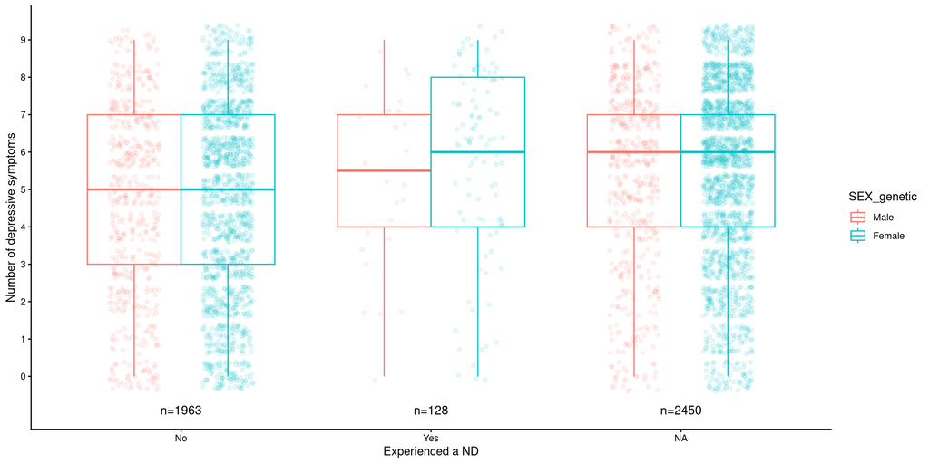

```r
ggplot(df_ND_covid[!is.na(df_ND_covid$SEX_genetic),], aes(x = as.factor(COVIDALL_BUSHFLOOD_both), y = NUMSYMPALL_covid2, colour = SEX_genetic)) +
  geom_boxplot(position = position_dodge(width = 0.75)) +
  geom_point(position = position_jitterdodge(dodge.width = 0.75, jitter.width = 0.4, jitter.height = 0.4), alpha = 0.1) +
  stat_n_text() +
  labs(x = "Experienced a ND",
       y = "Number of depressive symptoms") +
  theme(axis.text.x = element_text(angle = 45, vjust = 1, hjust=1)) +
  scale_y_continuous(breaks = c(0,1,2,3,4,5,6,7,8,9)) +
  theme_classic()
```

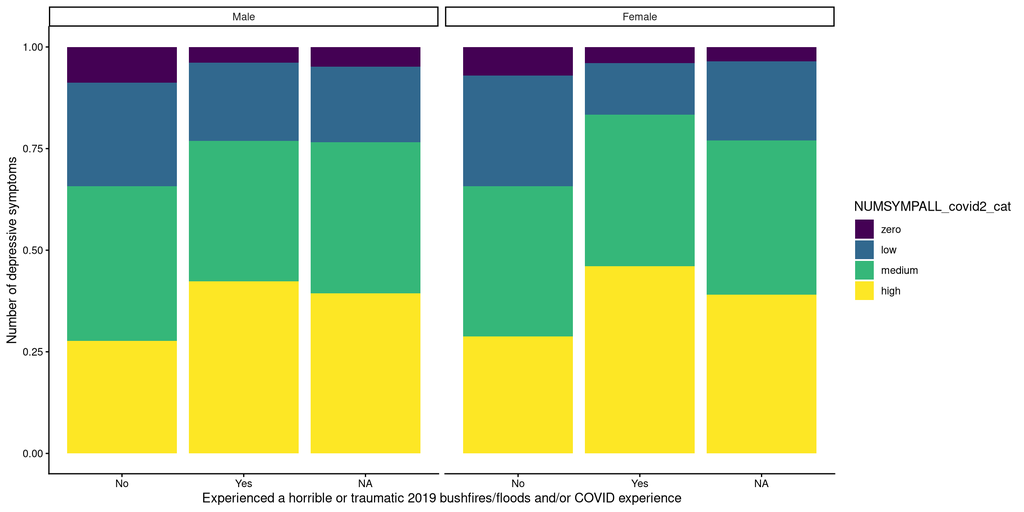

```r
ggplot(df_ND_covid[!is.na(df_ND_covid$SEX_genetic) & !is.na(df_ND_covid$NUMSYMPALL_covid2_cat),], aes(x = as.factor(COVIDALL_BUSHFLOOD_both), fill = NUMSYMPALL_covid2_cat)) +
  geom_bar(position = "fill") +
  # stat_n_text() +
  labs(x = "Experienced a horrible or traumatic 2019 bushfires/floods and/or COVID experience",
       y = "Number of depressive symptoms") +
  facet_wrap(~ SEX_genetic) +
  theme(axis.text.x = element_text(angle = 45, vjust = 1, hjust=1)) +
  theme_classic()
```

## Fit Models

### Proportional Odds

```r
Twenty19BushFloodCovidBoth_PO <- VGAM::vglm(NUMSYMPALL_covid2_cat ~
                                                     PRS_stand_genetic +
                                                     COVIDALL_BUSHFLOOD_both +
                                                     AGE_covid2 +
                                                     SEX_genetic +
                                                     PC1_genetic +
                                                     PC2_genetic +
                                                     PC3_genetic +
                                                     PC4_genetic +
                                              PC5_genetic +
                                              PC6_genetic +
                                              PC7_genetic +
                                              PC8_genetic +
                                              PC9_genetic +
                                              PC10_genetic,
                                                   family = VGAM::cumulative(logitlink, parallel = T, reverse = T), # with PO (package pammtools masks VGAM cumulative so specify from VGAM)
                                                   data = df_ND_covid)

Twenty19BushFloodCovidBoth_female_PO <- VGAM::vglm(NUMSYMPALL_covid2_cat ~
                                                 PRS_stand_genetic +
                                                 COVIDALL_BUSHFLOOD_both +
                                                 AGE_covid2 +
                                                 PC1_genetic +
                                                 PC2_genetic +
                                                 PC3_genetic +
                                                 PC4_genetic +
                                                   PC5_genetic +
                                                   PC6_genetic +
                                                   PC7_genetic +
                                                   PC8_genetic +
                                                   PC9_genetic +
                                                   PC10_genetic,
                                               family = VGAM::cumulative(logitlink, parallel = T, reverse = T), # with PO (package pammtools masks VGAM cumulative so specify from VGAM)
                                               data = df_ND_covid[df_ND_covid$SEX_genetic == "Female", ])

Twenty19BushFloodCovidBoth_male_PO <- VGAM::vglm(NUMSYMPALL_covid2_cat ~
                                               PRS_stand_genetic +
                                               COVIDALL_BUSHFLOOD_both +
                                               AGE_covid2 +
                                               PC1_genetic +
                                               PC2_genetic +
                                               PC3_genetic +
                                               PC4_genetic +
                                                 PC5_genetic +
                                                 PC6_genetic +
                                                 PC7_genetic +
                                                 PC8_genetic +
                                                 PC9_genetic +
                                                 PC10_genetic,
                                             family = VGAM::cumulative(logitlink, parallel = T, reverse = T), # with PO (package pammtools masks VGAM cumulative so specify from VGAM)
                                             data = df_ND_covid[df_ND_covid$SEX_genetic == "Male", ])
```

### Partial Proportional Odds

```r
Twenty19BushFloodCovidBoth_PartPO_NDexpos <- VGAM::vglm(NUMSYMPALL_covid2_cat ~
                                                                 PRS_stand_genetic +
                                                                 COVIDALL_BUSHFLOOD_both +
                                                                 AGE_covid2 +
                                                                 SEX_genetic +
                                                                 PC1_genetic +
                                                                 PC2_genetic +
                                                                 PC3_genetic +
                                                                 PC4_genetic +
                                                          PC5_genetic +
                                                          PC6_genetic +
                                                          PC7_genetic +
                                                          PC8_genetic +
                                                          PC9_genetic +
                                                          PC10_genetic,
                                                               family = VGAM::cumulative(logitlink, parallel = F ~ COVIDALL_BUSHFLOOD_both, reverse = T), # with PO (package pammtools masks VGAM cumulative so specify from VGAM)
                                                               data = df_ND_covid)

Twenty19BushFloodCovidBoth_PartPO_PRS <- VGAM::vglm(NUMSYMPALL_covid2_cat ~
                                                             PRS_stand_genetic +
                                                             COVIDALL_BUSHFLOOD_both +
                                                             AGE_covid2 +
                                                             SEX_genetic +
                                                             PC1_genetic +
                                                             PC2_genetic +
                                                             PC3_genetic +
                                                             PC4_genetic +
                                                      PC5_genetic +
                                                      PC6_genetic +
                                                      PC7_genetic +
                                                      PC8_genetic +
                                                      PC9_genetic +
                                                      PC10_genetic,
                                                           family = VGAM::cumulative(logitlink, parallel = F ~ PRS_stand_genetic, reverse = T), # with PO (package pammtools masks VGAM cumulative so specify from VGAM)
                                                           data = df_ND_covid)

Twenty19BushFloodCovidBoth_PartPO_NDexpos_PRS <- VGAM::vglm(NUMSYMPALL_covid2_cat ~
                                                                     PRS_stand_genetic +
                                                                     COVIDALL_BUSHFLOOD_both +
                                                                     AGE_covid2 +
                                                                     SEX_genetic +
                                                                     PC1_genetic +
                                                                     PC2_genetic +
                                                                     PC3_genetic +
                                                                     PC4_genetic +
                                                              PC5_genetic +
                                                              PC6_genetic +
                                                              PC7_genetic +
                                                              PC8_genetic +
                                                              PC9_genetic +
                                                              PC10_genetic,
                                                                   family = VGAM::cumulative(logitlink, parallel = F ~ COVIDALL_BUSHFLOOD_both + PRS_stand_genetic, reverse = T), # with PO (package pammtools masks VGAM cumulative so specify from VGAM)
                                                                   data = df_ND_covid)


Twenty19BushFloodCovidBoth_female_PartPO_NDexpos <- VGAM::vglm(NUMSYMPALL_covid2_cat ~
                                                             PRS_stand_genetic +
                                                             COVIDALL_BUSHFLOOD_both +
                                                             AGE_covid2 +
                                                             PC1_genetic +
                                                             PC2_genetic +
                                                             PC3_genetic +
                                                             PC4_genetic +
                                                               PC5_genetic +
                                                               PC6_genetic +
                                                               PC7_genetic +
                                                               PC8_genetic +
                                                               PC9_genetic +
                                                               PC10_genetic,
                                                           family = VGAM::cumulative(logitlink, parallel = F ~ COVIDALL_BUSHFLOOD_both, reverse = T), # with PO (package pammtools masks VGAM cumulative so specify from VGAM)
                                                           data = df_ND_covid[df_ND_covid$SEX_genetic == "Female", ])

Twenty19BushFloodCovidBoth_female_PartPO_PRS <- VGAM::vglm(NUMSYMPALL_covid2_cat ~
                                                         PRS_stand_genetic +
                                                         COVIDALL_BUSHFLOOD_both +
                                                         AGE_covid2 +
                                                         PC1_genetic +
                                                         PC2_genetic +
                                                         PC3_genetic +
                                                         PC4_genetic +
                                                           PC5_genetic +
                                                           PC6_genetic +
                                                           PC7_genetic +
                                                           PC8_genetic +
                                                           PC9_genetic +
                                                           PC10_genetic,
                                                       family = VGAM::cumulative(logitlink, parallel = F ~ PRS_stand_genetic, reverse = T), # with PO (package pammtools masks VGAM cumulative so specify from VGAM)
                                                       data = df_ND_covid[df_ND_covid$SEX_genetic == "Female", ])
```

```r
Twenty19BushFloodCovidBoth_female_PartPO_NDexpos_PRS <- VGAM::vglm(NUMSYMPALL_covid2_cat ~
                                                                 PRS_stand_genetic +
                                                                 COVIDALL_BUSHFLOOD_both +
                                                                 AGE_covid2 +
                                                                 PC1_genetic +
                                                                 PC2_genetic +
                                                                 PC3_genetic +
                                                                 PC4_genetic +
                                                                   PC5_genetic +
                                                                   PC6_genetic +
                                                                   PC7_genetic +
                                                                   PC8_genetic +
                                                                   PC9_genetic +
                                                                   PC10_genetic,
                                                               family = VGAM::cumulative(logitlink, parallel = F ~ COVIDALL_BUSHFLOOD_both + PRS_stand_genetic, reverse = T), # with PO (package pammtools masks VGAM cumulative so specify from VGAM)
                                                               data = df_ND_covid[df_ND_covid$SEX_genetic == "Female", ])

Twenty19BushFloodCovidBoth_male_PartPO_NDexpos <- VGAM::vglm(NUMSYMPALL_covid2_cat ~
                                                           PRS_stand_genetic +
                                                           COVIDALL_BUSHFLOOD_both +
                                                           AGE_covid2 +
                                                           PC1_genetic +
                                                           PC2_genetic +
                                                           PC3_genetic +
                                                           PC4_genetic +
                                                             PC5_genetic +
                                                             PC6_genetic +
                                                             PC7_genetic +
                                                             PC8_genetic +
                                                             PC9_genetic +
                                                             PC10_genetic,
                                                         family = VGAM::cumulative(logitlink, parallel = F ~ COVIDALL_BUSHFLOOD_both, reverse = T), # with PO (package pammtools masks VGAM cumulative so specify from VGAM)
                                                         data = df_ND_covid[df_ND_covid$SEX_genetic == "Male", ])

Twenty19BushFloodCovidBoth_male_PartPO_PRS <- VGAM::vglm(NUMSYMPALL_covid2_cat ~
                                                       PRS_stand_genetic +
                                                       COVIDALL_BUSHFLOOD_both +
                                                       AGE_covid2 +
                                                       PC1_genetic +
                                                       PC2_genetic +
                                                       PC3_genetic +
                                                       PC4_genetic +
                                                         PC5_genetic +
                                                         PC6_genetic +
                                                         PC7_genetic +
                                                         PC8_genetic +
                                                         PC9_genetic +
                                                         PC10_genetic,
                                                     family = VGAM::cumulative(logitlink, parallel = F ~ PRS_stand_genetic, reverse = T), # with PO (package pammtools masks VGAM cumulative so specify from VGAM)
                                                     data = df_ND_covid[df_ND_covid$SEX_genetic == "Male", ])

Twenty19BushFloodCovidBoth_male_PartPO_NDexpos_PRS <- VGAM::vglm(NUMSYMPALL_covid2_cat ~
                                                               PRS_stand_genetic +
                                                               COVIDALL_BUSHFLOOD_both +
                                                               AGE_covid2 +
                                                               PC1_genetic +
                                                               PC2_genetic +
                                                               PC3_genetic +
                                                               PC4_genetic +
                                                                 PC5_genetic +
                                                                 PC6_genetic +
                                                                 PC7_genetic +
                                                                 PC8_genetic +
                                                                 PC9_genetic +
                                                                 PC10_genetic,
                                                             family = VGAM::cumulative(logitlink, parallel = F ~ COVIDALL_BUSHFLOOD_both + PRS_stand_genetic, reverse = T), # with PO (package pammtools masks VGAM cumulative so specify from VGAM)
                                                             data = df_ND_covid[df_ND_covid$SEX_genetic == "Male", ])
```

## Check Models

### Proportional Odds

#### Both Sexes

```r
### Test goodness of fit ###

# lipsitz test
lipsitz(Twenty19BushFloodCovidBoth_PO)
```

```
##
## Lipsitz Test:
##
##                       LR   df   pr(>chi)
## ordinal(lipsitz)  15.117    9    0.08778 .
## ---
## Signif. codes:  0 '***' 0.001 '**' 0.01 '*' 0.05 '.' 0.1 ' ' 1
##
## H0: No lack of fit dictated
```

```r
# pulkstenis-robinson test
# (requires the vector of categorical input variables as an argument)
pulkroben(Twenty19BushFloodCovidBoth_PO, test = c("chisq","deviance"), tables = FALSE)
```

```
##
## Pulkstenis-Robinson Chi-squared Test:
##
##                     chi-sq   df   pr(>chi)
## ordinal(pulkroben)  20.809   18     0.2892
##
## H0: No lack of fit dictated
##
## rho: 93.75%
```

```r
# Hosmer-Lemeshow test
hosmerlem(Twenty19BushFloodCovidBoth_PO)
```

```
##
## Hosmer-Lemeshow Test:
##
##                     Chi-sq  df  pr(>chi)
## ordinal(Hosmerlem)  29.071  26    0.3079
##
## H0: No lack of fit dictated
##
## rho: 100%
```

```r
### Test proportional odds assumption ###

# Brant Wald Test
# A generalized ordinal logistic regression model is approximated and compared to the calculated proportional odds model (a generalized ordinal logistic regression model is simply a relaxing of the proportional odds model to allow for different coefficients at each level of the ordinal outcome variable.)
# A Wald test is a hypothesis test of the significance of the difference in model coefficients, producing a chi-square statistic. A low p-value in a Brant-Wald test is an indicator that the coefficient does not satisfy the proportional odds assumption.
# A p-value of less than 0.05 on this test, particularly on the Omnibus plus at least one of the variables should be interpreted as a failure of the proportional odds assumption.

brant.test(Twenty19BushFloodCovidBoth_PO)
```

```
##
## Brant Test:
##                               chi-sq   df   pr(>chi)
## Omnibus                       37.822   28      0.102
## PRS_stand_genetic              0.383    2      0.826
## COVIDALL_BUSHFLOOD_bothYes     0.690    2      0.708
## AGE_covid2                     7.084    2      0.029 *
## SEX_geneticFemale              1.089    2      0.580
## PC1_genetic                    2.152    2      0.341
## PC2_genetic                    0.079    2      0.961
## PC3_genetic                    4.110    2      0.128
## PC4_genetic                    1.329    2      0.514
## PC5_genetic                    1.385    2      0.500
## PC6_genetic                    0.613    2      0.736
## PC7_genetic                    4.325    2      0.115
## PC8_genetic                    6.828    2      0.033 *
## PC9_genetic                    0.805    2      0.669
## PC10_genetic                   1.119    2      0.571
## ---
## Signif. codes:  0 '***' 0.001 '**' 0.01 '*' 0.05 '.' 0.1 ' ' 1
##
## H0: Proportional odds assumption holds
```

```r
# Sighting coefficients of stratified binomial models - want each to be similar
# create binary variables for every combo of the 3 categories
x <- df_ND_covid %>%
  mutate(SYMPzeroplus = case_when(
    NUMSYMPALL_covid2_cat == 'zero' ~ 0,
    NUMSYMPALL_covid2_cat == 'low' | NUMSYMPALL_covid2_cat == 'med' | NUMSYMPALL_covid2_cat == 'high' ~ 1
  ),
  SYMPlowplus = case_when(
    NUMSYMPALL_covid2_cat == 'zero' | NUMSYMPALL_covid2_cat == 'low' ~ 0,
    NUMSYMPALL_covid2_cat == 'medium' |  NUMSYMPALL_covid2_cat == 'high' ~ 1),
  SYMPmedplus = case_when(
    NUMSYMPALL_covid2_cat == 'zero' | NUMSYMPALL_covid2_cat == 'low' | NUMSYMPALL_covid2_cat == 'medium' ~ 0,
    NUMSYMPALL_covid2_cat == 'high' ~ 1)
  )


# Create logistic regression for each
zeroplus_model <- glm(SYMPzeroplus ~
                        PRS_stand_genetic +
                        COVIDALL_BUSHFLOOD_both +
                        AGE_covid2 +
                        SEX_genetic +
                        PC1_genetic +
                        PC2_genetic +
                        PC3_genetic +
                        PC4_genetic +
                        PC5_genetic +
                        PC6_genetic +
                        PC7_genetic +
                        PC8_genetic +
                        PC9_genetic +
                        PC10_genetic,
                      family = binomial(link = 'logit'),
                      data = x)

lowplus_model <- glm(SYMPlowplus ~
                       PRS_stand_genetic +
                       COVIDALL_BUSHFLOOD_both +
                       AGE_covid2 +
                       SEX_genetic +
                       PC1_genetic +
                       PC2_genetic +
                       PC3_genetic +
                       PC4_genetic +
                       PC5_genetic +
                       PC6_genetic +
                       PC7_genetic +
                       PC8_genetic +
                       PC9_genetic +
                       PC10_genetic,
                     family = binomial(link = 'logit'),
                     data = x)

medplus_model <- glm(SYMPmedplus ~
                       PRS_stand_genetic +
                       COVIDALL_BUSHFLOOD_both +
                       AGE_covid2 +
                       SEX_genetic +
                       PC1_genetic +
                       PC2_genetic +
                       PC3_genetic +
                       PC4_genetic +
                       PC5_genetic +
                       PC6_genetic +
                       PC7_genetic +
                       PC8_genetic +
                       PC9_genetic +
                       PC10_genetic,
                     family = binomial(link = 'logit'),
                     data = x)


# display the coefficients of all models and examine the difference between them.
# coefficients (i.e. the slopes) should be similar for all models to hold the proportional odds assumption

# table
coeffs <- data.frame(
  'ordinal' = coef(Twenty19BushFloodCovidBoth_PO)[-c(1,2,3)],
  'binary zero vs low and med and high' = lowplus_model$coefficients[-1],
  'binary zero and low vs med and high' = lowplus_model$coefficients[-1],
  'binary zero and low and med vs high' = medplus_model$coefficients[-1])

coeffs %>%
  kable()
```

|  | ordinal | binary.zero.vs.low.and.med.and.high | binary.zero.and.low.vs.med.and.high | binary.zero.and.low.and.med.vs.high |
| --- | --- | --- | --- | --- |
| PRS_stand_genetic | 0.1676075 | 0.1564669 | 0.1564669 | 0.1616682 |
| COVIDALL_BUSHFLOOD_bothYes | 0.7648431 | 0.8621370 | 0.8621370 | 0.7266850 |
| AGE_covid2 | -0.0237685 | -0.0252241 | -0.0252241 | -0.0205772 |
| SEX_geneticFemale | -0.0916036 | -0.1383301 | -0.1383301 | -0.0657443 |
| PC1_genetic | 87.2672370 | 115.8504095 | 115.8504095 | 110.8999598 |
| PC2_genetic | 13.9555579 | 3.6679592 | 3.6679592 | 17.2165459 |
| PC3_genetic | -0.9810690 | 5.1927830 | 5.1927830 | 3.7840881 |
| PC4_genetic | 22.9515196 | 22.7358227 | 22.7358227 | 18.9027475 |
| PC5_genetic | -8.6801569 | -14.7703284 | -14.7703284 | 1.9846819 |
| PC6_genetic | 5.9336536 | 4.8528460 | 4.8528460 | 4.5280210 |
| PC7_genetic | -3.4570175 | 3.3412287 | 3.3412287 | -4.5555937 |
| PC8_genetic | -2.0498673 | 4.8965202 | 4.8965202 | -16.7005926 |
| PC9_genetic | 6.8183049 | 10.7604658 | 10.7604658 | 1.4577465 |
| PC10_genetic | 5.9318087 | 2.2402067 | 2.2402067 | 10.9423263 |

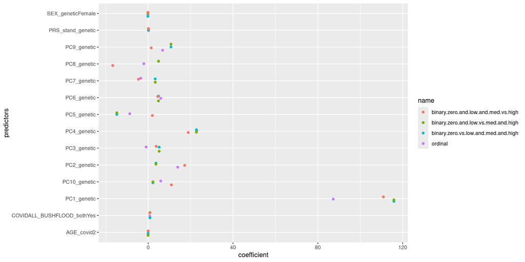

```r
coeffs2 <- coeffs %>%
  rownames_to_column() %>%
  pivot_longer(cols = 2:5)

ggplot(coeffs2, aes(x = value, y = rowname, group = name, colour = name)) +
  geom_jitter(height = 0.2) +
  labs(x = "coefficient", y = "predictors")
```

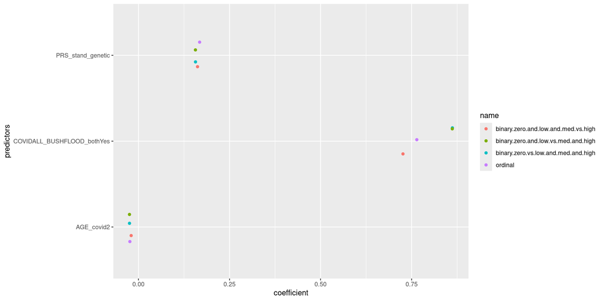

```r
coeffs3 <- coeffs2 %>%
  filter(rowname == 'PRS_stand_genetic' | rowname == 'COVIDALL_BUSHFLOOD_bothYes' | rowname == "AGE_covid2")

ggplot(coeffs3, aes(x = value, y = rowname, group = name, colour = name)) +
  geom_jitter(height = 0.2) +
  labs(x = "coefficient", y = "predictors")
```

- Goodness of fit OK
- Brant test shows proportional odds assumption violated for age
- But visual inspection shows PO looks good maybe a problem for bushfires/floods/covid exposure (and maybe bad for PC1)

#### Female

```r
### Test goodness of fit ###

# lipsitz test
lipsitz(Twenty19BushFloodCovidBoth_female_PO)
```

```
##
## Lipsitz Test:
##
##                       LR   df   pr(>chi)
## ordinal(lipsitz)   7.006    9     0.6365
##
## H0: No lack of fit dictated
```

```r
# pulkstenis-robinson test
# (requires the vector of categorical input variables as an argument)
pulkroben(Twenty19BushFloodCovidBoth_female_PO, test = c("chisq","deviance"), tables = FALSE)
```

```
##
## Pulkstenis-Robinson Chi-squared Test:
##
##                     chi-sq   df   pr(>chi)
## ordinal(pulkroben)  15.705    7    0.02795 *
## ---
## Signif. codes:  0 '***' 0.001 '**' 0.01 '*' 0.05 '.' 0.1 ' ' 1
##
## H0: No lack of fit dictated
##
## rho: 100%
```

```r
# Hosmer-Lemeshow test
hosmerlem(Twenty19BushFloodCovidBoth_female_PO)
```

```
##
## Hosmer-Lemeshow Test:
##
##                     Chi-sq  df  pr(>chi)
## ordinal(Hosmerlem)  14.456  26    0.9665
##
## H0: No lack of fit dictated
##
## rho: 100%
```

```r
### Test proportional odds assumption ###

# Brant Wald Test
# A generalized ordinal logistic regression model is approximated and compared to the calculated proportional odds model (a generalized ordinal logistic regression model is simply a relaxing of the proportional odds model to allow for different coefficients at each level of the ordinal outcome variable.)
# A Wald test is a hypothesis test of the significance of the difference in model coefficients, producing a chi-square statistic. A low p-value in a Brant-Wald test is an indicator that the coefficient does not satisfy the proportional odds assumption.
# A p-value of less than 0.05 on this test, particularly on the Omnibus plus at least one of the variables should be interpreted as a failure of the proportional odds assumption.

brant.test(Twenty19BushFloodCovidBoth_female_PO)
```

```
##
## Brant Test:
##                               chi-sq   df   pr(>chi)
## Omnibus                       39.078   26      0.048 *
## PRS_stand_genetic              0.641    2      0.726
## COVIDALL_BUSHFLOOD_bothYes     1.163    2      0.559
## AGE_covid2                     7.879    2      0.019 *
## PC1_genetic                    1.880    2      0.391
## PC2_genetic                    0.132    2      0.936
## PC3_genetic                    5.095    2      0.078 .
## PC4_genetic                    0.571    2      0.752
## PC5_genetic                    0.321    2      0.852
## PC6_genetic                    0.134    2      0.935
## PC7_genetic                    1.608    2      0.448
## PC8_genetic                    4.709    2      0.095 .
## PC9_genetic                    2.121    2      0.346
## PC10_genetic                   2.091    2      0.352
## ---
## Signif. codes:  0 '***' 0.001 '**' 0.01 '*' 0.05 '.' 0.1 ' ' 1
##
## H0: Proportional odds assumption holds
```

```r
# Sighting coefficients of stratified binomial models - want each to be similar
# create binary variables for every combo of the 3 categories
x <- df_ND_covid %>%
  mutate(SYMPzeroplus = case_when(
    NUMSYMPALL_covid2_cat == 'zero' ~ 0,
    NUMSYMPALL_covid2_cat == 'low' | NUMSYMPALL_covid2_cat == 'med' | NUMSYMPALL_covid2_cat == 'high' ~ 1
  ),
  SYMPlowplus = case_when(
    NUMSYMPALL_covid2_cat == 'zero' | NUMSYMPALL_covid2_cat == 'low' ~ 0,
    NUMSYMPALL_covid2_cat == 'medium' |  NUMSYMPALL_covid2_cat == 'high' ~ 1),
  SYMPmedplus = case_when(
    NUMSYMPALL_covid2_cat == 'zero' | NUMSYMPALL_covid2_cat == 'low' | NUMSYMPALL_covid2_cat == 'medium' ~ 0,
    NUMSYMPALL_covid2_cat == 'high' ~ 1)
  )


# Create logistic regression for each
zeroplus_model <- glm(SYMPzeroplus ~
                        PRS_stand_genetic +
                        COVIDALL_BUSHFLOOD_both +
                        AGE_covid2 +
                        PC1_genetic +
                        PC2_genetic +
                        PC3_genetic +
                        PC4_genetic +
                        PC5_genetic +
                        PC6_genetic +
                        PC7_genetic +
                        PC8_genetic +
                        PC9_genetic +
                        PC10_genetic,
                      family = binomial(link = 'logit'),
                      data = x[x$SEX_genetic == "Female", ])

lowplus_model <- glm(SYMPlowplus ~
                       PRS_stand_genetic +
                       COVIDALL_BUSHFLOOD_both +
                       AGE_covid2 +
                       PC1_genetic +
                       PC2_genetic +
                       PC3_genetic +
                       PC4_genetic +
                       PC5_genetic +
                       PC6_genetic +
                       PC7_genetic +
                       PC8_genetic +
                       PC9_genetic +
                       PC10_genetic,
                     family = binomial(link = 'logit'),
                     data = x[x$SEX_genetic == "Female", ])

medplus_model <- glm(SYMPmedplus ~
                       PRS_stand_genetic +
                       COVIDALL_BUSHFLOOD_both +
                       AGE_covid2 +
                       PC1_genetic +
                       PC2_genetic +
                       PC3_genetic +
                       PC4_genetic +
                       PC5_genetic +
                       PC6_genetic +
                       PC7_genetic +
                       PC8_genetic +
                       PC9_genetic +
                       PC10_genetic,
                     family = binomial(link = 'logit'),
                     data = x[x$SEX_genetic == "Female", ])


# display the coefficients of all models and examine the difference between them.
# coefficients (i.e. the slopes) should be similar for all models to hold the proportional odds assumption

# table
coeffs <- data.frame(
  'ordinal' = coef(Twenty19BushFloodCovidBoth_female_PO)[-c(1,2,3)],
  'binary zero vs low and med and high' = lowplus_model$coefficients[-1],
  'binary zero and low vs med and high' = lowplus_model$coefficients[-1],
  'binary zero and low and med vs high' = medplus_model$coefficients[-1])

coeffs %>%
  kable()
```

|  | ordinal | binary.zero.vs.low.and.med.and.high | binary.zero.and.low.vs.med.and.high | binary.zero.and.low.and.med.vs.high |
| --- | --- | --- | --- | --- |
| PRS_stand_genetic | 0.1190251 | 0.1330403 | 0.1330403 | 0.1011827 |
| COVIDALL_BUSHFLOOD_bothYes | 0.8086208 | 0.9606458 | 0.9606458 | 0.7594233 |
| AGE_covid2 | -0.0261641 | -0.0269922 | -0.0269922 | -0.0232405 |
| PC1_genetic | 76.9554859 | 70.1656152 | 70.1656152 | 142.7033578 |
| PC2_genetic | 23.5598425 | 12.8818899 | 12.8818899 | 32.1385037 |
| PC3_genetic | 15.6930300 | 22.4641831 | 22.4641831 | 33.2557715 |
| PC4_genetic | 5.3574296 | 4.7386791 | 4.7386791 | 4.8179497 |
| PC5_genetic | -13.1462138 | -18.6382797 | -18.6382797 | -8.5002669 |
| PC6_genetic | 8.8572385 | 10.7718571 | 10.7718571 | 7.3048192 |
| PC7_genetic | -1.6930653 | -1.0239188 | -1.0239188 | 1.2094912 |
| PC8_genetic | -2.9135633 | 6.2365995 | 6.2365995 | -17.7364677 |
| PC9_genetic | -0.1052774 | 9.1195239 | 9.1195239 | -11.1115097 |
| PC10_genetic | 5.1264659 | -1.1499821 | -1.1499821 | 14.3150530 |

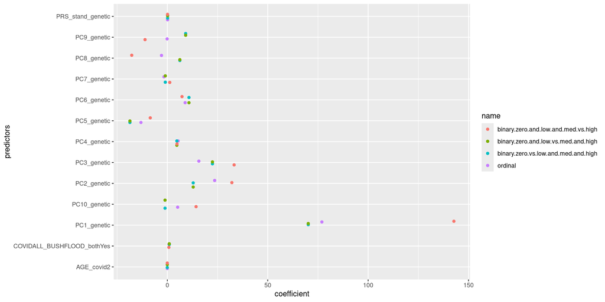

```r
coeffs2 <- coeffs %>%
  rownames_to_column() %>%
  pivot_longer(cols = 2:5)

ggplot(coeffs2, aes(x = value, y = rowname, group = name, colour = name)) +
  geom_jitter(height = 0.2) +
  labs(x = "coefficient", y = "predictors")
```

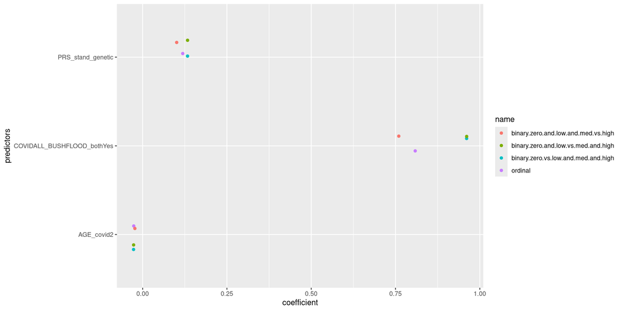

```r
coeffs3 <- coeffs2 %>%
  filter(rowname == 'PRS_stand_genetic' | rowname == 'COVIDALL_BUSHFLOOD_bothYes' | rowname == "AGE_covid2")

ggplot(coeffs3, aes(x = value, y = rowname, group = name, colour = name)) +
  geom_jitter(height = 0.2) +
  labs(x = "coefficient", y = "predictors")
```

#### Male

```r
### Test goodness of fit ###

# lipsitz test
lipsitz(Twenty19BushFloodCovidBoth_male_PO)
```

```
##
## Lipsitz Test:
##
##                       LR   df   pr(>chi)
## ordinal(lipsitz)   13.68    9     0.1342
##
## H0: No lack of fit dictated
```

```r
# pulkstenis-robinson test
# (requires the vector of categorical input variables as an argument)
pulkroben(Twenty19BushFloodCovidBoth_male_PO, test = c("chisq","deviance"), tables = FALSE)
```

```
##
## Pulkstenis-Robinson Chi-squared Test:
##
##                     chi-sq   df   pr(>chi)
## ordinal(pulkroben)  11.701    7     0.1108
##
## H0: No lack of fit dictated
##
## rho: 87.5%
```

```r
# Hosmer-Lemeshow test
hosmerlem(Twenty19BushFloodCovidBoth_male_PO)
```

```
##
## Hosmer-Lemeshow Test:
##
##                     Chi-sq  df  pr(>chi)
## ordinal(Hosmerlem)  25.932  26    0.4668
##
## H0: No lack of fit dictated
##
## rho: 100%
```

```r
### Test proportional odds assumption ###

# Brant Wald Test
# A generalized ordinal logistic regression model is approximated and compared to the calculated proportional odds model (a generalized ordinal logistic regression model is simply a relaxing of the proportional odds model to allow for different coefficients at each level of the ordinal outcome variable.)
# A Wald test is a hypothesis test of the significance of the difference in model coefficients, producing a chi-square statistic. A low p-value in a Brant-Wald test is an indicator that the coefficient does not satisfy the proportional odds assumption.
# A p-value of less than 0.05 on this test, particularly on the Omnibus plus at least one of the variables should be interpreted as a failure of the proportional odds assumption.

brant.test(Twenty19BushFloodCovidBoth_male_PO)
```

```
##
## Brant Test:
##                               chi-sq   df   pr(>chi)
## Omnibus                       28.597   26      0.330
## PRS_stand_genetic              6.023    2      0.049 *
## COVIDALL_BUSHFLOOD_bothYes     0.253    2      0.881
## AGE_covid2                     1.213    2      0.545
## PC1_genetic                    3.415    2      0.181
## PC2_genetic                    0.137    2      0.934
## PC3_genetic                    0.417    2      0.812
## PC4_genetic                    0.070    2      0.966
## PC5_genetic                    5.410    2      0.067 .
## PC6_genetic                    4.166    2      0.125
## PC7_genetic                    5.904    2      0.052 .
## PC8_genetic                    2.812    2      0.245
## PC9_genetic                    1.871    2      0.392
## PC10_genetic                   0.214    2      0.898
## ---
## Signif. codes:  0 '***' 0.001 '**' 0.01 '*' 0.05 '.' 0.1 ' ' 1
##
## H0: Proportional odds assumption holds
```

```r
# Sighting coefficients of stratified binomial models - want each to be similar
# create binary variables for every combo of the 3 categories
x <- df_ND_covid %>%
  mutate(SYMPzeroplus = case_when(
    NUMSYMPALL_covid2_cat == 'zero' ~ 0,
    NUMSYMPALL_covid2_cat == 'low' | NUMSYMPALL_covid2_cat == 'med' | NUMSYMPALL_covid2_cat == 'high' ~ 1
  ),
  SYMPlowplus = case_when(
    NUMSYMPALL_covid2_cat == 'zero' | NUMSYMPALL_covid2_cat == 'low' ~ 0,
    NUMSYMPALL_covid2_cat == 'medium' |  NUMSYMPALL_covid2_cat == 'high' ~ 1),
  SYMPmedplus = case_when(
    NUMSYMPALL_covid2_cat == 'zero' | NUMSYMPALL_covid2_cat == 'low' | NUMSYMPALL_covid2_cat == 'medium' ~ 0,
    NUMSYMPALL_covid2_cat == 'high' ~ 1)
  )


# Create logistic regression for each
zeroplus_model <- glm(SYMPzeroplus ~
                        PRS_stand_genetic +
                        COVIDALL_BUSHFLOOD_both +
                        AGE_covid2 +
                        PC1_genetic +
                        PC2_genetic +
                        PC3_genetic +
                        PC4_genetic +
                        PC5_genetic +
                        PC6_genetic +
                        PC7_genetic +
                        PC8_genetic +
                        PC9_genetic +
                        PC10_genetic,
                      family = binomial(link = 'logit'),
                      data = x[x$SEX_genetic == "Male", ])

lowplus_model <- glm(SYMPlowplus ~
                       PRS_stand_genetic +
                       COVIDALL_BUSHFLOOD_both +
                       AGE_covid2 +
                       PC1_genetic +
                       PC2_genetic +
                       PC3_genetic +
                       PC4_genetic +
                       PC5_genetic +
                       PC6_genetic +
                       PC7_genetic +
                       PC8_genetic +
                       PC9_genetic +
                       PC10_genetic,
                     family = binomial(link = 'logit'),
                     data = x[x$SEX_genetic == "Male", ])

medplus_model <- glm(SYMPmedplus ~
                       PRS_stand_genetic +
                       COVIDALL_BUSHFLOOD_both +
                       AGE_covid2 +
                       PC1_genetic +
                       PC2_genetic +
                       PC3_genetic +
                       PC4_genetic +
                       PC5_genetic +
                       PC6_genetic +
                       PC7_genetic +
                       PC8_genetic +
                       PC9_genetic +
                       PC10_genetic,
                     family = binomial(link = 'logit'),
                     data = x[x$SEX_genetic == "Male", ])


# display the coefficients of all models and examine the difference between them.
# coefficients (i.e. the slopes) should be similar for all models to hold the proportional odds assumption

# table
coeffs <- data.frame(
  'ordinal' = coef(Twenty19BushFloodCovidBoth_male_PO)[-c(1,2,3)],
  'binary zero vs low and med and high' = lowplus_model$coefficients[-1],
  'binary zero and low vs med and high' = lowplus_model$coefficients[-1],
  'binary zero and low and med vs high' = medplus_model$coefficients[-1])

coeffs %>%
  kable()
```

|  | ordinal | binary.zero.vs.low.and.med.and.high | binary.zero.and.low.vs.med.and.high | binary.zero.and.low.and.med.vs.high |
| --- | --- | --- | --- | --- |
| PRS_stand_genetic | 0.3250864 | 0.2282561 | 0.2282561 | 0.3669492 |
| COVIDALL_BUSHFLOOD_bothYes | 0.6073517 | 0.4803081 | 0.4803081 | 0.7069503 |
| AGE_covid2 | -0.0169683 | -0.0201313 | -0.0201313 | -0.0128439 |
| PC1_genetic | 132.6862512 | 322.8580376 | 322.8580376 | 28.5336051 |
| PC2_genetic | -105.1058259 | -96.5027475 | -96.5027475 | -120.8646468 |
| PC3_genetic | -124.8948711 | -108.0966780 | -108.0966780 | -147.3340041 |
| PC4_genetic | 109.8056730 | 107.4456152 | 107.4456152 | 98.7786635 |
| PC5_genetic | -3.3146987 | -8.2159788 | -8.2159788 | 31.3453502 |
| PC6_genetic | -9.0162022 | -22.2332963 | -22.2332963 | -10.1391125 |
| PC7_genetic | -6.0476995 | 24.5187713 | 24.5187713 | -25.9440166 |
| PC8_genetic | -3.4990231 | -0.3198636 | -0.3198636 | -25.7619036 |
| PC9_genetic | 34.2914031 | 19.7691727 | 19.7691727 | 51.5868163 |
| PC10_genetic | 6.9071908 | 10.7854456 | 10.7854456 | -0.0727887 |

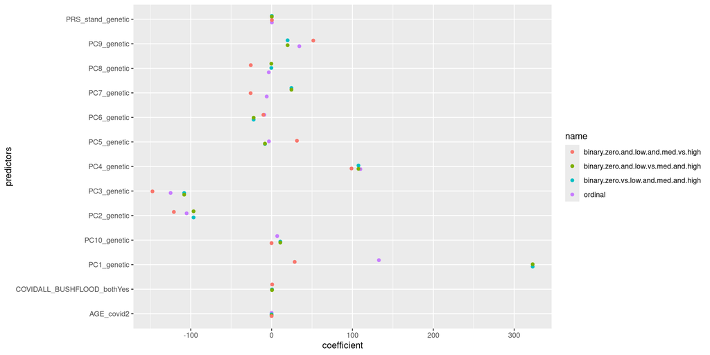

```r
coeffs2 <- coeffs %>%
  rownames_to_column() %>%
  pivot_longer(cols = 2:5)

ggplot(coeffs2, aes(x = value, y = rowname, group = name, colour = name)) +
  geom_jitter(height = 0.2) +
  labs(x = "coefficient", y = "predictors")
```

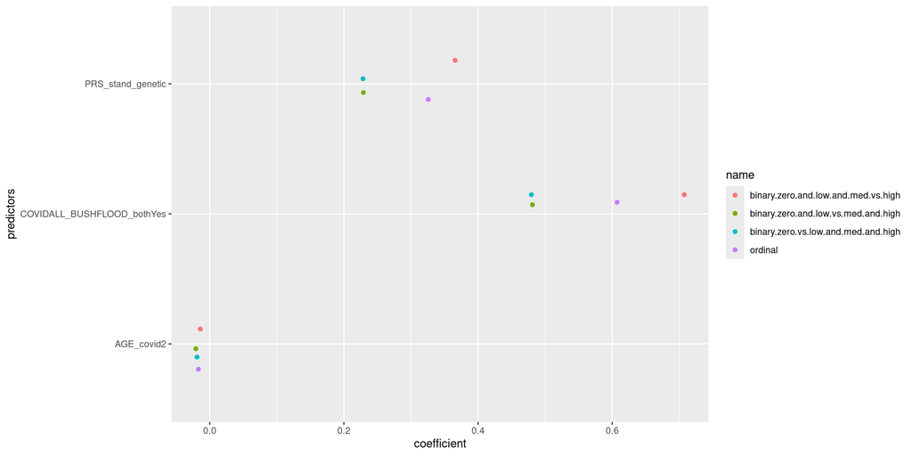

```r
coeffs3 <- coeffs2 %>%
  filter(rowname == 'PRS_stand_genetic' | rowname == 'COVIDALL_BUSHFLOOD_bothYes' | rowname == "AGE_covid2")

ggplot(coeffs3, aes(x = value, y = rowname, group = name, colour = name)) +
  geom_jitter(height = 0.2) +
  labs(x = "coefficient", y = "predictors")
```

- Goodness of fit OK
- Brant test shows proportional odds assumption OK
- Visual inspection shows PO looks good, maybe a problem for bushfires/floods/covid exposure

### Partial Proportional Odds

#### Both Sexes

```r
# LRT to compare partial PO to PO models
lrtest(Twenty19BushFloodCovidBoth_PO, Twenty19BushFloodCovidBoth_PartPO_NDexpos)
```

```
## Likelihood ratio test
##
## Model 1: NUMSYMPALL_covid2_cat ~ PRS_stand_genetic + COVIDALL_BUSHFLOOD_both +
##     AGE_covid2 + SEX_genetic + PC1_genetic + PC2_genetic + PC3_genetic +
##     PC4_genetic + PC5_genetic + PC6_genetic + PC7_genetic + PC8_genetic +
##     PC9_genetic + PC10_genetic
## Model 2: NUMSYMPALL_covid2_cat ~ PRS_stand_genetic + COVIDALL_BUSHFLOOD_both +
##     AGE_covid2 + SEX_genetic + PC1_genetic + PC2_genetic + PC3_genetic +
##     PC4_genetic + PC5_genetic + PC6_genetic + PC7_genetic + PC8_genetic +
##     PC9_genetic + PC10_genetic
##    #Df  LogLik Df  Chisq Pr(>Chisq)
## 1 6253 -2594.2
## 2 6251 -2594.0 -2 0.5029     0.7777
```

```r
lrtest(Twenty19BushFloodCovidBoth_PO, Twenty19BushFloodCovidBoth_PartPO_PRS)
```

```
## Likelihood ratio test
##
## Model 1: NUMSYMPALL_covid2_cat ~ PRS_stand_genetic + COVIDALL_BUSHFLOOD_both +
##     AGE_covid2 + SEX_genetic + PC1_genetic + PC2_genetic + PC3_genetic +
##     PC4_genetic + PC5_genetic + PC6_genetic + PC7_genetic + PC8_genetic +
##     PC9_genetic + PC10_genetic
## Model 2: NUMSYMPALL_covid2_cat ~ PRS_stand_genetic + COVIDALL_BUSHFLOOD_both +
##     AGE_covid2 + SEX_genetic + PC1_genetic + PC2_genetic + PC3_genetic +
##     PC4_genetic + PC5_genetic + PC6_genetic + PC7_genetic + PC8_genetic +
##     PC9_genetic + PC10_genetic
##    #Df  LogLik Df  Chisq Pr(>Chisq)
## 1 6253 -2594.2
## 2 6251 -2594.0 -2 0.4568     0.7958
```

```r
lrtest(Twenty19BushFloodCovidBoth_PO, Twenty19BushFloodCovidBoth_PartPO_NDexpos_PRS)
```

```
## Likelihood ratio test
##
## Model 1: NUMSYMPALL_covid2_cat ~ PRS_stand_genetic + COVIDALL_BUSHFLOOD_both +
##     AGE_covid2 + SEX_genetic + PC1_genetic + PC2_genetic + PC3_genetic +
##     PC4_genetic + PC5_genetic + PC6_genetic + PC7_genetic + PC8_genetic +
##     PC9_genetic + PC10_genetic
## Model 2: NUMSYMPALL_covid2_cat ~ PRS_stand_genetic + COVIDALL_BUSHFLOOD_both +
##     AGE_covid2 + SEX_genetic + PC1_genetic + PC2_genetic + PC3_genetic +
##     PC4_genetic + PC5_genetic + PC6_genetic + PC7_genetic + PC8_genetic +
##     PC9_genetic + PC10_genetic
##    #Df  LogLik Df  Chisq Pr(>Chisq)
## 1 6253 -2594.2
## 2 6249 -2593.8 -4 0.9804     0.9128
```

```r
### Test goodness of fit ###

# lipsitz test
lipsitz(Twenty19BushFloodCovidBoth_PartPO_NDexpos)
```

```
##
## Lipsitz Test:
##
##                       LR   df   pr(>chi)
## ordinal(lipsitz)  15.901    9    0.06898 .
## ---
## Signif. codes:  0 '***' 0.001 '**' 0.01 '*' 0.05 '.' 0.1 ' ' 1
##
## H0: No lack of fit dictated
```

```r
lipsitz(Twenty19BushFloodCovidBoth_PartPO_PRS)
```

```
##
## Lipsitz Test:
##
##                       LR   df   pr(>chi)
## ordinal(lipsitz)  14.157    9     0.1169
##
## H0: No lack of fit dictated
```

```r
lipsitz(Twenty19BushFloodCovidBoth_PartPO_NDexpos_PRS)
```

```
##
## Lipsitz Test:
##
##                       LR   df   pr(>chi)
## ordinal(lipsitz)   14.94    9    0.09259 .
## ---
## Signif. codes:  0 '***' 0.001 '**' 0.01 '*' 0.05 '.' 0.1 ' ' 1
##
## H0: No lack of fit dictated
```

```r
# pulkstenis-robinson test
# (requires the vector of categorical input variables as an argument)
pulkroben(Twenty19BushFloodCovidBoth_PartPO_NDexpos, test = c("chisq","deviance"), tables = FALSE)
```

```
##
## Pulkstenis-Robinson Chi-squared Test:
##
##                     chi-sq   df   pr(>chi)
## ordinal(pulkroben)  20.066   18     0.3291
##
## H0: No lack of fit dictated
##
## rho: 93.75%
```

```r
pulkroben(Twenty19BushFloodCovidBoth_PartPO_PRS, test = c("chisq","deviance"), tables = FALSE)
```

```
##
## Pulkstenis-Robinson Chi-squared Test:
##
##                     chi-sq   df   pr(>chi)
## ordinal(pulkroben)  20.448   18     0.3082
##
## H0: No lack of fit dictated
##
## rho: 93.75%
```

```r
pulkroben(Twenty19BushFloodCovidBoth_PartPO_NDexpos_PRS, test = c("chisq","deviance"), tables = FALSE)
```

```
##
## Pulkstenis-Robinson Chi-squared Test:
##
##                     chi-sq   df   pr(>chi)
## ordinal(pulkroben)  19.741   18     0.3476
##
## H0: No lack of fit dictated
##
## rho: 93.75%
```

```r
# Hosmer-Lemeshow test
hosmerlem(Twenty19BushFloodCovidBoth_PartPO_NDexpos)
```

```
##
## Hosmer-Lemeshow Test:
##
##                     Chi-sq  df  pr(>chi)
## ordinal(Hosmerlem)  27.765  26    0.3701
##
## H0: No lack of fit dictated
##
## rho: 100%
```

```r
hosmerlem(Twenty19BushFloodCovidBoth_PartPO_PRS)
```

```
##
## Hosmer-Lemeshow Test:
##
##                     Chi-sq  df  pr(>chi)
## ordinal(Hosmerlem)  27.033  26    0.4076
##
## H0: No lack of fit dictated
##
## rho: 100%
```

```r
hosmerlem(Twenty19BushFloodCovidBoth_PartPO_PRS)
```

```
##
## Hosmer-Lemeshow Test:
##
##                     Chi-sq  df  pr(>chi)
## ordinal(Hosmerlem)  27.033  26    0.4076
##
## H0: No lack of fit dictated
##
## rho: 100%
```

- Relaxing PO assumption for ND/COVID exposure and/or PRS does not significantly improve model
- So best to use PO model

#### Female

```r
# LRT to compare partial PO to PO models
lrtest(Twenty19BushFloodCovidBoth_female_PO, Twenty19BushFloodCovidBoth_female_PartPO_NDexpos)
```

```
## Likelihood ratio test
##
## Model 1: NUMSYMPALL_covid2_cat ~ PRS_stand_genetic + COVIDALL_BUSHFLOOD_both +
##     AGE_covid2 + PC1_genetic + PC2_genetic + PC3_genetic + PC4_genetic +
##     PC5_genetic + PC6_genetic + PC7_genetic + PC8_genetic + PC9_genetic +
##     PC10_genetic
## Model 2: NUMSYMPALL_covid2_cat ~ PRS_stand_genetic + COVIDALL_BUSHFLOOD_both +
##     AGE_covid2 + PC1_genetic + PC2_genetic + PC3_genetic + PC4_genetic +
##     PC5_genetic + PC6_genetic + PC7_genetic + PC8_genetic + PC9_genetic +
##     PC10_genetic
##    #Df  LogLik Df  Chisq Pr(>Chisq)
## 1 4610 -1900.4
## 2 4608 -1899.9 -2 1.0654      0.587
```

```r
lrtest(Twenty19BushFloodCovidBoth_female_PO, Twenty19BushFloodCovidBoth_female_PartPO_PRS)
```

```
## Likelihood ratio test
##
## Model 1: NUMSYMPALL_covid2_cat ~ PRS_stand_genetic + COVIDALL_BUSHFLOOD_both +
##     AGE_covid2 + PC1_genetic + PC2_genetic + PC3_genetic + PC4_genetic +
##     PC5_genetic + PC6_genetic + PC7_genetic + PC8_genetic + PC9_genetic +
##     PC10_genetic
## Model 2: NUMSYMPALL_covid2_cat ~ PRS_stand_genetic + COVIDALL_BUSHFLOOD_both +
##     AGE_covid2 + PC1_genetic + PC2_genetic + PC3_genetic + PC4_genetic +
##     PC5_genetic + PC6_genetic + PC7_genetic + PC8_genetic + PC9_genetic +
##     PC10_genetic
##    #Df  LogLik Df Chisq Pr(>Chisq)
## 1 4610 -1900.4
## 2 4608 -1900.2 -2  0.44     0.8025
```

```r
lrtest(Twenty19BushFloodCovidBoth_female_PO, Twenty19BushFloodCovidBoth_female_PartPO_NDexpos_PRS)
```

```
## Likelihood ratio test
##
## Model 1: NUMSYMPALL_covid2_cat ~ PRS_stand_genetic + COVIDALL_BUSHFLOOD_both +
##     AGE_covid2 + PC1_genetic + PC2_genetic + PC3_genetic + PC4_genetic +
##     PC5_genetic + PC6_genetic + PC7_genetic + PC8_genetic + PC9_genetic +
##     PC10_genetic
## Model 2: NUMSYMPALL_covid2_cat ~ PRS_stand_genetic + COVIDALL_BUSHFLOOD_both +
##     AGE_covid2 + PC1_genetic + PC2_genetic + PC3_genetic + PC4_genetic +
##     PC5_genetic + PC6_genetic + PC7_genetic + PC8_genetic + PC9_genetic +
##     PC10_genetic
##    #Df  LogLik Df  Chisq Pr(>Chisq)
## 1 4610 -1900.4
## 2 4606 -1899.7 -4 1.5286     0.8216
```

```r
### Test goodness of fit ###

# lipsitz test
lipsitz(Twenty19BushFloodCovidBoth_female_PartPO_NDexpos)
```

```
##
## Lipsitz Test:
##
##                       LR   df   pr(>chi)
## ordinal(lipsitz)   7.499    9     0.5853
##
## H0: No lack of fit dictated
```

```r
lipsitz(Twenty19BushFloodCovidBoth_female_PartPO_PRS)
```

```
##
## Lipsitz Test:
##
##                       LR   df   pr(>chi)
## ordinal(lipsitz)  7.1032    9     0.6264
##
## H0: No lack of fit dictated
```

```r
lipsitz(Twenty19BushFloodCovidBoth_female_PartPO_NDexpos_PRS)
```

```
##
## Lipsitz Test:
##
##                       LR   df   pr(>chi)
## ordinal(lipsitz)  7.0671    9     0.6301
##
## H0: No lack of fit dictated
```

```r
# pulkstenis-robinson test
# (requires the vector of categorical input variables as an argument)
pulkroben(Twenty19BushFloodCovidBoth_female_PartPO_NDexpos, test = c("chisq","deviance"), tables = FALSE)
```

```
##
## Pulkstenis-Robinson Chi-squared Test:
##
##                     chi-sq   df   pr(>chi)
## ordinal(pulkroben)   14.97    7    0.03638 *
## ---
## Signif. codes:  0 '***' 0.001 '**' 0.01 '*' 0.05 '.' 0.1 ' ' 1
##
## H0: No lack of fit dictated
##
## rho: 100%
```

```r
pulkroben(Twenty19BushFloodCovidBoth_female_PartPO_PRS, test = c("chisq","deviance"), tables = FALSE)
```

```
##
## Pulkstenis-Robinson Chi-squared Test:
##
##                     chi-sq   df   pr(>chi)
## ordinal(pulkroben)  14.392    7    0.04463 *
## ---
## Signif. codes:  0 '***' 0.001 '**' 0.01 '*' 0.05 '.' 0.1 ' ' 1
##
## H0: No lack of fit dictated
##
## rho: 100%
```

```r
pulkroben(Twenty19BushFloodCovidBoth_female_PartPO_NDexpos_PRS, test = c("chisq","deviance"), tables = FALSE)
```

```
##
## Pulkstenis-Robinson Chi-squared Test:
##
##                     chi-sq   df   pr(>chi)
## ordinal(pulkroben)  13.367    7    0.06366 .
## ---
## Signif. codes:  0 '***' 0.001 '**' 0.01 '*' 0.05 '.' 0.1 ' ' 1
##
## H0: No lack of fit dictated
##
## rho: 100%
```

```r
# Hosmer-Lemeshow test
hosmerlem(Twenty19BushFloodCovidBoth_female_PartPO_NDexpos)
```

```
##
## Hosmer-Lemeshow Test:
##
##                     Chi-sq  df  pr(>chi)
## ordinal(Hosmerlem)  14.677  26     0.963
##
## H0: No lack of fit dictated
##
## rho: 100%
```

```r
hosmerlem(Twenty19BushFloodCovidBoth_female_PartPO_PRS)
```

```
##
## Hosmer-Lemeshow Test:
##
##                     Chi-sq  df  pr(>chi)
## ordinal(Hosmerlem)  15.115  26    0.9552
##
## H0: No lack of fit dictated
##
## rho: 100%
```

```r
hosmerlem(Twenty19BushFloodCovidBoth_female_PartPO_PRS)
```

```
##
## Hosmer-Lemeshow Test:
##
##                     Chi-sq  df  pr(>chi)
## ordinal(Hosmerlem)  15.115  26    0.9552
##
## H0: No lack of fit dictated
##
## rho: 100%
```

- Relaxing PO assumption for ND exposure and/or PRS does not significantly improve model
- So best to use PO model

#### Male

```r
# LRT to compare partial PO to PO models
lrtest(Twenty19BushFloodCovidBoth_male_PO, Twenty19BushFloodCovidBoth_male_PartPO_NDexpos)
```

```
## Likelihood ratio test
##
## Model 1: NUMSYMPALL_covid2_cat ~ PRS_stand_genetic + COVIDALL_BUSHFLOOD_both +
##     AGE_covid2 + PC1_genetic + PC2_genetic + PC3_genetic + PC4_genetic +
##     PC5_genetic + PC6_genetic + PC7_genetic + PC8_genetic + PC9_genetic +
##     PC10_genetic
## Model 2: NUMSYMPALL_covid2_cat ~ PRS_stand_genetic + COVIDALL_BUSHFLOOD_both +
##     AGE_covid2 + PC1_genetic + PC2_genetic + PC3_genetic + PC4_genetic +
##     PC5_genetic + PC6_genetic + PC7_genetic + PC8_genetic + PC9_genetic +
##     PC10_genetic
##    #Df  LogLik Df  Chisq Pr(>Chisq)
## 1 1628 -685.07
## 2 1626 -685.00 -2 0.1486     0.9284
```

```r
lrtest(Twenty19BushFloodCovidBoth_male_PO, Twenty19BushFloodCovidBoth_male_PartPO_PRS)
```

```
## Likelihood ratio test
##
## Model 1: NUMSYMPALL_covid2_cat ~ PRS_stand_genetic + COVIDALL_BUSHFLOOD_both +
##     AGE_covid2 + PC1_genetic + PC2_genetic + PC3_genetic + PC4_genetic +
##     PC5_genetic + PC6_genetic + PC7_genetic + PC8_genetic + PC9_genetic +
##     PC10_genetic
## Model 2: NUMSYMPALL_covid2_cat ~ PRS_stand_genetic + COVIDALL_BUSHFLOOD_both +
##     AGE_covid2 + PC1_genetic + PC2_genetic + PC3_genetic + PC4_genetic +
##     PC5_genetic + PC6_genetic + PC7_genetic + PC8_genetic + PC9_genetic +
##     PC10_genetic
##    #Df  LogLik Df  Chisq Pr(>Chisq)
## 1 1628 -685.07
## 2 1626 -682.84 -2 4.4639     0.1073
```

```r
lrtest(Twenty19BushFloodCovidBoth_male_PO, Twenty19BushFloodCovidBoth_male_PartPO_NDexpos_PRS)
```

```
## Likelihood ratio test
##
## Model 1: NUMSYMPALL_covid2_cat ~ PRS_stand_genetic + COVIDALL_BUSHFLOOD_both +
##     AGE_covid2 + PC1_genetic + PC2_genetic + PC3_genetic + PC4_genetic +
##     PC5_genetic + PC6_genetic + PC7_genetic + PC8_genetic + PC9_genetic +
##     PC10_genetic
## Model 2: NUMSYMPALL_covid2_cat ~ PRS_stand_genetic + COVIDALL_BUSHFLOOD_both +
##     AGE_covid2 + PC1_genetic + PC2_genetic + PC3_genetic + PC4_genetic +
##     PC5_genetic + PC6_genetic + PC7_genetic + PC8_genetic + PC9_genetic +
##     PC10_genetic
##    #Df  LogLik Df  Chisq Pr(>Chisq)
## 1 1628 -685.07
## 2 1624 -682.80 -4 4.5462     0.3371
```

```r
### Test goodness of fit ###

# lipsitz test
lipsitz(Twenty19BushFloodCovidBoth_male_PartPO_NDexpos)
```

```
##
## Lipsitz Test:
##
##                       LR   df   pr(>chi)
## ordinal(lipsitz)   15.54    9    0.07713 .
## ---
## Signif. codes:  0 '***' 0.001 '**' 0.01 '*' 0.05 '.' 0.1 ' ' 1
##
## H0: No lack of fit dictated
```

```r
lipsitz(Twenty19BushFloodCovidBoth_male_PartPO_PRS)
```

```
##
## Lipsitz Test:
##
##                       LR   df   pr(>chi)
## ordinal(lipsitz)   14.51    9     0.1053
##
## H0: No lack of fit dictated
```

```r
lipsitz(Twenty19BushFloodCovidBoth_male_PartPO_NDexpos_PRS)
```

```
##
## Lipsitz Test:
##
##                       LR   df   pr(>chi)
## ordinal(lipsitz)  14.468    9     0.1066
##
## H0: No lack of fit dictated
```

```r
# pulkstenis-robinson test
# (requires the vector of categorical input variables as an argument)
pulkroben(Twenty19BushFloodCovidBoth_male_PartPO_NDexpos, test = c("chisq","deviance"), tables = FALSE)
```

```
##
## Pulkstenis-Robinson Chi-squared Test:
##
##                     chi-sq   df   pr(>chi)
## ordinal(pulkroben)   10.47    7     0.1635
##
## H0: No lack of fit dictated
##
## rho: 87.5%
```

```r
pulkroben(Twenty19BushFloodCovidBoth_male_PartPO_PRS, test = c("chisq","deviance"), tables = FALSE)
```

```
##
## Pulkstenis-Robinson Chi-squared Test:
##
##                     chi-sq   df   pr(>chi)
## ordinal(pulkroben)  5.7635    7     0.5676
##
## H0: No lack of fit dictated
##
## rho: 87.5%
```

```r
pulkroben(Twenty19BushFloodCovidBoth_male_PartPO_NDexpos_PRS, test = c("chisq","deviance"), tables = FALSE)
```

```
##
## Pulkstenis-Robinson Chi-squared Test:
##
##                     chi-sq   df   pr(>chi)
## ordinal(pulkroben)  5.7113    7     0.5738
##
## H0: No lack of fit dictated
##
## rho: 87.5%
```

```r
# Hosmer-Lemeshow test
hosmerlem(Twenty19BushFloodCovidBoth_male_PartPO_NDexpos)
```

```
##
## Hosmer-Lemeshow Test:
##
##                     Chi-sq  df  pr(>chi)
## ordinal(Hosmerlem)  25.184  26    0.5086
##
## H0: No lack of fit dictated
##
## rho: 100%
```

```r
hosmerlem(Twenty19BushFloodCovidBoth_male_PartPO_PRS)
```

```
##
## Hosmer-Lemeshow Test:
##
##                     Chi-sq  df  pr(>chi)
## ordinal(Hosmerlem)  21.737  26     0.703
##
## H0: No lack of fit dictated
##
## rho: 100%
```

```r
hosmerlem(Twenty19BushFloodCovidBoth_male_PartPO_PRS)
```

```
##
## Hosmer-Lemeshow Test:
##
##                     Chi-sq  df  pr(>chi)
## ordinal(Hosmerlem)  21.737  26     0.703
##
## H0: No lack of fit dictated
##
## rho: 100%
```

- Relaxing PO assumption for ND exposure and/or PRS does not significantly improve model
- So best to use PO model

## Model Investigation

### Proportional Odds

#### Both Sexes

##### Results

```r
summary(Twenty19BushFloodCovidBoth_PO)
```

```
##
## Call:
## VGAM::vglm(formula = NUMSYMPALL_covid2_cat ~ PRS_stand_genetic +
##     COVIDALL_BUSHFLOOD_both + AGE_covid2 + SEX_genetic + PC1_genetic +
##     PC2_genetic + PC3_genetic + PC4_genetic + PC5_genetic + PC6_genetic +
##     PC7_genetic + PC8_genetic + PC9_genetic + PC10_genetic, family = VGAM::cumulative(logitlink,
##     parallel = T, reverse = T), data = df_ND_covid)
##
## Coefficients:
##                             Estimate Std. Error z value Pr(>|z|)
## (Intercept):1               2.997011   1.111312   2.697    0.007 **
## (Intercept):2               1.096892   1.108970   0.989    0.323
## (Intercept):3              -0.534743   1.108727  -0.482    0.630
## PRS_stand_genetic           0.167607   0.040962   4.092 4.28e-05 ***
## COVIDALL_BUSHFLOOD_bothYes  0.764843   0.172419   4.436 9.17e-06 ***
## AGE_covid2                 -0.023768   0.002842  -8.363  < 2e-16 ***
## SEX_geneticFemale          -0.091604   0.093224  -0.983    0.326
## PC1_genetic                87.267237  80.812072   1.080    0.280
## PC2_genetic                13.955558  37.909832   0.368    0.713
## PC3_genetic                -0.981069  22.935302  -0.043    0.966
## PC4_genetic                22.951520  24.467319   0.938    0.348
## PC5_genetic                -8.680157  14.384180  -0.603    0.546
## PC6_genetic                 5.933654   6.516205   0.911    0.363
## PC7_genetic                -3.457018  13.140918  -0.263    0.792
## PC8_genetic                -2.049867  11.521763  -0.178    0.859
## PC9_genetic                 6.818305   9.681832   0.704    0.481
## PC10_genetic                5.931809   9.681905   0.613    0.540
## ---
## Signif. codes:  0 '***' 0.001 '**' 0.01 '*' 0.05 '.' 0.1 ' ' 1
##
## Names of linear predictors: logitlink(P[Y>=2]), logitlink(P[Y>=3]),
## logitlink(P[Y>=4])
##
## Residual deviance: 5188.479 on 6253 degrees of freedom
##
## Log-likelihood: -2594.24 on 6253 degrees of freedom
##
## Number of Fisher scoring iterations: 4
##
##
## Exponentiated coefficients:
##          PRS_stand_genetic COVIDALL_BUSHFLOOD_bothYes
##               1.182472e+00               2.148657e+00
##                 AGE_covid2          SEX_geneticFemale
##               9.765118e-01               9.124668e-01
##                PC1_genetic                PC2_genetic
##               7.937422e+37               1.150328e+06
##                PC3_genetic                PC4_genetic
##               3.749101e-01               9.283640e+09
##                PC5_genetic                PC6_genetic
##               1.699244e-04               3.775313e+02
##                PC7_genetic                PC8_genetic
##               3.152364e-02               1.287520e-01
##                PC9_genetic               PC10_genetic
##               9.144337e+02               3.768355e+02
```

```r
# Create nice summary of results, including back transformation to give OR and calculating 95% CI
CI <- as.data.frame(confint(Twenty19BushFloodCovidBoth_PO)) %>%
  rownames_to_column() %>%
  rename('lower_95_CI_of_beta' = "2.5 %",
         'upper_95_CI_of_beta' = "97.5 %") %>%
  mutate(lower_95_CI_of_OR = exp(lower_95_CI_of_beta),
         upper_95_CI_of_OR = exp(upper_95_CI_of_beta))

beta <- as.data.frame(coef(Twenty19BushFloodCovidBoth_PO)) %>%
  rownames_to_column() %>%
  rename("beta" = "coef(Twenty19BushFloodCovidBoth_PO)") %>%
  mutate(OR = exp(beta))

results <- beta %>%
  full_join(CI) %>%
  relocate(rowname, beta, lower_95_CI_of_beta, upper_95_CI_of_beta, OR, lower_95_CI_of_OR, upper_95_CI_of_OR)

results %>% kable()
```

| rowname | beta | lower_95_CI_of_beta | upper_95_CI_of_beta | OR | lower_95_CI_of_OR | upper_95_CI_of_OR |
| --- | --- | --- | --- | --- | --- | --- |
| (Intercept):1 | 2.9970110 | 0.8188796 | 5.1751425 | 2.002559e+01 | 2.2679574 | 1.768218e+02 |
| (Intercept):2 | 1.0968924 | -1.0766494 | 3.2704342 | 2.994845e+00 | 0.3407353 | 2.632277e+01 |
| (Intercept):3 | -0.5347433 | -2.7078092 | 1.6383227 | 5.858197e-01 | 0.0666827 | 5.146530e+00 |
| PRS_stand_genetic | 0.1676075 | 0.0873243 | 0.2478907 | 1.182472e+00 | 1.0912505 | 1.281320e+00 |
| COVIDALL_BUSHFLOOD_bothYes | 0.7648431 | 0.4269076 | 1.1027786 | 2.148657e+00 | 1.5325111 | 3.012525e+00 |
| AGE_covid2 | -0.0237685 | -0.0293391 | -0.0181978 | 9.765118e-01 | 0.9710871 | 9.819667e-01 |
| SEX_geneticFemale | -0.0916036 | -0.2743187 | 0.0911114 | 9.124668e-01 | 0.7600898 | 1.095391e+00 |
| PC1_genetic | 87.2672370 | -71.1215134 | 245.6559874 | 7.937422e+37 | 0.0000000 | 4.864518e+106 |
| PC2_genetic | 13.9555579 | -60.3463467 | 88.2574625 | 1.150328e+06 | 0.0000000 | 2.136628e+38 |
| PC3_genetic | -0.9810690 | -45.9334340 | 43.9712959 | 3.749101e-01 | 0.0000000 | 1.248795e+19 |
| PC4_genetic | 22.9515196 | -25.0035452 | 70.9065843 | 9.283640e+09 | 0.0000000 | 6.227852e+30 |
| PC5_genetic | -8.6801569 | -36.8726311 | 19.5123174 | 1.699000e-04 | 0.0000000 | 2.979146e+08 |
| PC6_genetic | 5.9336536 | -6.8378737 | 18.7051809 | 3.775313e+02 | 0.0010724 | 1.329098e+08 |
| PC7_genetic | -3.4570175 | -29.2127438 | 22.2987087 | 3.152360e-02 | 0.0000000 | 4.832882e+09 |
| PC8_genetic | -2.0498673 | -24.6321079 | 20.5323734 | 1.287520e-01 | 0.0000000 | 8.262214e+08 |
| PC9_genetic | 6.8183049 | -12.1577366 | 25.7943465 | 9.144337e+02 | 0.0000052 | 1.593464e+11 |
| PC10_genetic | 5.9318087 | -13.0443768 | 24.9079943 | 3.768355e+02 | 0.0000022 | 6.567566e+10 |

##### Plots

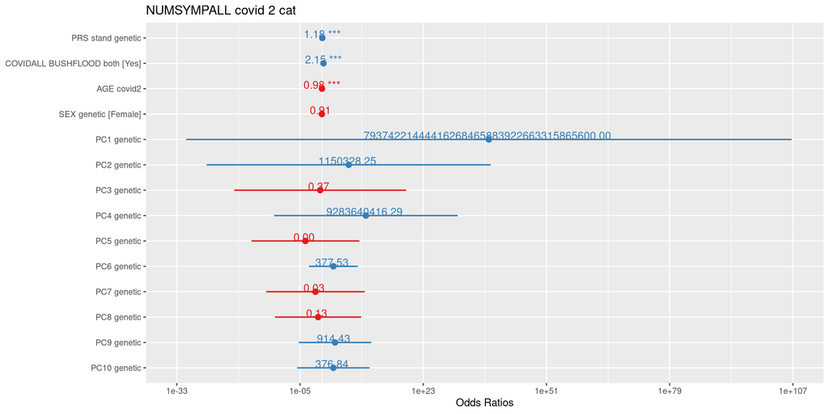

```r
plot_model(Twenty19BushFloodCovidBoth_PO,
           type = 'est',
           show.values = T)
```

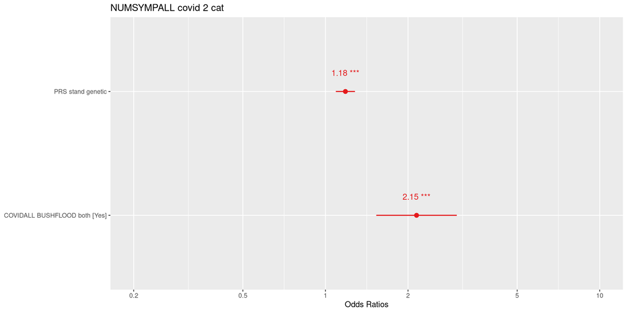

```r
plot_model(Twenty19BushFloodCovidBoth_PO,
           type = 'est',
           show.values = T,
           terms = c('PRS_stand_genetic', 'COVIDALL_BUSHFLOOD_bothYes'))
```

#### Female

##### Results

```r
summary(Twenty19BushFloodCovidBoth_female_PO)
```

```
##
## Call:
## VGAM::vglm(formula = NUMSYMPALL_covid2_cat ~ PRS_stand_genetic +
##     COVIDALL_BUSHFLOOD_both + AGE_covid2 + PC1_genetic + PC2_genetic +
##     PC3_genetic + PC4_genetic + PC5_genetic + PC6_genetic + PC7_genetic +
##     PC8_genetic + PC9_genetic + PC10_genetic, family = VGAM::cumulative(logitlink,
##     parallel = T, reverse = T), data = df_ND_covid[df_ND_covid$SEX_genetic ==
##     "Female", ])
##
## Coefficients:
##                              Estimate Std. Error z value Pr(>|z|)
## (Intercept):1                2.762734   1.230358   2.245   0.0247 *
## (Intercept):2                0.793704   1.227402   0.647   0.5179
## (Intercept):3               -0.832881   1.227402  -0.679   0.4974
## PRS_stand_genetic            0.119025   0.047922   2.484   0.0130 *
## COVIDALL_BUSHFLOOD_bothYes   0.808621   0.194260   4.163 3.15e-05 ***
## AGE_covid2                  -0.026164   0.003264  -8.017 1.09e-15 ***
## PC1_genetic                 76.955486  92.866576   0.829   0.4073
## PC2_genetic                 23.559842  41.523472   0.567   0.5705
## PC3_genetic                 15.693030  27.013318   0.581   0.5613
## PC4_genetic                  5.357430  27.935659   0.192   0.8479
## PC5_genetic                -13.146214  16.957952  -0.775   0.4382
## PC6_genetic                  8.857239   7.332910   1.208   0.2271
## PC7_genetic                 -1.693065  15.052451  -0.112   0.9104
## PC8_genetic                 -2.913563  13.466868  -0.216   0.8287
## PC9_genetic                 -0.105277  11.186063  -0.009   0.9925
## PC10_genetic                 5.126466  11.315990   0.453   0.6505
## ---
## Signif. codes:  0 '***' 0.001 '**' 0.01 '*' 0.05 '.' 0.1 ' ' 1
##
## Names of linear predictors: logitlink(P[Y>=2]), logitlink(P[Y>=3]),
## logitlink(P[Y>=4])
##
## Residual deviance: 3800.876 on 4610 degrees of freedom
##
## Log-likelihood: -1900.438 on 4610 degrees of freedom
##
## Number of Fisher scoring iterations: 4
##
##
## Exponentiated coefficients:
##          PRS_stand_genetic COVIDALL_BUSHFLOOD_bothYes
##               1.126398e+00               2.244810e+00
##                 AGE_covid2                PC1_genetic
##               9.741752e-01               2.638414e+33
##                PC2_genetic                PC3_genetic
##               1.705727e+10               6.537269e+06
##                PC4_genetic                PC5_genetic
##               2.121789e+02               1.952864e-06
##                PC6_genetic                PC7_genetic
##               7.025056e+03               1.839548e-01
##                PC8_genetic                PC9_genetic
##               5.428196e-02               9.000748e-01
##               PC10_genetic
##               1.684209e+02
```

```r
# Create nice summary of results, including back transformation to give OR and calculating 95% CI
CI <- as.data.frame(confint(Twenty19BushFloodCovidBoth_female_PO)) %>%
  rownames_to_column() %>%
  rename('lower_95_CI_of_beta' = "2.5 %",
         'upper_95_CI_of_beta' = "97.5 %") %>%
  mutate(lower_95_CI_of_OR = exp(lower_95_CI_of_beta),
         upper_95_CI_of_OR = exp(upper_95_CI_of_beta))

beta <- as.data.frame(coef(Twenty19BushFloodCovidBoth_female_PO)) %>%
  rownames_to_column() %>%
  rename("beta" = "coef(Twenty19BushFloodCovidBoth_female_PO)") %>%
  mutate(OR = exp(beta))

results <- beta %>%
  full_join(CI) %>%
  relocate(rowname, beta, lower_95_CI_of_beta, upper_95_CI_of_beta, OR, lower_95_CI_of_OR, upper_95_CI_of_OR)

results %>% kable()
```

| rowname | beta | lower_95_CI_of_beta | upper_95_CI_of_beta | OR | lower_95_CI_of_OR | upper_95_CI_of_OR |
| --- | --- | --- | --- | --- | --- | --- |
| (Intercept):1 | 2.7627343 | 0.3512775 | 5.1741910 | 1.584310e+01 | 1.4208816 | 1.766536e+02 |
| (Intercept):2 | 0.7937037 | -1.6119594 | 3.1993668 | 2.211572e+00 | 0.1994963 | 2.451700e+01 |
| (Intercept):3 | -0.8328810 | -3.2385448 | 1.5727829 | 4.347948e-01 | 0.0392209 | 4.820043e+00 |
| PRS_stand_genetic | 0.1190251 | 0.0251002 | 0.2129499 | 1.126398e+00 | 1.0254178 | 1.237323e+00 |
| COVIDALL_BUSHFLOOD_bothYes | 0.8086208 | 0.4278783 | 1.1893632 | 2.244810e+00 | 1.5339994 | 3.284989e+00 |
| AGE_covid2 | -0.0261641 | -0.0325607 | -0.0197675 | 9.741752e-01 | 0.9679637 | 9.804266e-01 |
| PC1_genetic | 76.9554859 | -105.0596577 | 258.9706294 | 2.638414e+33 | 0.0000000 | 2.947918e+112 |
| PC2_genetic | 23.5598425 | -57.8246664 | 104.9443513 | 1.705727e+10 | 0.0000000 | 3.773572e+45 |
| PC3_genetic | 15.6930300 | -37.2520997 | 68.6381597 | 6.537269e+06 | 0.0000000 | 6.444274e+29 |
| PC4_genetic | 5.3574296 | -49.3954553 | 60.1103144 | 2.121789e+02 | 0.0000000 | 1.275199e+26 |
| PC5_genetic | -13.1462138 | -46.3831884 | 20.0907608 | 2.000000e-06 | 0.0000000 | 5.312593e+08 |
| PC6_genetic | 8.8572385 | -5.5150002 | 23.2294772 | 7.025056e+03 | 0.0040259 | 1.225840e+10 |
| PC7_genetic | -1.6930653 | -31.1953263 | 27.8091956 | 1.839548e-01 | 0.0000000 | 1.195034e+12 |
| PC8_genetic | -2.9135633 | -29.3081401 | 23.4810135 | 5.428200e-02 | 0.0000000 | 1.576430e+10 |
| PC9_genetic | -0.1052774 | -22.0295580 | 21.8190031 | 9.000748e-01 | 0.0000000 | 2.991387e+09 |
| PC10_genetic | 5.1264659 | -17.0524679 | 27.3053997 | 1.684209e+02 | 0.0000000 | 7.220785e+11 |

##### Plots

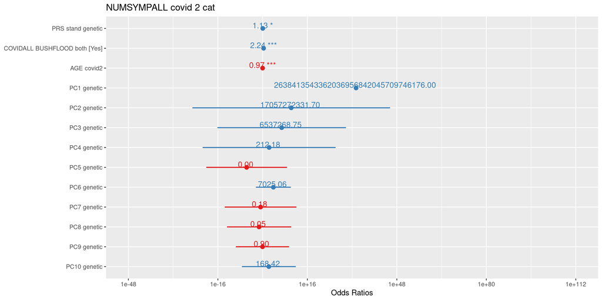

```r
plot_model(Twenty19BushFloodCovidBoth_female_PO,
           type = 'est',
           show.values = T)
```

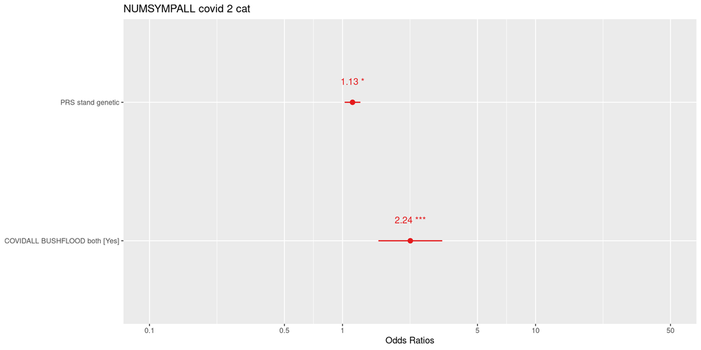

```r
plot_model(Twenty19BushFloodCovidBoth_female_PO,
           type = 'est',
           show.values = T,
           terms = c('PRS_stand_genetic', 'COVIDALL_BUSHFLOOD_bothYes'))
```

#### Male

##### Results

```r
summary(Twenty19BushFloodCovidBoth_male_PO)
```

```
##
## Call:
## VGAM::vglm(formula = NUMSYMPALL_covid2_cat ~ PRS_stand_genetic +
##     COVIDALL_BUSHFLOOD_both + AGE_covid2 + PC1_genetic + PC2_genetic +
##     PC3_genetic + PC4_genetic + PC5_genetic + PC6_genetic + PC7_genetic +
##     PC8_genetic + PC9_genetic + PC10_genetic, family = VGAM::cumulative(logitlink,
##     parallel = T, reverse = T), data = df_ND_covid[df_ND_covid$SEX_genetic ==
##     "Male", ])
##
## Coefficients:
##                              Estimate Std. Error z value Pr(>|z|)
## (Intercept):1               5.686e+00  2.662e+00   2.136  0.03270 *
## (Intercept):2               3.939e+00  2.657e+00   1.482  0.13822
## (Intercept):3               2.261e+00  2.653e+00   0.852  0.39415
## PRS_stand_genetic           3.251e-01  8.079e-02   4.024 5.72e-05 ***
## COVIDALL_BUSHFLOOD_bothYes  6.074e-01  3.788e-01   1.603  0.10889
## AGE_covid2                 -1.697e-02  5.903e-03  -2.875  0.00404 **
## PC1_genetic                 1.327e+02  1.702e+02   0.780  0.43563
## PC2_genetic                -1.051e+02  9.683e+01  -1.085  0.27772
## PC3_genetic                -1.249e+02  5.294e+01  -2.359  0.01832 *
## PC4_genetic                 1.098e+02  5.342e+01   2.056  0.03981 *
## PC5_genetic                -3.315e+00  2.752e+01  -0.120  0.90413
## PC6_genetic                -9.016e+00  1.460e+01  -0.618  0.53680
## PC7_genetic                -6.048e+00  2.741e+01  -0.221  0.82535
## PC8_genetic                -3.499e+00  2.270e+01  -0.154  0.87751
## PC9_genetic                 3.429e+01  1.968e+01   1.742  0.08143 .
## PC10_genetic                6.907e+00  1.890e+01   0.366  0.71474
## ---
## Signif. codes:  0 '***' 0.001 '**' 0.01 '*' 0.05 '.' 0.1 ' ' 1
##
## Names of linear predictors: logitlink(P[Y>=2]), logitlink(P[Y>=3]),
## logitlink(P[Y>=4])
##
## Residual deviance: 1370.142 on 1628 degrees of freedom
##
## Log-likelihood: -685.0712 on 1628 degrees of freedom
##
## Number of Fisher scoring iterations: 4
##
##
## Exponentiated coefficients:
##          PRS_stand_genetic COVIDALL_BUSHFLOOD_bothYes
##               1.384150e+00               1.835564e+00
##                 AGE_covid2                PC1_genetic
##               9.831748e-01               4.216060e+57
##                PC2_genetic                PC3_genetic
##               2.254861e-46               5.739138e-55
##                PC4_genetic                PC5_genetic
##               4.875261e+47               3.634500e-02
##                PC6_genetic                PC7_genetic
##               1.214264e-04               2.363292e-03
##                PC8_genetic                PC9_genetic
##               3.022690e-02               7.808492e+14
##               PC10_genetic
##               9.994357e+02
```

```r
# Create nice summary of results, including back transformation to give OR and calculating 95% CI
CI <- as.data.frame(confint(Twenty19BushFloodCovidBoth_male_PO)) %>%
  rownames_to_column() %>%
  rename('lower_95_CI_of_beta' = "2.5 %",
         'upper_95_CI_of_beta' = "97.5 %") %>%
  mutate(lower_95_CI_of_OR = exp(lower_95_CI_of_beta),
         upper_95_CI_of_OR = exp(upper_95_CI_of_beta))

beta <- as.data.frame(coef(Twenty19BushFloodCovidBoth_male_PO)) %>%
  rownames_to_column() %>%
  rename("beta" = "coef(Twenty19BushFloodCovidBoth_male_PO)") %>%
  mutate(OR = exp(beta))

results <- beta %>%
  full_join(CI) %>%
  relocate(rowname, beta, lower_95_CI_of_beta, upper_95_CI_of_beta, OR, lower_95_CI_of_OR, upper_95_CI_of_OR)

results %>% kable()
```

| rowname | beta | lower_95_CI_of_beta | upper_95_CI_of_beta | OR | lower_95_CI_of_OR | upper_95_CI_of_OR |
| --- | --- | --- | --- | --- | --- | --- |
| (Intercept):1 | 5.6861915 | 0.4681509 | 10.9042321 | 2.947689e+02 | 1.5970384 | 5.440613e+04 |
| (Intercept):2 | 3.9386449 | -1.2686248 | 9.1459147 | 5.134897e+01 | 0.2812181 | 9.376058e+03 |
| (Intercept):3 | 2.2606281 | -2.9391266 | 7.4603828 | 9.589110e+00 | 0.0529119 | 1.737813e+03 |
| PRS_stand_genetic | 0.3250864 | 0.1667457 | 0.4834271 | 1.384150e+00 | 1.1814537 | 1.621622e+00 |
| COVIDALL_BUSHFLOOD_bothYes | 0.6073517 | -0.1351630 | 1.3498663 | 1.835564e+00 | 0.8735735 | 3.856910e+00 |
| AGE_covid2 | -0.0169683 | -0.0285374 | -0.0053992 | 9.831748e-01 | 0.9718660 | 9.946153e-01 |
| PC1_genetic | 132.6862512 | -200.8962038 | 466.2687063 | 4.216060e+57 | 0.0000000 | 3.147214e+202 |
| PC2_genetic | -105.1058259 | -294.8921939 | 84.6805422 | 0.000000e+00 | 0.0000000 | 5.974371e+36 |
| PC3_genetic | -124.8948711 | -228.6571840 | -21.1325581 | 0.000000e+00 | 0.0000000 | 0.000000e+00 |
| PC4_genetic | 109.8056730 | 5.1136497 | 214.4976963 | 4.875261e+47 | 166.2761009 | 1.429440e+93 |
| PC5_genetic | -3.3146987 | -57.2538161 | 50.6244186 | 3.634500e-02 | 0.0000000 | 9.680675e+21 |
| PC6_genetic | -9.0162022 | -37.6261956 | 19.5937912 | 1.214000e-04 | 0.0000000 | 3.232030e+08 |
| PC7_genetic | -6.0476995 | -59.7637015 | 47.6683025 | 2.363300e-03 | 0.0000000 | 5.035942e+20 |
| PC8_genetic | -3.4990231 | -47.9964621 | 40.9984159 | 3.022690e-02 | 0.0000000 | 6.388307e+17 |
| PC9_genetic | 34.2914031 | -4.2803864 | 72.8631927 | 7.808492e+14 | 0.0138373 | 4.406386e+31 |
| PC10_genetic | 6.9071908 | -30.1316500 | 43.9460317 | 9.994357e+02 | 0.0000000 | 1.217640e+19 |

##### Plots

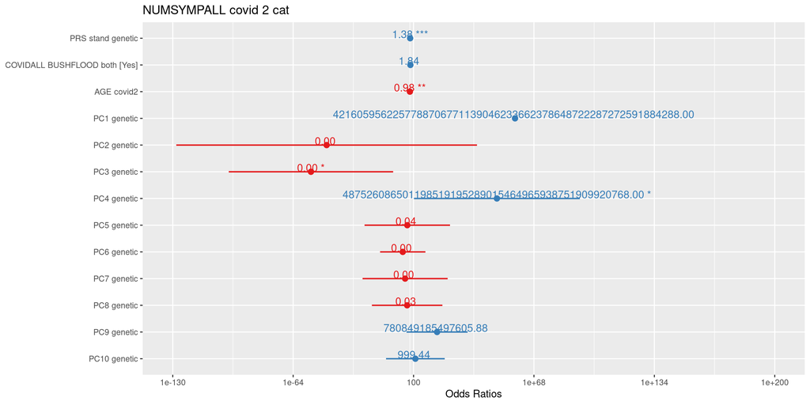

```r
plot_model(Twenty19BushFloodCovidBoth_male_PO,
           type = 'est',
           show.values = T)
```

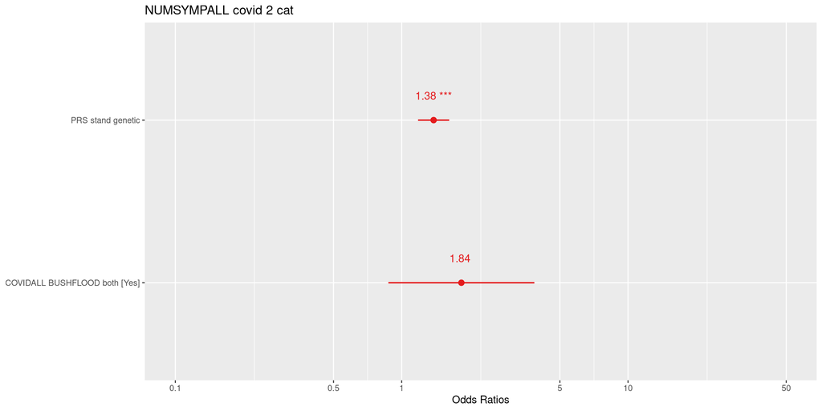

```r
plot_model(Twenty19BushFloodCovidBoth_male_PO,
           type = 'est',
           show.values = T,
           terms = c('PRS_stand_genetic', 'COVIDALL_BUSHFLOOD_bothYes'))
```

#### Female vs Male

- ‘A sex-stratified analysis followed by a Zscore difference test (Eq. 1) is equivalent to a formal test for G×S interaction when there is no interaction between covariates and the strata, and the trait variance are equivalent in the two strata.’ (Blokland et al., 2022)
- Conduct a Z test for the difference between the coefficients of females and males

```r
female_beta <- coef(summary(Twenty19BushFloodCovidBoth_female_PO))["COVIDALL_BUSHFLOOD_bothYes", "Estimate"]
female_SE <- coef(summary(Twenty19BushFloodCovidBoth_female_PO))["COVIDALL_BUSHFLOOD_bothYes", "Std. Error"]
male_beta <- coef(summary(Twenty19BushFloodCovidBoth_male_PO))["COVIDALL_BUSHFLOOD_bothYes", "Estimate"]
male_SE <- coef(summary(Twenty19BushFloodCovidBoth_male_PO))["COVIDALL_BUSHFLOOD_bothYes", "Std. Error"]

Z <- (female_beta - male_beta) / sqrt((female_SE)^2 + (male_SE)^2)
p <- 2 * pnorm(abs(Z), mean = 0, sd = 1, lower.tail = FALSE)

message <- sprintf("Association of horrible 2019 bushfires/floods AND covid experiences on no. symptoms currently in females compared to males, Z = %.6f, p = %.6f", Z, p)
print(message)
```

```
## [1] "Association of horrible 2019 bushfires/floods AND covid experiences on no. symptoms currently in females compared to males, Z = 0.472748, p = 0.636393"
```

# Male vs female effects

- P adjusted with benjamani hochberg method

```r
# Function to process data
process_data <- function(model_female, model_male, predictor) {
  female_beta <- coef(summary(model_female))[predictor, "Estimate"]
  female_SE <- coef(summary(model_female))[predictor, "Std. Error"]
  male_beta <- coef(summary(model_male))[predictor, "Estimate"]
  male_SE <- coef(summary(model_male))[predictor, "Std. Error"]

  Z <- (female_beta - male_beta) / sqrt((female_SE)^2 + (male_SE)^2)
  p <- 2 * pnorm(abs(Z), mean = 0, sd = 1, lower.tail = FALSE)

  return(data.frame(Predictor = predictor, Z = Z, p = p))
}

# process data for each model
ND_worst_female <- process_data(NDworse_female_PO, NDworse_male_PO, "NDEXPOS_DEPRWAFTERYes")

ND_First_female <- process_data(NDFirst_female_PO, NDFirst_male_PO, "NDEXPOS_DEPRFAFTERYes")

Twenty19BushFlood_female <- process_data(Twenty19BushFlood_female_PO, Twenty19BushFlood_male_PO, "BUSHFLOODHORR_followup1")

Covid_female <- process_data(Covid_female_PO, Covid_male_PO, "COVIDALLBIN_C1C21")

Twenty19BushFloodCovidBoth <- process_data(Twenty19BushFloodCovidBoth_female_PO, Twenty19BushFloodCovidBoth_male_PO, "COVIDALL_BUSHFLOOD_bothYes")


femalevsmale <- ND_worst_female %>%
  full_join(ND_First_female) %>%
  full_join(Twenty19BushFlood_female) %>%
  full_join(Covid_female) %>%
  full_join(Twenty19BushFloodCovidBoth) %>%
  mutate(P_adjusted = p.adjust(p, method = "BH", n = 5))

femalevsmale %>%
  kable()
```

| Predictor | Z | p | P_adjusted |
| --- | --- | --- | --- |
| NDEXPOS_DEPRWAFTERYes | -0.9968182 | 0.3188528 | 0.7497399 |
| NDEXPOS_DEPRFAFTERYes | -1.6440808 | 0.1001595 | 0.5007976 |
| BUSHFLOODHORR_followup1 | -0.0200867 | 0.9839742 | 0.9839742 |
| COVIDALLBIN_C1C21 | -0.7556752 | 0.4498439 | 0.7497399 |
| COVIDALL_BUSHFLOOD_bothYes | 0.4727475 | 0.6363933 | 0.7954916 |

# Power analyses

- Determine the minimum detectable odds ratio for each of the analyses

```r
# Function to calculate smallest detectable OR for a given outcome
calc_smallest_or <- function(data, outcome, predictor, age, title) {

  df_subset <- data %>%
    drop_na({{outcome}}, SEX_genetic, {{age}}, matches("^PC.*_genetic$"), {{predictor}})

  alpha <- 0.05

  # Get outcome probabilities
  p <- df_subset %>%
    count({{outcome}}) %>%
    mutate(prop = n / sum(n)) %>%
    pull(prop)

  # Determine n1 and n2 from the predictor categories
  predictor_counts <- df_subset %>%
    group_by({{predictor}}) %>%
    summarise(n = n(), .groups = "drop")
  n1 <- as.numeric(predictor_counts$n[1])
  n2 <- as.numeric(predictor_counts$n[2])

  # Power function
  power_for_or <- function(or) {
    pop <- popower(p = p,
                   odds.ratio = or,
                   n1 = n1,
                   n2 = n2,
                   alpha = alpha)
    pop$power
  }

  results <- tibble(
    or = seq(1, 4, by = 0.0001)
  ) %>%
    mutate(power = map_dbl(or, power_for_or)) %>%
    filter(power > 0.8) %>%
    slice_min(or)    # take the smallest OR with power > 0.8

  results %>%
    kable(caption = title)

}


calc_smallest_or(df_ND_covid, NUMSYMPALL_baseline_cat, NDEXPOS_DEPRWAFTER, AGE_baseline, "Natural disaster experience, worst depressive episode")
```

Natural disaster experience, worst depressive episode

| or | power |
| --- | --- |
| 1.2504 | 0.8001986 |

```r
calc_smallest_or(df_ND_covid %>% filter(SEX_genetic == "Female"), NUMSYMPALL_baseline_cat, NDEXPOS_DEPRWAFTER, AGE_baseline, "Natural disaster experience, worst depressive episode (females only)")
```

Natural disaster experience, worst depressive episode (females only)

| or | power |
| --- | --- |
| 1.3209 | 0.8001241 |

```r
calc_smallest_or(df_ND_covid %>% filter(SEX_genetic == "Male"), NUMSYMPALL_baseline_cat, NDEXPOS_DEPRWAFTER, AGE_baseline, "Natural disaster experience, worst depressive episode (males only)")
```

Natural disaster experience, worst depressive episode (males only)

| or | power |
| --- | --- |
| 1.4573 | 0.800078 |

```r
calc_smallest_or(df_ND_covid, NUMSYMPALL_followup_cat, NDEXPOS_DEPRFAFTER, AGE_baseline, "Natural disaster experience, first depressive episode")
```

Natural disaster experience, first depressive episode

| or | power |
| --- | --- |
| 1.2302 | 0.8002233 |

```r
calc_smallest_or(df_ND_covid %>% filter(SEX_genetic == "Female"), NUMSYMPALL_followup_cat, NDEXPOS_DEPRFAFTER, AGE_baseline, "Natural disaster experience, first depressive episode (females only)")
```

Natural disaster experience, first depressive episode (females only)

| or | power |
| --- | --- |
| 1.276 | 0.8002333 |

```r
calc_smallest_or(df_ND_covid %>% filter(SEX_genetic == "Male"), NUMSYMPALL_followup_cat, NDEXPOS_DEPRFAFTER, AGE_baseline, "Natural disaster experience, first depressive episode (males only)")
```

Natural disaster experience, first depressive episode (males only)

| or | power |
| --- | --- |
| 1.4837 | 0.8000353 |

```r
calc_smallest_or(df_ND_covid, NUMSYMPALL_covid1_cat, BUSHFLOODHORR_followup, AGE_followup, "Horrible 2019 bushfires/floods experience, current symptoms (1 year later)")
```

Horrible 2019 bushfires/floods experience, current symptoms (1 year later)

| or | power |
| --- | --- |
| 1.4524 | 0.8000191 |

```r
calc_smallest_or(df_ND_covid %>% filter(SEX_genetic == "Female"), NUMSYMPALL_covid1_cat, BUSHFLOODHORR_followup, AGE_followup, "Horrible 2019 bushfires/floods experience, current symptoms (1 year later) (females only)")
```

Horrible 2019 bushfires/floods experience, current symptoms (1 year later) (females only)

| or | power |
| --- | --- |
| 1.5279 | 0.8000719 |

```r
calc_smallest_or(df_ND_covid %>% filter(SEX_genetic == "Male"), NUMSYMPALL_covid1_cat, BUSHFLOODHORR_followup, AGE_followup, "Horrible 2019 bushfires/floods experience, current symptoms (1 year later) (males only)")
```

Horrible 2019 bushfires/floods experience, current symptoms (1 year later) (males only)

| or | power |
| --- | --- |
| 2.2095 | 0.8000031 |

```r
calc_smallest_or(df_ND_covid, NUMSYMPALL_covid2_cat, COVIDALLBIN_C1C2, AGE_covid2, "Horrible covid experience, current symptoms")
```

Horrible covid experience, current symptoms

| or | power |
| --- | --- |
| 1.2069 | 0.8000166 |

```r
calc_smallest_or(df_ND_covid %>% filter(SEX_genetic == "Female"), NUMSYMPALL_covid2_cat, COVIDALLBIN_C1C2, AGE_covid2, "Horrible covid experience, current symptoms (females only)")
```

Horrible covid experience, current symptoms (females only)

| or | power |
| --- | --- |
| 1.2362 | 0.8001954 |

```r
calc_smallest_or(df_ND_covid %>% filter(SEX_genetic == "Male"), NUMSYMPALL_covid2_cat, COVIDALLBIN_C1C2, AGE_covid2, "Horrible covid experience, current symptoms (males only)")
```

Horrible covid experience, current symptoms (males only)

| or | power |
| --- | --- |
| 1.515 | 0.800058 |

```r
calc_smallest_or(df_ND_covid, NUMSYMPALL_covid2_cat, COVIDALL_BUSHFLOOD_both, AGE_covid2, "Horrible 2019 bushfires/floods and covid experience, current symptoms")
```

Horrible 2019 bushfires/floods and covid experience, current symptoms

| or | power |
| --- | --- |
| 1.593 | 0.800015 |

```r
calc_smallest_or(df_ND_covid %>% filter(SEX_genetic == "Female"), NUMSYMPALL_covid2_cat, COVIDALL_BUSHFLOOD_both, AGE_covid2, "Horrible 2019 bushfires/floods and covid experience, current symptoms (females only)")
```

Horrible 2019 bushfires/floods and covid experience, current symptoms (females only)

| or | power |
| --- | --- |
| 1.6875 | 0.8000432 |

```r
calc_smallest_or(df_ND_covid %>% filter(SEX_genetic == "Male"), NUMSYMPALL_covid2_cat, COVIDALL_BUSHFLOOD_both, AGE_covid2, "Horrible 2019 bushfires/floods and covid experience, current symptoms (males only)")
```

Horrible 2019 bushfires/floods and covid experience, current symptoms (males only)

| or | power |
| --- | --- |
| 2.7905 | 0.8000028 |

# Demographics

- Demographic characteristics of all participants in each of the regression analyses

## Total

```r
# Function to process data - print demographics for each analytical dataset

summarise_data <- function(outcome, age, predictor, title) {

  n_age <- df_ND_covid %>%
    drop_na({{outcome}}, SEX_genetic, {{age}}, matches("^PC.*_genetic$"), {{predictor}}) %>%
    summarise(N_count = n(),
              Mean_age = mean({{age}}),
              SD_age = sd({{age}}),
              Min_age = min({{age}}),
              Max_age = max({{age}})) %>%
    mutate(
      N_percent = N_count / sum(N_count) * 100
    ) %>%
    relocate(N_percent, .after = N_count)

  n_outcome <- df_ND_covid %>%
    drop_na({{outcome}}, SEX_genetic, {{age}}, matches("^PC.*_genetic$"), {{predictor}}) %>%
    group_by({{outcome}}) %>%
    summarise(count = n(), .groups = "drop") %>%
    pivot_wider(
      names_from = {{outcome}},
      values_from = count,
      values_fill = 0
    ) %>%
    rowwise() %>%
    mutate(
      total = sum(c_across(where(is.numeric))),  # sum of all category counts
      across(
        .cols = -c(total),
        .fns = ~ .x / total * 100,
        .names = "{.col}_percent"
      )
    ) %>%
    select(-total) %>%
    ungroup() %>%
    rename_with(
      ~ paste0(.x, "_count"),
      .cols = where(is.numeric) & !ends_with("_percent")
    )

  n_predictor <- df_ND_covid %>%
    drop_na({{outcome}}, SEX_genetic, {{age}}, matches("^PC.*_genetic$"), {{predictor}}) %>%
    group_by({{predictor}}) %>%
    summarise(count = n(), .groups = "drop") %>%
    pivot_wider(
      names_from = {{predictor}},
      values_from = count,
      values_fill = 0
    ) %>%
    rowwise() %>%
    mutate(
      total = sum(c_across(where(is.numeric))),  # sum of all category counts
      across(
        .cols = -c(total),
        .fns = ~ .x / total * 100,
        .names = "{.col}_percent"
      )
    ) %>%
    select(-total) %>%
    ungroup() %>%
    rename_with(
      ~ paste0(.x, "_count"),
      .cols = where(is.numeric) & !ends_with("_percent")
    )


  n_age %>%
    bind_cols(n_outcome) %>%
    bind_cols(n_predictor) %>%
    kable(caption = title)
}


summarise_data(NUMSYMPALL_baseline_cat, AGE_baseline, NDEXPOS_DEPRWAFTER, "Natural disaster experience, worst depressive episode")
```

Natural disaster experience, worst depressive episode

| N_count | N_percent | Mean_age | SD_age | Min_age | Max_age | low_count | medium_count | high_count | low_percent | medium_percent | high_percent | No_count | Yes_count | No_percent | Yes_percent |
| --- | --- | --- | --- | --- | --- | --- | --- | --- | --- | --- | --- | --- | --- | --- | --- |
| 8681 | 100 | 43.22958 | 15.08976 | 18 | 89 | 36 | 722 | 7923 | 0.4146988 | 8.317014 | 91.26829 | 5649 | 3032 | 65.07315 | 34.92685 |

```r
summarise_data(NUMSYMPALL_followup_cat, AGE_baseline, NDEXPOS_DEPRFAFTER, "Natural disaster experience, first depressive episode")
```

Natural disaster experience, first depressive episode

| N_count | N_percent | Mean_age | SD_age | Min_age | Max_age | low_count | medium_count | high_count | low_percent | medium_percent | high_percent | No_count | Yes_count | No_percent | Yes_percent |
| --- | --- | --- | --- | --- | --- | --- | --- | --- | --- | --- | --- | --- | --- | --- | --- |
| 4297 | 100 | 44.70305 | 14.99282 | 18 | 83 | 208 | 1119 | 2970 | 4.840586 | 26.04142 | 69.11799 | 3147 | 1150 | 73.23714 | 26.76286 |

```r
summarise_data(NUMSYMPALL_covid1_cat, AGE_followup, BUSHFLOODHORR_followup, "Horrible 2019 bushfires/floods experience, current symptoms (1 year later)")
```

Horrible 2019 bushfires/floods experience, current symptoms (1 year later)

| N_count | N_percent | Mean_age | SD_age | Min_age | Max_age | zero_count | low_count | medium_count | high_count | zero_percent | low_percent | medium_percent | high_percent | 0_count | 1_count | 0_percent | 1_percent |
| --- | --- | --- | --- | --- | --- | --- | --- | --- | --- | --- | --- | --- | --- | --- | --- | --- | --- |
| 2140 | 100 | 50.58598 | 14.97102 | 20 | 92 | 145 | 464 | 804 | 727 | 6.775701 | 21.68224 | 37.57009 | 33.97196 | 1931 | 209 | 90.23364 | 9.766355 |

```r
summarise_data(NUMSYMPALL_covid2_cat, AGE_covid2, COVIDALLBIN_C1C2, "Horrible covid experience, current symptoms")
```

Horrible covid experience, current symptoms

| N_count | N_percent | Mean_age | SD_age | Min_age | Max_age | zero_count | low_count | medium_count | high_count | zero_percent | low_percent | medium_percent | high_percent | 0_count | 1_count | 0_percent | 1_percent |
| --- | --- | --- | --- | --- | --- | --- | --- | --- | --- | --- | --- | --- | --- | --- | --- | --- | --- |
| 3483 | 100 | 52.22567 | 14.745 | 22 | 94 | 196 | 794 | 1290 | 1203 | 5.627333 | 22.79644 | 37.03704 | 34.53919 | 2407 | 1076 | 69.10709 | 30.89291 |

```r
summarise_data(NUMSYMPALL_covid2_cat, AGE_covid2, COVIDALL_BUSHFLOOD_both, "Horrible 2019 bushfires/floods and covid experience, current symptoms")
```

Horrible 2019 bushfires/floods and covid experience, current symptoms

| N_count | N_percent | Mean_age | SD_age | Min_age | Max_age | zero_count | low_count | medium_count | high_count | zero_percent | low_percent | medium_percent | high_percent | No_count | Yes_count | No_percent | Yes_percent |
| --- | --- | --- | --- | --- | --- | --- | --- | --- | --- | --- | --- | --- | --- | --- | --- | --- | --- |
| 2090 | 100 | 53.39522 | 14.72498 | 22 | 88 | 152 | 543 | 778 | 617 | 7.272727 | 25.98086 | 37.22488 | 29.52153 | 1962 | 128 | 93.8756 | 6.124402 |

## Grouped by Sex

```r
# Function to process data - print demographics for each analytical dataset split by sex

summarise_data <- function(outcome, age, predictor, title) {

  n_age <- df_ND_covid %>%
    drop_na({{outcome}}, SEX_genetic, {{age}}, matches("^PC.*_genetic$"), {{predictor}}) %>%
    group_by(SEX_genetic) %>%
    summarise(N_count = n(),
              Mean_age = mean({{age}}),
              SD_age = sd({{age}}),
              Min_age = min({{age}}),
              Max_age = max({{age}})) %>%
    mutate(
      N_percent = N_count / sum(N_count) * 100
    ) %>%
    relocate(N_percent, .after = N_count)

  n_outcome <- df_ND_covid %>%
    drop_na({{outcome}}, SEX_genetic, {{age}}, matches("^PC.*_genetic$"), {{predictor}}) %>%
    group_by(SEX_genetic, {{outcome}}) %>%
    summarise(count = n(), .groups = "drop") %>%
    pivot_wider(
      names_from = {{outcome}},
      values_from = count,
      values_fill = 0
    ) %>%
    rowwise() %>%
    mutate(
      total = sum(c_across(where(is.numeric))),  # sum of all category counts
      across(
        .cols = -c(SEX_genetic, total),
        .fns = ~ .x / total * 100,
        .names = "{.col}_percent"
      )
    ) %>%
    select(-total) %>%
    ungroup() %>%
    rename_with(
      ~ paste0(.x, "_count"),
      .cols = where(is.numeric) & !ends_with("_percent")
    )

  n_predictor <- df_ND_covid %>%
    drop_na({{outcome}}, SEX_genetic, {{age}}, matches("^PC.*_genetic$"), {{predictor}}) %>%
    group_by(SEX_genetic, {{predictor}}) %>%
    summarise(count = n(), .groups = "drop") %>%
    pivot_wider(
      names_from = {{predictor}},
      values_from = count,
      values_fill = 0
    ) %>%
    rowwise() %>%
    mutate(
      total = sum(c_across(where(is.numeric))),  # sum of all category counts
      across(
        .cols = -c(SEX_genetic, total),
        .fns = ~ .x / total * 100,
        .names = "{.col}_percent"
      )
    ) %>%
    select(-total) %>%
    ungroup() %>%
    rename_with(
      ~ paste0(.x, "_count"),
      .cols = where(is.numeric) & !ends_with("_percent")
    )


  n_age %>%
    left_join(n_outcome, by = "SEX_genetic") %>%
    left_join(n_predictor, by = "SEX_genetic") %>%
    kable(caption = title)
}

summarise_data(NUMSYMPALL_baseline_cat, AGE_baseline, NDEXPOS_DEPRWAFTER, "Natural disaster experience, worst depressive episode")
```

Natural disaster experience, worst depressive episode

| SEX_genetic | N_count | N_percent | Mean_age | SD_age | Min_age | Max_age | low_count | medium_count | high_count | low_percent | medium_percent | high_percent | No_count | Yes_count | No_percent | Yes_percent |
| --- | --- | --- | --- | --- | --- | --- | --- | --- | --- | --- | --- | --- | --- | --- | --- | --- |
| Male | 2138 | 24.6285 | 48.48877 | 14.93847 | 18 | 84 | 22 | 249 | 1867 | 1.0289991 | 11.6464 | 87.32460 | 1341 | 797 | 62.72217 | 37.27783 |
| Female | 6543 | 75.3715 | 41.51108 | 14.73861 | 18 | 89 | 14 | 473 | 6056 | 0.2139691 | 7.2291 | 92.55693 | 4308 | 2235 | 65.84136 | 34.15864 |

```r
summarise_data(NUMSYMPALL_followup_cat, AGE_baseline, NDEXPOS_DEPRFAFTER, "Natural disaster experience, first depressive episode")
```

Natural disaster experience, first depressive episode

| SEX_genetic | N_count | N_percent | Mean_age | SD_age | Min_age | Max_age | low_count | medium_count | high_count | low_percent | medium_percent | high_percent | No_count | Yes_count | No_percent | Yes_percent |
| --- | --- | --- | --- | --- | --- | --- | --- | --- | --- | --- | --- | --- | --- | --- | --- | --- |
| Male | 1053 | 24.50547 | 50.29155 | 14.59203 | 18 | 82 | 61 | 295 | 697 | 5.792973 | 28.01519 | 66.19183 | 739 | 314 | 70.18044 | 29.81956 |
| Female | 3244 | 75.49453 | 42.88903 | 14.67201 | 18 | 83 | 147 | 824 | 2273 | 4.531443 | 25.40074 | 70.06782 | 2408 | 836 | 74.22935 | 25.77065 |

```r
summarise_data(NUMSYMPALL_covid1_cat, AGE_followup, BUSHFLOODHORR_followup, "Horrible 2019 bushfires/floods experience, current symptoms (1 year later)")
```

Horrible 2019 bushfires/floods experience, current symptoms (1 year later)

| SEX_genetic | N_count | N_percent | Mean_age | SD_age | Min_age | Max_age | zero_count | low_count | medium_count | high_count | zero_percent | low_percent | medium_percent | high_percent | 0_count | 1_count | 0_percent | 1_percent |
| --- | --- | --- | --- | --- | --- | --- | --- | --- | --- | --- | --- | --- | --- | --- | --- | --- | --- | --- |
| Male | 546 | 25.51402 | 55.83333 | 13.99042 | 23 | 92 | 61 | 117 | 199 | 169 | 11.172161 | 21.42857 | 36.44689 | 30.95238 | 501 | 45 | 91.75824 | 8.241758 |
| Female | 1594 | 74.48598 | 48.78858 | 14.87676 | 20 | 86 | 84 | 347 | 605 | 558 | 5.269762 | 21.76913 | 37.95483 | 35.00627 | 1430 | 164 | 89.71142 | 10.288582 |

```r
summarise_data(NUMSYMPALL_covid2_cat, AGE_covid2, COVIDALLBIN_C1C2, "Horrible covid experience, current symptoms")
```

Horrible covid experience, current symptoms

| SEX_genetic | N_count | N_percent | Mean_age | SD_age | Min_age | Max_age | zero_count | low_count | medium_count | high_count | zero_percent | low_percent | medium_percent | high_percent | 0_count | 1_count | 0_percent | 1_percent |
| --- | --- | --- | --- | --- | --- | --- | --- | --- | --- | --- | --- | --- | --- | --- | --- | --- | --- | --- |
| Male | 840 | 24.11714 | 57.43214 | 13.92822 | 24 | 94 | 57 | 184 | 316 | 283 | 6.785714 | 21.90476 | 37.61905 | 33.69048 | 640 | 200 | 76.19048 | 23.80952 |
| Female | 2643 | 75.88286 | 50.57094 | 14.61426 | 22 | 90 | 139 | 610 | 974 | 920 | 5.259175 | 23.07983 | 36.85206 | 34.80893 | 1767 | 876 | 66.85585 | 33.14415 |

```r
summarise_data(NUMSYMPALL_covid2_cat, AGE_covid2, COVIDALL_BUSHFLOOD_both, "Horrible 2019 bushfires/floods and covid experience, current symptoms")
```

Horrible 2019 bushfires/floods and covid experience, current symptoms

| SEX_genetic | N_count | N_percent | Mean_age | SD_age | Min_age | Max_age | zero_count | low_count | medium_count | high_count | zero_percent | low_percent | medium_percent | high_percent | No_count | Yes_count | No_percent | Yes_percent |
| --- | --- | --- | --- | --- | --- | --- | --- | --- | --- | --- | --- | --- | --- | --- | --- | --- | --- | --- |
| Male | 548 | 26.2201 | 58.32117 | 13.59639 | 24 | 88 | 47 | 138 | 208 | 155 | 8.576642 | 25.18248 | 37.95620 | 28.28467 | 522 | 26 | 95.25547 | 4.744525 |
| Female | 1542 | 73.7799 | 51.64462 | 14.71788 | 22 | 88 | 105 | 405 | 570 | 462 | 6.809338 | 26.26459 | 36.96498 | 29.96109 | 1440 | 102 | 93.38521 | 6.614786 |

# Venn diagram: 2019 bushfires/floods and COVID

```r
# Venn diagram for both sexes

# Data: sizes of each group
# Bushfire/flood exclusive
one <- df_ND_covid %>%
  drop_na(NUMSYMPALL_covid2, SEX_genetic, AGE_covid2, matches("^PC.*_genetic$"), COVIDALL_BUSHFLOOD, PRS_stand_genetic) %>%
  filter(COVIDALL_BUSHFLOOD == "Bushfire/flood only") %>%
  nrow()
# COVID exclusive
two <- df_ND_covid %>%
  drop_na(NUMSYMPALL_covid2, SEX_genetic, AGE_covid2, matches("^PC.*_genetic$"), COVIDALL_BUSHFLOOD, PRS_stand_genetic) %>%
  filter(COVIDALL_BUSHFLOOD == "COVID only") %>%
  nrow()
# Both bushfire/flood and COVID
overlap <- df_ND_covid %>%
  drop_na(NUMSYMPALL_covid2, SEX_genetic, AGE_covid2, matches("^PC.*_genetic$"), COVIDALL_BUSHFLOOD, PRS_stand_genetic) %>%
  filter(COVIDALL_BUSHFLOOD == "Bushfire/flood and COVID") %>%
  nrow()
# None experiences
none <- df_ND_covid %>%
  drop_na(NUMSYMPALL_covid2, SEX_genetic, AGE_covid2, matches("^PC.*_genetic$"), COVIDALL_BUSHFLOOD, PRS_stand_genetic) %>%
  filter(COVIDALL_BUSHFLOOD == "No") %>%
  nrow()

# Calculate circle areas
area_one <- one + overlap
area_two <- two + overlap

# Convert areas to radii (since area = π * r^2, radius = sqrt(area / π))
r_1 <- sqrt(area_one / pi)
r_2 <- sqrt(area_two / pi)

# Calculate the proportional overlap distance
overlap_ratio <- overlap / min(area_one, area_two)
d <- (r_1 + r_2) * (1 - overlap_ratio / 2)  # Adjust overlap distance

# Create circle data with calculated positions
circle_data <- data.frame(
  x = c(0, d),  # x-coordinates for each circle
  y = c(0, 0),  # Keep y-coordinates the same for both circles
  radius = c(r_1, r_2),
  group = c("bushflood", "covid")
)

# Plot the Euler diagram with numbers positioned correctly
venn_bushflood_covid <- ggplot(circle_data) +
  geom_circle(aes(x0 = x, y0 = y, r = radius, fill = group), alpha = 0.6, color = "black") +
  scale_fill_manual(values = c("#20a386", "#287d8e")) +
  coord_fixed() +
  # Add labels inside each circle and in the overlapping section
  # bushfires/floods only
  annotate("text",
           x = circle_data$x[1] - r_1 / 2,
           y = circle_data$y[1],
           label = one,
           size = 7 / 2.845276, color = "black", family = "Arial", fontface = "bold") +
  annotate("text",
           x = circle_data$x[1] - r_1 / 2,
           y = circle_data$y[1] - 2,
           label = paste0(
             round(one/(one + two + overlap + none)*100,2),
             "%"),
           size = 7 / 2.845276, color = "black", family = "Arial", fontface = "bold") +
  # COVID only
  annotate("text",
           x = circle_data$x[2] + r_2 / 2,
           y = circle_data$y[2],
           label = two,
           size = 7 / 2.845276, color = "black", family = "Arial", fontface = "bold") +
  annotate("text",
           x = circle_data$x[2] + r_2 / 2,
           y = circle_data$y[2] - 2,
           label = paste0(
             round(two/(one + two + overlap + none)*100,2),
             "%"),
           size = 7 / 2.845276, color = "black", family = "Arial", fontface = "bold") +
  # Both bushfires/floods and covid
  annotate("text",
           x = mean(circle_data$x) - 3.5,
           y = circle_data$y[1],
           label = overlap,
           size = 7 / 2.845276, color = "black", family = "Arial", fontface = "bold") +
  annotate("text",
           x = mean(circle_data$x) - 3.5,
           y = circle_data$y[1] - 2,
           label = paste0(
             round(overlap/(one + two + overlap + none)*100,2),
             "%"),
           size = 7 / 2.845276, color = "black", family = "Arial", fontface = "bold") +
  # Oustide of circles for no. experiencing none
  annotate("text",
           x = mean(circle_data$x) - 3.5,
           y = -max(r_1, r_2) - 2,
           label = paste0("No = ", none),
           size = 7 / 2.845276, color = "black", family = "Arial", fontface = "bold") +
  annotate("text",
           x = mean(circle_data$x) - 3.5,
           y = -max(r_1, r_2) - 4,
           label = paste0(
             round(none/(one + two + overlap + none)*100,2),
             "%"),
           size = 7 / 2.845276, color = "black", family = "Arial", fontface = "bold") +
  # Add labels above the circles
  annotate("text",
           x = circle_data$x[1],
           y = circle_data$y[1] + r_1 + 5,
           label = "Bushfires/floods",
           size = 7 / 2.845276, color = "black", family = "Arial", fontface = "bold") +
  annotate("text",
           x = circle_data$x[2],
           y = circle_data$y[2] + r_2 + 5,
           label = "COVID-19",
           size = 7 / 2.845276, color = "black", family = "Arial", fontface = "bold") +
  ggtitle("Both sexes") +
  theme_classic() +
  theme(text = element_text(family = "Arial"),
        axis.text = element_blank(),
        axis.ticks = element_blank(),
        axis.line = element_blank(),
        axis.title = element_blank(),
        legend.position = "none",
        plot.title = element_text(face = "bold", hjust = 0.5, size = 10))

# venn_bushflood_covid



# Venn diagram for females

# Data: sizes of each group
# Bushfire/flood exclusive
one <- df_ND_covid %>%
  drop_na(NUMSYMPALL_covid2, SEX_genetic, AGE_covid2, matches("^PC.*_genetic$"), COVIDALL_BUSHFLOOD, PRS_stand_genetic) %>%
  filter(SEX_genetic == "Female") %>%
  filter(COVIDALL_BUSHFLOOD == "Bushfire/flood only") %>%
  nrow()
# COVID exclusive
two <- df_ND_covid %>%
  drop_na(NUMSYMPALL_covid2, SEX_genetic, AGE_covid2, matches("^PC.*_genetic$"), COVIDALL_BUSHFLOOD, PRS_stand_genetic) %>%
  filter(SEX_genetic == "Female") %>%
  filter(COVIDALL_BUSHFLOOD == "COVID only") %>%
  nrow()
# Both bushfire/flood and COVID
overlap <- df_ND_covid %>%
  drop_na(NUMSYMPALL_covid2, SEX_genetic, AGE_covid2, matches("^PC.*_genetic$"), COVIDALL_BUSHFLOOD, PRS_stand_genetic) %>%
  filter(SEX_genetic == "Female") %>%
  filter(COVIDALL_BUSHFLOOD == "Bushfire/flood and COVID") %>%
  nrow()
# None experiences
none <- df_ND_covid %>%
  drop_na(NUMSYMPALL_covid2, SEX_genetic, AGE_covid2, matches("^PC.*_genetic$"), COVIDALL_BUSHFLOOD, PRS_stand_genetic) %>%
  filter(SEX_genetic == "Female") %>%
  filter(COVIDALL_BUSHFLOOD == "No") %>%
  nrow()
```

```r
# Calculate circle areas
area_one <- one + overlap
area_two <- two + overlap

# Convert areas to radii (since area = π * r^2, radius = sqrt(area / π))
r_1 <- sqrt(area_one / pi)
r_2 <- sqrt(area_two / pi)

# Calculate the proportional overlap distance
overlap_ratio <- overlap / min(area_one, area_two)
d <- (r_1 + r_2) * (1 - overlap_ratio / 2)  # Adjust overlap distance

# Create circle data with calculated positions
circle_data <- data.frame(
  x = c(0, d),  # x-coordinates for each circle
  y = c(0, 0),  # Keep y-coordinates the same for both circles
  radius = c(r_1, r_2),
  group = c("bushflood", "covid")
)

# Plot the Euler diagram with numbers positioned correctly
venn_bushflood_covid_female <- ggplot(circle_data) +
  geom_circle(aes(x0 = x, y0 = y, r = radius, fill = group), alpha = 0.6, color = "black") +
  scale_fill_manual(values = c("#eae51a", "#B8DE29FF")) +
  coord_fixed() +
  # Add labels inside each circle and in the overlapping section
  # Bushfires/floods only
  annotate("text",
           x = circle_data$x[1] - r_1 / 2 + 1,
           y = circle_data$y[1],
           label = one,
           size = 7 / 2.845276, color = "black", family = "Arial", fontface = "bold") +
  annotate("text",
           x = circle_data$x[1] - r_1 / 2 + 1,
           y = circle_data$y[1] - 3,
           label = paste0(
             round(one/(one + two + overlap + none)*100,2),
             "%"),
           size = 7 / 2.845276, color = "black", family = "Arial", fontface = "bold") +
  # COVID only
  annotate("text",
           x = circle_data$x[2] + r_2 / 2,
           y = circle_data$y[2],
           label = two,
           size = 7 / 2.845276, color = "black", family = "Arial", fontface = "bold") +
  annotate("text",
           x = circle_data$x[2] + r_2 / 2,
           y = circle_data$y[2] - 3,
           label = paste0(
             round(two/(one + two + overlap + none)*100,2),
             "%"),
           size = 7 / 2.845276, color = "black", family = "Arial", fontface = "bold") +
  # Bushfires/floods and COVID
  annotate("text",
           x = mean(circle_data$x) - 3.2,
           y = circle_data$y[1],
           label = overlap,
           size = 7 / 2.845276, color = "black", family = "Arial", fontface = "bold") +
  annotate("text",
           x = mean(circle_data$x) - 5.2,
           y = circle_data$y[1] - 11,
           label = paste0(
             round(overlap/(one + two + overlap + none)*100,2),
             "%"),
           size = 7 / 2.845276, color = "black", family = "Arial", fontface = "bold") +
  annotate("segment",
           x = mean(circle_data$x) - 3.2,
           xend = mean(circle_data$x) - 5.2,
           y = circle_data$y[1] - 2,
           yend = circle_data$y[1] - 10,
           linewidth = 0.4,
           colour = "black") +
  # Add label oustide of circles for no. experiencing none
  annotate("text",
           x = mean(circle_data$x) - 3.2,
           y = -max(r_1, r_2) - 2,
           label = paste0("No = ", none),
           size = 7 / 2.845276, color = "black", family = "Arial", fontface = "bold") +
  annotate("text",
           x = mean(circle_data$x) - 3.2,
           y = -max(r_1, r_2) - 5,
           label = paste0(
             round(none/(one + two + overlap + none)*100,2),
             "%"),
           size = 7 / 2.845276, color = "black", family = "Arial", fontface = "bold") +
  # Add labels above the circles
  annotate("text",
           x = circle_data$x[1],
           y = circle_data$y[1] + r_1 + 5,
           label = "Bushfires/floods",
           size = 7 / 2.845276, color = "black", family = "Arial", fontface = "bold") +
  annotate("text",
           x = circle_data$x[2],
           y = circle_data$y[2] + r_2 + 5,
           label = "COVID-19",
           size = 7 / 2.845276, color = "black", family = "Arial", fontface = "bold") +
  ggtitle("Female") +
  theme_classic() +
  theme(text = element_text(family = "Arial"),
        axis.text = element_blank(),
        axis.ticks = element_blank(),
        axis.line = element_blank(),
        axis.title = element_blank(),
        legend.position = "none",
        plot.title = element_text(face = "bold", hjust = 0.5, size = 10))

# venn_bushflood_covid_female




# Venn diagram for males

# Data: sizes of each group
# Bushfire/flood exclusive
one <- df_ND_covid %>%
  drop_na(NUMSYMPALL_covid2, SEX_genetic, AGE_covid2, matches("^PC.*_genetic$"), COVIDALL_BUSHFLOOD, PRS_stand_genetic) %>%
  filter(SEX_genetic == "Male") %>%
  filter(COVIDALL_BUSHFLOOD == "Bushfire/flood only") %>%
  nrow()
# COVID exclusive
two <- df_ND_covid %>%
  drop_na(NUMSYMPALL_covid2, SEX_genetic, AGE_covid2, matches("^PC.*_genetic$"), COVIDALL_BUSHFLOOD, PRS_stand_genetic) %>%
  filter(SEX_genetic == "Male") %>%
  filter(COVIDALL_BUSHFLOOD == "COVID only") %>%
  nrow()
# Both bushfire/flood and COVID
overlap <- df_ND_covid %>%
  drop_na(NUMSYMPALL_covid2, SEX_genetic, AGE_covid2, matches("^PC.*_genetic$"), COVIDALL_BUSHFLOOD, PRS_stand_genetic) %>%
  filter(SEX_genetic == "Male") %>%
  filter(COVIDALL_BUSHFLOOD == "Bushfire/flood and COVID") %>%
  nrow()
# None experiences
none <- df_ND_covid %>%
  drop_na(NUMSYMPALL_covid2, SEX_genetic, AGE_covid2, matches("^PC.*_genetic$"), COVIDALL_BUSHFLOOD, PRS_stand_genetic) %>%
  filter(SEX_genetic == "Male") %>%
  filter(COVIDALL_BUSHFLOOD == "No") %>%
  nrow()

# Calculate circle areas
area_one <- one + overlap
area_two <- two + overlap

# Convert areas to radii (since area = π * r^2, radius = sqrt(area / π))
r_1 <- sqrt(area_one / pi)
r_2 <- sqrt(area_two / pi)

# Calculate the proportional overlap distance
overlap_ratio <- overlap / min(area_one, area_two)
d <- (r_1 + r_2) * (1 - overlap_ratio / 2)  # Adjust overlap distance

# Create circle data with calculated positions
circle_data <- data.frame(
  x = c(0, d),  # x-coordinates for each circle
  y = c(0, 0),  # Keep y-coordinates the same for both circles
  radius = c(r_1, r_2),
  group = c("bushflood", "covid")
)

# Plot the Euler diagram with numbers positioned correctly
venn_bushflood_covid_male <- ggplot(circle_data) +
  geom_circle(aes(x0 = x, y0 = y, r = radius, fill = group), alpha = 0.6, color = "black") +
  scale_fill_manual(values = c("#453781FF", "#440154")) +
  coord_fixed() +
  # Add labels inside each circle and in the overlapping section
  # Bushfires/floods only
  annotate("text",
           x = circle_data$x[1] - r_1 / 2 + 1,
           y = circle_data$y[1],
           label = one,
           size = 7 / 2.845276, color = "white", family = "Arial", fontface = "bold") +
  annotate("text",
           x = circle_data$x[1] - r_1 / 2 + 1,
           y = circle_data$y[1] - 2,
           label = paste0(
             round(one/(one + two + overlap + none)*100,2),
             "%"),
           size = 7 / 2.845276, color = "white", family = "Arial", fontface = "bold") +
  # COVID only
  annotate("text",
           x = circle_data$x[2] + r_2 / 2,
           y = circle_data$y[2],
           label = two,
           size = 7 / 2.845276, color = "white", family = "Arial", fontface = "bold") +
  annotate("text",
           x = circle_data$x[2] + r_2 / 2,
           y = circle_data$y[2] - 2,
           label = paste0(
             round(two/(one + two + overlap + none)*100,2),
             "%"),
           size = 7 / 2.845276, color = "white", family = "Arial", fontface = "bold") +
  # Bushfires/floods and COVID
  annotate("text",
           x = mean(circle_data$x - 1.2),
           y = circle_data$y[1],
           label = overlap,
           size = 7 / 2.845276, color = "white", family = "Arial", fontface = "bold") +
  annotate("text",
           x = mean(circle_data$x - 2.2),
           y = circle_data$y[1] - 6,
           label = paste0(
             round(overlap/(one + two + overlap + none)*100,2),
             "%"),
           size = 7 / 2.845276, color = "black", family = "Arial", fontface = "bold") +
  annotate("segment",
           x = mean(circle_data$x) - 1.2,
           xend = mean(circle_data$x) - 2.2,
           y = circle_data$y[1] - 1,
           yend = circle_data$y[1] - 5,
           linewidth = 0.4,
           colour = "black") +
  # Add label oustide of circles for no. experiencing none
  annotate("text",
           x = mean(circle_data$x) - 1.2,
           y = -max(r_1, r_2) - 2,
           label = paste0("No = ", none),
           size = 7 / 2.845276, color = "black", family = "Arial", fontface = "bold") +
  annotate("text",
           x = mean(circle_data$x) - 1.2,
           y = -max(r_1, r_2) - 4,
           label = paste0(
             round(none/(one + two + overlap + none)*100,2),
             "%"),
           size = 7 / 2.845276, color = "black", family = "Arial", fontface = "bold") +
  # Add labels above the circles
  annotate("text",
           x = circle_data$x[1],
           y = circle_data$y[1] + r_1 + 5,
           label = "Bushfires/floods",
           size = 7 / 2.845276, color = "black", family = "Arial", fontface = "bold") +
  annotate("text",
           x = circle_data$x[2],
           y = circle_data$y[2] + r_2 + 5,
           label = "COVID-19",
           size = 7 / 2.845276, color = "black", family = "Arial", fontface = "bold") +
  ggtitle("Male") +
  theme_classic() +
  theme(text = element_text(family = "Arial"),
        axis.text = element_blank(),
        axis.ticks = element_blank(),
        axis.line = element_blank(),
        axis.title = element_blank(),
        legend.position = "none",
        plot.title = element_text(face = "bold", hjust = 0.5, size = 10))
```

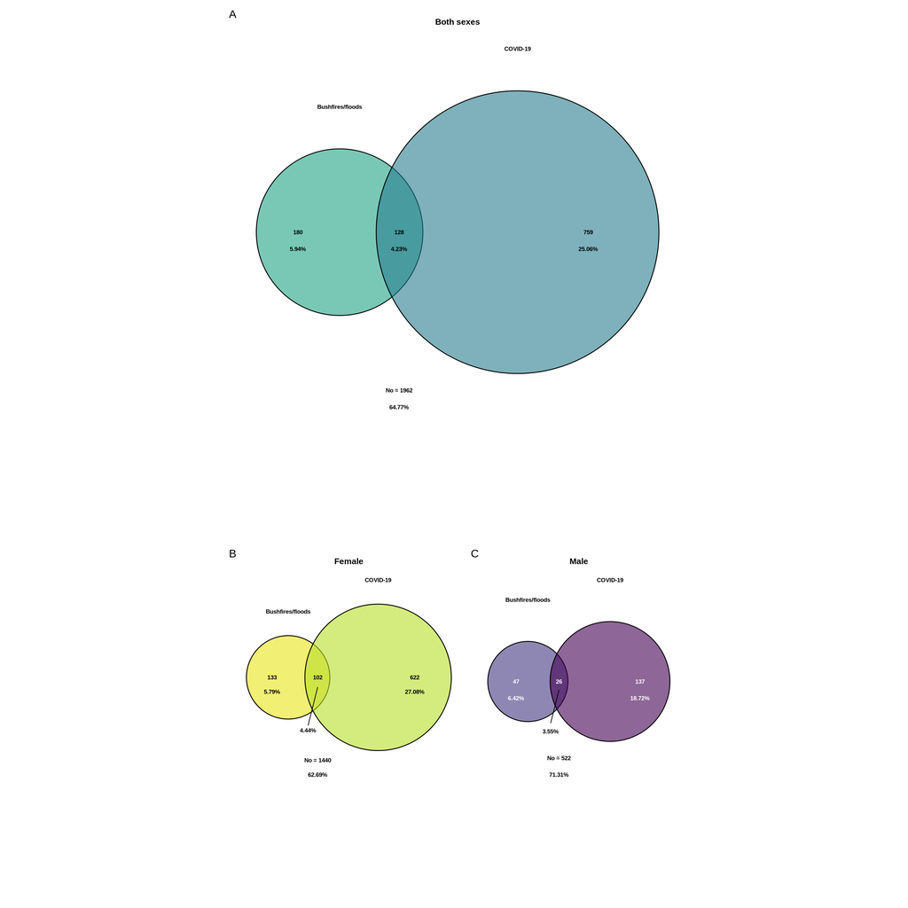

```r
# venn_bushflood_covid_male



# Panelled Figure
figure <- venn_bushflood_covid /
  (venn_bushflood_covid_female | venn_bushflood_covid_male) +
  plot_annotation(tag_levels = "A")

figure
```

```r
ggsave(figure, width = 18, height = 21, dpi = 300, unit = "cm",
       file = "figures/Venn_bushflood_covid_both_female_male.png")

ggsave(figure, width = 18, height = 21, dpi = 300, unit = "cm",
       file = "figures/Venn_bushflood_covid_both_female_male.pdf",
       device = cairo_pdf)
```

# Regressions Summary Figure

## Summary data

```r
# Function to process data
process_data <- function(model, sex_name, model_name) {
  CI <- as.data.frame(exp(confint(model))) %>%
    rownames_to_column() %>%
    rename('lower_95_CI_of_OR' = "2.5 %",
           'upper_95_CI_of_OR' = "97.5 %")

  df <- as.data.frame(coef(summary(model))) %>%
    rownames_to_column(var = 'rowname') %>%
    mutate(OR = exp(Estimate)) %>%
    rename('P' = 'Pr(>|z|)') %>%
    mutate(Sex = sex_name,
           Model = model_name)

  result <- df %>%
    full_join(CI)

  return(result)
}

# Process data for female and male for each model
ND_worst_both <- process_data(NDworse_PO, "Both", "ND_worst")
ND_worst_female <- process_data(NDworse_female_PO, "Female", "ND_worst")
ND_worst_male <- process_data(NDworse_male_PO, "Male", "ND_worst")

ND_First_both <- process_data(NDFirst_PO, "Both", "ND_first")
ND_First_female <- process_data(NDFirst_female_PO, "Female", "ND_first")
ND_First_male <- process_data(NDFirst_male_PO, "Male", "ND_first")

Twenty19BushFlood_both <- process_data(Twenty19BushFlood_PO, "Both", "Twenty19BushFlood")
Twenty19BushFlood_female <- process_data(Twenty19BushFlood_female_PO, "Female", "Twenty19BushFlood")
Twenty19BushFlood_male <- process_data(Twenty19BushFlood_male_PO, "Male", "Twenty19BushFlood")

Covid_both <- process_data(Covid_PO, "Both", "Covid")
Covid_female <- process_data(Covid_female_PO, "Female", "Covid")
Covid_male <- process_data(Covid_male_PO, "Male", "Covid")

Twenty19BushFloodCovidBoth_both <- process_data(Twenty19BushFloodCovidBoth_PO, "Both", "Twenty19BushFloodCovidBoth")
Twenty19BushFloodCovidBoth_female <- process_data(Twenty19BushFloodCovidBoth_female_PO, "Female", "Twenty19BushFloodCovidBoth")
Twenty19BushFloodCovidBoth_male <- process_data(Twenty19BushFloodCovidBoth_male_PO, "Male", "Twenty19BushFloodCovidBoth")


# Combine the results
NUMSYMPALL_PO_results_df <- bind_rows(ND_worst_both, ND_worst_female, ND_worst_male,
                              ND_First_both, ND_First_female, ND_First_male,
                              Twenty19BushFlood_both, Twenty19BushFlood_female, Twenty19BushFlood_male,
                              Covid_both, Covid_female, Covid_male,
                              Twenty19BushFloodCovidBoth_both, Twenty19BushFloodCovidBoth_female, Twenty19BushFloodCovidBoth_male)


# Subset df and put in order for graph
order <- c('NDEXPOS_DEPRWAFTERYes',
           'NDEXPOS_DEPRFAFTERYes',
           'BUSHFLOODHORR_followup1',
           'COVIDALLBIN_C1C21',
           'COVIDALL_BUSHFLOOD_bothYes')
order <- rev(order)

NUMSYMPALL_PO_plotting_df <- NUMSYMPALL_PO_results_df %>%
  filter(rowname == 'NDEXPOS_DEPRWAFTERYes' |
           rowname == 'NDEXPOS_DEPRFAFTERYes' |
           rowname == 'BUSHFLOODHORR_followup1' |
           rowname == 'COVIDALLBIN_C1C21' |
           rowname == 'COVIDALL_BUSHFLOOD_bothYes') %>%
  mutate(Significance = case_when(
    P >= 0.05 ~ "Non-significant",
    P < 0.05 ~ "Uncorrected (P < 0.05)"
  )) %>%
  mutate(P_adjusted = p.adjust(P, method = "BH", n = 15)) %>%
  mutate(star = case_when(
    P_adjusted >= 0.05 ~ "",
    P_adjusted < 0.05 ~ "*"
  )) %>%
  # mutate(P = ifelse(P >= 0.009, sprintf("%.2f", P), sprintf("%.0e", P))) %>%
  mutate(P_adjusted = ifelse(P_adjusted >= 0.009, sprintf("%.2f", P_adjusted), sprintf("%.0e", P_adjusted))) %>%
  mutate(rowname = factor(rowname, levels = order),
         Sex = factor(Sex, levels = c("Both", "Female", "Male")))

save(NUMSYMPALL_PO_results_df, file = "data/NUMSYMPALL_PO_results_df.RData")
save(NUMSYMPALL_PO_plotting_df, file = "data/NUMSYMPALL_PO_plotting_df.RData")
```

## Main Figure

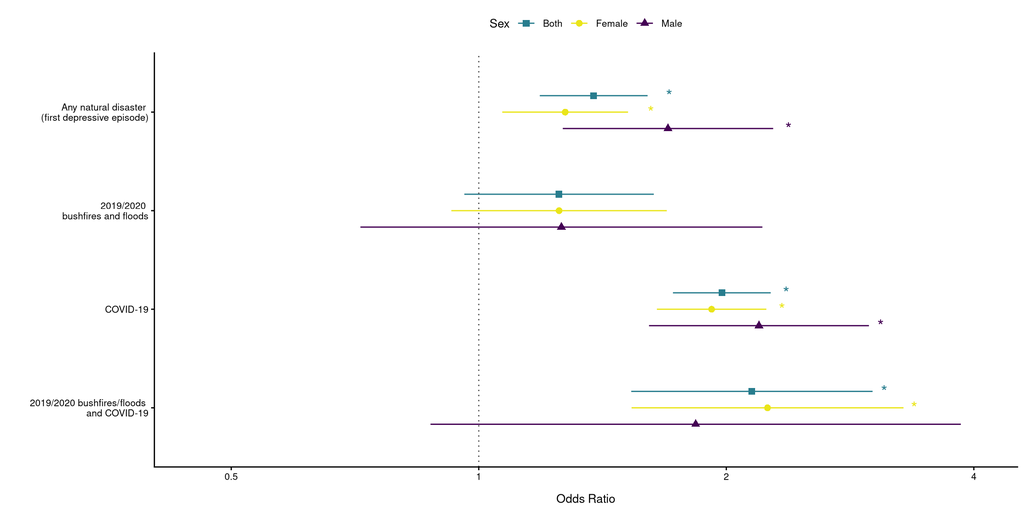

```r
# Main plot
plot_main <- ggplot(NUMSYMPALL_PO_plotting_df %>%
                      filter(rowname != 'NDEXPOS_DEPRWAFTERYes'),
                    aes(x = OR, y = rowname, colour = Sex, shape = Sex)) +
  geom_pointrange(aes(x = OR, xmin = lower_95_CI_of_OR,
                      xmax = upper_95_CI_of_OR),
                  position = position_dodge(width = -0.5)) +
  geom_text(aes(x = upper_95_CI_of_OR + 0.1,
                y = rowname,
                label = star),
            position = position_dodge(width = -0.5),
            size = 5,
            vjust = 0.5,
            show.legend = FALSE) +
  geom_vline(xintercept = 1,
             colour = "grey30",
             linetype = 'dotted') +
  scale_colour_manual(values = c("Both" = "#287d8e",
                                 "Female" = "#eae51a",
                                 "Male" = "#440154")) +
  scale_shape_manual(values = c("Both" = 15,
                                "Female" = 16,
                                "Male" = 17)) +
  scale_y_discrete("",
                   breaks = c('NDEXPOS_DEPRFAFTERYes',
                              'BUSHFLOODHORR_followup1',
                              'COVIDALLBIN_C1C21',
                              'COVIDALL_BUSHFLOOD_bothYes'),
                   labels = c('Any natural disaster \n(first depressive episode)',
                              '2019/2020 \nbushfires and floods',
                              'COVID-19',
                              '2019/2020 bushfires/floods \nand COVID-19')) +
  scale_x_continuous('Odds Ratio',
                     lim = c(0.45,4.05),
                     breaks = c(0.5, 1, 2, 4),
                     labels = c('0.5', '1', '2', '4'),
                     trans=scales::log2_trans()) +
  theme_classic() +
  theme(text = element_text(family = "sans"),
        axis.text.x = element_text(size = 8),
        axis.text.y = element_text(size = 8),
        axis.title.x = element_text(size = 10, colour = "black", margin = margin(10,0,0,0)),
        axis.title.y = element_text(size = 10, colour = "black", margin = margin(0,10,0,0)),
        legend.text = element_text(size = 8, colour = "black"),
        legend.title = element_text(size = 10, colour = "black"),
        legend.position = "top")

plot_main
```

## Sensitivity Analysis Figure

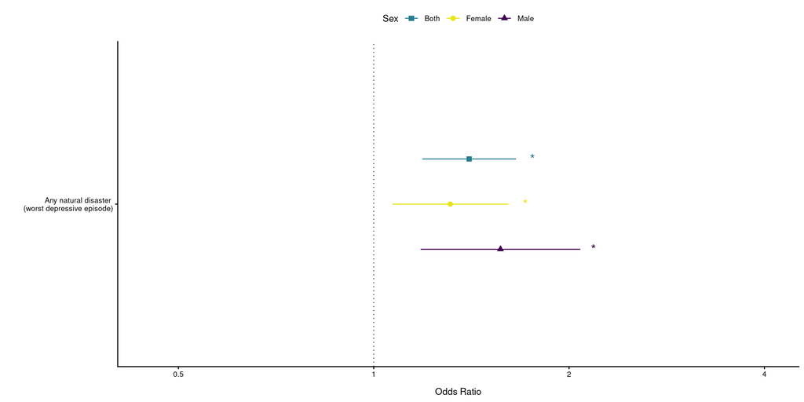

```r
# Sensitivity analysis graph of ND with worst depressive episode occurring after
plot_sensitivity <- ggplot(NUMSYMPALL_PO_plotting_df %>%
                             filter(rowname == 'NDEXPOS_DEPRWAFTERYes'),
       aes(x = OR, y = rowname, colour = Sex, shape = Sex)) +
  geom_pointrange(aes(x = OR, xmin = lower_95_CI_of_OR,
                      xmax = upper_95_CI_of_OR),
                  position = position_dodge(width = -0.5)) +
  geom_text(aes(x = upper_95_CI_of_OR + 0.1,
                y = rowname,
                label = star),
            position = position_dodge(width = -0.5),
            size = 5,
            vjust = 0.5,
            show.legend = FALSE) +
  geom_vline(xintercept = 1,
             colour = "grey30",
             linetype = 'dotted') +
  scale_colour_manual(values = c("Both" = "#287d8e",
                                 "Female" = "#eae51a",
                                 "Male" = "#440154")) +
  scale_shape_manual(values = c("Both" = 15,
                                "Female" = 16,
                                "Male" = 17)) +
  scale_y_discrete("",
                   breaks = c('NDEXPOS_DEPRWAFTERYes'),
                   labels = c('Any natural disaster \n(worst depressive episode)')) +
  scale_x_continuous('Odds Ratio',
                     lim = c(0.45,4.05),
                     breaks = c(0.5, 1, 2, 4),
                     labels = c('0.5', '1', '2', '4'),
                     trans=scales::log2_trans()) +
  theme_classic() +
  theme(text = element_text(family = "sans"),
        axis.text.x = element_text(size = 8),
        axis.text.y = element_text(size = 8),
        axis.title.x = element_text(size = 10, colour = "black", margin = margin(10,0,0,0)),
        axis.title.y = element_text(size = 10, colour = "black", margin = margin(0,10,0,0)),
        legend.text = element_text(size = 8, colour = "black"),
        legend.title = element_text(size = 10, colour = "black"),
        legend.position = "top")

plot_sensitivity
```

## Save Figures

```r
ggsave(plot_main, width = 18, height = 21, dpi = 300, unit = "cm",
       file = "figures/Figure_main_NDfirst_bushflood_covid_bushfloodcovid_both_female_male.png")

ggsave(plot_main, width = 18, height = 21, dpi = 300, unit = "cm",
       file = "figures/Figure_main_NDfirst_bushflood_covid_bushfloodcovid_both_female_male.pdf",
       device = cairo_pdf)



ggsave(plot_sensitivity, width = 18, height = 8, dpi = 300, unit = "cm",
       file = "figures/Figure_sensitivity_NDworst_both_female_male.png")

ggsave(plot_sensitivity, width = 18, height = 8, dpi = 300, unit = "cm",
       file = "figures/Figure_sensitivity_NDworst_both_female_male.pdf",
       device = cairo_pdf)
```

# Regressions Summary Tables

## Natural disaster / Bushfires/flooding / COVID as predictor

```r
NUMSYMPALL_PO_plotting_df %>%
  select(Model, Sex, OR, lower_95_CI_of_OR, upper_95_CI_of_OR, "z value", P, P_adjusted) %>%
  kable(caption = "Results from all regressions - natural disaster exposure or bushfires/flooding or COVID as the predictor")
```

Results from all regressions - natural disaster exposure or bushfires/flooding or COVID as the predictor

| Model | Sex | OR | lower_95_CI_of_OR | upper_95_CI_of_OR | z value | P | P_adjusted |
| --- | --- | --- | --- | --- | --- | --- | --- |
| ND_worst | Both | 1.402905 | 1.1879842 | 1.656708 | 3.9903022 | 0.0000660 | 1e-04 |
| ND_worst | Female | 1.312294 | 1.0683407 | 1.611954 | 2.5899371 | 0.0095993 | 0.01 |
| ND_worst | Male | 1.567936 | 1.1813067 | 2.081104 | 3.1133618 | 0.0018497 | 3e-03 |
| ND_first | Both | 1.379673 | 1.1863577 | 1.604489 | 4.1786761 | 0.0000293 | 8e-05 |
| ND_first | Female | 1.273737 | 1.0680309 | 1.519064 | 2.6923320 | 0.0070954 | 0.01 |
| ND_first | Male | 1.698692 | 1.2652677 | 2.280587 | 3.5254335 | 0.0004228 | 8e-04 |
| Twenty19BushFlood | Both | 1.252122 | 0.9603430 | 1.632550 | 1.6610259 | 0.0967083 | 0.12 |
| Twenty19BushFlood | Female | 1.252136 | 0.9260468 | 1.693052 | 1.4608116 | 0.1440672 | 0.15 |
| Twenty19BushFlood | Male | 1.260358 | 0.7179069 | 2.212684 | 0.8058244 | 0.4203441 | 0.42 |
| Covid | Both | 1.975209 | 1.7224793 | 2.265020 | 9.7443775 | 0.0000000 | 3e-21 |
| Covid | Female | 1.919439 | 1.6466545 | 2.237413 | 8.3370313 | 0.0000000 | 6e-16 |
| Covid | Male | 2.191633 | 1.6108104 | 2.981887 | 4.9945842 | 0.0000006 | 3e-06 |
| Twenty19BushFloodCovidBoth | Both | 2.148657 | 1.5325111 | 3.012525 | 4.4359502 | 0.0000092 | 3e-05 |
| Twenty19BushFloodCovidBoth | Female | 2.244810 | 1.5339994 | 3.284989 | 4.1625714 | 0.0000315 | 8e-05 |
| Twenty19BushFloodCovidBoth | Male | 1.835564 | 0.8735735 | 3.856910 | 1.6031837 | 0.1088941 | 0.13 |

## Polygenic score for depression as predictor

```r
NUMSYMPALL_PO_results_df %>%
  filter(rowname == 'PRS_stand_genetic') %>%
  mutate(P_adjusted = p.adjust(P, method = "BH", n = 15)) %>%
  select(Model, Sex, OR, lower_95_CI_of_OR, upper_95_CI_of_OR, "z value", P, P_adjusted) %>%
  kable(caption = "Results from all regressions - polygenic score as the predictor")
```

Results from all regressions - polygenic score as the predictor

| Model | Sex | OR | lower_95_CI_of_OR | upper_95_CI_of_OR | z value | P | P_adjusted |
| --- | --- | --- | --- | --- | --- | --- | --- |
| ND_worst | Both | 1.164914 | 1.0800233 | 1.256477 | 3.9540724 | 0.0000768 | 0.0001441 |
| ND_worst | Female | 1.106871 | 1.0082524 | 1.215135 | 2.1325789 | 0.0329593 | 0.0411991 |
| ND_worst | Male | 1.273663 | 1.1178667 | 1.451173 | 3.6337183 | 0.0002794 | 0.0004656 |
| ND_first | Both | 1.029979 | 0.9645739 | 1.099818 | 0.8824325 | 0.3775429 | 0.4197133 |
| ND_first | Female | 1.034126 | 0.9576876 | 1.116664 | 0.8564798 | 0.3917324 | 0.4197133 |
| ND_first | Male | 1.018180 | 0.8965557 | 1.156303 | 0.2775857 | 0.7813304 | 0.7813304 |
| Twenty19BushFlood | Both | 1.241111 | 1.1471008 | 1.342826 | 5.3747534 | 0.0000001 | 0.0000006 |
| Twenty19BushFlood | Female | 1.257036 | 1.1464323 | 1.378311 | 4.8680251 | 0.0000011 | 0.0000056 |
| Twenty19BushFlood | Male | 1.198636 | 1.0281759 | 1.397356 | 2.3149897 | 0.0206135 | 0.0281093 |
| Covid | Both | 1.219080 | 1.1447462 | 1.298240 | 6.1713809 | 0.0000000 | 0.0000000 |
| Covid | Female | 1.186558 | 1.1040598 | 1.275221 | 4.6524055 | 0.0000033 | 0.0000123 |
| Covid | Male | 1.342219 | 1.1776690 | 1.529761 | 4.4107104 | 0.0000103 | 0.0000309 |
| Twenty19BushFloodCovidBoth | Both | 1.182472 | 1.0912505 | 1.281320 | 4.0918216 | 0.0000428 | 0.0001070 |
| Twenty19BushFloodCovidBoth | Female | 1.126398 | 1.0254178 | 1.237323 | 2.4837384 | 0.0130011 | 0.0195017 |
| Twenty19BushFloodCovidBoth | Male | 1.384150 | 1.1814537 | 1.621622 | 4.0239655 | 0.0000572 | 0.0001226 |

# Sensitivity Analysis: Linear Models

- Run linear models to check categorisation of number of depressive symptoms isn’t affecting the results

## Fit models

```r
NDworse_linear <- lm(NUMSYMPALL_baseline ~
                       PRS_stand_genetic +
                       NDEXPOS_DEPRWAFTER +
                       AGE_baseline +
                       SEX_genetic +
                       PC1_genetic +
                       PC2_genetic +
                       PC3_genetic +
                       PC4_genetic +
                       PC5_genetic +
                       PC6_genetic +
                       PC7_genetic +
                       PC8_genetic +
                       PC9_genetic +
                       PC10_genetic,
                     data = df_ND_covid)

NDFirst_linear <- lm(NUMSYMPALL_followup ~
                       PRS_stand_genetic +
                       NDEXPOS_DEPRFAFTER +
                       AGE_baseline +
                       SEX_genetic +
                       PC1_genetic +
                       PC2_genetic +
                       PC3_genetic +
                       PC4_genetic +
                       PC5_genetic +
                       PC6_genetic +
                       PC7_genetic +
                       PC8_genetic +
                       PC9_genetic +
                       PC10_genetic,
                     data = df_ND_covid)

Twenty19BushFlood_linear <- lm(NUMSYMPALL_covid1 ~
                                     PRS_stand_genetic +
                                     BUSHFLOODHORR_followup +
                                     AGE_followup +
                                     SEX_genetic +
                                     PC1_genetic +
                                     PC2_genetic +
                                     PC3_genetic +
                                     PC4_genetic +
                                     PC5_genetic +
                                     PC6_genetic +
                                     PC7_genetic +
                                     PC8_genetic +
                                     PC9_genetic +
                                     PC10_genetic,
                                   data = df_ND_covid)


Covid_linear <- lm(NUMSYMPALL_covid2 ~
                         PRS_stand_genetic +
                         COVIDALLBIN_C1C2 +
                         AGE_covid2 +
                         SEX_genetic +
                         PC1_genetic +
                         PC2_genetic +
                         PC3_genetic +
                         PC4_genetic +
                         PC5_genetic +
                         PC6_genetic +
                         PC7_genetic +
                         PC8_genetic +
                         PC9_genetic +
                         PC10_genetic,
                       data = df_ND_covid)


Twenty19BushFloodCovidBoth_linear <- lm(NUMSYMPALL_covid2 ~
                                              PRS_stand_genetic +
                                              COVIDALL_BUSHFLOOD_both +
                                              AGE_covid2 +
                                              SEX_genetic +
                                              PC1_genetic +
                                              PC2_genetic +
                                              PC3_genetic +
                                              PC4_genetic +
                                              PC5_genetic +
                                              PC6_genetic +
                                              PC7_genetic +
                                              PC8_genetic +
                                              PC9_genetic +
                                              PC10_genetic,
                                            data = df_ND_covid)

linear_models <- ls(pattern = "*_linear$")
save(list = linear_models, file = "models/linear_models.RData")
```

## Results table

```r
ND_worst <- tidy(NDworse_linear, conf.int = T) %>%
  mutate(Model = "ND_worst")

ND_first <- tidy(NDFirst_linear, conf.int = T) %>%
  mutate(Model = "ND_first")

Twenty19BushFlood <- tidy(Twenty19BushFlood_linear, conf.int = T) %>%
  mutate(Model = "Twenty19BushFlood")

Covid <- tidy(Covid_linear, conf.int = T) %>%
  mutate(Model = "Covid")

Twenty19BushFloodCovidBoth <- tidy(Twenty19BushFloodCovidBoth_linear, conf.int = T) %>%
  mutate(Model = "Twenty19BushFloodCovidBoth")

# Combine the results
NUMSYMPALL_linear_results_df <- bind_rows(ND_worst,
                                      ND_first,
                                      Twenty19BushFlood,
                                      Covid,
                                      Twenty19BushFloodCovidBoth)

NUMSYMPALL_linear_results_df %>%
  filter(term == 'NDEXPOS_DEPRWAFTERYes' |
           term == 'NDEXPOS_DEPRFAFTERYes' |
           term == 'BUSHFLOODHORR_followup1' |
           term == 'COVIDALLBIN_C1C21' |
           term == 'COVIDALL_BUSHFLOOD_bothYes') %>%
  mutate(P_adjusted = p.adjust(p.value, method = "BH", n = 5)) %>%
  select(Model, term, estimate, conf.low, conf.high, statistic, p.value, P_adjusted) %>%
  kable()
```

| Model | term | estimate | conf.low | conf.high | statistic | p.value | P_adjusted |
| --- | --- | --- | --- | --- | --- | --- | --- |
| ND_worst | NDEXPOS_DEPRWAFTERYes | 0.1451297 | 0.0968074 | 0.1934520 | 5.887320 | 0.0000000 | 0.0000000 |
| ND_first | NDEXPOS_DEPRFAFTERYes | 0.3009163 | 0.1832813 | 0.4185513 | 5.015106 | 0.0000006 | 0.0000009 |
| Twenty19BushFlood | BUSHFLOODHORR_followup1 | 0.3234598 | -0.0396363 | 0.6865559 | 1.747006 | 0.0807808 | 0.0807808 |
| Covid | COVIDALLBIN_C1C21 | 0.9445016 | 0.7669009 | 1.1221023 | 10.426962 | 0.0000000 | 0.0000000 |
| Twenty19BushFloodCovidBoth | COVIDALL_BUSHFLOOD_bothYes | 1.0294488 | 0.5792393 | 1.4796582 | 4.484269 | 0.0000077 | 0.0000096 |

# Sensitivity Analysis: Trauma Burden Score covariate

- Run oridinal regression models including an overall trauma burden score as an extra covariate

## Create trauma burden score

- Create trauma burden score using the LEC-5
- Use 16 items, excluding the natural disaster item
- 1 = happened to me / witness / learned / part of my job
- 0 = doesn’t apply
- Sum so get 0 - 16 trauma burden

```r
# For each of 16 qs (17 items excluding natural disaster item): 1 = if happened to me / witness / learned/ part of my job, 0 = doesn't apply
# Sum so get 0 - 16 trauma burden
# LEC5EXA1 = natural disaster happened to me, LEC5EXA2 = witnessed it = LEC5EXA3 = learned about it, LEC5EXA4 = part of my job, LEC5EXA5 = not sure, LEC5EXA6 = doesn't apply
# LEAC5EXB1-6 = fire or explosion, etc until Q.


# Event letters B-Q (exclude natural disaster item A)
event_letters <- LETTERS[2:17]

# Create one binary variable per event
for (event in event_letters) {

  exposure_cols <- paste0("LEC5EX", event, 1:4, "_baseline")
  doesnt_apply_col <- paste0("LEC5EX", event, "6_baseline")

  df_ND_covid <- df_ND_covid %>%
    mutate(
      !!paste0("LEC_", event, "_BIN") :=
        case_when(
          # Any exposure endorsed
          rowSums(across(all_of(exposure_cols)) == 1,
                  na.rm = TRUE) > 0 ~ 1,

          # Doesn't apply endorsed
          .data[[doesnt_apply_col]] == 1 ~ 0,

          TRUE ~ NA_real_
        )
    )
}

# Sum across all non-disaster trauma types
df_ND_covid <- df_ND_covid %>%
  mutate(
    TRAUMA_BURDEN = rowSums(
      select(., starts_with("LEC_"), ends_with("_BIN")),
      na.rm = FALSE
    )
  )

# Checks
a <- df_ND_covid %>%
  select(starts_with("LEC_"), ends_with("_BIN"), TRAUMA_BURDEN)

b <- df_ND_covid %>%
  select(LEC5EXB1_baseline, LEC5EXB2_baseline, LEC5EXB3_baseline, LEC5EXB4_baseline, LEC5EXB5_baseline, LEC5EXB6_baseline, LEC_B_BIN)

df_ND_covid %>%
  count(TRAUMA_BURDEN)

save(df_ND_covid, file = "data/df_ND_covid.RData")
```

## Fit models

```r
NDworse_PO_trauma <- VGAM::vglm(NUMSYMPALL_baseline_cat ~
                           PRS_stand_genetic +
                           NDEXPOS_DEPRWAFTER +
                           AGE_baseline +
                           SEX_genetic +
                           PC1_genetic +
                           PC2_genetic +
                           PC3_genetic +
                           PC4_genetic +
                           PC5_genetic +
                           PC6_genetic +
                           PC7_genetic +
                           PC8_genetic +
                           PC9_genetic +
                           PC10_genetic +
                             TRAUMA_BURDEN,
                         family = VGAM::cumulative(logitlink, parallel = T, reverse = T), # with PO (package pammtools masks VGAM cumulative so specify from VGAM)
                         data = df_ND_covid)

NDFirst_PO_trauma <- VGAM::vglm(NUMSYMPALL_followup_cat ~
                           PRS_stand_genetic +
                           NDEXPOS_DEPRFAFTER +
                           AGE_baseline +
                           SEX_genetic +
                           PC1_genetic +
                           PC2_genetic +
                           PC3_genetic +
                           PC4_genetic +
                           PC5_genetic +
                           PC6_genetic +
                           PC7_genetic +
                           PC8_genetic +
                           PC9_genetic +
                           PC10_genetic +
                           TRAUMA_BURDEN,
                         family = VGAM::cumulative(logitlink, parallel = T, reverse = T), # with PO (package pammtools masks VGAM cumulative so specify from VGAM)
                         data = df_ND_covid)

Twenty19BushFlood_PO_trauma <- VGAM::vglm(NUMSYMPALL_covid1_cat ~
                                     PRS_stand_genetic +
                                     BUSHFLOODHORR_followup +
                                     AGE_followup +
                                     SEX_genetic +
                                     PC1_genetic +
                                     PC2_genetic +
                                     PC3_genetic +
                                     PC4_genetic +
                                     PC5_genetic +
                                     PC6_genetic +
                                     PC7_genetic +
                                     PC8_genetic +
                                     PC9_genetic +
                                     PC10_genetic +
                                     TRAUMA_BURDEN,
                                   family = VGAM::cumulative(logitlink, parallel = T, reverse = T), # with PO (package pammtools masks VGAM cumulative so specify from VGAM)
                                   data = df_ND_covid)

Covid_PO_trauma <- VGAM::vglm(NUMSYMPALL_covid2_cat ~
                         PRS_stand_genetic +
                         COVIDALLBIN_C1C2 +
                         AGE_covid2 +
                         SEX_genetic +
                         PC1_genetic +
                         PC2_genetic +
                         PC3_genetic +
                         PC4_genetic +
                         PC5_genetic +
                         PC6_genetic +
                         PC7_genetic +
                         PC8_genetic +
                         PC9_genetic +
                         PC10_genetic +
                           TRAUMA_BURDEN,
                       family = VGAM::cumulative(logitlink, parallel = T, reverse = T), # with PO (package pammtools masks VGAM cumulative so specify from VGAM)
                       data = df_ND_covid)

Twenty19BushFloodCovidBoth_PO_trauma <- VGAM::vglm(NUMSYMPALL_covid2_cat ~
                                              PRS_stand_genetic +
                                              COVIDALL_BUSHFLOOD_both +
                                              AGE_covid2 +
                                              SEX_genetic +
                                              PC1_genetic +
                                              PC2_genetic +
                                              PC3_genetic +
                                              PC4_genetic +
                                              PC5_genetic +
                                              PC6_genetic +
                                              PC7_genetic +
                                              PC8_genetic +
                                              PC9_genetic +
                                              PC10_genetic +
                                              TRAUMA_BURDEN,
                                            family = VGAM::cumulative(logitlink, parallel = T, reverse = T), # with PO (package pammtools masks VGAM cumulative so specify from VGAM)
                                            data = df_ND_covid)

trauma_models <- ls(pattern = "*_trauma$")
save(list = trauma_models, file = "models/trauma_models.RData")
```

## Results table

```r
# Function to process data
process_data <- function(model, model_name) {
  CI <- as.data.frame(exp(confint(model))) %>%
    rownames_to_column() %>%
    rename('lower_95_CI_of_OR' = "2.5 %",
           'upper_95_CI_of_OR' = "97.5 %")

  df <- as.data.frame(coef(summary(model))) %>%
    rownames_to_column(var = 'rowname') %>%
    mutate(OR = exp(Estimate)) %>%
    rename('P' = 'Pr(>|z|)') %>%
    mutate(Model = model_name)

  result <- df %>%
    full_join(CI)

  return(result)
}

# Process data
ND_worst <- process_data(NDworse_PO_trauma, "ND_worst")
ND_First <- process_data(NDFirst_PO_trauma, "ND_first")
Twenty19BushFlood <- process_data(Twenty19BushFlood_PO_trauma, "Twenty19BushFlood")
Covid <- process_data(Covid_PO_trauma, "Covid")
Twenty19BushFloodCovidBoth <- process_data(Twenty19BushFloodCovidBoth_PO_trauma, "Twenty19BushFloodCovidBoth")

# Combine the results
results_df <- bind_rows(ND_worst, ND_First, Twenty19BushFlood, Covid, Twenty19BushFloodCovidBoth)


# Subset df and put in order for graph
order <- c('NDEXPOS_DEPRWAFTERYes',
           'NDEXPOS_DEPRFAFTERYes',
           'BUSHFLOODHORR_followup1',
           'COVIDALLBIN_C1C21',
           'COVIDALL_BUSHFLOOD_bothYes')
order <- rev(order)

results_df <- results_df %>%
  filter(rowname == 'NDEXPOS_DEPRWAFTERYes' |
           rowname == 'NDEXPOS_DEPRFAFTERYes' |
           rowname == 'BUSHFLOODHORR_followup1' |
           rowname == 'COVIDALLBIN_C1C21' |
           rowname == 'COVIDALL_BUSHFLOOD_bothYes') %>%
  mutate(P_adjusted = p.adjust(P, method = "BH", n = 5)) %>%
  mutate(P_adjusted = ifelse(P_adjusted >= 0.009, sprintf("%.2f", P_adjusted), sprintf("%.0e", P_adjusted))) %>%
  select(rowname, Model, OR, lower_95_CI_of_OR, upper_95_CI_of_OR, "z value", P, P_adjusted, Estimate, "Std. Error")

results_df %>%  kable()
```

| rowname | Model | OR | lower_95_CI_of_OR | upper_95_CI_of_OR | z value | P | P_adjusted | Estimate | Std. Error |
| --- | --- | --- | --- | --- | --- | --- | --- | --- | --- |
| NDEXPOS_DEPRWAFTERYes | ND_worst | 1.096039 | 0.8597468 | 1.397273 | 0.7401937 | 0.4591824 | 0.50 | 0.0917026 | 0.1238900 |
| NDEXPOS_DEPRFAFTERYes | ND_first | 1.265688 | 1.0170753 | 1.575072 | 2.1117098 | 0.0347113 | 0.06 | 0.2356160 | 0.1115759 |
| BUSHFLOODHORR_followup1 | Twenty19BushFlood | 1.132975 | 0.7906597 | 1.623496 | 0.6802115 | 0.4963705 | 0.50 | 0.1248470 | 0.1835414 |
| COVIDALLBIN_C1C21 | Covid | 1.943637 | 1.6075204 | 2.350033 | 6.8601007 | 0.0000000 | 3e-11 | 0.6645612 | 0.0968734 |
| COVIDALL_BUSHFLOOD_bothYes | Twenty19BushFloodCovidBoth | 1.949421 | 1.2294620 | 3.090979 | 2.8383194 | 0.0045352 | 0.01 | 0.6675323 | 0.2351858 |

# Explore Missingness

## Any natural disaster (first depression)

```r
# ND (first)
# Subset only to individuals that started baseline survey + started follow-up survey + have genetic data
# Then calculate missingness for relevant variables: NUMSYMPALL_followup, AGE_baseline, NDEXPOS_DEPRFAFTER (should be no missingness for variables derived from genetci data: PCs, sex, PGS)

# have genetic data (6,450 missiing PGS data) and participated in the follow-up survey (answered at least 1 q.) (12,733 did not answer at least one follow-up q.)

# If in dataset then started baseline survey
# Determine who completed at least on q. in the followup survey
df_ND_covid <- df_ND_covid %>%
  mutate(num_followup_qs_answered = rowSums(!is.na(select(., ends_with("_followup")))),
         started_followup = case_when(
           num_followup_qs_answered > 0 ~ TRUE,
           num_followup_qs_answered == 0 ~ FALSE
         ))

df_ND_covid %>%
  count(started_followup)
```

| started_followup | n |
| --- | --- |
| FALSE | 12733 |
| TRUE | 9098 |

```r
# 9,098 people answered at least 1 question in the follow-up survey (12,733 didn't answer any qs in follow-up survey)

df_ND_covid %>%
  count(is.na(PRS_stand_genetic), is.na(SEX_genetic), is.na(PC1_genetic)) %>%
  kable()
```

| is.na(PRS_stand_genetic) | is.na(SEX_genetic) | is.na(PC1_genetic) | n |
| --- | --- | --- | --- |
| FALSE | FALSE | FALSE | 15302 |
| FALSE | TRUE | FALSE | 79 |
| TRUE | TRUE | TRUE | 6450 |

```r
# 15,302 people have data for PRS, PC and sex
# 6,450 people don't have data for PRS, PC and sex
# 79 people don't have sex data but do have PRS and PC data

# Eligible participants
df_ND_covid <- df_ND_covid %>%
  mutate(eligible_NDfirst = as.vector(!is.na(PRS_stand_genetic) & started_followup == TRUE))

df_ND_covid %>% count(eligible_NDfirst)
```

| eligible_NDfirst | n |
| --- | --- |
| FALSE | 13712 |
| TRUE | 8119 |

```r
# 8,119 people eligible for any ND (first) analyses (started baseline survey + started follow-up survey + have genotype data)

# Now look at numbers missing for variables of interest
df_ND_covid <- df_ND_covid %>%
  mutate(NDEXPOS_deprfirst_dontmeettimingdefinition = case_when(
    (NDEXPOS_baseline == "Yes" & NDFDEPRF_baseline == "before") |
      (NDEXPOS_baseline == "Yes" & NDFDEPRF_baseline == "same year") ~ TRUE
  ),
  NDEXPOS_deprfirst_missing_NDexpos = is.na(NDEXPOS_baseline),
  NDEXPOS_deprfirst_missing_timing = case_when(
    (NDEXPOS_baseline == "Yes" & is.na(NDFDEPRF_baseline)) ~ TRUE
  )
  )

df_ND_covid %>%
  filter(eligible_NDfirst == TRUE) %>%
  summarise(
    n = n(),
    NUMSYMPALL_missing = sum(is.na(NUMSYMPALL_followup)),
    NUMSYMPALL_missing_perc = sum(is.na(NUMSYMPALL_followup))/n * 100,
    AGE_missing = sum(is.na(AGE_baseline)),
    AGE_missing_perc = sum(is.na(AGE_baseline))/n * 100,
    NDEXPOS_missing = sum(is.na(NDEXPOS_DEPRFAFTER)),
    NDEXPOS_missing_perc = sum(is.na(NDEXPOS_DEPRFAFTER))/n * 100,
    NDEXPOS_dontmeettimingdefinition = sum(NDEXPOS_deprfirst_dontmeettimingdefinition == TRUE, na.rm = TRUE),
    NDEXPOS_dontmeettimingdefinition_perc = sum(NDEXPOS_deprfirst_dontmeettimingdefinition == TRUE, na.rm = TRUE)/n * 100,
    NDEXPOS_missing_NDexpos = sum(is.na(NDEXPOS_baseline)),
    NDEXPOS_missing_NDexpos_perc = sum(is.na(NDEXPOS_baseline))/n * 100,
    NDEXPOS_missing_timing = sum(NDEXPOS_deprfirst_missing_timing == TRUE, na.rm = TRUE),
    NDEXPOS_missing_timing_perc = sum(NDEXPOS_deprfirst_missing_timing == TRUE, na.rm = TRUE)/n * 100,
    SEX_missing = sum(is.na(SEX_genetic)),
    SEX_missing_perc = sum(is.na(SEX_genetic))/n * 100) %>%
  t() %>%
  kable(caption = "Comparison of each variable across participants missing data and not missing data for the natural disaster exposure variable")
```

Comparison of each variable across participants missing data and not missing data for the natural disaster exposure variable

| n | 8119.0000000 |
| --- | --- |
| NUMSYMPALL_missing | 925.0000000 |
| NUMSYMPALL_missing_perc | 11.3930287 |
| AGE_missing | 22.0000000 |
| AGE_missing_perc | 0.2709693 |
| NDEXPOS_missing | 3293.0000000 |
| NDEXPOS_missing_perc | 40.5591822 |
| NDEXPOS_dontmeettimingdefinition | 1149.0000000 |
| NDEXPOS_dontmeettimingdefinition_perc | 14.1519892 |
| NDEXPOS_missing_NDexpos | 1185.0000000 |
| NDEXPOS_missing_NDexpos_perc | 14.5953935 |
| NDEXPOS_missing_timing | 959.0000000 |
| NDEXPOS_missing_timing_perc | 11.8117995 |
| SEX_missing | 48.0000000 |
| SEX_missing_perc | 0.5912058 |

```r
# Compare variables across missing vs observed ND exposure (not including doesn't meet temporal definition, i.e. missingness is because didnt answer questions)
test_data <- df_ND_covid %>%
  filter(eligible_NDfirst) %>%
  mutate(
    ND_missing = case_when(
      NDEXPOS_deprfirst_missing_NDexpos == TRUE ~ "no_answer",
      NDEXPOS_deprfirst_missing_timing == TRUE ~ "no_answer",
      !is.na(NDEXPOS_DEPRFAFTER) ~ "observed",
      NDEXPOS_deprfirst_dontmeettimingdefinition == TRUE ~ "dont_meet_temporal_definition"
    ))

test_data %>%
  group_by(ND_missing) %>%
  summarise(
    n = n(),
    age = mean(AGE_baseline, na.rm = TRUE),
    female = mean(SEX_genetic == "Female", na.rm = TRUE),
    pgs = mean(PRS_stand_genetic, na.rm = TRUE),
    num_depression_symptoms = mean(NUMSYMPALL_followup, na.rm = TRUE)
  ) %>%
  kable
```

| ND_missing | n | age | female | pgs | num_depression_symptoms |
| --- | --- | --- | --- | --- | --- |
| dont_meet_temporal_definition | 1149 | 43.66667 | 0.8216783 | 0.0404145 | 7.025281 |
| no_answer | 2144 | 47.06456 | 0.7507042 | -0.0036648 | 7.063228 |
| observed | 4826 | 44.89722 | 0.7554722 | 0.0015940 | 7.063613 |

```r
test_data <- test_data %>%
  filter_out(ND_missing == "dont_meet_temporal_definition") %>%
  mutate(ND_missing = case_when(
    ND_missing == "no_answer" ~ TRUE,
    ND_missing == "observed" ~ FALSE
  ))

# Age
age_model <- glm(ND_missing ~ AGE_baseline,
                 family = binomial(link = logit),
                 data = test_data)

age_result <- tidy(age_model, conf.int = TRUE, conf.level = 0.95, exponentiate = TRUE) %>%
  filter(term == "AGE_baseline")

# PGS
pgs_model <- glm(ND_missing ~ PRS_stand_genetic,
                 family = binomial(link = logit),
                 data = test_data)

pgs_result <- tidy(pgs_model, conf.int = TRUE, conf.level = 0.95, exponentiate = TRUE) %>%
  filter(term == "PRS_stand_genetic")

# Symptoms
symptom_model <- glm(ND_missing ~ NUMSYMPALL_followup,
                     family = binomial(link = logit),
                     data = test_data)

symptom_result <- tidy(symptom_model, conf.int = TRUE, conf.level = 0.95, exponentiate = TRUE) %>%
  filter(term == "NUMSYMPALL_followup")

# Sex
sex_model <- glm(ND_missing ~ SEX_genetic,
                 family = binomial(link = logit),
                 data = test_data)

sex_result <- tidy(sex_model, conf.int = TRUE, conf.level = 0.95, exponentiate = TRUE) %>%
  filter(term == "SEX_geneticFemale")

age_result %>% bind_rows(sex_result, pgs_result, symptom_result) %>%
  rename(OR = estimate,
         SE = std.error,
         Statistic = statistic,
         Lower_CI = conf.low,
         Upper_CI = conf.high,
         P = p.value) %>%
  mutate(Padj = p.adjust(P, method = "BH", n = 4)) %>%
  select(term, OR, SE, Lower_CI, Upper_CI, Statistic, P, Padj) %>%
  kable(caption = "Comparison of each variable across participants with data and without data for the any natural disaster exposure variable")
```

Comparison of each variable across participants with data and without data for the any natural disaster exposure variable

| term | OR | SE | Lower_CI | Upper_CI | Statistic | P | Padj |
| --- | --- | --- | --- | --- | --- | --- | --- |
| AGE_baseline | 1.0094429 | 0.0017196 | 1.0060495 | 1.012855 | 5.4655442 | 0.0000000 | 0.0000002 |
| SEX_geneticFemale | 0.9746838 | 0.0603082 | 0.8663895 | 1.097484 | -0.4251847 | 0.6707021 | 0.9937445 |
| PRS_stand_genetic | 0.9946198 | 0.0262879 | 0.9446614 | 1.047213 | -0.2052164 | 0.8374030 | 0.9937445 |
| NUMSYMPALL_followup | 0.9998746 | 0.0159931 | 0.9691200 | 1.031834 | -0.0078402 | 0.9937445 | 0.9937445 |

```r
# Compare variables across missing vs observed depression symptoms
df_ND_covid %>%
  filter(eligible_NDfirst) %>%
  mutate(
    symptoms_missing = is.na(NUMSYMPALL_followup)
  ) %>%
  group_by(symptoms_missing) %>%
  summarise(
    n = n(),
    age = mean(AGE_baseline, na.rm = TRUE),
    female = mean(SEX_genetic == "Female", na.rm = TRUE),
    pgs = mean(PRS_stand_genetic, na.rm = TRUE),
    ND_exposed = mean(NDEXPOS_DEPRFAFTER == "Yes", na.rm = TRUE)
  ) %>%
  kable()
```

| symptoms_missing | n | age | female | pgs | ND_exposed |
| --- | --- | --- | --- | --- | --- |
| FALSE | 7194 | 44.98383 | 0.7629702 | 0.0311221 | 0.2683322 |
| TRUE | 925 | 47.67787 | 0.7684783 | -0.1920230 | 0.2047714 |

```r
# Age
age_model <- glm(is.na(NUMSYMPALL_followup) ~ AGE_baseline,
            family = binomial(link = logit),
            data = df_ND_covid %>%
              filter(eligible_NDfirst))

age_result <- tidy(age_model, conf.int = TRUE, conf.level = 0.95, exponentiate = TRUE) %>%
  filter(term == "AGE_baseline")

# PGS
pgs_model <- glm(is.na(NUMSYMPALL_followup) ~ PRS_stand_genetic,
            family = binomial(link = logit),
            data = df_ND_covid %>%
              filter(eligible_NDfirst))

pgs_result <- tidy(pgs_model, conf.int = TRUE, conf.level = 0.95, exponentiate = TRUE) %>%
  filter(term == "PRS_stand_genetic")

# ND exposure
nd_model <- glm(is.na(NUMSYMPALL_followup) ~ NDEXPOS_DEPRFAFTER,
            family = binomial(link = logit),
            data = df_ND_covid %>%
              filter(eligible_NDfirst))

nd_result <- tidy(nd_model, conf.int = TRUE, conf.level = 0.95, exponentiate = TRUE) %>%
  filter(term == "NDEXPOS_DEPRFAFTERYes")

# Sex
sex_model <- glm(is.na(NUMSYMPALL_followup) ~ SEX_genetic,
            family = binomial(link = logit),
            data = df_ND_covid %>%
              filter(eligible_NDfirst))

sex_result <- tidy(sex_model, conf.int = TRUE, conf.level = 0.95, exponentiate = TRUE) %>%
  filter(term == "SEX_geneticFemale")

age_result %>% bind_rows(sex_result, pgs_result, nd_result) %>%
  rename(OR = estimate,
         SE = std.error,
         Statistic = statistic,
         Lower_CI = conf.low,
         Upper_CI = conf.high,
         P = p.value) %>%
  mutate(Padj = p.adjust(P, method = "BH", n = 4)) %>%
  select(term, OR, SE, Lower_CI, Upper_CI, Statistic, P, Padj) %>%
  kable(caption = "Comparison of each variable across participants with data and without data for the outcome variable (number depression symptoms)")
```

Comparison of each variable across participants with data and without data for the outcome variable (number depression symptoms)

| term | OR | SE | Lower_CI | Upper_CI | Statistic | P | Padj |
| --- | --- | --- | --- | --- | --- | --- | --- |
| AGE_baseline | 1.0118699 | 0.0023213 | 1.0072818 | 1.0164916 | 5.0833649 | 0.0000004 | 0.0000007 |
| SEX_geneticFemale | 1.0311816 | 0.0829592 | 0.8779798 | 1.2155797 | 0.3701256 | 0.7112889 | 0.7112889 |
| PRS_stand_genetic | 0.7947817 | 0.0356457 | 0.7410526 | 0.8521980 | -6.4436381 | 0.0000000 | 0.0000000 |
| NDEXPOS_DEPRFAFTERYes | 0.7021315 | 0.1157020 | 0.5572056 | 0.8773675 | -3.0564256 | 0.0022399 | 0.0029866 |

## 2019 Bushfires/Floods

```r
# 2019 bushfires/floods
# Subset only to individuals that started follow-up survey + started COVID wave 1 survey + have genetic data
# Calculated num current symptoms from COVID Wave 1 survey -  participants were radomly assigned to 2 conditions - asked about covid-19 experiences in the last 2 weeks, or asked about covid-19 experiences in the worst period (month) identified between jan 2020 and feb 2021.
# Thus, only participants assigned to 1st condition were asked about current depression symptoms and are eligible
# So subset to only individuals that started follow-up survey + started COVID wave 1 survey + were subset to condition 1 in COVID wave 1 survey (i.e. col 'groupB_covid1' has '2w') + have genetic data
# Then calculate missingness for relevant variables: NUMSYMPALL_covid1_cat, AGE_followup, BUSHFLOODHORR_followup (should be no missingness for variables derived from genetic data: PCs, sex, PGS)


# Determine who completed at least on q. in the followup survey and covid wave 1 survey
df_ND_covid <- df_ND_covid %>%
  mutate(num_followup_qs_answered = rowSums(!is.na(select(., ends_with("_followup")))),
         started_followup = case_when(
           num_followup_qs_answered > 0 ~ TRUE,
           num_followup_qs_answered == 0 ~ FALSE
         ),
         num_covid1_qs_answered = rowSums(!is.na(select(., ends_with("_covid1")))),
         started_covid1 = case_when(
           num_covid1_qs_answered > 0 ~ TRUE,
           num_covid1_qs_answered == 0 ~ FALSE
         ))

df_ND_covid %>%
  count(started_followup)
```

| started_followup | n |
| --- | --- |
| TRUE | 21831 |

```r
# 9,098 people answered at least 1 question in the follow-up survey (12,733 didn't answer any qs in follow-up survey)
df_ND_covid %>%
  count(started_covid1)
```

| started_covid1 | n |
| --- | --- |
| FALSE | 15709 |
| TRUE | 6122 |

```r
# 6,122 people answered at least 1 question in COVID wave 1 (15,709 didnt answer any qs in covid wave 1 survey)
df_ND_covid %>%
  count(groupB_covid1)
```

| groupB_covid1 | n |
| --- | --- |
|  | 139 |
| 2w | 3029 |
| 2wb | 1032 |
| WM | 351 |
| WMb | 1571 |
| NA | 15709 |

```r
# 3,029 people aswered questions on last 2 weeks for COVID wave 1

# Eligible participants
df_ND_covid <- df_ND_covid %>%
  mutate(eligible_covid1 = as.vector(!is.na(PRS_stand_genetic) & started_followup == TRUE & started_covid1 == TRUE & groupB_covid1 == "2w"))

df_ND_covid %>% count(eligible_covid1)
```

| eligible_covid1 | n |
| --- | --- |
| FALSE | 19121 |
| TRUE | 2710 |

```r
# 2,342 people eligible for bushfires/floods analyses (started follow-up survey + started COVID wave 1 survey + randomly assigned to qs asking about last 2 weeks in COVID wave 1 survey + have genotype data)

# Now look at numbers missing for variables of interest
df_ND_covid %>%
  filter(eligible_covid1 == TRUE) %>%
  summarise(
    n = n(),
    NUMSYMPALL_missing = sum(is.na(NUMSYMPALL_covid1_cat)),
    NUMSYMPALL_missing_perc = sum(is.na(NUMSYMPALL_covid1_cat))/n * 100,
    AGE_missing = sum(is.na(AGE_followup)),
    AGE_missing_perc = sum(is.na(AGE_followup))/n * 100,
    Bushflood_missing = sum(is.na(BUSHFLOODHORR_followup)),
    Bushflood_missing_perc = sum(is.na(BUSHFLOODHORR_followup))/n * 100,
    SEX_missing = sum(is.na(SEX_genetic)),
    SEX_missing_perc = sum(is.na(SEX_genetic))/n * 100) %>%
  t() %>%
  kable(caption = "Comparison of each variable across participants missing data and not missing data for the bushfires/flooding traumatic experiences variable")
```

Comparison of each variable across participants missing data and not missing data for the bushfires/flooding traumatic experiences variable

| n | 2710.0000000 |
| --- | --- |
| NUMSYMPALL_missing | 73.0000000 |
| NUMSYMPALL_missing_perc | 2.6937269 |
| AGE_missing | 371.0000000 |
| AGE_missing_perc | 13.6900369 |
| Bushflood_missing | 503.0000000 |
| Bushflood_missing_perc | 18.5608856 |
| SEX_missing | 17.0000000 |
| SEX_missing_perc | 0.6273063 |

## COVID-19

```r
# 2019 bushfires/floods
# Subset only to individuals that started COVID wave 1 survey + started COVID wave 2 survey + have genetic data
# Then calculate missingness for relevant variables: NUMSYMPALL_covid2_cat, AGE_covid2, COVIDALLBIN_C1C2 (should be no missingness for variables derived from genetci data: PCs, sex, PGS)


# Determine who completed at least on q. in the covid waves 1 and 2 surveys
df_ND_covid <- df_ND_covid %>%
  mutate(num_covid1_qs_answered = rowSums(!is.na(select(., ends_with("_covid1")))),
         started_covid1 = case_when(
           num_covid1_qs_answered > 0 ~ TRUE,
           num_covid1_qs_answered == 0 ~ FALSE
         ),
         num_covid2_qs_answered = rowSums(!is.na(select(., ends_with("_covid2")))),
         started_covid2 = case_when(
           num_covid2_qs_answered > 0 ~ TRUE,
           num_covid2_qs_answered == 0 ~ FALSE
         ))

df_ND_covid %>%
  count(started_covid1)
```

| started_covid1 | n |
| --- | --- |
| TRUE | 21831 |

```r
# 6,122 people answered at least 1 question in COVID wave 1 (15,709 didnt answer any qs in covid wave 1 survey)
df_ND_covid %>%
  count(started_covid2)
```

| started_covid2 | n |
| --- | --- |
| FALSE | 16457 |
| TRUE | 5374 |

```r
# 5,374 people answered at least 1 question in COVID wave 2 (16,457 didnt answer any qs in covid wave 2 survey)

# Eligible participants
df_ND_covid <- df_ND_covid %>%
  mutate(eligible_covid2 = as.vector(!is.na(PRS_stand_genetic) & started_covid1 == TRUE & started_covid2 == TRUE))

df_ND_covid %>% count(eligible_covid2)
```

| eligible_covid2 | n |
| --- | --- |
| FALSE | 17031 |
| TRUE | 4800 |

```r
# 3,620 people eligible for covid analyses (started COVID wave 1 survey + started covid wave 2 survey + have genotype data)

# Now look at numbers missing for variables of interest
df_ND_covid %>%
  filter(eligible_covid2 == TRUE) %>%
  summarise(
    n = n(),
    NUMSYMPALL_missing = sum(is.na(NUMSYMPALL_covid2_cat)),
    NUMSYMPALL_missing_perc = sum(is.na(NUMSYMPALL_covid2_cat))/n * 100,
    AGE_missing = sum(is.na(AGE_covid2)),
    AGE_missing_perc = sum(is.na(AGE_covid2))/n * 100,
    Covid_missing = sum(is.na(COVIDALLBIN_C1C2)),
    Covid_missing_perc = sum(is.na(COVIDALLBIN_C1C2))/n * 100,
    SEX_missing = sum(is.na(SEX_genetic)),
    SEX_missing_perc = sum(is.na(SEX_genetic))/n * 100) %>%
  t() %>%
  kable(caption = "Comparison of each variable across participants missing data and not missing data for the COVID-19 traumatic experiences variable")
```

Comparison of each variable across participants missing data and not missing data for the COVID-19 traumatic experiences variable

| n | 4800.0000000 |
| --- | --- |
| NUMSYMPALL_missing | 238.0000000 |
| NUMSYMPALL_missing_perc | 4.9583333 |
| AGE_missing | 1.0000000 |
| AGE_missing_perc | 0.0208333 |
| Covid_missing | 1212.0000000 |
| Covid_missing_perc | 25.2500000 |
| SEX_missing | 22.0000000 |
| SEX_missing_perc | 0.4583333 |

## 2019 Bushfires/Floods + COVID-19

```r
# 2019 bushfires/floods
# Subset only to individuals that started follow-up survey + COVID wave 1 survey + started COVID wave 2 survey + have genetic data
# Then calculate missingness for relevant variables: NUMSYMPALL_covid2_cat, AGE_covid2, COVIDALL_BUSHFLOOD_both (should be no missingness for variables derived from genetci data: PCs, sex, PGS)


# Determine who completed at least on q. in the covid waves 1 and 2 surveys
df_ND_covid <- df_ND_covid %>%
  mutate(num_followup_qs_answered = rowSums(!is.na(select(., ends_with("_followup")))),
         started_followup = case_when(
           num_followup_qs_answered > 0 ~ TRUE,
           num_followup_qs_answered == 0 ~ FALSE
         ),
         num_covid1_qs_answered = rowSums(!is.na(select(., ends_with("_covid1")))),
         started_covid1 = case_when(
           num_covid1_qs_answered > 0 ~ TRUE,
           num_covid1_qs_answered == 0 ~ FALSE
         ),
         num_covid2_qs_answered = rowSums(!is.na(select(., ends_with("_covid2")))),
         started_covid2 = case_when(
           num_covid2_qs_answered > 0 ~ TRUE,
           num_covid2_qs_answered == 0 ~ FALSE
         ))

df_ND_covid %>%
  count(started_followup)
```

| started_followup | n |
| --- | --- |
| TRUE | 21831 |

```r
# 9,098 people answered at least 1 question in the follow-up survey (12,733 didn't answer any qs in follow-up survey)
df_ND_covid %>%
  count(started_covid1)
```

| started_covid1 | n |
| --- | --- |
| TRUE | 21831 |

```r
# 6,122 people answered at least 1 question in COVID wave 1 (15,709 didnt answer any qs in covid wave 1 survey)
df_ND_covid %>%
  count(started_covid2)
```

| started_covid2 | n |
| --- | --- |
| TRUE | 21831 |

```r
# 5,374 people answered at least 1 question in COVID wave 2 (16,457 didnt answer any qs in covid wave 2 survey)

# Eligible participants
df_ND_covid <- df_ND_covid %>%
  mutate(eligible_covid2 = as.vector(!is.na(PRS_stand_genetic) & started_followup == TRUE & started_covid1 == TRUE & started_covid2 == TRUE))

df_ND_covid %>% count(eligible_covid2)
```

| eligible_covid2 | n |
| --- | --- |
| FALSE | 6450 |
| TRUE | 15381 |

```r
# 3,304 people eligible for bush/flood plus covid analyses (started followup survey + started COVID wave 1 survey + started covid wave 2 survey + have genotype data)

# Now look at numbers missing for variables of interest
df_ND_covid %>%
  filter(eligible_covid2 == TRUE) %>%
  summarise(
    n = n(),
    NUMSYMPALL_missing = sum(is.na(NUMSYMPALL_covid2_cat)),
    NUMSYMPALL_missing_perc = sum(is.na(NUMSYMPALL_covid2_cat))/n * 100,
    AGE_missing = sum(is.na(AGE_covid2)),
    AGE_missing_perc = sum(is.na(AGE_covid2))/n * 100,
    Bushflood_Covid_missing = sum(is.na(COVIDALL_BUSHFLOOD_both)),
    Bushflood_Covid_missing_perc = sum(is.na(COVIDALL_BUSHFLOOD_both))/n * 100,
    SEX_missing = sum(is.na(SEX_genetic)),
    SEX_missing_perc = sum(is.na(SEX_genetic))/n * 100) %>%
  t() %>%
  kable(caption = "Comparison of each variable across participants missing data and not missing data for the combined bushfires/floods and COVID-19 variable")
```

Comparison of each variable across participants missing data and not missing data for the combined bushfires/floods and COVID-19 variable

| n | 1.538100e+04 |
| --- | --- |
| NUMSYMPALL_missing | 1.081900e+04 |
| NUMSYMPALL_missing_perc | 7.034003e+01 |
| AGE_missing | 1.058200e+04 |
| AGE_missing_perc | 6.879917e+01 |
| Bushflood_Covid_missing | 1.321800e+04 |
| Bushflood_Covid_missing_perc | 8.593720e+01 |
| SEX_missing | 7.900000e+01 |
| SEX_missing_perc | 5.136207e-01 |

```r
# Compare variables across missing vs observed bushflood _ covid experience
df_ND_covid %>%
  filter(eligible_covid2) %>%
  mutate(
    bushfloodcovid_missing = is.na(COVIDALL_BUSHFLOOD_both)
  ) %>%
  group_by(bushfloodcovid_missing) %>%
  summarise(
    n = n(),
    age = mean(AGE_covid2, na.rm = TRUE),
    female = mean(SEX_genetic == "Female", na.rm = TRUE),
    pgs = mean(PRS_stand_genetic, na.rm = TRUE),
    num_depr_symptoms = mean(NUMSYMPALL_covid2, na.rm = TRUE)
  ) %>%
  kable(caption = "Comparison of each variable across participants missing data and not missing data for the combined bushfires/floods and COVID-19 variable")
```

Comparison of each variable across participants missing data and not missing data for the combined bushfires/floods and COVID-19 variable

| bushfloodcovid_missing | n | age | female | pgs | num_depr_symptoms |
| --- | --- | --- | --- | --- | --- |
| FALSE | 2163 | 53.55208 | 0.7368910 | -0.0032575 | 4.724154 |
| TRUE | 13218 | 50.12641 | 0.7562942 | 0.0005331 | 5.395453 |

```r
# Age
age_model <- glm(is.na(COVIDALLBIN_C1C2) ~ AGE_covid2,
            family = binomial(link = logit),
            data = df_ND_covid %>%
              filter(eligible_covid2))

age_result <- tidy(age_model, conf.int = TRUE, conf.level = 0.95, exponentiate = TRUE) %>%
  filter(term == "AGE_covid2")

# PGS
pgs_model <- glm(is.na(COVIDALLBIN_C1C2) ~ PRS_stand_genetic,
            family = binomial(link = logit),
            data = df_ND_covid %>%
              filter(eligible_covid2))

pgs_result <- tidy(pgs_model, conf.int = TRUE, conf.level = 0.95, exponentiate = TRUE) %>%
  filter(term == "PRS_stand_genetic")

# Num depression symptoms
symptoms_model <- glm(is.na(COVIDALLBIN_C1C2) ~ NUMSYMPALL_covid2,
            family = binomial(link = logit),
            data = df_ND_covid %>%
              filter(eligible_covid2))

symptoms_result <- tidy(symptoms_model, conf.int = TRUE, conf.level = 0.95, exponentiate = TRUE) %>%
  filter(term == "NUMSYMPALL_covid2")

# Sex
sex_model <- glm(is.na(COVIDALLBIN_C1C2) ~ SEX_genetic,
            family = binomial(link = logit),
            data = df_ND_covid %>%
              filter(eligible_covid2))

sex_result <- tidy(sex_model, conf.int = TRUE, conf.level = 0.95, exponentiate = TRUE) %>%
  filter(term == "SEX_geneticFemale")

age_result %>% bind_rows(sex_result, pgs_result, symptoms_result) %>%
  rename(OR = estimate,
         SE = std.error,
         Statistic = statistic,
         Lower_CI = conf.low,
         Upper_CI = conf.high,
         P = p.value) %>%
  mutate(Padj = p.adjust(P, method = "BH", n = 4)) %>%
  select(term, OR, SE, Lower_CI, Upper_CI, Statistic, P, Padj) %>%
  kable(caption = "Comparison of each variable across participants with data and without data for the combined bushfires/floods and COVID-19 variable")
```

Comparison of each variable across participants with data and without data for the combined bushfires/floods and COVID-19 variable

| term | OR | SE | Lower_CI | Upper_CI | Statistic | P | Padj |
| --- | --- | --- | --- | --- | --- | --- | --- |
| AGE_covid2 | 0.9875538 | 0.0022571 | 0.9831862 | 0.9919254 | -5.548719 | 0.0000000 | 0.0000001 |
| SEX_geneticFemale | 0.9419738 | 0.0439778 | 0.8638797 | 1.0264283 | -1.359272 | 0.1740603 | 0.2320804 |
| PRS_stand_genetic | 0.9794569 | 0.0187631 | 0.9440826 | 1.0161420 | -1.106268 | 0.2686106 | 0.2686106 |
| NUMSYMPALL_covid2 | 1.0192008 | 0.0139738 | 0.9917399 | 1.0475916 | 1.361030 | 0.1735041 | 0.2320804 |